What's The Progress?

# Behind The Scenes of Illini Esports Growth and Engagement Analysis

This post is my documentation on the code I wrote to generate the graphs and figures from my [Illini Esports Growth and Engagement Analysis Post](https://www.linkedin.com/posts/progressedd_illini-esports-growth-and-engagement-analysis-activity-6801017566077743104-J5Qv). I have also posted the report to my [github repository](https://github.com/progressEdd/Illini-Esports-Analysis/tree/master#illini-esports-growth-and-engagement-analysis) Feel free to read the original document as it contains the full written analysis and insights from my team. I gained a lot of experience working with date time objects and ggplot2 in this project.

May 18, 2021 • 96 min read

# EDA

## Growth and Activation

```r
working = "../../../../School/Graduate 2020-2021/03 - Spring 2021/BADM 577/Illini-Esports-Analysis/"

join = read.csv(paste(working,"guild-activation.csv", sep=""))
join

leave = read.csv(paste(working,"guild-leavers.csv",sep=""))
leave

source = read.csv(paste(working,"guild-joins-by-source.csv",sep=""))
source
```

A data.frame: 729 × 4

| interval_start_timestamp <fct> | new_members <int> | pct_communicated <dbl> | pct_opened_channels <dbl> |
| --- | --- | --- | --- |
| 2019-03-29T00:00:00+00:00 | 2 | 50.00000 | 50.00000 |
| 2019-03-30T00:00:00+00:00 | 6 | 16.66667 | 33.33333 |
| 2019-03-31T00:00:00+00:00 | 8 | 25.00000 | 37.50000 |
| 2019-04-01T00:00:00+00:00 | 9 | 44.44444 | 33.33333 |
| 2019-04-02T00:00:00+00:00 | 2 | 50.00000 | 100.00000 |
| 2019-04-03T00:00:00+00:00 | 0 | NA | NA |
| 2019-04-04T00:00:00+00:00 | 2 | 100.00000 | 100.00000 |
| 2019-04-05T00:00:00+00:00 | 3 | 33.33333 | 0.00000 |
| 2019-04-06T00:00:00+00:00 | 2 | 0.00000 | 0.00000 |
| 2019-04-07T00:00:00+00:00 | 2 | 0.00000 | 0.00000 |
| 2019-04-08T00:00:00+00:00 | 9 | 33.33333 | 33.33333 |
| 2019-04-09T00:00:00+00:00 | 3 | 33.33333 | 33.33333 |
| 2019-04-10T00:00:00+00:00 | 1 | 100.00000 | 100.00000 |
| 2019-04-11T00:00:00+00:00 | 1 | 0.00000 | 100.00000 |
| 2019-04-12T00:00:00+00:00 | 1 | 0.00000 | 100.00000 |
| 2019-04-13T00:00:00+00:00 | 1 | 0.00000 | 100.00000 |
| 2019-04-14T00:00:00+00:00 | 0 | NA | NA |
| 2019-04-15T00:00:00+00:00 | 0 | NA | NA |
| 2019-04-16T00:00:00+00:00 | 3 | 66.66667 | 0.00000 |
| 2019-04-17T00:00:00+00:00 | 5 | 0.00000 | 20.00000 |
| 2019-04-18T00:00:00+00:00 | 3 | 100.00000 | 33.33333 |
| 2019-04-19T00:00:00+00:00 | 3 | 0.00000 | 33.33333 |
| 2019-04-20T00:00:00+00:00 | 0 | NA | NA |
| 2019-04-21T00:00:00+00:00 | 1 | 100.00000 | 100.00000 |
| 2019-04-22T00:00:00+00:00 | 0 | NA | NA |
| 2019-04-23T00:00:00+00:00 | 1 | 0.00000 | 0.00000 |
| 2019-04-24T00:00:00+00:00 | 3 | 33.33333 | 0.00000 |
| 2019-04-25T00:00:00+00:00 | 3 | 66.66667 | 66.66667 |
| 2019-04-26T00:00:00+00:00 | 3 | 33.33333 | 33.33333 |
| 2019-04-27T00:00:00+00:00 | 1 | 100.00000 | 0.00000 |
| ⋮ | ⋮ | ⋮ | ⋮ |
| 2021-02-25T00:00:00+00:00 | 1 | 0.00000 | 100.00000 |
| 2021-02-26T00:00:00+00:00 | 5 | 40.00000 | 100.00000 |
| 2021-02-27T00:00:00+00:00 | 8 | 12.50000 | 100.00000 |
| 2021-02-28T00:00:00+00:00 | 5 | 20.00000 | 100.00000 |
| 2021-03-01T00:00:00+00:00 | 2 | 0.00000 | 50.00000 |
| 2021-03-02T00:00:00+00:00 | 6 | 16.66667 | 16.66667 |
| 2021-03-03T00:00:00+00:00 | 5 | 0.00000 | 40.00000 |
| 2021-03-04T00:00:00+00:00 | 8 | 0.00000 | 62.50000 |
| 2021-03-05T00:00:00+00:00 | 3 | 33.33333 | 33.33333 |
| 2021-03-06T00:00:00+00:00 | 3 | 0.00000 | 66.66667 |
| 2021-03-07T00:00:00+00:00 | 3 | 0.00000 | 33.33333 |
| 2021-03-08T00:00:00+00:00 | 7 | 14.28571 | 42.85714 |
| 2021-03-09T00:00:00+00:00 | 7 | 0.00000 | 57.14286 |
| 2021-03-10T00:00:00+00:00 | 5 | 0.00000 | 40.00000 |
| 2021-03-11T00:00:00+00:00 | 1 | 0.00000 | 100.00000 |
| 2021-03-12T00:00:00+00:00 | 11 | 18.18182 | 45.45455 |
| 2021-03-13T00:00:00+00:00 | 4 | 0.00000 | 50.00000 |
| 2021-03-14T00:00:00+00:00 | 1 | 0.00000 | 0.00000 |
| 2021-03-15T00:00:00+00:00 | 1 | 0.00000 | 0.00000 |
| 2021-03-16T00:00:00+00:00 | 6 | 0.00000 | 83.33333 |
| 2021-03-17T00:00:00+00:00 | 7 | 0.00000 | 71.42857 |
| 2021-03-18T00:00:00+00:00 | 1 | 0.00000 | 0.00000 |
| 2021-03-19T00:00:00+00:00 | 5 | 0.00000 | 80.00000 |
| 2021-03-20T00:00:00+00:00 | 2 | 0.00000 | 0.00000 |
| 2021-03-21T00:00:00+00:00 | 6 | 33.33333 | 33.33333 |
| 2021-03-22T00:00:00+00:00 | 5 | 20.00000 | 60.00000 |
| 2021-03-23T00:00:00+00:00 | 1 | 0.00000 | 0.00000 |
| 2021-03-24T00:00:00+00:00 | 4 | 0.00000 | 50.00000 |
| 2021-03-25T00:00:00+00:00 | 1 | 0.00000 | 0.00000 |
| 2021-03-26T00:00:00+00:00 | 4 | NA | NA |

A data.frame: 1104 × 3

| interval_start_timestamp <fct> | days_in_guild <fct> | leavers <int> |
| --- | --- | --- |
| 2019-03-29T00:00:00+00:00 | 'Members for 1 month+' | 1 |
| 2019-03-30T00:00:00+00:00 | 'Members for 1 month+' | 1 |
| 2019-03-30T00:00:00+00:00 | 'Members for < 1 month' | 1 |
| 2019-03-31T00:00:00+00:00 | 'Members for 1 month+' | 2 |
| 2019-03-31T00:00:00+00:00 | 'Members for < 1 month' | 1 |
| 2019-04-01T00:00:00+00:00 | 'Members for 1 month+' | 4 |
| 2019-04-02T00:00:00+00:00 | 'Members for 1 month+' | 1 |
| 2019-04-03T00:00:00+00:00 | 'Members for 1 month+' | 2 |
| 2019-04-03T00:00:00+00:00 | 'Members for < 1 month' | 2 |
| 2019-04-04T00:00:00+00:00 | 'Members for 1 month+' | 2 |
| 2019-04-04T00:00:00+00:00 | 'Members for < 1 month' | 2 |
| 2019-04-05T00:00:00+00:00 | 'Members for 1 month+' | 3 |
| 2019-04-06T00:00:00+00:00 | 'Members for 1 month+' | 1 |
| 2019-04-06T00:00:00+00:00 | 'Members for < 1 month' | 1 |
| 2019-04-07T00:00:00+00:00 | 'Members for 1 month+' | 1 |
| 2019-04-07T00:00:00+00:00 | 'Members for < 1 month' | 2 |
| 2019-04-08T00:00:00+00:00 | 'Members for 1 month+' | 1 |
| 2019-04-08T00:00:00+00:00 | 'Members for < 1 month' | 1 |
| 2019-04-09T00:00:00+00:00 | 'Members for 1 month+' | 1 |
| 2019-04-09T00:00:00+00:00 | 'Members for < 1 month' | 1 |
| 2019-04-10T00:00:00+00:00 | 'Members for 1 month+' | 2 |
| 2019-04-10T00:00:00+00:00 | 'Members for < 1 month' | 1 |
| 2019-04-11T00:00:00+00:00 | 'Members for 1 month+' | 0 |
| 2019-04-12T00:00:00+00:00 | 'Members for 1 month+' | 1 |
| 2019-04-13T00:00:00+00:00 | 'Members for < 1 month' | 1 |
| 2019-04-14T00:00:00+00:00 | 'Members for 1 month+' | 2 |
| 2019-04-15T00:00:00+00:00 | 'Members for 1 month+' | 1 |
| 2019-04-15T00:00:00+00:00 | 'Members for < 1 month' | 1 |
| 2019-04-16T00:00:00+00:00 | 'Members for 1 month+' | 3 |
| 2019-04-16T00:00:00+00:00 | 'Members for < 1 month' | 1 |
| ⋮ | ⋮ | ⋮ |
| 2021-03-09T00:00:00+00:00 | 'Members for 1 month+' | 2 |
| 2021-03-09T00:00:00+00:00 | 'Members for < 1 month' | 1 |
| 2021-03-10T00:00:00+00:00 | 'Members for 1 month+' | 2 |
| 2021-03-10T00:00:00+00:00 | 'Members for < 1 month' | 3 |
| 2021-03-11T00:00:00+00:00 | 'Members for 1 month+' | 2 |
| 2021-03-12T00:00:00+00:00 | 'Members for 1 month+' | 1 |
| 2021-03-12T00:00:00+00:00 | 'Members for < 1 month' | 5 |
| 2021-03-13T00:00:00+00:00 | 'Members for < 1 month' | 1 |
| 2021-03-14T00:00:00+00:00 | 'Members for 1 month+' | 1 |
| 2021-03-14T00:00:00+00:00 | 'Members for < 1 month' | 1 |
| 2021-03-15T00:00:00+00:00 | 'Members for 1 month+' | 2 |
| 2021-03-16T00:00:00+00:00 | 'Members for 1 month+' | 1 |
| 2021-03-16T00:00:00+00:00 | 'Members for < 1 month' | 3 |
| 2021-03-17T00:00:00+00:00 | 'Members for 1 month+' | 4 |
| 2021-03-17T00:00:00+00:00 | 'Members for < 1 month' | 2 |
| 2021-03-18T00:00:00+00:00 | 'Members for < 1 month' | 1 |
| 2021-03-19T00:00:00+00:00 | 'Members for 1 month+' | 2 |
| 2021-03-19T00:00:00+00:00 | 'Members for < 1 month' | 2 |
| 2021-03-20T00:00:00+00:00 | 'Members for 1 month+' | 5 |
| 2021-03-20T00:00:00+00:00 | 'Members for < 1 month' | 1 |
| 2021-03-21T00:00:00+00:00 | 'Members for 1 month+' | 1 |
| 2021-03-21T00:00:00+00:00 | 'Members for < 1 month' | 3 |
| 2021-03-22T00:00:00+00:00 | 'Members for 1 month+' | 1 |
| 2021-03-23T00:00:00+00:00 | 'Members for 1 month+' | 3 |
| 2021-03-23T00:00:00+00:00 | 'Members for < 1 month' | 1 |
| 2021-03-24T00:00:00+00:00 | 'Members for 1 month+' | 0 |
| 2021-03-25T00:00:00+00:00 | 'Members for 1 month+' | 2 |
| 2021-03-25T00:00:00+00:00 | 'Members for < 1 month' | 1 |
| 2021-03-26T00:00:00+00:00 | 'Members for 1 month+' | 3 |
| 2021-03-26T00:00:00+00:00 | 'Members for < 1 month' | 1 |

A data.frame: 729 × 4

| interval_start_timestamp <fct> | discovery_joins <int> | invites <int> | vanity_joins <int> |
| --- | --- | --- | --- |
| 2019-03-29T00:00:00+00:00 | 0 | 0 | 3 |
| 2019-03-30T00:00:00+00:00 | 0 | 0 | 7 |
| 2019-03-31T00:00:00+00:00 | 0 | 0 | 8 |
| 2019-04-01T00:00:00+00:00 | 0 | 0 | 11 |
| 2019-04-02T00:00:00+00:00 | 0 | 0 | 2 |
| 2019-04-03T00:00:00+00:00 | 0 | 0 | 1 |
| 2019-04-04T00:00:00+00:00 | 0 | 0 | 3 |
| 2019-04-05T00:00:00+00:00 | 0 | 0 | 4 |
| 2019-04-06T00:00:00+00:00 | 0 | 0 | 3 |
| 2019-04-07T00:00:00+00:00 | 0 | 0 | 2 |
| 2019-04-08T00:00:00+00:00 | 0 | 0 | 9 |
| 2019-04-09T00:00:00+00:00 | 0 | 0 | 3 |
| 2019-04-10T00:00:00+00:00 | 0 | 0 | 1 |
| 2019-04-11T00:00:00+00:00 | 0 | 0 | 2 |
| 2019-04-12T00:00:00+00:00 | 0 | 0 | 1 |
| 2019-04-13T00:00:00+00:00 | 0 | 0 | 1 |
| 2019-04-14T00:00:00+00:00 | 0 | 0 | 0 |
| 2019-04-15T00:00:00+00:00 | 0 | 0 | 0 |
| 2019-04-16T00:00:00+00:00 | 0 | 0 | 7 |
| 2019-04-17T00:00:00+00:00 | 0 | 0 | 5 |
| 2019-04-18T00:00:00+00:00 | 0 | 0 | 6 |
| 2019-04-19T00:00:00+00:00 | 0 | 0 | 3 |
| 2019-04-20T00:00:00+00:00 | 0 | 0 | 2 |
| 2019-04-21T00:00:00+00:00 | 0 | 0 | 1 |
| 2019-04-22T00:00:00+00:00 | 0 | 0 | 1 |
| 2019-04-23T00:00:00+00:00 | 0 | 0 | 3 |
| 2019-04-24T00:00:00+00:00 | 0 | 0 | 3 |
| 2019-04-25T00:00:00+00:00 | 0 | 0 | 3 |
| 2019-04-26T00:00:00+00:00 | 0 | 0 | 4 |
| 2019-04-27T00:00:00+00:00 | 0 | 0 | 3 |
| ⋮ | ⋮ | ⋮ | ⋮ |
| 2021-02-25T00:00:00+00:00 | 0 | 0 | 1 |
| 2021-02-26T00:00:00+00:00 | 0 | 0 | 6 |
| 2021-02-27T00:00:00+00:00 | 0 | 0 | 9 |
| 2021-02-28T00:00:00+00:00 | 0 | 0 | 5 |
| 2021-03-01T00:00:00+00:00 | 0 | 0 | 3 |
| 2021-03-02T00:00:00+00:00 | 0 | 0 | 6 |
| 2021-03-03T00:00:00+00:00 | 0 | 0 | 5 |
| 2021-03-04T00:00:00+00:00 | 0 | 0 | 8 |
| 2021-03-05T00:00:00+00:00 | 0 | 0 | 4 |
| 2021-03-06T00:00:00+00:00 | 0 | 0 | 3 |
| 2021-03-07T00:00:00+00:00 | 0 | 0 | 4 |
| 2021-03-08T00:00:00+00:00 | 0 | 0 | 7 |
| 2021-03-09T00:00:00+00:00 | 1 | 0 | 6 |
| 2021-03-10T00:00:00+00:00 | 0 | 0 | 5 |
| 2021-03-11T00:00:00+00:00 | 0 | 0 | 2 |
| 2021-03-12T00:00:00+00:00 | 0 | 0 | 11 |
| 2021-03-13T00:00:00+00:00 | 1 | 0 | 3 |
| 2021-03-14T00:00:00+00:00 | 0 | 0 | 1 |
| 2021-03-15T00:00:00+00:00 | 0 | 0 | 2 |
| 2021-03-16T00:00:00+00:00 | 1 | 0 | 6 |
| 2021-03-17T00:00:00+00:00 | 1 | 0 | 9 |
| 2021-03-18T00:00:00+00:00 | 0 | 0 | 1 |
| 2021-03-19T00:00:00+00:00 | 1 | 0 | 4 |
| 2021-03-20T00:00:00+00:00 | 0 | 0 | 2 |
| 2021-03-21T00:00:00+00:00 | 0 | 0 | 7 |
| 2021-03-22T00:00:00+00:00 | 0 | 0 | 6 |
| 2021-03-23T00:00:00+00:00 | 0 | 0 | 1 |
| 2021-03-24T00:00:00+00:00 | 0 | 0 | 5 |
| 2021-03-25T00:00:00+00:00 | 0 | 0 | 2 |
| 2021-03-26T00:00:00+00:00 | 0 | 0 | 4 |

## Historical Engagement

```r
message = read.csv(paste(working,"guild-message-activity.csv",sep=""))
message

voice = read.csv(paste(working,"guild-voice-activity.csv",sep=""))
voice

communicator = read.csv(paste(working,"guild-communicators.csv",sep=""))
communicator
```

A data.frame: 729 × 3

| interval_start_timestamp <fct> | messages <int> | messages_per_communicator <dbl> |
| --- | --- | --- |
| 2019-03-29T00:00:00+00:00 | 334 | 6.301887 |
| 2019-03-30T00:00:00+00:00 | 236 | 6.210526 |
| 2019-03-31T00:00:00+00:00 | 364 | 8.088889 |
| 2019-04-01T00:00:00+00:00 | 404 | 5.386667 |
| 2019-04-02T00:00:00+00:00 | 543 | 11.312500 |
| 2019-04-03T00:00:00+00:00 | 324 | 7.200000 |
| 2019-04-04T00:00:00+00:00 | 556 | 10.901961 |
| 2019-04-05T00:00:00+00:00 | 273 | 5.808511 |
| 2019-04-06T00:00:00+00:00 | 335 | 7.613636 |
| 2019-04-07T00:00:00+00:00 | 1102 | 22.040000 |
| 2019-04-08T00:00:00+00:00 | 188 | 4.476190 |
| 2019-04-09T00:00:00+00:00 | 399 | 8.673913 |
| 2019-04-10T00:00:00+00:00 | 531 | 10.620000 |
| 2019-04-11T00:00:00+00:00 | 689 | 13.000000 |
| 2019-04-12T00:00:00+00:00 | 418 | 9.086957 |
| 2019-04-13T00:00:00+00:00 | 566 | 13.162791 |
| 2019-04-14T00:00:00+00:00 | 481 | 12.025000 |
| 2019-04-15T00:00:00+00:00 | 659 | 13.180000 |
| 2019-04-16T00:00:00+00:00 | 779 | 12.770492 |
| 2019-04-17T00:00:00+00:00 | 596 | 11.245283 |
| 2019-04-18T00:00:00+00:00 | 1143 | 15.657534 |
| 2019-04-19T00:00:00+00:00 | 898 | 16.327273 |
| 2019-04-20T00:00:00+00:00 | 331 | 6.490196 |
| 2019-04-21T00:00:00+00:00 | 473 | 11.000000 |
| 2019-04-22T00:00:00+00:00 | 283 | 7.256410 |
| 2019-04-23T00:00:00+00:00 | 1270 | 21.896552 |
| 2019-04-24T00:00:00+00:00 | 746 | 14.346154 |
| 2019-04-25T00:00:00+00:00 | 287 | 5.519231 |
| 2019-04-26T00:00:00+00:00 | 728 | 11.555556 |
| 2019-04-27T00:00:00+00:00 | 691 | 12.339286 |
| ⋮ | ⋮ | ⋮ |
| 2021-02-25T00:00:00+00:00 | 138 | 3.450000 |
| 2021-02-26T00:00:00+00:00 | 78 | 2.437500 |
| 2021-02-27T00:00:00+00:00 | 93 | 2.162791 |
| 2021-02-28T00:00:00+00:00 | 46 | 1.533333 |
| 2021-03-01T00:00:00+00:00 | 53 | 1.766667 |
| 2021-03-02T00:00:00+00:00 | 72 | 2.400000 |
| 2021-03-03T00:00:00+00:00 | 122 | 4.066667 |
| 2021-03-04T00:00:00+00:00 | 168 | 4.941176 |
| 2021-03-05T00:00:00+00:00 | 74 | 2.387097 |
| 2021-03-06T00:00:00+00:00 | 43 | 1.482759 |
| 2021-03-07T00:00:00+00:00 | 43 | 1.720000 |
| 2021-03-08T00:00:00+00:00 | 106 | 3.312500 |
| 2021-03-09T00:00:00+00:00 | 114 | 3.081081 |
| 2021-03-10T00:00:00+00:00 | 83 | 2.593750 |
| 2021-03-11T00:00:00+00:00 | 109 | 2.725000 |
| 2021-03-12T00:00:00+00:00 | 75 | 2.027027 |
| 2021-03-13T00:00:00+00:00 | 158 | 4.647059 |
| 2021-03-14T00:00:00+00:00 | 73 | 2.433333 |
| 2021-03-15T00:00:00+00:00 | 73 | 2.517241 |
| 2021-03-16T00:00:00+00:00 | 52 | 1.575758 |
| 2021-03-17T00:00:00+00:00 | 64 | 2.064516 |
| 2021-03-18T00:00:00+00:00 | 65 | 2.096774 |
| 2021-03-19T00:00:00+00:00 | 182 | 3.500000 |
| 2021-03-20T00:00:00+00:00 | 121 | 2.880952 |
| 2021-03-21T00:00:00+00:00 | 157 | 3.925000 |
| 2021-03-22T00:00:00+00:00 | 94 | 2.410256 |
| 2021-03-23T00:00:00+00:00 | 34 | 1.416667 |
| 2021-03-24T00:00:00+00:00 | 51 | 1.888889 |
| 2021-03-25T00:00:00+00:00 | 120 | 2.857143 |
| 2021-03-26T00:00:00+00:00 | 122 | 3.485714 |

A data.frame: 729 × 2

| interval_start_timestamp <fct> | speaking_minutes <int> |
| --- | --- |
| 2019-03-29T00:00:00+00:00 | 0 |
| 2019-03-30T00:00:00+00:00 | 0 |
| 2019-03-31T00:00:00+00:00 | 0 |
| 2019-04-01T00:00:00+00:00 | 0 |
| 2019-04-02T00:00:00+00:00 | 0 |
| 2019-04-03T00:00:00+00:00 | 0 |
| 2019-04-04T00:00:00+00:00 | 0 |
| 2019-04-05T00:00:00+00:00 | 0 |
| 2019-04-06T00:00:00+00:00 | 0 |
| 2019-04-07T00:00:00+00:00 | 0 |
| 2019-04-08T00:00:00+00:00 | 0 |
| 2019-04-09T00:00:00+00:00 | 0 |
| 2019-04-10T00:00:00+00:00 | 0 |
| 2019-04-11T00:00:00+00:00 | 0 |
| 2019-04-12T00:00:00+00:00 | 0 |
| 2019-04-13T00:00:00+00:00 | 0 |
| 2019-04-14T00:00:00+00:00 | 0 |
| 2019-04-15T00:00:00+00:00 | 0 |
| 2019-04-16T00:00:00+00:00 | 0 |
| 2019-04-17T00:00:00+00:00 | 0 |
| 2019-04-18T00:00:00+00:00 | 0 |
| 2019-04-19T00:00:00+00:00 | 0 |
| 2019-04-20T00:00:00+00:00 | 0 |
| 2019-04-21T00:00:00+00:00 | 0 |
| 2019-04-22T00:00:00+00:00 | 0 |
| 2019-04-23T00:00:00+00:00 | 0 |
| 2019-04-24T00:00:00+00:00 | 0 |
| 2019-04-25T00:00:00+00:00 | 0 |
| 2019-04-26T00:00:00+00:00 | 0 |
| 2019-04-27T00:00:00+00:00 | 0 |
| ⋮ | ⋮ |
| 2021-02-25T00:00:00+00:00 | 1495 |
| 2021-02-26T00:00:00+00:00 | 913 |
| 2021-02-27T00:00:00+00:00 | 1118 |
| 2021-02-28T00:00:00+00:00 | 1354 |
| 2021-03-01T00:00:00+00:00 | 1269 |
| 2021-03-02T00:00:00+00:00 | 1200 |
| 2021-03-03T00:00:00+00:00 | 2031 |
| 2021-03-04T00:00:00+00:00 | 2293 |
| 2021-03-05T00:00:00+00:00 | 1124 |
| 2021-03-06T00:00:00+00:00 | 1398 |
| 2021-03-07T00:00:00+00:00 | 1460 |
| 2021-03-08T00:00:00+00:00 | 1834 |
| 2021-03-09T00:00:00+00:00 | 1523 |
| 2021-03-10T00:00:00+00:00 | 1119 |
| 2021-03-11T00:00:00+00:00 | 1878 |
| 2021-03-12T00:00:00+00:00 | 1429 |
| 2021-03-13T00:00:00+00:00 | 730 |
| 2021-03-14T00:00:00+00:00 | 567 |
| 2021-03-15T00:00:00+00:00 | 1282 |
| 2021-03-16T00:00:00+00:00 | 1234 |
| 2021-03-17T00:00:00+00:00 | 1146 |
| 2021-03-18T00:00:00+00:00 | 2464 |
| 2021-03-19T00:00:00+00:00 | 840 |
| 2021-03-20T00:00:00+00:00 | 428 |
| 2021-03-21T00:00:00+00:00 | 880 |
| 2021-03-22T00:00:00+00:00 | 1598 |
| 2021-03-23T00:00:00+00:00 | 873 |
| 2021-03-24T00:00:00+00:00 | 771 |
| 2021-03-25T00:00:00+00:00 | 1742 |
| 2021-03-26T00:00:00+00:00 | 1038 |

A data.frame: 729 × 3

| interval_start_timestamp <fct> | visitors <int> | pct_communicated <dbl> |
| --- | --- | --- |
| 2019-03-29T00:00:00+00:00 | 206 | 25.72816 |
| 2019-03-30T00:00:00+00:00 | 184 | 20.65217 |
| 2019-03-31T00:00:00+00:00 | 185 | 24.32432 |
| 2019-04-01T00:00:00+00:00 | 328 | 22.86585 |
| 2019-04-02T00:00:00+00:00 | 143 | 33.56643 |
| 2019-04-03T00:00:00+00:00 | 271 | 16.60517 |
| 2019-04-04T00:00:00+00:00 | 381 | 13.38583 |
| 2019-04-05T00:00:00+00:00 | 190 | 24.73684 |
| 2019-04-06T00:00:00+00:00 | 163 | 26.99387 |
| 2019-04-07T00:00:00+00:00 | 159 | 31.44654 |
| 2019-04-08T00:00:00+00:00 | 163 | 25.76687 |
| 2019-04-09T00:00:00+00:00 | 148 | 31.08108 |
| 2019-04-10T00:00:00+00:00 | 163 | 30.67485 |
| 2019-04-11T00:00:00+00:00 | 139 | 38.12950 |
| 2019-04-12T00:00:00+00:00 | 155 | 29.67742 |
| 2019-04-13T00:00:00+00:00 | 143 | 30.06993 |
| 2019-04-14T00:00:00+00:00 | 140 | 28.57143 |
| 2019-04-15T00:00:00+00:00 | 170 | 29.41176 |
| 2019-04-16T00:00:00+00:00 | 150 | 40.66667 |
| 2019-04-17T00:00:00+00:00 | 153 | 34.64052 |
| 2019-04-18T00:00:00+00:00 | 167 | 43.71257 |
| 2019-04-19T00:00:00+00:00 | 162 | 33.95062 |
| 2019-04-20T00:00:00+00:00 | 337 | 15.13353 |
| 2019-04-21T00:00:00+00:00 | 172 | 25.00000 |
| 2019-04-22T00:00:00+00:00 | 162 | 24.07407 |
| 2019-04-23T00:00:00+00:00 | 163 | 35.58282 |
| 2019-04-24T00:00:00+00:00 | 340 | 15.29412 |
| 2019-04-25T00:00:00+00:00 | 196 | 26.53061 |
| 2019-04-26T00:00:00+00:00 | 371 | 16.98113 |
| 2019-04-27T00:00:00+00:00 | 201 | 27.86070 |
| ⋮ | ⋮ | ⋮ |
| 2021-02-25T00:00:00+00:00 | 172 | 23.255814 |
| 2021-02-26T00:00:00+00:00 | 167 | 19.161677 |
| 2021-02-27T00:00:00+00:00 | 208 | 20.673077 |
| 2021-02-28T00:00:00+00:00 | 167 | 17.964072 |
| 2021-03-01T00:00:00+00:00 | 164 | 18.292683 |
| 2021-03-02T00:00:00+00:00 | 199 | 15.075377 |
| 2021-03-03T00:00:00+00:00 | 163 | 18.404908 |
| 2021-03-04T00:00:00+00:00 | 163 | 20.858896 |
| 2021-03-05T00:00:00+00:00 | 179 | 17.318436 |
| 2021-03-06T00:00:00+00:00 | 304 | 9.539474 |
| 2021-03-07T00:00:00+00:00 | 162 | 15.432099 |
| 2021-03-08T00:00:00+00:00 | 234 | 13.675214 |
| 2021-03-09T00:00:00+00:00 | 160 | 23.125000 |
| 2021-03-10T00:00:00+00:00 | 156 | 20.512821 |
| 2021-03-11T00:00:00+00:00 | 553 | 7.233273 |
| 2021-03-12T00:00:00+00:00 | 253 | 14.624506 |
| 2021-03-13T00:00:00+00:00 | 237 | 14.345992 |
| 2021-03-14T00:00:00+00:00 | 147 | 20.408163 |
| 2021-03-15T00:00:00+00:00 | 154 | 18.831169 |
| 2021-03-16T00:00:00+00:00 | 154 | 21.428571 |
| 2021-03-17T00:00:00+00:00 | 141 | 21.985816 |
| 2021-03-18T00:00:00+00:00 | 153 | 20.261438 |
| 2021-03-19T00:00:00+00:00 | 268 | 19.402985 |
| 2021-03-20T00:00:00+00:00 | 658 | 6.382979 |
| 2021-03-21T00:00:00+00:00 | 170 | 23.529412 |
| 2021-03-22T00:00:00+00:00 | 174 | 22.413793 |
| 2021-03-23T00:00:00+00:00 | 143 | 16.783217 |
| 2021-03-24T00:00:00+00:00 | 157 | 17.197452 |
| 2021-03-25T00:00:00+00:00 | 165 | 25.454545 |
| 2021-03-26T00:00:00+00:00 | 573 | 6.108202 |

## Engagement by last 28 days

```r
text = read.csv(paste(working,"popular-text-channels.csv",sep=""))
text
voice_channel = read.csv(paste(working,"popular-voice-channels.csv",sep=""))
voice_channel
```

A data.frame: 92 × 6

| interval_start_timestamp <fct> | channel_name <fct> | channel_id <dbl> | readers <int> | chatters <int> | messages <int> |
| --- | --- | --- | --- | --- | --- |
| 2021-03-27T00:00:00+00:00 | general | 2.124359e+17 | 218 | 51 | 264 |
| 2021-03-27T00:00:00+00:00 | hearthstone | 2.124361e+17 | 3 | 0 | 0 |
| 2021-03-27T00:00:00+00:00 | overwatch | 2.124362e+17 | 98 | 38 | 794 |
| 2021-03-27T00:00:00+00:00 | lol | 2.124362e+17 | 97 | 31 | 181 |
| 2021-03-27T00:00:00+00:00 | csgo | 2.124363e+17 | 29 | 4 | 5 |
| 2021-03-27T00:00:00+00:00 | dota2 | 2.124364e+17 | 17 | 5 | 11 |
| 2021-03-27T00:00:00+00:00 | announcements | 2.124422e+17 | 880 | 1 | 4 |
| 2021-03-27T00:00:00+00:00 | other-games | 2.127412e+17 | 46 | 7 | 13 |
| 2021-03-27T00:00:00+00:00 | suggestions | 2.130108e+17 | 27 | 4 | 5 |
| 2021-03-27T00:00:00+00:00 | memes | 2.170801e+17 | 71 | 11 | 36 |
| 2021-03-27T00:00:00+00:00 | rocketleague | 2.173062e+17 | 5 | 0 | 0 |
| 2021-03-27T00:00:00+00:00 | music_channel | 2.182282e+17 | 20 | 3 | 11 |
| 2021-03-27T00:00:00+00:00 | bot-stuff | 2.185181e+17 | 47 | 9 | 326 |
| 2021-03-27T00:00:00+00:00 | overwatch_info | 2.185562e+17 | 154 | 2 | 7 |
| 2021-03-27T00:00:00+00:00 | casual-smite | 2.187252e+17 | 1 | 0 | 0 |
| 2021-03-27T00:00:00+00:00 | lol_info | 2.254194e+17 | 212 | 4 | 8 |
| 2021-03-27T00:00:00+00:00 | runescape | 2.573993e+17 | 15 | 1 | 7 |
| 2021-03-27T00:00:00+00:00 | dota_info | 2.793684e+17 | 1 | 0 | 0 |
| 2021-03-27T00:00:00+00:00 | osu | 2.808585e+17 | 33 | 4 | 15 |
| 2021-03-27T00:00:00+00:00 | study_buddies | 2.971659e+17 | 23 | 8 | 34 |
| 2021-03-27T00:00:00+00:00 | testing-bots | 3.308046e+17 | 1 | 0 | 0 |
| 2021-03-27T00:00:00+00:00 | around-town | 3.511549e+17 | 28 | 9 | 16 |
| 2021-03-27T00:00:00+00:00 | console-games | 3.515872e+17 | 1 | 0 | 0 |
| 2021-03-27T00:00:00+00:00 | rainbow-6 | 3.595436e+17 | 21 | 4 | 9 |
| 2021-03-27T00:00:00+00:00 | tech-talk | 3.656845e+17 | 49 | 14 | 90 |
| 2021-03-27T00:00:00+00:00 | sports | 3.675733e+17 | 45 | 14 | 105 |
| 2021-03-27T00:00:00+00:00 | destiny2 | 3.731533e+17 | 18 | 2 | 4 |
| 2021-03-27T00:00:00+00:00 | anime | 3.733290e+17 | 70 | 19 | 74 |
| 2021-03-27T00:00:00+00:00 | smite_info | 3.776109e+17 | 22 | 1 | 1 |
| 2021-03-27T00:00:00+00:00 | crowns_feedback | 3.794238e+17 | 1 | 0 | 0 |
| ⋮ | ⋮ | ⋮ | ⋮ | ⋮ | ⋮ |
| 2021-03-27T00:00:00+00:00 | valorant_info | 6.958404e+17 | 168 | 1 | 5 |
| 2021-03-27T00:00:00+00:00 | valorant_news | 6.964060e+17 | 20 | 1 | 3 |
| 2021-03-27T00:00:00+00:00 | valorant_lfg | 6.994457e+17 | 62 | 13 | 43 |
| 2021-03-27T00:00:00+00:00 | stream-highlights | 7.055643e+17 | 2 | 0 | 0 |
| 2021-03-27T00:00:00+00:00 | virtual-reality-info | 7.164619e+17 | 25 | 0 | 0 |
| 2021-03-27T00:00:00+00:00 | virtual-reality | 7.164626e+17 | 11 | 2 | 7 |
| 2021-03-27T00:00:00+00:00 | competitive-smite | 7.226659e+17 | 10 | 3 | 8 |
| 2021-03-27T00:00:00+00:00 | smash-info | 7.272015e+17 | 8 | 1 | 2 |
| 2021-03-27T00:00:00+00:00 | minecraft-rules | 7.333804e+17 | 1 | 0 | 0 |
| 2021-03-27T00:00:00+00:00 | altdentifier-updates | 7.362728e+17 | 5 | 0 | 0 |
| 2021-03-27T00:00:00+00:00 | moderator-only | 7.413646e+17 | 1 | 0 | 0 |
| 2021-03-27T00:00:00+00:00 | social-gaming-info | 7.505845e+17 | 37 | 1 | 5 |
| 2021-03-27T00:00:00+00:00 | marketplace-listings | 7.511623e+17 | 25 | 2 | 2 |
| 2021-03-27T00:00:00+00:00 | bot-updates | 7.512931e+17 | 1 | 4 | 6 |
| 2021-03-27T00:00:00+00:00 | yagpdb-bot-logs | 7.548220e+17 | 8 | 0 | 0 |
| 2021-03-27T00:00:00+00:00 | 3v3-lft | 7.556002e+17 | 5 | 2 | 2 |
| 2021-03-27T00:00:00+00:00 | tourney-info | 7.556008e+17 | 1 | 0 | 0 |
| 2021-03-27T00:00:00+00:00 | partner-servers | 7.603847e+17 | 5 | 0 | 0 |
| 2021-03-27T00:00:00+00:00 | read-me-first | 7.605702e+17 | 9 | 0 | 0 |
| 2021-03-27T00:00:00+00:00 | genshin-impact | 7.638568e+17 | 53 | 9 | 159 |
| 2021-03-27T00:00:00+00:00 | shib-logs | 7.697164e+17 | 3 | 0 | 0 |
| 2021-03-27T00:00:00+00:00 | server-logs | 7.697269e+17 | 4 | 0 | 0 |
| 2021-03-27T00:00:00+00:00 | cloud9-affiliate-discord | 7.768122e+17 | 87 | 1 | 9 |
| 2021-03-27T00:00:00+00:00 | tournament-screen-shots | 7.973465e+17 | 30 | 4 | 10 |
| 2021-03-27T00:00:00+00:00 | alea-3631 | 8.015882e+17 | 1 | 0 | 0 |
| 2021-03-27T00:00:00+00:00 | hearthstone-news | 8.040561e+17 | 1 | 0 | 0 |
| 2021-03-27T00:00:00+00:00 | server-change-log | 8.045228e+17 | 36 | 1 | 1 |
| 2021-03-27T00:00:00+00:00 | master-overwatch | 8.073712e+17 | 51 | 1 | 9 |
| 2021-03-27T00:00:00+00:00 | team-fortress-2 | 8.152788e+17 | 50 | 4 | 53 |
| 2021-03-27T00:00:00+00:00 | vc-context | 8.224238e+17 | 43 | 5 | 11 |

A data.frame: 12 × 5

| interval_start_timestamp <fct> | channel_name <fct> | channel_id <dbl> | listeners <int> | communicators <int> |
| --- | --- | --- | --- | --- |
| 2021-03-27T00:00:00+00:00 | AFK Channel | 2.559102e+17 | 7 | 0 |
| 2021-03-27T00:00:00+00:00 | Overwatch Oasis | 2.617080e+17 | 17 | 16 |
| 2021-03-27T00:00:00+00:00 | LoL In-House Lobby | 2.834215e+17 | 2 | 2 |
| 2021-03-27T00:00:00+00:00 | Overwatch Room 1 | 3.533817e+17 | 17 | 16 |
| 2021-03-27T00:00:00+00:00 | General Gaming | 5.960341e+17 | 10 | 10 |
| 2021-03-27T00:00:00+00:00 | Music Channel | 5.960341e+17 | 2 | 3 |
| 2021-03-27T00:00:00+00:00 | Overwatch Room 2 | 6.000934e+17 | 14 | 14 |
| 2021-03-27T00:00:00+00:00 | Throwstack Oasis | 6.153540e+17 | 14 | 14 |
| 2021-03-27T00:00:00+00:00 | Valorant Haven | 6.958620e+17 | 3 | 3 |
| 2021-03-27T00:00:00+00:00 | Social Gaming | 6.960872e+17 | 15 | 14 |
| 2021-03-27T00:00:00+00:00 | IE-LIVE | 7.687174e+17 | 1 | 0 |
| 2021-03-27T00:00:00+00:00 | Apex Oasis | 8.093469e+17 | 28 | 27 |

# ETL on Growth and Activation

## Messing around with date time

### Loading the library

```r
library(lubridate)
```

### Datetime example

I grabbed this example from [astrostats.psu](https://astrostatistics.psu.edu/su07/R/html/base/html/format.Date.html). The Berkely Stat Dates page [Dates and Times in R](https://www.stat.berkeley.edu/~s133/dates.html) was a great reference for the code and values for datetime

| Code | Value |
| --- | --- |
| %d | Day of the month (decimal number) |
| %m | Month (decimal number) |
| %b | Month (abbreviated) |
| %B | Month (full name) |
| %y | Year (2 digit) |
| %Y | Year (4 digit) |

```r
dates <- c("02/27/92", "02/27/92", "01/14/92", "02/28/92", "02/01/92")
times <- c("23:03:20", "22:29:56", "01:03:30", "18:21:03", "16:56:26")
x <- paste(dates, times)
strptime(x, "%m/%d/%y %H:%M:%S")
strptime(x, "%m/")
```

```
[1] "1992-02-27 23:03:20 CST" "1992-02-27 22:29:56 CST"
[3] "1992-01-14 01:03:30 CST" "1992-02-28 18:21:03 CST"
[5] "1992-02-01 16:56:26 CST"
```

```
[1] NA NA NA NA NA
```

### Tests to investigate how to extract date time

These were scuffed tests I used to learn how to extract the date time

- the variable `test` made me realize removing `+00:00` and replacing it with a `Z` would make the data in a format that can be read by R
- the variable `test2` was my attempt to try getting it for an entire column

```r
test = "2021-03-27T00:00:00Z"
str(ymd_hms(test))

test2 = join$interval_start_timestamp
#test2
#ymd_hms(join$interval_start_timestamp)
head(strptime(test2, "%Y-%m-%dT%H:%M:%SZ"))
```

```
 POSIXct[1:1], format: "2021-03-27"
```

```
[1] "2019-03-29 CDT" "2019-03-30 CDT" "2019-03-31 CDT" "2019-04-01 CDT"
[5] "2019-04-02 CDT" "2019-04-03 CDT"
```

While performing my tests, I struggled understanding format of the date was in, a search of a [2021-03-27T00:00:00+00:00 datatype](https://duckduckgo.com/?q=2021-03-27T00%3A00%3A00%2B00%3A00+datatype&t=ffab&ia=web) pointed me to a stack overflow page that helped me learn more about python functions [Date Time Formats in Python](https://stackoverflow.com/questions/17594298/date-time-formats-in-python).

### Testing substring removal

- with a understanding of what I needed to make it possible, I moved on to learn about substring replacement. This took a long time to figure out and understand.

#### Removing the plus sign

a search of [R remove all text after plus sign](https://duckduckgo.com/?q=R+remove+all+text+after+plus+sign&t=ffab&ia=web) helped me break through this barrier I found that this answer on stackoverflow was particularly helpful in removing the `+` sign [How to remove + (plus sign) from string in R?](https://stackoverflow.com/a/35807737). gsub seemed to be the recommend choice among all answers

#### Removing the rest of zeros

I found the following stackoverflow answer that had a example for how to remove the rest of a string [Remove all text before colon](https://stackoverflow.com/a/12297991). I couldn't remember how to remove everything after the + so the following example from stevencarlislewalker's blog was particularly helpful in refreshing my memory [Remove (or replace) everything before or after a specified character in R strings](https://stevencarlislewalker.wordpress.com/2013/02/13/remove-or-replace-everything-before-or-after-a-specified-character-in-r-strings/)

```r
gsub("\\+.*", 'Z', "2021-03-27T00:00:00+00:00")
```

'2021-03-27T00:00:00Z'

## Removing +00:00Z from the whole column

these were tests I ran to automate this for all the datetime rows.

```r
#join[1,1] = gsub("\\+.*", 'Z', join[1,1])
#join

join[,1] = gsub("\\+.*", 'Z', join[,1])
join
```

A data.frame: 729 × 4

| interval_start_timestamp <chr> | new_members <int> | pct_communicated <dbl> | pct_opened_channels <dbl> |
| --- | --- | --- | --- |
| 2019-03-29T00:00:00Z | 2 | 50.00000 | 50.00000 |
| 2019-03-30T00:00:00Z | 6 | 16.66667 | 33.33333 |
| 2019-03-31T00:00:00Z | 8 | 25.00000 | 37.50000 |
| 2019-04-01T00:00:00Z | 9 | 44.44444 | 33.33333 |
| 2019-04-02T00:00:00Z | 2 | 50.00000 | 100.00000 |
| 2019-04-03T00:00:00Z | 0 | NA | NA |
| 2019-04-04T00:00:00Z | 2 | 100.00000 | 100.00000 |
| 2019-04-05T00:00:00Z | 3 | 33.33333 | 0.00000 |
| 2019-04-06T00:00:00Z | 2 | 0.00000 | 0.00000 |
| 2019-04-07T00:00:00Z | 2 | 0.00000 | 0.00000 |
| 2019-04-08T00:00:00Z | 9 | 33.33333 | 33.33333 |
| 2019-04-09T00:00:00Z | 3 | 33.33333 | 33.33333 |
| 2019-04-10T00:00:00Z | 1 | 100.00000 | 100.00000 |
| 2019-04-11T00:00:00Z | 1 | 0.00000 | 100.00000 |
| 2019-04-12T00:00:00Z | 1 | 0.00000 | 100.00000 |
| 2019-04-13T00:00:00Z | 1 | 0.00000 | 100.00000 |
| 2019-04-14T00:00:00Z | 0 | NA | NA |
| 2019-04-15T00:00:00Z | 0 | NA | NA |
| 2019-04-16T00:00:00Z | 3 | 66.66667 | 0.00000 |
| 2019-04-17T00:00:00Z | 5 | 0.00000 | 20.00000 |
| 2019-04-18T00:00:00Z | 3 | 100.00000 | 33.33333 |
| 2019-04-19T00:00:00Z | 3 | 0.00000 | 33.33333 |
| 2019-04-20T00:00:00Z | 0 | NA | NA |
| 2019-04-21T00:00:00Z | 1 | 100.00000 | 100.00000 |
| 2019-04-22T00:00:00Z | 0 | NA | NA |
| 2019-04-23T00:00:00Z | 1 | 0.00000 | 0.00000 |
| 2019-04-24T00:00:00Z | 3 | 33.33333 | 0.00000 |
| 2019-04-25T00:00:00Z | 3 | 66.66667 | 66.66667 |
| 2019-04-26T00:00:00Z | 3 | 33.33333 | 33.33333 |
| 2019-04-27T00:00:00Z | 1 | 100.00000 | 0.00000 |
| ⋮ | ⋮ | ⋮ | ⋮ |
| 2021-02-25T00:00:00Z | 1 | 0.00000 | 100.00000 |
| 2021-02-26T00:00:00Z | 5 | 40.00000 | 100.00000 |
| 2021-02-27T00:00:00Z | 8 | 12.50000 | 100.00000 |
| 2021-02-28T00:00:00Z | 5 | 20.00000 | 100.00000 |
| 2021-03-01T00:00:00Z | 2 | 0.00000 | 50.00000 |
| 2021-03-02T00:00:00Z | 6 | 16.66667 | 16.66667 |
| 2021-03-03T00:00:00Z | 5 | 0.00000 | 40.00000 |
| 2021-03-04T00:00:00Z | 8 | 0.00000 | 62.50000 |
| 2021-03-05T00:00:00Z | 3 | 33.33333 | 33.33333 |
| 2021-03-06T00:00:00Z | 3 | 0.00000 | 66.66667 |
| 2021-03-07T00:00:00Z | 3 | 0.00000 | 33.33333 |
| 2021-03-08T00:00:00Z | 7 | 14.28571 | 42.85714 |
| 2021-03-09T00:00:00Z | 7 | 0.00000 | 57.14286 |
| 2021-03-10T00:00:00Z | 5 | 0.00000 | 40.00000 |
| 2021-03-11T00:00:00Z | 1 | 0.00000 | 100.00000 |
| 2021-03-12T00:00:00Z | 11 | 18.18182 | 45.45455 |
| 2021-03-13T00:00:00Z | 4 | 0.00000 | 50.00000 |
| 2021-03-14T00:00:00Z | 1 | 0.00000 | 0.00000 |
| 2021-03-15T00:00:00Z | 1 | 0.00000 | 0.00000 |
| 2021-03-16T00:00:00Z | 6 | 0.00000 | 83.33333 |
| 2021-03-17T00:00:00Z | 7 | 0.00000 | 71.42857 |
| 2021-03-18T00:00:00Z | 1 | 0.00000 | 0.00000 |
| 2021-03-19T00:00:00Z | 5 | 0.00000 | 80.00000 |
| 2021-03-20T00:00:00Z | 2 | 0.00000 | 0.00000 |
| 2021-03-21T00:00:00Z | 6 | 33.33333 | 33.33333 |
| 2021-03-22T00:00:00Z | 5 | 20.00000 | 60.00000 |
| 2021-03-23T00:00:00Z | 1 | 0.00000 | 0.00000 |
| 2021-03-24T00:00:00Z | 4 | 0.00000 | 50.00000 |
| 2021-03-25T00:00:00Z | 1 | 0.00000 | 0.00000 |
| 2021-03-26T00:00:00Z | 4 | NA | NA |

### split the `interval_start_timestamp`

Once I got it working on a row, I applied what I learned above to extract the year, month, and day from the initial datetime object Later when I was generating the bar charts, I had issues ordering the data by calendar months, a quick search yielded [Sorting months in R](https://stackoverflow.com/a/9769735) I learned that passing `months` into `factor` with the `levels = month.name` would allow me to sort by the months

```r
year = year(as.POSIXlt(join$interval_start_timestamp))

month = factor(months(as.POSIXlt(join$interval_start_timestamp)),levels = month.name)

day = weekdays(as.POSIXlt(join$interval_start_timestamp))
```

## Making the new dataframe

After making the split dataframes, I used a cbind to append the columns to the original dataset and reordered the dataset.

```r
joins = cbind(join, year, month,day)
joins

joins = joins[,c(1,5,6,7,2,3,4)]
joins
```

A data.frame: 729 × 7

| interval_start_timestamp <chr> | new_members <int> | pct_communicated <dbl> | pct_opened_channels <dbl> | year <dbl> | month <fct> | day <fct> |
| --- | --- | --- | --- | --- | --- | --- |
| 2019-03-29T00:00:00Z | 2 | 50.00000 | 50.00000 | 2019 | March | Friday |
| 2019-03-30T00:00:00Z | 6 | 16.66667 | 33.33333 | 2019 | March | Saturday |
| 2019-03-31T00:00:00Z | 8 | 25.00000 | 37.50000 | 2019 | March | Sunday |
| 2019-04-01T00:00:00Z | 9 | 44.44444 | 33.33333 | 2019 | April | Monday |
| 2019-04-02T00:00:00Z | 2 | 50.00000 | 100.00000 | 2019 | April | Tuesday |
| 2019-04-03T00:00:00Z | 0 | NA | NA | 2019 | April | Wednesday |
| 2019-04-04T00:00:00Z | 2 | 100.00000 | 100.00000 | 2019 | April | Thursday |
| 2019-04-05T00:00:00Z | 3 | 33.33333 | 0.00000 | 2019 | April | Friday |
| 2019-04-06T00:00:00Z | 2 | 0.00000 | 0.00000 | 2019 | April | Saturday |
| 2019-04-07T00:00:00Z | 2 | 0.00000 | 0.00000 | 2019 | April | Sunday |
| 2019-04-08T00:00:00Z | 9 | 33.33333 | 33.33333 | 2019 | April | Monday |
| 2019-04-09T00:00:00Z | 3 | 33.33333 | 33.33333 | 2019 | April | Tuesday |
| 2019-04-10T00:00:00Z | 1 | 100.00000 | 100.00000 | 2019 | April | Wednesday |
| 2019-04-11T00:00:00Z | 1 | 0.00000 | 100.00000 | 2019 | April | Thursday |
| 2019-04-12T00:00:00Z | 1 | 0.00000 | 100.00000 | 2019 | April | Friday |
| 2019-04-13T00:00:00Z | 1 | 0.00000 | 100.00000 | 2019 | April | Saturday |
| 2019-04-14T00:00:00Z | 0 | NA | NA | 2019 | April | Sunday |
| 2019-04-15T00:00:00Z | 0 | NA | NA | 2019 | April | Monday |
| 2019-04-16T00:00:00Z | 3 | 66.66667 | 0.00000 | 2019 | April | Tuesday |
| 2019-04-17T00:00:00Z | 5 | 0.00000 | 20.00000 | 2019 | April | Wednesday |
| 2019-04-18T00:00:00Z | 3 | 100.00000 | 33.33333 | 2019 | April | Thursday |
| 2019-04-19T00:00:00Z | 3 | 0.00000 | 33.33333 | 2019 | April | Friday |
| 2019-04-20T00:00:00Z | 0 | NA | NA | 2019 | April | Saturday |
| 2019-04-21T00:00:00Z | 1 | 100.00000 | 100.00000 | 2019 | April | Sunday |
| 2019-04-22T00:00:00Z | 0 | NA | NA | 2019 | April | Monday |
| 2019-04-23T00:00:00Z | 1 | 0.00000 | 0.00000 | 2019 | April | Tuesday |
| 2019-04-24T00:00:00Z | 3 | 33.33333 | 0.00000 | 2019 | April | Wednesday |
| 2019-04-25T00:00:00Z | 3 | 66.66667 | 66.66667 | 2019 | April | Thursday |
| 2019-04-26T00:00:00Z | 3 | 33.33333 | 33.33333 | 2019 | April | Friday |
| 2019-04-27T00:00:00Z | 1 | 100.00000 | 0.00000 | 2019 | April | Saturday |
| ⋮ | ⋮ | ⋮ | ⋮ | ⋮ | ⋮ | ⋮ |
| 2021-02-25T00:00:00Z | 1 | 0.00000 | 100.00000 | 2021 | February | Thursday |
| 2021-02-26T00:00:00Z | 5 | 40.00000 | 100.00000 | 2021 | February | Friday |
| 2021-02-27T00:00:00Z | 8 | 12.50000 | 100.00000 | 2021 | February | Saturday |
| 2021-02-28T00:00:00Z | 5 | 20.00000 | 100.00000 | 2021 | February | Sunday |
| 2021-03-01T00:00:00Z | 2 | 0.00000 | 50.00000 | 2021 | March | Monday |
| 2021-03-02T00:00:00Z | 6 | 16.66667 | 16.66667 | 2021 | March | Tuesday |
| 2021-03-03T00:00:00Z | 5 | 0.00000 | 40.00000 | 2021 | March | Wednesday |
| 2021-03-04T00:00:00Z | 8 | 0.00000 | 62.50000 | 2021 | March | Thursday |
| 2021-03-05T00:00:00Z | 3 | 33.33333 | 33.33333 | 2021 | March | Friday |
| 2021-03-06T00:00:00Z | 3 | 0.00000 | 66.66667 | 2021 | March | Saturday |
| 2021-03-07T00:00:00Z | 3 | 0.00000 | 33.33333 | 2021 | March | Sunday |
| 2021-03-08T00:00:00Z | 7 | 14.28571 | 42.85714 | 2021 | March | Monday |
| 2021-03-09T00:00:00Z | 7 | 0.00000 | 57.14286 | 2021 | March | Tuesday |
| 2021-03-10T00:00:00Z | 5 | 0.00000 | 40.00000 | 2021 | March | Wednesday |
| 2021-03-11T00:00:00Z | 1 | 0.00000 | 100.00000 | 2021 | March | Thursday |
| 2021-03-12T00:00:00Z | 11 | 18.18182 | 45.45455 | 2021 | March | Friday |
| 2021-03-13T00:00:00Z | 4 | 0.00000 | 50.00000 | 2021 | March | Saturday |
| 2021-03-14T00:00:00Z | 1 | 0.00000 | 0.00000 | 2021 | March | Sunday |
| 2021-03-15T00:00:00Z | 1 | 0.00000 | 0.00000 | 2021 | March | Monday |
| 2021-03-16T00:00:00Z | 6 | 0.00000 | 83.33333 | 2021 | March | Tuesday |
| 2021-03-17T00:00:00Z | 7 | 0.00000 | 71.42857 | 2021 | March | Wednesday |
| 2021-03-18T00:00:00Z | 1 | 0.00000 | 0.00000 | 2021 | March | Thursday |
| 2021-03-19T00:00:00Z | 5 | 0.00000 | 80.00000 | 2021 | March | Friday |
| 2021-03-20T00:00:00Z | 2 | 0.00000 | 0.00000 | 2021 | March | Saturday |
| 2021-03-21T00:00:00Z | 6 | 33.33333 | 33.33333 | 2021 | March | Sunday |
| 2021-03-22T00:00:00Z | 5 | 20.00000 | 60.00000 | 2021 | March | Monday |
| 2021-03-23T00:00:00Z | 1 | 0.00000 | 0.00000 | 2021 | March | Tuesday |
| 2021-03-24T00:00:00Z | 4 | 0.00000 | 50.00000 | 2021 | March | Wednesday |
| 2021-03-25T00:00:00Z | 1 | 0.00000 | 0.00000 | 2021 | March | Thursday |
| 2021-03-26T00:00:00Z | 4 | NA | NA | 2021 | March | Friday |

A data.frame: 729 × 7

| interval_start_timestamp <chr> | year <dbl> | month <fct> | day <fct> | new_members <int> | pct_communicated <dbl> | pct_opened_channels <dbl> |
| --- | --- | --- | --- | --- | --- | --- |
| 2019-03-29T00:00:00Z | 2019 | March | Friday | 2 | 50.00000 | 50.00000 |
| 2019-03-30T00:00:00Z | 2019 | March | Saturday | 6 | 16.66667 | 33.33333 |
| 2019-03-31T00:00:00Z | 2019 | March | Sunday | 8 | 25.00000 | 37.50000 |
| 2019-04-01T00:00:00Z | 2019 | April | Monday | 9 | 44.44444 | 33.33333 |
| 2019-04-02T00:00:00Z | 2019 | April | Tuesday | 2 | 50.00000 | 100.00000 |
| 2019-04-03T00:00:00Z | 2019 | April | Wednesday | 0 | NA | NA |
| 2019-04-04T00:00:00Z | 2019 | April | Thursday | 2 | 100.00000 | 100.00000 |
| 2019-04-05T00:00:00Z | 2019 | April | Friday | 3 | 33.33333 | 0.00000 |
| 2019-04-06T00:00:00Z | 2019 | April | Saturday | 2 | 0.00000 | 0.00000 |
| 2019-04-07T00:00:00Z | 2019 | April | Sunday | 2 | 0.00000 | 0.00000 |
| 2019-04-08T00:00:00Z | 2019 | April | Monday | 9 | 33.33333 | 33.33333 |
| 2019-04-09T00:00:00Z | 2019 | April | Tuesday | 3 | 33.33333 | 33.33333 |
| 2019-04-10T00:00:00Z | 2019 | April | Wednesday | 1 | 100.00000 | 100.00000 |
| 2019-04-11T00:00:00Z | 2019 | April | Thursday | 1 | 0.00000 | 100.00000 |
| 2019-04-12T00:00:00Z | 2019 | April | Friday | 1 | 0.00000 | 100.00000 |
| 2019-04-13T00:00:00Z | 2019 | April | Saturday | 1 | 0.00000 | 100.00000 |
| 2019-04-14T00:00:00Z | 2019 | April | Sunday | 0 | NA | NA |
| 2019-04-15T00:00:00Z | 2019 | April | Monday | 0 | NA | NA |
| 2019-04-16T00:00:00Z | 2019 | April | Tuesday | 3 | 66.66667 | 0.00000 |
| 2019-04-17T00:00:00Z | 2019 | April | Wednesday | 5 | 0.00000 | 20.00000 |
| 2019-04-18T00:00:00Z | 2019 | April | Thursday | 3 | 100.00000 | 33.33333 |
| 2019-04-19T00:00:00Z | 2019 | April | Friday | 3 | 0.00000 | 33.33333 |
| 2019-04-20T00:00:00Z | 2019 | April | Saturday | 0 | NA | NA |
| 2019-04-21T00:00:00Z | 2019 | April | Sunday | 1 | 100.00000 | 100.00000 |
| 2019-04-22T00:00:00Z | 2019 | April | Monday | 0 | NA | NA |
| 2019-04-23T00:00:00Z | 2019 | April | Tuesday | 1 | 0.00000 | 0.00000 |
| 2019-04-24T00:00:00Z | 2019 | April | Wednesday | 3 | 33.33333 | 0.00000 |
| 2019-04-25T00:00:00Z | 2019 | April | Thursday | 3 | 66.66667 | 66.66667 |
| 2019-04-26T00:00:00Z | 2019 | April | Friday | 3 | 33.33333 | 33.33333 |
| 2019-04-27T00:00:00Z | 2019 | April | Saturday | 1 | 100.00000 | 0.00000 |
| ⋮ | ⋮ | ⋮ | ⋮ | ⋮ | ⋮ | ⋮ |
| 2021-02-25T00:00:00Z | 2021 | February | Thursday | 1 | 0.00000 | 100.00000 |
| 2021-02-26T00:00:00Z | 2021 | February | Friday | 5 | 40.00000 | 100.00000 |
| 2021-02-27T00:00:00Z | 2021 | February | Saturday | 8 | 12.50000 | 100.00000 |
| 2021-02-28T00:00:00Z | 2021 | February | Sunday | 5 | 20.00000 | 100.00000 |
| 2021-03-01T00:00:00Z | 2021 | March | Monday | 2 | 0.00000 | 50.00000 |
| 2021-03-02T00:00:00Z | 2021 | March | Tuesday | 6 | 16.66667 | 16.66667 |
| 2021-03-03T00:00:00Z | 2021 | March | Wednesday | 5 | 0.00000 | 40.00000 |
| 2021-03-04T00:00:00Z | 2021 | March | Thursday | 8 | 0.00000 | 62.50000 |
| 2021-03-05T00:00:00Z | 2021 | March | Friday | 3 | 33.33333 | 33.33333 |
| 2021-03-06T00:00:00Z | 2021 | March | Saturday | 3 | 0.00000 | 66.66667 |
| 2021-03-07T00:00:00Z | 2021 | March | Sunday | 3 | 0.00000 | 33.33333 |
| 2021-03-08T00:00:00Z | 2021 | March | Monday | 7 | 14.28571 | 42.85714 |
| 2021-03-09T00:00:00Z | 2021 | March | Tuesday | 7 | 0.00000 | 57.14286 |
| 2021-03-10T00:00:00Z | 2021 | March | Wednesday | 5 | 0.00000 | 40.00000 |
| 2021-03-11T00:00:00Z | 2021 | March | Thursday | 1 | 0.00000 | 100.00000 |
| 2021-03-12T00:00:00Z | 2021 | March | Friday | 11 | 18.18182 | 45.45455 |
| 2021-03-13T00:00:00Z | 2021 | March | Saturday | 4 | 0.00000 | 50.00000 |
| 2021-03-14T00:00:00Z | 2021 | March | Sunday | 1 | 0.00000 | 0.00000 |
| 2021-03-15T00:00:00Z | 2021 | March | Monday | 1 | 0.00000 | 0.00000 |
| 2021-03-16T00:00:00Z | 2021 | March | Tuesday | 6 | 0.00000 | 83.33333 |
| 2021-03-17T00:00:00Z | 2021 | March | Wednesday | 7 | 0.00000 | 71.42857 |
| 2021-03-18T00:00:00Z | 2021 | March | Thursday | 1 | 0.00000 | 0.00000 |
| 2021-03-19T00:00:00Z | 2021 | March | Friday | 5 | 0.00000 | 80.00000 |
| 2021-03-20T00:00:00Z | 2021 | March | Saturday | 2 | 0.00000 | 0.00000 |
| 2021-03-21T00:00:00Z | 2021 | March | Sunday | 6 | 33.33333 | 33.33333 |
| 2021-03-22T00:00:00Z | 2021 | March | Monday | 5 | 20.00000 | 60.00000 |
| 2021-03-23T00:00:00Z | 2021 | March | Tuesday | 1 | 0.00000 | 0.00000 |
| 2021-03-24T00:00:00Z | 2021 | March | Wednesday | 4 | 0.00000 | 50.00000 |
| 2021-03-25T00:00:00Z | 2021 | March | Thursday | 1 | 0.00000 | 0.00000 |
| 2021-03-26T00:00:00Z | 2021 | March | Friday | 4 | NA | NA |

## Testing if I could change the months to become a factor

```r
factor(months(as.POSIXlt(join$interval_start_timestamp)),levels = month.name)[1:20]
```

March

March

March

April

April

April

April

April

April

April

April

April

April

April

April

April

April

April

April

April

'January'

'February'

'March'

'April'

'May'

'June'

'July'

'August'

'September'

'October'

'November'

'December'

## Extracting date time

run the following cell to extract year, month, day

### Joins extraction

```r
# substring replacement
join[,1] = gsub("\\+.*", 'Z', join[,1])

# individual extraction
year = factor(year(as.POSIXlt(join[,1])))
month = factor(months(as.POSIXlt(join[,1])),levels = month.name)
day = weekdays(as.POSIXlt(join[,1]))

# appending new indivually extracted dates
joins = cbind(join, year, month,day)
joins = joins[,c(1,5,6,7,2,3,4)]
joins
```

A data.frame: 729 × 7

| interval_start_timestamp <chr> | year <fct> | month <fct> | day <fct> | new_members <int> | pct_communicated <dbl> | pct_opened_channels <dbl> |
| --- | --- | --- | --- | --- | --- | --- |
| 2019-03-29T00:00:00Z | 2019 | March | Friday | 2 | 50.00000 | 50.00000 |
| 2019-03-30T00:00:00Z | 2019 | March | Saturday | 6 | 16.66667 | 33.33333 |
| 2019-03-31T00:00:00Z | 2019 | March | Sunday | 8 | 25.00000 | 37.50000 |
| 2019-04-01T00:00:00Z | 2019 | April | Monday | 9 | 44.44444 | 33.33333 |
| 2019-04-02T00:00:00Z | 2019 | April | Tuesday | 2 | 50.00000 | 100.00000 |
| 2019-04-03T00:00:00Z | 2019 | April | Wednesday | 0 | NA | NA |
| 2019-04-04T00:00:00Z | 2019 | April | Thursday | 2 | 100.00000 | 100.00000 |
| 2019-04-05T00:00:00Z | 2019 | April | Friday | 3 | 33.33333 | 0.00000 |
| 2019-04-06T00:00:00Z | 2019 | April | Saturday | 2 | 0.00000 | 0.00000 |
| 2019-04-07T00:00:00Z | 2019 | April | Sunday | 2 | 0.00000 | 0.00000 |
| 2019-04-08T00:00:00Z | 2019 | April | Monday | 9 | 33.33333 | 33.33333 |
| 2019-04-09T00:00:00Z | 2019 | April | Tuesday | 3 | 33.33333 | 33.33333 |
| 2019-04-10T00:00:00Z | 2019 | April | Wednesday | 1 | 100.00000 | 100.00000 |
| 2019-04-11T00:00:00Z | 2019 | April | Thursday | 1 | 0.00000 | 100.00000 |
| 2019-04-12T00:00:00Z | 2019 | April | Friday | 1 | 0.00000 | 100.00000 |
| 2019-04-13T00:00:00Z | 2019 | April | Saturday | 1 | 0.00000 | 100.00000 |
| 2019-04-14T00:00:00Z | 2019 | April | Sunday | 0 | NA | NA |
| 2019-04-15T00:00:00Z | 2019 | April | Monday | 0 | NA | NA |
| 2019-04-16T00:00:00Z | 2019 | April | Tuesday | 3 | 66.66667 | 0.00000 |
| 2019-04-17T00:00:00Z | 2019 | April | Wednesday | 5 | 0.00000 | 20.00000 |
| 2019-04-18T00:00:00Z | 2019 | April | Thursday | 3 | 100.00000 | 33.33333 |
| 2019-04-19T00:00:00Z | 2019 | April | Friday | 3 | 0.00000 | 33.33333 |
| 2019-04-20T00:00:00Z | 2019 | April | Saturday | 0 | NA | NA |
| 2019-04-21T00:00:00Z | 2019 | April | Sunday | 1 | 100.00000 | 100.00000 |
| 2019-04-22T00:00:00Z | 2019 | April | Monday | 0 | NA | NA |
| 2019-04-23T00:00:00Z | 2019 | April | Tuesday | 1 | 0.00000 | 0.00000 |
| 2019-04-24T00:00:00Z | 2019 | April | Wednesday | 3 | 33.33333 | 0.00000 |
| 2019-04-25T00:00:00Z | 2019 | April | Thursday | 3 | 66.66667 | 66.66667 |
| 2019-04-26T00:00:00Z | 2019 | April | Friday | 3 | 33.33333 | 33.33333 |
| 2019-04-27T00:00:00Z | 2019 | April | Saturday | 1 | 100.00000 | 0.00000 |
| ⋮ | ⋮ | ⋮ | ⋮ | ⋮ | ⋮ | ⋮ |
| 2021-02-25T00:00:00Z | 2021 | February | Thursday | 1 | 0.00000 | 100.00000 |
| 2021-02-26T00:00:00Z | 2021 | February | Friday | 5 | 40.00000 | 100.00000 |
| 2021-02-27T00:00:00Z | 2021 | February | Saturday | 8 | 12.50000 | 100.00000 |
| 2021-02-28T00:00:00Z | 2021 | February | Sunday | 5 | 20.00000 | 100.00000 |
| 2021-03-01T00:00:00Z | 2021 | March | Monday | 2 | 0.00000 | 50.00000 |
| 2021-03-02T00:00:00Z | 2021 | March | Tuesday | 6 | 16.66667 | 16.66667 |
| 2021-03-03T00:00:00Z | 2021 | March | Wednesday | 5 | 0.00000 | 40.00000 |
| 2021-03-04T00:00:00Z | 2021 | March | Thursday | 8 | 0.00000 | 62.50000 |
| 2021-03-05T00:00:00Z | 2021 | March | Friday | 3 | 33.33333 | 33.33333 |
| 2021-03-06T00:00:00Z | 2021 | March | Saturday | 3 | 0.00000 | 66.66667 |
| 2021-03-07T00:00:00Z | 2021 | March | Sunday | 3 | 0.00000 | 33.33333 |
| 2021-03-08T00:00:00Z | 2021 | March | Monday | 7 | 14.28571 | 42.85714 |
| 2021-03-09T00:00:00Z | 2021 | March | Tuesday | 7 | 0.00000 | 57.14286 |
| 2021-03-10T00:00:00Z | 2021 | March | Wednesday | 5 | 0.00000 | 40.00000 |
| 2021-03-11T00:00:00Z | 2021 | March | Thursday | 1 | 0.00000 | 100.00000 |
| 2021-03-12T00:00:00Z | 2021 | March | Friday | 11 | 18.18182 | 45.45455 |
| 2021-03-13T00:00:00Z | 2021 | March | Saturday | 4 | 0.00000 | 50.00000 |
| 2021-03-14T00:00:00Z | 2021 | March | Sunday | 1 | 0.00000 | 0.00000 |
| 2021-03-15T00:00:00Z | 2021 | March | Monday | 1 | 0.00000 | 0.00000 |
| 2021-03-16T00:00:00Z | 2021 | March | Tuesday | 6 | 0.00000 | 83.33333 |
| 2021-03-17T00:00:00Z | 2021 | March | Wednesday | 7 | 0.00000 | 71.42857 |
| 2021-03-18T00:00:00Z | 2021 | March | Thursday | 1 | 0.00000 | 0.00000 |
| 2021-03-19T00:00:00Z | 2021 | March | Friday | 5 | 0.00000 | 80.00000 |
| 2021-03-20T00:00:00Z | 2021 | March | Saturday | 2 | 0.00000 | 0.00000 |
| 2021-03-21T00:00:00Z | 2021 | March | Sunday | 6 | 33.33333 | 33.33333 |
| 2021-03-22T00:00:00Z | 2021 | March | Monday | 5 | 20.00000 | 60.00000 |
| 2021-03-23T00:00:00Z | 2021 | March | Tuesday | 1 | 0.00000 | 0.00000 |
| 2021-03-24T00:00:00Z | 2021 | March | Wednesday | 4 | 0.00000 | 50.00000 |
| 2021-03-25T00:00:00Z | 2021 | March | Thursday | 1 | 0.00000 | 0.00000 |
| 2021-03-26T00:00:00Z | 2021 | March | Friday | 4 | NA | NA |

### Sources extraction

```r
# substring replacement
source[,1] = gsub("\\+.*", 'Z', source[,1])

# individual extraction
year = factor(year(as.POSIXlt(source[,1])))
month = factor(months(as.POSIXlt(source[,1])),levels = month.name)
day = weekdays(as.POSIXlt(source[,1]))

# appending new indivually extracted dates
sources = cbind(source, year, month,day)
sources = sources[,c(1,5,6,7,2,3,4)]
sources
```

A data.frame: 729 × 7

| interval_start_timestamp <chr> | year <fct> | month <fct> | day <fct> | discovery_joins <int> | invites <int> | vanity_joins <int> |
| --- | --- | --- | --- | --- | --- | --- |
| 2019-03-29T00:00:00Z | 2019 | March | Friday | 0 | 0 | 3 |
| 2019-03-30T00:00:00Z | 2019 | March | Saturday | 0 | 0 | 7 |
| 2019-03-31T00:00:00Z | 2019 | March | Sunday | 0 | 0 | 8 |
| 2019-04-01T00:00:00Z | 2019 | April | Monday | 0 | 0 | 11 |
| 2019-04-02T00:00:00Z | 2019 | April | Tuesday | 0 | 0 | 2 |
| 2019-04-03T00:00:00Z | 2019 | April | Wednesday | 0 | 0 | 1 |
| 2019-04-04T00:00:00Z | 2019 | April | Thursday | 0 | 0 | 3 |
| 2019-04-05T00:00:00Z | 2019 | April | Friday | 0 | 0 | 4 |
| 2019-04-06T00:00:00Z | 2019 | April | Saturday | 0 | 0 | 3 |
| 2019-04-07T00:00:00Z | 2019 | April | Sunday | 0 | 0 | 2 |
| 2019-04-08T00:00:00Z | 2019 | April | Monday | 0 | 0 | 9 |
| 2019-04-09T00:00:00Z | 2019 | April | Tuesday | 0 | 0 | 3 |
| 2019-04-10T00:00:00Z | 2019 | April | Wednesday | 0 | 0 | 1 |
| 2019-04-11T00:00:00Z | 2019 | April | Thursday | 0 | 0 | 2 |
| 2019-04-12T00:00:00Z | 2019 | April | Friday | 0 | 0 | 1 |
| 2019-04-13T00:00:00Z | 2019 | April | Saturday | 0 | 0 | 1 |
| 2019-04-14T00:00:00Z | 2019 | April | Sunday | 0 | 0 | 0 |
| 2019-04-15T00:00:00Z | 2019 | April | Monday | 0 | 0 | 0 |
| 2019-04-16T00:00:00Z | 2019 | April | Tuesday | 0 | 0 | 7 |
| 2019-04-17T00:00:00Z | 2019 | April | Wednesday | 0 | 0 | 5 |
| 2019-04-18T00:00:00Z | 2019 | April | Thursday | 0 | 0 | 6 |
| 2019-04-19T00:00:00Z | 2019 | April | Friday | 0 | 0 | 3 |
| 2019-04-20T00:00:00Z | 2019 | April | Saturday | 0 | 0 | 2 |
| 2019-04-21T00:00:00Z | 2019 | April | Sunday | 0 | 0 | 1 |
| 2019-04-22T00:00:00Z | 2019 | April | Monday | 0 | 0 | 1 |
| 2019-04-23T00:00:00Z | 2019 | April | Tuesday | 0 | 0 | 3 |
| 2019-04-24T00:00:00Z | 2019 | April | Wednesday | 0 | 0 | 3 |
| 2019-04-25T00:00:00Z | 2019 | April | Thursday | 0 | 0 | 3 |
| 2019-04-26T00:00:00Z | 2019 | April | Friday | 0 | 0 | 4 |
| 2019-04-27T00:00:00Z | 2019 | April | Saturday | 0 | 0 | 3 |
| ⋮ | ⋮ | ⋮ | ⋮ | ⋮ | ⋮ | ⋮ |
| 2021-02-25T00:00:00Z | 2021 | February | Thursday | 0 | 0 | 1 |
| 2021-02-26T00:00:00Z | 2021 | February | Friday | 0 | 0 | 6 |
| 2021-02-27T00:00:00Z | 2021 | February | Saturday | 0 | 0 | 9 |
| 2021-02-28T00:00:00Z | 2021 | February | Sunday | 0 | 0 | 5 |
| 2021-03-01T00:00:00Z | 2021 | March | Monday | 0 | 0 | 3 |
| 2021-03-02T00:00:00Z | 2021 | March | Tuesday | 0 | 0 | 6 |
| 2021-03-03T00:00:00Z | 2021 | March | Wednesday | 0 | 0 | 5 |
| 2021-03-04T00:00:00Z | 2021 | March | Thursday | 0 | 0 | 8 |
| 2021-03-05T00:00:00Z | 2021 | March | Friday | 0 | 0 | 4 |
| 2021-03-06T00:00:00Z | 2021 | March | Saturday | 0 | 0 | 3 |
| 2021-03-07T00:00:00Z | 2021 | March | Sunday | 0 | 0 | 4 |
| 2021-03-08T00:00:00Z | 2021 | March | Monday | 0 | 0 | 7 |
| 2021-03-09T00:00:00Z | 2021 | March | Tuesday | 1 | 0 | 6 |
| 2021-03-10T00:00:00Z | 2021 | March | Wednesday | 0 | 0 | 5 |
| 2021-03-11T00:00:00Z | 2021 | March | Thursday | 0 | 0 | 2 |
| 2021-03-12T00:00:00Z | 2021 | March | Friday | 0 | 0 | 11 |
| 2021-03-13T00:00:00Z | 2021 | March | Saturday | 1 | 0 | 3 |
| 2021-03-14T00:00:00Z | 2021 | March | Sunday | 0 | 0 | 1 |
| 2021-03-15T00:00:00Z | 2021 | March | Monday | 0 | 0 | 2 |
| 2021-03-16T00:00:00Z | 2021 | March | Tuesday | 1 | 0 | 6 |
| 2021-03-17T00:00:00Z | 2021 | March | Wednesday | 1 | 0 | 9 |
| 2021-03-18T00:00:00Z | 2021 | March | Thursday | 0 | 0 | 1 |
| 2021-03-19T00:00:00Z | 2021 | March | Friday | 1 | 0 | 4 |
| 2021-03-20T00:00:00Z | 2021 | March | Saturday | 0 | 0 | 2 |
| 2021-03-21T00:00:00Z | 2021 | March | Sunday | 0 | 0 | 7 |
| 2021-03-22T00:00:00Z | 2021 | March | Monday | 0 | 0 | 6 |
| 2021-03-23T00:00:00Z | 2021 | March | Tuesday | 0 | 0 | 1 |
| 2021-03-24T00:00:00Z | 2021 | March | Wednesday | 0 | 0 | 5 |
| 2021-03-25T00:00:00Z | 2021 | March | Thursday | 0 | 0 | 2 |
| 2021-03-26T00:00:00Z | 2021 | March | Friday | 0 | 0 | 4 |

### Leaves extraction

```r
# substring replacement
leave[,1] = gsub("\\+.*", 'Z', leave[,1])

# individual extraction
year = factor(year(as.POSIXlt(leave[,1])))
month = factor(months(as.POSIXlt(leave[,1])),levels = month.name)
day = weekdays(as.POSIXlt(leave[,1]))

# appending new indivually extracted dates
leave
leaves = cbind(leave, year, month,day)
leaves
leaves = leaves[,c(1,4,5,6,2,3)]
leaves
```

A data.frame: 1104 × 3

| interval_start_timestamp <chr> | days_in_guild <fct> | leavers <int> |
| --- | --- | --- |
| 2019-03-29T00:00:00Z | 'Members for 1 month+' | 1 |
| 2019-03-30T00:00:00Z | 'Members for 1 month+' | 1 |
| 2019-03-30T00:00:00Z | 'Members for < 1 month' | 1 |
| 2019-03-31T00:00:00Z | 'Members for 1 month+' | 2 |
| 2019-03-31T00:00:00Z | 'Members for < 1 month' | 1 |
| 2019-04-01T00:00:00Z | 'Members for 1 month+' | 4 |
| 2019-04-02T00:00:00Z | 'Members for 1 month+' | 1 |
| 2019-04-03T00:00:00Z | 'Members for 1 month+' | 2 |
| 2019-04-03T00:00:00Z | 'Members for < 1 month' | 2 |
| 2019-04-04T00:00:00Z | 'Members for 1 month+' | 2 |
| 2019-04-04T00:00:00Z | 'Members for < 1 month' | 2 |
| 2019-04-05T00:00:00Z | 'Members for 1 month+' | 3 |
| 2019-04-06T00:00:00Z | 'Members for 1 month+' | 1 |
| 2019-04-06T00:00:00Z | 'Members for < 1 month' | 1 |
| 2019-04-07T00:00:00Z | 'Members for 1 month+' | 1 |
| 2019-04-07T00:00:00Z | 'Members for < 1 month' | 2 |
| 2019-04-08T00:00:00Z | 'Members for 1 month+' | 1 |
| 2019-04-08T00:00:00Z | 'Members for < 1 month' | 1 |
| 2019-04-09T00:00:00Z | 'Members for 1 month+' | 1 |
| 2019-04-09T00:00:00Z | 'Members for < 1 month' | 1 |
| 2019-04-10T00:00:00Z | 'Members for 1 month+' | 2 |
| 2019-04-10T00:00:00Z | 'Members for < 1 month' | 1 |
| 2019-04-11T00:00:00Z | 'Members for 1 month+' | 0 |
| 2019-04-12T00:00:00Z | 'Members for 1 month+' | 1 |
| 2019-04-13T00:00:00Z | 'Members for < 1 month' | 1 |
| 2019-04-14T00:00:00Z | 'Members for 1 month+' | 2 |
| 2019-04-15T00:00:00Z | 'Members for 1 month+' | 1 |
| 2019-04-15T00:00:00Z | 'Members for < 1 month' | 1 |
| 2019-04-16T00:00:00Z | 'Members for 1 month+' | 3 |
| 2019-04-16T00:00:00Z | 'Members for < 1 month' | 1 |
| ⋮ | ⋮ | ⋮ |
| 2021-03-09T00:00:00Z | 'Members for 1 month+' | 2 |
| 2021-03-09T00:00:00Z | 'Members for < 1 month' | 1 |
| 2021-03-10T00:00:00Z | 'Members for 1 month+' | 2 |
| 2021-03-10T00:00:00Z | 'Members for < 1 month' | 3 |
| 2021-03-11T00:00:00Z | 'Members for 1 month+' | 2 |
| 2021-03-12T00:00:00Z | 'Members for 1 month+' | 1 |
| 2021-03-12T00:00:00Z | 'Members for < 1 month' | 5 |
| 2021-03-13T00:00:00Z | 'Members for < 1 month' | 1 |
| 2021-03-14T00:00:00Z | 'Members for 1 month+' | 1 |
| 2021-03-14T00:00:00Z | 'Members for < 1 month' | 1 |
| 2021-03-15T00:00:00Z | 'Members for 1 month+' | 2 |
| 2021-03-16T00:00:00Z | 'Members for 1 month+' | 1 |
| 2021-03-16T00:00:00Z | 'Members for < 1 month' | 3 |
| 2021-03-17T00:00:00Z | 'Members for 1 month+' | 4 |
| 2021-03-17T00:00:00Z | 'Members for < 1 month' | 2 |
| 2021-03-18T00:00:00Z | 'Members for < 1 month' | 1 |
| 2021-03-19T00:00:00Z | 'Members for 1 month+' | 2 |
| 2021-03-19T00:00:00Z | 'Members for < 1 month' | 2 |
| 2021-03-20T00:00:00Z | 'Members for 1 month+' | 5 |
| 2021-03-20T00:00:00Z | 'Members for < 1 month' | 1 |
| 2021-03-21T00:00:00Z | 'Members for 1 month+' | 1 |
| 2021-03-21T00:00:00Z | 'Members for < 1 month' | 3 |
| 2021-03-22T00:00:00Z | 'Members for 1 month+' | 1 |
| 2021-03-23T00:00:00Z | 'Members for 1 month+' | 3 |
| 2021-03-23T00:00:00Z | 'Members for < 1 month' | 1 |
| 2021-03-24T00:00:00Z | 'Members for 1 month+' | 0 |
| 2021-03-25T00:00:00Z | 'Members for 1 month+' | 2 |
| 2021-03-25T00:00:00Z | 'Members for < 1 month' | 1 |
| 2021-03-26T00:00:00Z | 'Members for 1 month+' | 3 |
| 2021-03-26T00:00:00Z | 'Members for < 1 month' | 1 |

A data.frame: 1104 × 6

[output not shown]

A data.frame: 1104 × 6

[output not shown]

### Messages extraction

```r
# substring replacement
message[,1] = gsub("\\+.*", 'Z', message[,1])

# individual extraction
year = factor(year(as.POSIXlt(message[,1])))
month = factor(months(as.POSIXlt(message[,1])),levels = month.name)
day = weekdays(as.POSIXlt(message[,1]))

# appending new indivually extracted dates
messages = cbind(message, year, month,day)
messages
messages = messages[,c(1,4,5,6,2,3)]
messages
```

A data.frame: 729 × 6

| interval_start_timestamp <chr> | messages <int> | messages_per_communicator <dbl> | year <fct> | month <fct> | day <fct> |
| --- | --- | --- | --- | --- | --- |
| 2019-03-29T00:00:00Z | 334 | 6.301887 | 2019 | March | Friday |
| 2019-03-30T00:00:00Z | 236 | 6.210526 | 2019 | March | Saturday |
| 2019-03-31T00:00:00Z | 364 | 8.088889 | 2019 | March | Sunday |
| 2019-04-01T00:00:00Z | 404 | 5.386667 | 2019 | April | Monday |
| 2019-04-02T00:00:00Z | 543 | 11.312500 | 2019 | April | Tuesday |
| 2019-04-03T00:00:00Z | 324 | 7.200000 | 2019 | April | Wednesday |
| 2019-04-04T00:00:00Z | 556 | 10.901961 | 2019 | April | Thursday |
| 2019-04-05T00:00:00Z | 273 | 5.808511 | 2019 | April | Friday |
| 2019-04-06T00:00:00Z | 335 | 7.613636 | 2019 | April | Saturday |
| 2019-04-07T00:00:00Z | 1102 | 22.040000 | 2019 | April | Sunday |
| 2019-04-08T00:00:00Z | 188 | 4.476190 | 2019 | April | Monday |
| 2019-04-09T00:00:00Z | 399 | 8.673913 | 2019 | April | Tuesday |
| 2019-04-10T00:00:00Z | 531 | 10.620000 | 2019 | April | Wednesday |
| 2019-04-11T00:00:00Z | 689 | 13.000000 | 2019 | April | Thursday |
| 2019-04-12T00:00:00Z | 418 | 9.086957 | 2019 | April | Friday |
| 2019-04-13T00:00:00Z | 566 | 13.162791 | 2019 | April | Saturday |
| 2019-04-14T00:00:00Z | 481 | 12.025000 | 2019 | April | Sunday |
| 2019-04-15T00:00:00Z | 659 | 13.180000 | 2019 | April | Monday |
| 2019-04-16T00:00:00Z | 779 | 12.770492 | 2019 | April | Tuesday |
| 2019-04-17T00:00:00Z | 596 | 11.245283 | 2019 | April | Wednesday |
| 2019-04-18T00:00:00Z | 1143 | 15.657534 | 2019 | April | Thursday |
| 2019-04-19T00:00:00Z | 898 | 16.327273 | 2019 | April | Friday |
| 2019-04-20T00:00:00Z | 331 | 6.490196 | 2019 | April | Saturday |
| 2019-04-21T00:00:00Z | 473 | 11.000000 | 2019 | April | Sunday |
| 2019-04-22T00:00:00Z | 283 | 7.256410 | 2019 | April | Monday |
| 2019-04-23T00:00:00Z | 1270 | 21.896552 | 2019 | April | Tuesday |
| 2019-04-24T00:00:00Z | 746 | 14.346154 | 2019 | April | Wednesday |
| 2019-04-25T00:00:00Z | 287 | 5.519231 | 2019 | April | Thursday |
| 2019-04-26T00:00:00Z | 728 | 11.555556 | 2019 | April | Friday |
| 2019-04-27T00:00:00Z | 691 | 12.339286 | 2019 | April | Saturday |
| ⋮ | ⋮ | ⋮ | ⋮ | ⋮ | ⋮ |
| 2021-02-25T00:00:00Z | 138 | 3.450000 | 2021 | February | Thursday |
| 2021-02-26T00:00:00Z | 78 | 2.437500 | 2021 | February | Friday |
| 2021-02-27T00:00:00Z | 93 | 2.162791 | 2021 | February | Saturday |
| 2021-02-28T00:00:00Z | 46 | 1.533333 | 2021 | February | Sunday |
| 2021-03-01T00:00:00Z | 53 | 1.766667 | 2021 | March | Monday |
| 2021-03-02T00:00:00Z | 72 | 2.400000 | 2021 | March | Tuesday |
| 2021-03-03T00:00:00Z | 122 | 4.066667 | 2021 | March | Wednesday |
| 2021-03-04T00:00:00Z | 168 | 4.941176 | 2021 | March | Thursday |
| 2021-03-05T00:00:00Z | 74 | 2.387097 | 2021 | March | Friday |
| 2021-03-06T00:00:00Z | 43 | 1.482759 | 2021 | March | Saturday |
| 2021-03-07T00:00:00Z | 43 | 1.720000 | 2021 | March | Sunday |
| 2021-03-08T00:00:00Z | 106 | 3.312500 | 2021 | March | Monday |
| 2021-03-09T00:00:00Z | 114 | 3.081081 | 2021 | March | Tuesday |
| 2021-03-10T00:00:00Z | 83 | 2.593750 | 2021 | March | Wednesday |
| 2021-03-11T00:00:00Z | 109 | 2.725000 | 2021 | March | Thursday |
| 2021-03-12T00:00:00Z | 75 | 2.027027 | 2021 | March | Friday |
| 2021-03-13T00:00:00Z | 158 | 4.647059 | 2021 | March | Saturday |
| 2021-03-14T00:00:00Z | 73 | 2.433333 | 2021 | March | Sunday |
| 2021-03-15T00:00:00Z | 73 | 2.517241 | 2021 | March | Monday |
| 2021-03-16T00:00:00Z | 52 | 1.575758 | 2021 | March | Tuesday |
| 2021-03-17T00:00:00Z | 64 | 2.064516 | 2021 | March | Wednesday |
| 2021-03-18T00:00:00Z | 65 | 2.096774 | 2021 | March | Thursday |
| 2021-03-19T00:00:00Z | 182 | 3.500000 | 2021 | March | Friday |
| 2021-03-20T00:00:00Z | 121 | 2.880952 | 2021 | March | Saturday |
| 2021-03-21T00:00:00Z | 157 | 3.925000 | 2021 | March | Sunday |
| 2021-03-22T00:00:00Z | 94 | 2.410256 | 2021 | March | Monday |
| 2021-03-23T00:00:00Z | 34 | 1.416667 | 2021 | March | Tuesday |
| 2021-03-24T00:00:00Z | 51 | 1.888889 | 2021 | March | Wednesday |
| 2021-03-25T00:00:00Z | 120 | 2.857143 | 2021 | March | Thursday |
| 2021-03-26T00:00:00Z | 122 | 3.485714 | 2021 | March | Friday |

A data.frame: 729 × 6

| interval_start_timestamp <chr> | year <fct> | month <fct> | day <fct> | messages <int> | messages_per_communicator <dbl> |
| --- | --- | --- | --- | --- | --- |
| 2019-03-29T00:00:00Z | 2019 | March | Friday | 334 | 6.301887 |
| 2019-03-30T00:00:00Z | 2019 | March | Saturday | 236 | 6.210526 |
| 2019-03-31T00:00:00Z | 2019 | March | Sunday | 364 | 8.088889 |
| 2019-04-01T00:00:00Z | 2019 | April | Monday | 404 | 5.386667 |
| 2019-04-02T00:00:00Z | 2019 | April | Tuesday | 543 | 11.312500 |
| 2019-04-03T00:00:00Z | 2019 | April | Wednesday | 324 | 7.200000 |
| 2019-04-04T00:00:00Z | 2019 | April | Thursday | 556 | 10.901961 |
| 2019-04-05T00:00:00Z | 2019 | April | Friday | 273 | 5.808511 |
| 2019-04-06T00:00:00Z | 2019 | April | Saturday | 335 | 7.613636 |
| 2019-04-07T00:00:00Z | 2019 | April | Sunday | 1102 | 22.040000 |
| 2019-04-08T00:00:00Z | 2019 | April | Monday | 188 | 4.476190 |
| 2019-04-09T00:00:00Z | 2019 | April | Tuesday | 399 | 8.673913 |
| 2019-04-10T00:00:00Z | 2019 | April | Wednesday | 531 | 10.620000 |
| 2019-04-11T00:00:00Z | 2019 | April | Thursday | 689 | 13.000000 |
| 2019-04-12T00:00:00Z | 2019 | April | Friday | 418 | 9.086957 |
| 2019-04-13T00:00:00Z | 2019 | April | Saturday | 566 | 13.162791 |
| 2019-04-14T00:00:00Z | 2019 | April | Sunday | 481 | 12.025000 |
| 2019-04-15T00:00:00Z | 2019 | April | Monday | 659 | 13.180000 |
| 2019-04-16T00:00:00Z | 2019 | April | Tuesday | 779 | 12.770492 |
| 2019-04-17T00:00:00Z | 2019 | April | Wednesday | 596 | 11.245283 |
| 2019-04-18T00:00:00Z | 2019 | April | Thursday | 1143 | 15.657534 |
| 2019-04-19T00:00:00Z | 2019 | April | Friday | 898 | 16.327273 |
| 2019-04-20T00:00:00Z | 2019 | April | Saturday | 331 | 6.490196 |
| 2019-04-21T00:00:00Z | 2019 | April | Sunday | 473 | 11.000000 |
| 2019-04-22T00:00:00Z | 2019 | April | Monday | 283 | 7.256410 |
| 2019-04-23T00:00:00Z | 2019 | April | Tuesday | 1270 | 21.896552 |
| 2019-04-24T00:00:00Z | 2019 | April | Wednesday | 746 | 14.346154 |
| 2019-04-25T00:00:00Z | 2019 | April | Thursday | 287 | 5.519231 |
| 2019-04-26T00:00:00Z | 2019 | April | Friday | 728 | 11.555556 |
| 2019-04-27T00:00:00Z | 2019 | April | Saturday | 691 | 12.339286 |
| ⋮ | ⋮ | ⋮ | ⋮ | ⋮ | ⋮ |
| 2021-02-25T00:00:00Z | 2021 | February | Thursday | 138 | 3.450000 |
| 2021-02-26T00:00:00Z | 2021 | February | Friday | 78 | 2.437500 |
| 2021-02-27T00:00:00Z | 2021 | February | Saturday | 93 | 2.162791 |
| 2021-02-28T00:00:00Z | 2021 | February | Sunday | 46 | 1.533333 |
| 2021-03-01T00:00:00Z | 2021 | March | Monday | 53 | 1.766667 |
| 2021-03-02T00:00:00Z | 2021 | March | Tuesday | 72 | 2.400000 |
| 2021-03-03T00:00:00Z | 2021 | March | Wednesday | 122 | 4.066667 |
| 2021-03-04T00:00:00Z | 2021 | March | Thursday | 168 | 4.941176 |
| 2021-03-05T00:00:00Z | 2021 | March | Friday | 74 | 2.387097 |
| 2021-03-06T00:00:00Z | 2021 | March | Saturday | 43 | 1.482759 |
| 2021-03-07T00:00:00Z | 2021 | March | Sunday | 43 | 1.720000 |
| 2021-03-08T00:00:00Z | 2021 | March | Monday | 106 | 3.312500 |
| 2021-03-09T00:00:00Z | 2021 | March | Tuesday | 114 | 3.081081 |
| 2021-03-10T00:00:00Z | 2021 | March | Wednesday | 83 | 2.593750 |
| 2021-03-11T00:00:00Z | 2021 | March | Thursday | 109 | 2.725000 |
| 2021-03-12T00:00:00Z | 2021 | March | Friday | 75 | 2.027027 |
| 2021-03-13T00:00:00Z | 2021 | March | Saturday | 158 | 4.647059 |
| 2021-03-14T00:00:00Z | 2021 | March | Sunday | 73 | 2.433333 |
| 2021-03-15T00:00:00Z | 2021 | March | Monday | 73 | 2.517241 |
| 2021-03-16T00:00:00Z | 2021 | March | Tuesday | 52 | 1.575758 |
| 2021-03-17T00:00:00Z | 2021 | March | Wednesday | 64 | 2.064516 |
| 2021-03-18T00:00:00Z | 2021 | March | Thursday | 65 | 2.096774 |
| 2021-03-19T00:00:00Z | 2021 | March | Friday | 182 | 3.500000 |
| 2021-03-20T00:00:00Z | 2021 | March | Saturday | 121 | 2.880952 |
| 2021-03-21T00:00:00Z | 2021 | March | Sunday | 157 | 3.925000 |
| 2021-03-22T00:00:00Z | 2021 | March | Monday | 94 | 2.410256 |
| 2021-03-23T00:00:00Z | 2021 | March | Tuesday | 34 | 1.416667 |
| 2021-03-24T00:00:00Z | 2021 | March | Wednesday | 51 | 1.888889 |
| 2021-03-25T00:00:00Z | 2021 | March | Thursday | 120 | 2.857143 |
| 2021-03-26T00:00:00Z | 2021 | March | Friday | 122 | 3.485714 |

### Voices extraction

```r
# substring replacement
voice[,1] = gsub("\\+.*", 'Z', voice[,1])

# individual extraction
year = factor(year(as.POSIXlt(voice[,1])))
month = factor(months(as.POSIXlt(voice[,1])),levels = month.name)
day = weekdays(as.POSIXlt(voice[,1]))

# appending new indivually extracted dates
voices = cbind(voice, year, month,day)
voices = voices[,c(1,3,4,5,2)]
voices
```

A data.frame: 729 × 5

| interval_start_timestamp <chr> | year <fct> | month <fct> | day <fct> | speaking_minutes <int> |
| --- | --- | --- | --- | --- |
| 2019-03-29T00:00:00Z | 2019 | March | Friday | 0 |
| 2019-03-30T00:00:00Z | 2019 | March | Saturday | 0 |
| 2019-03-31T00:00:00Z | 2019 | March | Sunday | 0 |
| 2019-04-01T00:00:00Z | 2019 | April | Monday | 0 |
| 2019-04-02T00:00:00Z | 2019 | April | Tuesday | 0 |
| 2019-04-03T00:00:00Z | 2019 | April | Wednesday | 0 |
| 2019-04-04T00:00:00Z | 2019 | April | Thursday | 0 |
| 2019-04-05T00:00:00Z | 2019 | April | Friday | 0 |
| 2019-04-06T00:00:00Z | 2019 | April | Saturday | 0 |
| 2019-04-07T00:00:00Z | 2019 | April | Sunday | 0 |
| 2019-04-08T00:00:00Z | 2019 | April | Monday | 0 |
| 2019-04-09T00:00:00Z | 2019 | April | Tuesday | 0 |
| 2019-04-10T00:00:00Z | 2019 | April | Wednesday | 0 |
| 2019-04-11T00:00:00Z | 2019 | April | Thursday | 0 |
| 2019-04-12T00:00:00Z | 2019 | April | Friday | 0 |
| 2019-04-13T00:00:00Z | 2019 | April | Saturday | 0 |
| 2019-04-14T00:00:00Z | 2019 | April | Sunday | 0 |
| 2019-04-15T00:00:00Z | 2019 | April | Monday | 0 |
| 2019-04-16T00:00:00Z | 2019 | April | Tuesday | 0 |
| 2019-04-17T00:00:00Z | 2019 | April | Wednesday | 0 |
| 2019-04-18T00:00:00Z | 2019 | April | Thursday | 0 |
| 2019-04-19T00:00:00Z | 2019 | April | Friday | 0 |
| 2019-04-20T00:00:00Z | 2019 | April | Saturday | 0 |
| 2019-04-21T00:00:00Z | 2019 | April | Sunday | 0 |
| 2019-04-22T00:00:00Z | 2019 | April | Monday | 0 |
| 2019-04-23T00:00:00Z | 2019 | April | Tuesday | 0 |
| 2019-04-24T00:00:00Z | 2019 | April | Wednesday | 0 |
| 2019-04-25T00:00:00Z | 2019 | April | Thursday | 0 |
| 2019-04-26T00:00:00Z | 2019 | April | Friday | 0 |
| 2019-04-27T00:00:00Z | 2019 | April | Saturday | 0 |
| ⋮ | ⋮ | ⋮ | ⋮ | ⋮ |
| 2021-02-25T00:00:00Z | 2021 | February | Thursday | 1495 |
| 2021-02-26T00:00:00Z | 2021 | February | Friday | 913 |
| 2021-02-27T00:00:00Z | 2021 | February | Saturday | 1118 |
| 2021-02-28T00:00:00Z | 2021 | February | Sunday | 1354 |
| 2021-03-01T00:00:00Z | 2021 | March | Monday | 1269 |
| 2021-03-02T00:00:00Z | 2021 | March | Tuesday | 1200 |
| 2021-03-03T00:00:00Z | 2021 | March | Wednesday | 2031 |
| 2021-03-04T00:00:00Z | 2021 | March | Thursday | 2293 |
| 2021-03-05T00:00:00Z | 2021 | March | Friday | 1124 |
| 2021-03-06T00:00:00Z | 2021 | March | Saturday | 1398 |
| 2021-03-07T00:00:00Z | 2021 | March | Sunday | 1460 |
| 2021-03-08T00:00:00Z | 2021 | March | Monday | 1834 |
| 2021-03-09T00:00:00Z | 2021 | March | Tuesday | 1523 |
| 2021-03-10T00:00:00Z | 2021 | March | Wednesday | 1119 |
| 2021-03-11T00:00:00Z | 2021 | March | Thursday | 1878 |
| 2021-03-12T00:00:00Z | 2021 | March | Friday | 1429 |
| 2021-03-13T00:00:00Z | 2021 | March | Saturday | 730 |
| 2021-03-14T00:00:00Z | 2021 | March | Sunday | 567 |
| 2021-03-15T00:00:00Z | 2021 | March | Monday | 1282 |
| 2021-03-16T00:00:00Z | 2021 | March | Tuesday | 1234 |
| 2021-03-17T00:00:00Z | 2021 | March | Wednesday | 1146 |
| 2021-03-18T00:00:00Z | 2021 | March | Thursday | 2464 |
| 2021-03-19T00:00:00Z | 2021 | March | Friday | 840 |
| 2021-03-20T00:00:00Z | 2021 | March | Saturday | 428 |
| 2021-03-21T00:00:00Z | 2021 | March | Sunday | 880 |
| 2021-03-22T00:00:00Z | 2021 | March | Monday | 1598 |
| 2021-03-23T00:00:00Z | 2021 | March | Tuesday | 873 |
| 2021-03-24T00:00:00Z | 2021 | March | Wednesday | 771 |
| 2021-03-25T00:00:00Z | 2021 | March | Thursday | 1742 |
| 2021-03-26T00:00:00Z | 2021 | March | Friday | 1038 |

### Communicators extraction

```r
# substring replacement
communicator[,1] = gsub("\\+.*", 'Z', communicator[,1])

# individual extraction
year = factor(year(as.POSIXlt(communicator[,1])))
month = factor(months(as.POSIXlt(communicator[,1])),levels = month.name)
day = weekdays(as.POSIXlt(communicator[,1]))
communicator

# appending new individually extracted dates
communicators = cbind(communicator, year, month,day)
communicators = communicators[,c(1,4,5,6,2,3)]
communicators$total_communicated = communicators$visitors * communicators$pct_communicated/100
```

A data.frame: 729 × 3

| interval_start_timestamp <chr> | visitors <int> | pct_communicated <dbl> |
| --- | --- | --- |
| 2019-03-29T00:00:00Z | 206 | 25.72816 |
| 2019-03-30T00:00:00Z | 184 | 20.65217 |
| 2019-03-31T00:00:00Z | 185 | 24.32432 |
| 2019-04-01T00:00:00Z | 328 | 22.86585 |
| 2019-04-02T00:00:00Z | 143 | 33.56643 |
| 2019-04-03T00:00:00Z | 271 | 16.60517 |
| 2019-04-04T00:00:00Z | 381 | 13.38583 |
| 2019-04-05T00:00:00Z | 190 | 24.73684 |
| 2019-04-06T00:00:00Z | 163 | 26.99387 |
| 2019-04-07T00:00:00Z | 159 | 31.44654 |
| 2019-04-08T00:00:00Z | 163 | 25.76687 |
| 2019-04-09T00:00:00Z | 148 | 31.08108 |
| 2019-04-10T00:00:00Z | 163 | 30.67485 |
| 2019-04-11T00:00:00Z | 139 | 38.12950 |
| 2019-04-12T00:00:00Z | 155 | 29.67742 |
| 2019-04-13T00:00:00Z | 143 | 30.06993 |
| 2019-04-14T00:00:00Z | 140 | 28.57143 |
| 2019-04-15T00:00:00Z | 170 | 29.41176 |
| 2019-04-16T00:00:00Z | 150 | 40.66667 |
| 2019-04-17T00:00:00Z | 153 | 34.64052 |
| 2019-04-18T00:00:00Z | 167 | 43.71257 |
| 2019-04-19T00:00:00Z | 162 | 33.95062 |
| 2019-04-20T00:00:00Z | 337 | 15.13353 |
| 2019-04-21T00:00:00Z | 172 | 25.00000 |
| 2019-04-22T00:00:00Z | 162 | 24.07407 |
| 2019-04-23T00:00:00Z | 163 | 35.58282 |
| 2019-04-24T00:00:00Z | 340 | 15.29412 |
| 2019-04-25T00:00:00Z | 196 | 26.53061 |
| 2019-04-26T00:00:00Z | 371 | 16.98113 |
| 2019-04-27T00:00:00Z | 201 | 27.86070 |
| ⋮ | ⋮ | ⋮ |
| 2021-02-25T00:00:00Z | 172 | 23.255814 |
| 2021-02-26T00:00:00Z | 167 | 19.161677 |
| 2021-02-27T00:00:00Z | 208 | 20.673077 |
| 2021-02-28T00:00:00Z | 167 | 17.964072 |
| 2021-03-01T00:00:00Z | 164 | 18.292683 |
| 2021-03-02T00:00:00Z | 199 | 15.075377 |
| 2021-03-03T00:00:00Z | 163 | 18.404908 |
| 2021-03-04T00:00:00Z | 163 | 20.858896 |
| 2021-03-05T00:00:00Z | 179 | 17.318436 |
| 2021-03-06T00:00:00Z | 304 | 9.539474 |
| 2021-03-07T00:00:00Z | 162 | 15.432099 |
| 2021-03-08T00:00:00Z | 234 | 13.675214 |
| 2021-03-09T00:00:00Z | 160 | 23.125000 |
| 2021-03-10T00:00:00Z | 156 | 20.512821 |
| 2021-03-11T00:00:00Z | 553 | 7.233273 |
| 2021-03-12T00:00:00Z | 253 | 14.624506 |
| 2021-03-13T00:00:00Z | 237 | 14.345992 |
| 2021-03-14T00:00:00Z | 147 | 20.408163 |
| 2021-03-15T00:00:00Z | 154 | 18.831169 |
| 2021-03-16T00:00:00Z | 154 | 21.428571 |
| 2021-03-17T00:00:00Z | 141 | 21.985816 |
| 2021-03-18T00:00:00Z | 153 | 20.261438 |
| 2021-03-19T00:00:00Z | 268 | 19.402985 |
| 2021-03-20T00:00:00Z | 658 | 6.382979 |
| 2021-03-21T00:00:00Z | 170 | 23.529412 |
| 2021-03-22T00:00:00Z | 174 | 22.413793 |
| 2021-03-23T00:00:00Z | 143 | 16.783217 |
| 2021-03-24T00:00:00Z | 157 | 17.197452 |
| 2021-03-25T00:00:00Z | 165 | 25.454545 |
| 2021-03-26T00:00:00Z | 573 | 6.108202 |

## Identifying Covid vs Normal Time Periods

I could have applied the `relevel()` to the `as.factor` line as seen in this stack overflow answer [How to force R to use a specified factor level as reference in a regression?](https://stackoverflow.com/a/47815709), but I realized it was much easier to read/run the code in my head line by line than to pass into multiple functions

```r
# marking covid and non covid months
joins$year_type = as.double(joins$year)
joins$year_type[joins$year_type == 1 ] <- "Normal"
joins$year_type[joins$year_type == 2] <- "Covid"
joins$year_type[joins$year_type == 3] <- "Covid"
joins$year_type = as.factor(joins$year_type)
joins$year_type = relevel(joins$year_type, ref = 2)
head(joins)

leaves$year_type = as.double(leaves$year)
leaves$year_type[leaves$year_type == 1 ] <- "Normal"
leaves$year_type[leaves$year_type ==2] <- "Covid"
leaves$year_type[leaves$year_type ==3] <- "Covid"
leaves$year_type = as.factor(leaves$year_type)
leaves$year_type = relevel(leaves$year_type, ref = 2)
head(leaves)

sources$year_type = as.double(sources$year)
sources$year_type[sources$year_type == 1 ] <- "Normal"
sources$year_type[sources$year_type ==2] <- "Covid"
sources$year_type[sources$year_type ==3] <- "Covid"
sources$year_type = as.factor(sources$year_type)
sources$year_type = relevel(sources$year_type, ref = 2)
head(sources)

messages$year_type = as.double(messages$year)
messages$year_type[messages$year_type == 1 ] <- "Normal"
messages$year_type[messages$year_type ==2] <- "Covid"
messages$year_type[messages$year_type ==3] <- "Covid"
messages$year_type = as.factor(messages$year_type)
messages$year_type = relevel(messages$year_type, ref = 2)
head(messages)

voices$year_type = as.double(voices$year)
voices$year_type[voices$year_type == 1 ] <- "Normal"
voices$year_type[voices$year_type ==2] <- "Covid"
voices$year_type[voices$year_type ==3] <- "Covid"
voices$year_type = as.factor(voices$year_type)
voices$year_type = relevel(voices$year_type, ref = 2)
head(voices)

communicators$year_type = as.double(communicators$year)
communicators$year_type[communicators$year_type == 1 ] <- "Normal"
communicators$year_type[communicators$year_type ==2] <- "Covid"
communicators$year_type[communicators$year_type ==3] <- "Covid"
communicators$year_type = as.factor(communicators$year_type)
communicators$year_type = relevel(communicators$year_type, ref = 2)
head(communicators)
```

A data.frame: 6 × 8

|  | interval_start_timestamp <chr> | year <fct> | month <fct> | day <fct> | new_members <int> | pct_communicated <dbl> | pct_opened_channels <dbl> | year_type <fct> |
| --- | --- | --- | --- | --- | --- | --- | --- | --- |
| 1 | 2019-03-29T00:00:00Z | 2019 | March | Friday | 2 | 50.00000 | 50.00000 | Normal |
| 2 | 2019-03-30T00:00:00Z | 2019 | March | Saturday | 6 | 16.66667 | 33.33333 | Normal |
| 3 | 2019-03-31T00:00:00Z | 2019 | March | Sunday | 8 | 25.00000 | 37.50000 | Normal |
| 4 | 2019-04-01T00:00:00Z | 2019 | April | Monday | 9 | 44.44444 | 33.33333 | Normal |
| 5 | 2019-04-02T00:00:00Z | 2019 | April | Tuesday | 2 | 50.00000 | 100.00000 | Normal |
| 6 | 2019-04-03T00:00:00Z | 2019 | April | Wednesday | 0 | NA | NA | Normal |

A data.frame: 6 × 7

[output not shown]

A data.frame: 6 × 8

|  | interval_start_timestamp <chr> | year <fct> | month <fct> | day <fct> | discovery_joins <int> | invites <int> | vanity_joins <int> | year_type <fct> |
| --- | --- | --- | --- | --- | --- | --- | --- | --- |
| 1 | 2019-03-29T00:00:00Z | 2019 | March | Friday | 0 | 0 | 3 | Normal |
| 2 | 2019-03-30T00:00:00Z | 2019 | March | Saturday | 0 | 0 | 7 | Normal |
| 3 | 2019-03-31T00:00:00Z | 2019 | March | Sunday | 0 | 0 | 8 | Normal |
| 4 | 2019-04-01T00:00:00Z | 2019 | April | Monday | 0 | 0 | 11 | Normal |
| 5 | 2019-04-02T00:00:00Z | 2019 | April | Tuesday | 0 | 0 | 2 | Normal |
| 6 | 2019-04-03T00:00:00Z | 2019 | April | Wednesday | 0 | 0 | 1 | Normal |

A data.frame: 6 × 7

|  | interval_start_timestamp <chr> | year <fct> | month <fct> | day <fct> | messages <int> | messages_per_communicator <dbl> | year_type <fct> |
| --- | --- | --- | --- | --- | --- | --- | --- |
| 1 | 2019-03-29T00:00:00Z | 2019 | March | Friday | 334 | 6.301887 | Normal |
| 2 | 2019-03-30T00:00:00Z | 2019 | March | Saturday | 236 | 6.210526 | Normal |
| 3 | 2019-03-31T00:00:00Z | 2019 | March | Sunday | 364 | 8.088889 | Normal |
| 4 | 2019-04-01T00:00:00Z | 2019 | April | Monday | 404 | 5.386667 | Normal |
| 5 | 2019-04-02T00:00:00Z | 2019 | April | Tuesday | 543 | 11.312500 | Normal |
| 6 | 2019-04-03T00:00:00Z | 2019 | April | Wednesday | 324 | 7.200000 | Normal |

A data.frame: 6 × 6

|  | interval_start_timestamp <chr> | year <fct> | month <fct> | day <fct> | speaking_minutes <int> | year_type <fct> |
| --- | --- | --- | --- | --- | --- | --- |
| 1 | 2019-03-29T00:00:00Z | 2019 | March | Friday | 0 | Normal |
| 2 | 2019-03-30T00:00:00Z | 2019 | March | Saturday | 0 | Normal |
| 3 | 2019-03-31T00:00:00Z | 2019 | March | Sunday | 0 | Normal |
| 4 | 2019-04-01T00:00:00Z | 2019 | April | Monday | 0 | Normal |
| 5 | 2019-04-02T00:00:00Z | 2019 | April | Tuesday | 0 | Normal |
| 6 | 2019-04-03T00:00:00Z | 2019 | April | Wednesday | 0 | Normal |

A data.frame: 6 × 8

|  | interval_start_timestamp <chr> | year <fct> | month <fct> | day <fct> | visitors <int> | pct_communicated <dbl> | total_communicated <dbl> | year_type <fct> |
| --- | --- | --- | --- | --- | --- | --- | --- | --- |
| 1 | 2019-03-29T00:00:00Z | 2019 | March | Friday | 206 | 25.72816 | 53 | Normal |
| 2 | 2019-03-30T00:00:00Z | 2019 | March | Saturday | 184 | 20.65217 | 38 | Normal |
| 3 | 2019-03-31T00:00:00Z | 2019 | March | Sunday | 185 | 24.32432 | 45 | Normal |
| 4 | 2019-04-01T00:00:00Z | 2019 | April | Monday | 328 | 22.86585 | 75 | Normal |
| 5 | 2019-04-02T00:00:00Z | 2019 | April | Tuesday | 143 | 33.56643 | 48 | Normal |
| 6 | 2019-04-03T00:00:00Z | 2019 | April | Wednesday | 271 | 16.60517 | 45 | Normal |

# Data Needed For Investigation

The following cells are the final processed data that will be used for analysis

## Historical data

```r
head(joins)
head(leaves)
head(sources)
head(messages)
head(voices)
head(communicators)
```

A data.frame: 6 × 8

|  | interval_start_timestamp <chr> | year <fct> | month <fct> | day <fct> | new_members <int> | pct_communicated <dbl> | pct_opened_channels <dbl> | year_type <fct> |
| --- | --- | --- | --- | --- | --- | --- | --- | --- |
| 1 | 2019-03-29T00:00:00Z | 2019 | March | Friday | 2 | 50.00000 | 50.00000 | Normal |
| 2 | 2019-03-30T00:00:00Z | 2019 | March | Saturday | 6 | 16.66667 | 33.33333 | Normal |
| 3 | 2019-03-31T00:00:00Z | 2019 | March | Sunday | 8 | 25.00000 | 37.50000 | Normal |
| 4 | 2019-04-01T00:00:00Z | 2019 | April | Monday | 9 | 44.44444 | 33.33333 | Normal |
| 5 | 2019-04-02T00:00:00Z | 2019 | April | Tuesday | 2 | 50.00000 | 100.00000 | Normal |
| 6 | 2019-04-03T00:00:00Z | 2019 | April | Wednesday | 0 | NA | NA | Normal |

A data.frame: 6 × 7

[output not shown]

A data.frame: 6 × 8

|  | interval_start_timestamp <chr> | year <fct> | month <fct> | day <fct> | discovery_joins <int> | invites <int> | vanity_joins <int> | year_type <fct> |
| --- | --- | --- | --- | --- | --- | --- | --- | --- |
| 1 | 2019-03-29T00:00:00Z | 2019 | March | Friday | 0 | 0 | 3 | Normal |
| 2 | 2019-03-30T00:00:00Z | 2019 | March | Saturday | 0 | 0 | 7 | Normal |
| 3 | 2019-03-31T00:00:00Z | 2019 | March | Sunday | 0 | 0 | 8 | Normal |
| 4 | 2019-04-01T00:00:00Z | 2019 | April | Monday | 0 | 0 | 11 | Normal |
| 5 | 2019-04-02T00:00:00Z | 2019 | April | Tuesday | 0 | 0 | 2 | Normal |
| 6 | 2019-04-03T00:00:00Z | 2019 | April | Wednesday | 0 | 0 | 1 | Normal |

A data.frame: 6 × 7

|  | interval_start_timestamp <chr> | year <fct> | month <fct> | day <fct> | messages <int> | messages_per_communicator <dbl> | year_type <fct> |
| --- | --- | --- | --- | --- | --- | --- | --- |
| 1 | 2019-03-29T00:00:00Z | 2019 | March | Friday | 334 | 6.301887 | Normal |
| 2 | 2019-03-30T00:00:00Z | 2019 | March | Saturday | 236 | 6.210526 | Normal |
| 3 | 2019-03-31T00:00:00Z | 2019 | March | Sunday | 364 | 8.088889 | Normal |
| 4 | 2019-04-01T00:00:00Z | 2019 | April | Monday | 404 | 5.386667 | Normal |
| 5 | 2019-04-02T00:00:00Z | 2019 | April | Tuesday | 543 | 11.312500 | Normal |
| 6 | 2019-04-03T00:00:00Z | 2019 | April | Wednesday | 324 | 7.200000 | Normal |

A data.frame: 6 × 6

|  | interval_start_timestamp <chr> | year <fct> | month <fct> | day <fct> | speaking_minutes <int> | year_type <fct> |
| --- | --- | --- | --- | --- | --- | --- |
| 1 | 2019-03-29T00:00:00Z | 2019 | March | Friday | 0 | Normal |
| 2 | 2019-03-30T00:00:00Z | 2019 | March | Saturday | 0 | Normal |
| 3 | 2019-03-31T00:00:00Z | 2019 | March | Sunday | 0 | Normal |
| 4 | 2019-04-01T00:00:00Z | 2019 | April | Monday | 0 | Normal |
| 5 | 2019-04-02T00:00:00Z | 2019 | April | Tuesday | 0 | Normal |
| 6 | 2019-04-03T00:00:00Z | 2019 | April | Wednesday | 0 | Normal |

A data.frame: 6 × 8

|  | interval_start_timestamp <chr> | year <fct> | month <fct> | day <fct> | visitors <int> | pct_communicated <dbl> | total_communicated <dbl> | year_type <fct> |
| --- | --- | --- | --- | --- | --- | --- | --- | --- |
| 1 | 2019-03-29T00:00:00Z | 2019 | March | Friday | 206 | 25.72816 | 53 | Normal |
| 2 | 2019-03-30T00:00:00Z | 2019 | March | Saturday | 184 | 20.65217 | 38 | Normal |
| 3 | 2019-03-31T00:00:00Z | 2019 | March | Sunday | 185 | 24.32432 | 45 | Normal |
| 4 | 2019-04-01T00:00:00Z | 2019 | April | Monday | 328 | 22.86585 | 75 | Normal |
| 5 | 2019-04-02T00:00:00Z | 2019 | April | Tuesday | 143 | 33.56643 | 48 | Normal |
| 6 | 2019-04-03T00:00:00Z | 2019 | April | Wednesday | 271 | 16.60517 | 45 | Normal |

```r
head(text)
head(voice)
```

A data.frame: 6 × 6

|  | interval_start_timestamp <fct> | channel_name <fct> | channel_id <dbl> | readers <int> | chatters <int> | messages <int> |
| --- | --- | --- | --- | --- | --- | --- |
| 1 | 2021-03-27T00:00:00+00:00 | general | 2.124359e+17 | 218 | 51 | 264 |
| 2 | 2021-03-27T00:00:00+00:00 | hearthstone | 2.124361e+17 | 3 | 0 | 0 |
| 3 | 2021-03-27T00:00:00+00:00 | overwatch | 2.124362e+17 | 98 | 38 | 794 |
| 4 | 2021-03-27T00:00:00+00:00 | lol | 2.124362e+17 | 97 | 31 | 181 |
| 5 | 2021-03-27T00:00:00+00:00 | csgo | 2.124363e+17 | 29 | 4 | 5 |
| 6 | 2021-03-27T00:00:00+00:00 | dota2 | 2.124364e+17 | 17 | 5 | 11 |

A data.frame: 6 × 2

|  | interval_start_timestamp <chr> | speaking_minutes <int> |
| --- | --- | --- |
| 1 | 2019-03-29T00:00:00Z | 0 |
| 2 | 2019-03-30T00:00:00Z | 0 |
| 3 | 2019-03-31T00:00:00Z | 0 |
| 4 | 2019-04-01T00:00:00Z | 0 |
| 5 | 2019-04-02T00:00:00Z | 0 |
| 6 | 2019-04-03T00:00:00Z | 0 |

# Data Aggregation

## subsetting by year

Originally I planned on aggregating by the year for my bar charts, but when I read through some more examples of aggregates, I found a better method in "Aggregating by category"

```r
joins.2019 = subset(joins, year == 2019)
joins.2020 = subset(joins, year == 2020)
joins.2021 = subset(joins, year == 2021)

leaves.2019 = subset(leaves, year == 2019)
leaves.2020 = subset(leaves, year == 2020)
leaves.2021 = subset(leaves, year == 2021)

sources.2019 = subset(sources, year == 2019)
sources.2020 = subset(sources, year == 2020)
sources.2021 = subset(sources, year == 2021)

comm.2019 = subset(communicators, year == 2019)
comm.2020 = subset(communicators, year == 2020)
comm.2021 = subset(communicators, year == 2021)
```

## Aggregating by year

### 2019

```r
joins.2019
leaves.2019
sources.2019
comm.2019
```

A data.frame: 278 × 8

|  | interval_start_timestamp <chr> | year <fct> | month <fct> | day <fct> | new_members <int> | pct_communicated <dbl> | pct_opened_channels <dbl> | year_type <fct> |
| --- | --- | --- | --- | --- | --- | --- | --- | --- |
| 1 | 2019-03-29T00:00:00Z | 2019 | March | Friday | 2 | 50.00000 | 50.00000 | Normal |
| 2 | 2019-03-30T00:00:00Z | 2019 | March | Saturday | 6 | 16.66667 | 33.33333 | Normal |
| 3 | 2019-03-31T00:00:00Z | 2019 | March | Sunday | 8 | 25.00000 | 37.50000 | Normal |
| 4 | 2019-04-01T00:00:00Z | 2019 | April | Monday | 9 | 44.44444 | 33.33333 | Normal |
| 5 | 2019-04-02T00:00:00Z | 2019 | April | Tuesday | 2 | 50.00000 | 100.00000 | Normal |
| 6 | 2019-04-03T00:00:00Z | 2019 | April | Wednesday | 0 | NA | NA | Normal |
| 7 | 2019-04-04T00:00:00Z | 2019 | April | Thursday | 2 | 100.00000 | 100.00000 | Normal |
| 8 | 2019-04-05T00:00:00Z | 2019 | April | Friday | 3 | 33.33333 | 0.00000 | Normal |
| 9 | 2019-04-06T00:00:00Z | 2019 | April | Saturday | 2 | 0.00000 | 0.00000 | Normal |
| 10 | 2019-04-07T00:00:00Z | 2019 | April | Sunday | 2 | 0.00000 | 0.00000 | Normal |
| 11 | 2019-04-08T00:00:00Z | 2019 | April | Monday | 9 | 33.33333 | 33.33333 | Normal |
| 12 | 2019-04-09T00:00:00Z | 2019 | April | Tuesday | 3 | 33.33333 | 33.33333 | Normal |
| 13 | 2019-04-10T00:00:00Z | 2019 | April | Wednesday | 1 | 100.00000 | 100.00000 | Normal |
| 14 | 2019-04-11T00:00:00Z | 2019 | April | Thursday | 1 | 0.00000 | 100.00000 | Normal |
| 15 | 2019-04-12T00:00:00Z | 2019 | April | Friday | 1 | 0.00000 | 100.00000 | Normal |
| 16 | 2019-04-13T00:00:00Z | 2019 | April | Saturday | 1 | 0.00000 | 100.00000 | Normal |
| 17 | 2019-04-14T00:00:00Z | 2019 | April | Sunday | 0 | NA | NA | Normal |
| 18 | 2019-04-15T00:00:00Z | 2019 | April | Monday | 0 | NA | NA | Normal |
| 19 | 2019-04-16T00:00:00Z | 2019 | April | Tuesday | 3 | 66.66667 | 0.00000 | Normal |
| 20 | 2019-04-17T00:00:00Z | 2019 | April | Wednesday | 5 | 0.00000 | 20.00000 | Normal |
| 21 | 2019-04-18T00:00:00Z | 2019 | April | Thursday | 3 | 100.00000 | 33.33333 | Normal |
| 22 | 2019-04-19T00:00:00Z | 2019 | April | Friday | 3 | 0.00000 | 33.33333 | Normal |
| 23 | 2019-04-20T00:00:00Z | 2019 | April | Saturday | 0 | NA | NA | Normal |
| 24 | 2019-04-21T00:00:00Z | 2019 | April | Sunday | 1 | 100.00000 | 100.00000 | Normal |
| 25 | 2019-04-22T00:00:00Z | 2019 | April | Monday | 0 | NA | NA | Normal |
| 26 | 2019-04-23T00:00:00Z | 2019 | April | Tuesday | 1 | 0.00000 | 0.00000 | Normal |
| 27 | 2019-04-24T00:00:00Z | 2019 | April | Wednesday | 3 | 33.33333 | 0.00000 | Normal |
| 28 | 2019-04-25T00:00:00Z | 2019 | April | Thursday | 3 | 66.66667 | 66.66667 | Normal |
| 29 | 2019-04-26T00:00:00Z | 2019 | April | Friday | 3 | 33.33333 | 33.33333 | Normal |
| 30 | 2019-04-27T00:00:00Z | 2019 | April | Saturday | 1 | 100.00000 | 0.00000 | Normal |
| ⋮ | ⋮ | ⋮ | ⋮ | ⋮ | ⋮ | ⋮ | ⋮ | ⋮ |
| 249 | 2019-12-02T00:00:00Z | 2019 | December | Monday | 2 | 0.00000 | 0.00000 | Normal |
| 250 | 2019-12-03T00:00:00Z | 2019 | December | Tuesday | 2 | 0.00000 | 50.00000 | Normal |
| 251 | 2019-12-04T00:00:00Z | 2019 | December | Wednesday | 3 | 33.33333 | 66.66667 | Normal |
| 252 | 2019-12-05T00:00:00Z | 2019 | December | Thursday | 5 | 0.00000 | 20.00000 | Normal |
| 253 | 2019-12-06T00:00:00Z | 2019 | December | Friday | 2 | 50.00000 | 50.00000 | Normal |
| 254 | 2019-12-07T00:00:00Z | 2019 | December | Saturday | 1 | 100.00000 | 0.00000 | Normal |
| 255 | 2019-12-08T00:00:00Z | 2019 | December | Sunday | 3 | 33.33333 | 33.33333 | Normal |
| 256 | 2019-12-09T00:00:00Z | 2019 | December | Monday | 2 | 50.00000 | 50.00000 | Normal |
| 257 | 2019-12-10T00:00:00Z | 2019 | December | Tuesday | 1 | 0.00000 | 100.00000 | Normal |
| 258 | 2019-12-11T00:00:00Z | 2019 | December | Wednesday | 3 | 66.66667 | 100.00000 | Normal |
| 259 | 2019-12-12T00:00:00Z | 2019 | December | Thursday | 1 | 0.00000 | 0.00000 | Normal |
| 260 | 2019-12-13T00:00:00Z | 2019 | December | Friday | 0 | NA | NA | Normal |
| 261 | 2019-12-14T00:00:00Z | 2019 | December | Saturday | 1 | 0.00000 | 100.00000 | Normal |
| 262 | 2019-12-15T00:00:00Z | 2019 | December | Sunday | 1 | 100.00000 | 0.00000 | Normal |
| 263 | 2019-12-16T00:00:00Z | 2019 | December | Monday | 1 | 0.00000 | 100.00000 | Normal |
| 264 | 2019-12-17T00:00:00Z | 2019 | December | Tuesday | 1 | 0.00000 | 100.00000 | Normal |
| 265 | 2019-12-18T00:00:00Z | 2019 | December | Wednesday | 6 | 0.00000 | 50.00000 | Normal |
| 266 | 2019-12-19T00:00:00Z | 2019 | December | Thursday | 1 | 0.00000 | 0.00000 | Normal |
| 267 | 2019-12-20T00:00:00Z | 2019 | December | Friday | 0 | NA | NA | Normal |
| 268 | 2019-12-21T00:00:00Z | 2019 | December | Saturday | 2 | 50.00000 | 50.00000 | Normal |
| 269 | 2019-12-22T00:00:00Z | 2019 | December | Sunday | 0 | NA | NA | Normal |
| 270 | 2019-12-23T00:00:00Z | 2019 | December | Monday | 0 | NA | NA | Normal |
| 271 | 2019-12-24T00:00:00Z | 2019 | December | Tuesday | 0 | NA | NA | Normal |
| 272 | 2019-12-25T00:00:00Z | 2019 | December | Wednesday | 1 | 0.00000 | 0.00000 | Normal |
| 273 | 2019-12-26T00:00:00Z | 2019 | December | Thursday | 0 | NA | NA | Normal |
| 274 | 2019-12-27T00:00:00Z | 2019 | December | Friday | 1 | 0.00000 | 0.00000 | Normal |
| 275 | 2019-12-28T00:00:00Z | 2019 | December | Saturday | 1 | 100.00000 | 0.00000 | Normal |
| 276 | 2019-12-29T00:00:00Z | 2019 | December | Sunday | 1 | 0.00000 | 0.00000 | Normal |
| 277 | 2019-12-30T00:00:00Z | 2019 | December | Monday | 0 | NA | NA | Normal |
| 278 | 2019-12-31T00:00:00Z | 2019 | December | Tuesday | 0 | NA | NA | Normal |

A data.frame: 401 × 7

|  | interval_start_timestamp <chr> | year <fct> | month <fct> | day <fct> | days_in_guild <fct> | leavers <int> | year_type <fct> |
| --- | --- | --- | --- | --- | --- | --- | --- |
| 1 | 2019-03-29T00:00:00Z | 2019 | March | Friday | 'Members for 1 month+' | 1 | Normal |
| 2 | 2019-03-30T00:00:00Z | 2019 | March | Saturday | 'Members for 1 month+' | 1 | Normal |
| 3 | 2019-03-30T00:00:00Z | 2019 | March | Saturday | 'Members for < 1 month' | 1 | Normal |
| 4 | 2019-03-31T00:00:00Z | 2019 | March | Sunday | 'Members for 1 month+' | 2 | Normal |
| 5 | 2019-03-31T00:00:00Z | 2019 | March | <span style=white-space:pre-wrap>Sunday </span> | 'Members for < 1 month' | 1 | Normal |
| 6 | 2019-04-01T00:00:00Z | 2019 | April | Monday | 'Members for 1 month+' | 4 | Normal |
| 7 | 2019-04-02T00:00:00Z | 2019 | April | Tuesday | 'Members for 1 month+' | 1 | Normal |
| 8 | 2019-04-03T00:00:00Z | 2019 | April | Wednesday | 'Members for 1 month+' | 2 | Normal |
| 9 | 2019-04-03T00:00:00Z | 2019 | April | Wednesday | 'Members for < 1 month' | 2 | Normal |
| 10 | 2019-04-04T00:00:00Z | 2019 | April | Thursday | 'Members for 1 month+' | 2 | Normal |
| 11 | 2019-04-04T00:00:00Z | 2019 | April | Thursday | 'Members for < 1 month' | 2 | Normal |
| 12 | 2019-04-05T00:00:00Z | 2019 | April | Friday | 'Members for 1 month+' | 3 | Normal |
| 13 | 2019-04-06T00:00:00Z | 2019 | April | Saturday | 'Members for 1 month+' | 1 | Normal |
| 14 | 2019-04-06T00:00:00Z | 2019 | April | Saturday | 'Members for < 1 month' | 1 | Normal |
| 15 | 2019-04-07T00:00:00Z | 2019 | April | Sunday | 'Members for 1 month+' | 1 | Normal |
| 16 | 2019-04-07T00:00:00Z | 2019 | April | <span style=white-space:pre-wrap>Sunday </span> | 'Members for < 1 month' | 2 | Normal |
| 17 | 2019-04-08T00:00:00Z | 2019 | April | Monday | 'Members for 1 month+' | 1 | Normal |
| 18 | 2019-04-08T00:00:00Z | 2019 | April | <span style=white-space:pre-wrap>Monday </span> | 'Members for < 1 month' | 1 | Normal |
| 19 | 2019-04-09T00:00:00Z | 2019 | April | Tuesday | 'Members for 1 month+' | 1 | Normal |
| 20 | 2019-04-09T00:00:00Z | 2019 | April | <span style=white-space:pre-wrap>Tuesday </span> | 'Members for < 1 month' | 1 | Normal |
| 21 | 2019-04-10T00:00:00Z | 2019 | April | Wednesday | 'Members for 1 month+' | 2 | Normal |
| 22 | 2019-04-10T00:00:00Z | 2019 | April | Wednesday | 'Members for < 1 month' | 1 | Normal |
| 23 | 2019-04-11T00:00:00Z | 2019 | April | Thursday | 'Members for 1 month+' | 0 | Normal |
| 24 | 2019-04-12T00:00:00Z | 2019 | April | Friday | 'Members for 1 month+' | 1 | Normal |
| 25 | 2019-04-13T00:00:00Z | 2019 | April | Saturday | 'Members for < 1 month' | 1 | Normal |
| 26 | 2019-04-14T00:00:00Z | 2019 | April | Sunday | 'Members for 1 month+' | 2 | Normal |
| 27 | 2019-04-15T00:00:00Z | 2019 | April | Monday | 'Members for 1 month+' | 1 | Normal |
| 28 | 2019-04-15T00:00:00Z | 2019 | April | <span style=white-space:pre-wrap>Monday </span> | 'Members for < 1 month' | 1 | Normal |
| 29 | 2019-04-16T00:00:00Z | 2019 | April | Tuesday | 'Members for 1 month+' | 3 | Normal |
| 30 | 2019-04-16T00:00:00Z | 2019 | April | <span style=white-space:pre-wrap>Tuesday </span> | 'Members for < 1 month' | 1 | Normal |
| ⋮ | ⋮ | ⋮ | ⋮ | ⋮ | ⋮ | ⋮ | ⋮ |
| 372 | 2019-12-06T00:00:00Z | 2019 | December | Friday | 'Members for 1 month+' | 0 | Normal |
| 373 | 2019-12-07T00:00:00Z | 2019 | December | Saturday | 'Members for 1 month+' | 4 | Normal |
| 374 | 2019-12-08T00:00:00Z | 2019 | December | Sunday | 'Members for 1 month+' | 4 | Normal |
| 375 | 2019-12-09T00:00:00Z | 2019 | December | Monday | 'Members for 1 month+' | 0 | Normal |
| 376 | 2019-12-10T00:00:00Z | 2019 | December | Tuesday | 'Members for 1 month+' | 1 | Normal |
| 377 | 2019-12-11T00:00:00Z | 2019 | December | Wednesday | 'Members for 1 month+' | 0 | Normal |
| 378 | 2019-12-12T00:00:00Z | 2019 | December | Thursday | 'Members for 1 month+' | 1 | Normal |
| 379 | 2019-12-13T00:00:00Z | 2019 | December | Friday | 'Members for 1 month+' | 2 | Normal |
| 380 | 2019-12-14T00:00:00Z | 2019 | December | Saturday | 'Members for 1 month+' | 0 | Normal |
| 381 | 2019-12-15T00:00:00Z | 2019 | December | Sunday | 'Members for 1 month+' | 0 | Normal |
| 382 | 2019-12-16T00:00:00Z | 2019 | December | Monday | 'Members for 1 month+' | 2 | Normal |
| 383 | 2019-12-16T00:00:00Z | 2019 | December | <span style=white-space:pre-wrap>Monday </span> | 'Members for < 1 month' | 1 | Normal |
| 384 | 2019-12-17T00:00:00Z | 2019 | December | Tuesday | 'Members for 1 month+' | 3 | Normal |
| 385 | 2019-12-18T00:00:00Z | 2019 | December | Wednesday | 'Members for 1 month+' | 2 | Normal |
| 386 | 2019-12-19T00:00:00Z | 2019 | December | Thursday | 'Members for 1 month+' | 1 | Normal |
| 387 | 2019-12-20T00:00:00Z | 2019 | December | Friday | 'Members for 1 month+' | 0 | Normal |
| 388 | 2019-12-21T00:00:00Z | 2019 | December | Saturday | 'Members for 1 month+' | 2 | Normal |
| 389 | 2019-12-21T00:00:00Z | 2019 | December | Saturday | 'Members for < 1 month' | 1 | Normal |
| 390 | 2019-12-22T00:00:00Z | 2019 | December | Sunday | 'Members for 1 month+' | 1 | Normal |
| 391 | 2019-12-22T00:00:00Z | 2019 | December | <span style=white-space:pre-wrap>Sunday </span> | 'Members for < 1 month' | 1 | Normal |
| 392 | 2019-12-23T00:00:00Z | 2019 | December | Monday | 'Members for 1 month+' | 1 | Normal |
| 393 | 2019-12-24T00:00:00Z | 2019 | December | Tuesday | 'Members for 1 month+' | 1 | Normal |
| 394 | 2019-12-25T00:00:00Z | 2019 | December | Wednesday | 'Members for 1 month+' | 1 | Normal |
| 395 | 2019-12-26T00:00:00Z | 2019 | December | Thursday | 'Members for 1 month+' | 1 | Normal |
| 396 | 2019-12-27T00:00:00Z | 2019 | December | Friday | 'Members for 1 month+' | 0 | Normal |
| 397 | 2019-12-28T00:00:00Z | 2019 | December | Saturday | 'Members for 1 month+' | 0 | Normal |
| 398 | 2019-12-29T00:00:00Z | 2019 | December | Sunday | 'Members for 1 month+' | 2 | Normal |
| 399 | 2019-12-29T00:00:00Z | 2019 | December | <span style=white-space:pre-wrap>Sunday </span> | 'Members for < 1 month' | 1 | Normal |
| 400 | 2019-12-30T00:00:00Z | 2019 | December | Monday | 'Members for 1 month+' | 1 | Normal |
| 401 | 2019-12-31T00:00:00Z | 2019 | December | Tuesday | 'Members for 1 month+' | 2 | Normal |

A data.frame: 278 × 8

|  | interval_start_timestamp <chr> | year <fct> | month <fct> | day <fct> | discovery_joins <int> | invites <int> | vanity_joins <int> | year_type <fct> |
| --- | --- | --- | --- | --- | --- | --- | --- | --- |
| 1 | 2019-03-29T00:00:00Z | 2019 | March | Friday | 0 | 0 | 3 | Normal |
| 2 | 2019-03-30T00:00:00Z | 2019 | March | Saturday | 0 | 0 | 7 | Normal |
| 3 | 2019-03-31T00:00:00Z | 2019 | March | Sunday | 0 | 0 | 8 | Normal |
| 4 | 2019-04-01T00:00:00Z | 2019 | April | Monday | 0 | 0 | 11 | Normal |
| 5 | 2019-04-02T00:00:00Z | 2019 | April | Tuesday | 0 | 0 | 2 | Normal |
| 6 | 2019-04-03T00:00:00Z | 2019 | April | Wednesday | 0 | 0 | 1 | Normal |
| 7 | 2019-04-04T00:00:00Z | 2019 | April | Thursday | 0 | 0 | 3 | Normal |
| 8 | 2019-04-05T00:00:00Z | 2019 | April | Friday | 0 | 0 | 4 | Normal |
| 9 | 2019-04-06T00:00:00Z | 2019 | April | Saturday | 0 | 0 | 3 | Normal |
| 10 | 2019-04-07T00:00:00Z | 2019 | April | Sunday | 0 | 0 | 2 | Normal |
| 11 | 2019-04-08T00:00:00Z | 2019 | April | Monday | 0 | 0 | 9 | Normal |
| 12 | 2019-04-09T00:00:00Z | 2019 | April | Tuesday | 0 | 0 | 3 | Normal |
| 13 | 2019-04-10T00:00:00Z | 2019 | April | Wednesday | 0 | 0 | 1 | Normal |
| 14 | 2019-04-11T00:00:00Z | 2019 | April | Thursday | 0 | 0 | 2 | Normal |
| 15 | 2019-04-12T00:00:00Z | 2019 | April | Friday | 0 | 0 | 1 | Normal |
| 16 | 2019-04-13T00:00:00Z | 2019 | April | Saturday | 0 | 0 | 1 | Normal |
| 17 | 2019-04-14T00:00:00Z | 2019 | April | Sunday | 0 | 0 | 0 | Normal |
| 18 | 2019-04-15T00:00:00Z | 2019 | April | Monday | 0 | 0 | 0 | Normal |
| 19 | 2019-04-16T00:00:00Z | 2019 | April | Tuesday | 0 | 0 | 7 | Normal |
| 20 | 2019-04-17T00:00:00Z | 2019 | April | Wednesday | 0 | 0 | 5 | Normal |
| 21 | 2019-04-18T00:00:00Z | 2019 | April | Thursday | 0 | 0 | 6 | Normal |
| 22 | 2019-04-19T00:00:00Z | 2019 | April | Friday | 0 | 0 | 3 | Normal |
| 23 | 2019-04-20T00:00:00Z | 2019 | April | Saturday | 0 | 0 | 2 | Normal |
| 24 | 2019-04-21T00:00:00Z | 2019 | April | Sunday | 0 | 0 | 1 | Normal |
| 25 | 2019-04-22T00:00:00Z | 2019 | April | Monday | 0 | 0 | 1 | Normal |
| 26 | 2019-04-23T00:00:00Z | 2019 | April | Tuesday | 0 | 0 | 3 | Normal |
| 27 | 2019-04-24T00:00:00Z | 2019 | April | Wednesday | 0 | 0 | 3 | Normal |
| 28 | 2019-04-25T00:00:00Z | 2019 | April | Thursday | 0 | 0 | 3 | Normal |
| 29 | 2019-04-26T00:00:00Z | 2019 | April | Friday | 0 | 0 | 4 | Normal |
| 30 | 2019-04-27T00:00:00Z | 2019 | April | Saturday | 0 | 0 | 3 | Normal |
| ⋮ | ⋮ | ⋮ | ⋮ | ⋮ | ⋮ | ⋮ | ⋮ | ⋮ |
| 249 | 2019-12-02T00:00:00Z | 2019 | December | Monday | 0 | 0 | 2 | Normal |
| 250 | 2019-12-03T00:00:00Z | 2019 | December | Tuesday | 0 | 0 | 2 | Normal |
| 251 | 2019-12-04T00:00:00Z | 2019 | December | Wednesday | 0 | 0 | 3 | Normal |
| 252 | 2019-12-05T00:00:00Z | 2019 | December | Thursday | 0 | 0 | 5 | Normal |
| 253 | 2019-12-06T00:00:00Z | 2019 | December | Friday | 0 | 0 | 2 | Normal |
| 254 | 2019-12-07T00:00:00Z | 2019 | December | Saturday | 0 | 0 | 1 | Normal |
| 255 | 2019-12-08T00:00:00Z | 2019 | December | Sunday | 0 | 0 | 4 | Normal |
| 256 | 2019-12-09T00:00:00Z | 2019 | December | Monday | 0 | 0 | 2 | Normal |
| 257 | 2019-12-10T00:00:00Z | 2019 | December | Tuesday | 0 | 0 | 1 | Normal |
| 258 | 2019-12-11T00:00:00Z | 2019 | December | Wednesday | 0 | 0 | 3 | Normal |
| 259 | 2019-12-12T00:00:00Z | 2019 | December | Thursday | 0 | 0 | 2 | Normal |
| 260 | 2019-12-13T00:00:00Z | 2019 | December | Friday | 0 | 0 | 0 | Normal |
| 261 | 2019-12-14T00:00:00Z | 2019 | December | Saturday | 0 | 0 | 1 | Normal |
| 262 | 2019-12-15T00:00:00Z | 2019 | December | Sunday | 0 | 0 | 1 | Normal |
| 263 | 2019-12-16T00:00:00Z | 2019 | December | Monday | 0 | 0 | 1 | Normal |
| 264 | 2019-12-17T00:00:00Z | 2019 | December | Tuesday | 0 | 0 | 1 | Normal |
| 265 | 2019-12-18T00:00:00Z | 2019 | December | Wednesday | 0 | 0 | 6 | Normal |
| 266 | 2019-12-19T00:00:00Z | 2019 | December | Thursday | 0 | 0 | 2 | Normal |
| 267 | 2019-12-20T00:00:00Z | 2019 | December | Friday | 0 | 0 | 0 | Normal |
| 268 | 2019-12-21T00:00:00Z | 2019 | December | Saturday | 0 | 0 | 4 | Normal |
| 269 | 2019-12-22T00:00:00Z | 2019 | December | Sunday | 0 | 0 | 1 | Normal |
| 270 | 2019-12-23T00:00:00Z | 2019 | December | Monday | 0 | 0 | 0 | Normal |
| 271 | 2019-12-24T00:00:00Z | 2019 | December | Tuesday | 0 | 0 | 0 | Normal |
| 272 | 2019-12-25T00:00:00Z | 2019 | December | Wednesday | 0 | 0 | 1 | Normal |
| 273 | 2019-12-26T00:00:00Z | 2019 | December | Thursday | 0 | 0 | 0 | Normal |
| 274 | 2019-12-27T00:00:00Z | 2019 | December | Friday | 0 | 0 | 1 | Normal |
| 275 | 2019-12-28T00:00:00Z | 2019 | December | Saturday | 0 | 0 | 1 | Normal |
| 276 | 2019-12-29T00:00:00Z | 2019 | December | Sunday | 0 | 0 | 1 | Normal |
| 277 | 2019-12-30T00:00:00Z | 2019 | December | Monday | 0 | 0 | 0 | Normal |
| 278 | 2019-12-31T00:00:00Z | 2019 | December | Tuesday | 0 | 0 | 0 | Normal |

A data.frame: 278 × 8

|  | interval_start_timestamp <chr> | year <fct> | month <fct> | day <fct> | visitors <int> | pct_communicated <dbl> | total_communicated <dbl> | year_type <fct> |
| --- | --- | --- | --- | --- | --- | --- | --- | --- |
| 1 | 2019-03-29T00:00:00Z | 2019 | March | Friday | 206 | 25.72816 | 53 | Normal |
| 2 | 2019-03-30T00:00:00Z | 2019 | March | Saturday | 184 | 20.65217 | 38 | Normal |
| 3 | 2019-03-31T00:00:00Z | 2019 | March | Sunday | 185 | 24.32432 | 45 | Normal |
| 4 | 2019-04-01T00:00:00Z | 2019 | April | Monday | 328 | 22.86585 | 75 | Normal |
| 5 | 2019-04-02T00:00:00Z | 2019 | April | Tuesday | 143 | 33.56643 | 48 | Normal |
| 6 | 2019-04-03T00:00:00Z | 2019 | April | Wednesday | 271 | 16.60517 | 45 | Normal |
| 7 | 2019-04-04T00:00:00Z | 2019 | April | Thursday | 381 | 13.38583 | 51 | Normal |
| 8 | 2019-04-05T00:00:00Z | 2019 | April | Friday | 190 | 24.73684 | 47 | Normal |
| 9 | 2019-04-06T00:00:00Z | 2019 | April | Saturday | 163 | 26.99387 | 44 | Normal |
| 10 | 2019-04-07T00:00:00Z | 2019 | April | Sunday | 159 | 31.44654 | 50 | Normal |
| 11 | 2019-04-08T00:00:00Z | 2019 | April | Monday | 163 | 25.76687 | 42 | Normal |
| 12 | 2019-04-09T00:00:00Z | 2019 | April | Tuesday | 148 | 31.08108 | 46 | Normal |
| 13 | 2019-04-10T00:00:00Z | 2019 | April | Wednesday | 163 | 30.67485 | 50 | Normal |
| 14 | 2019-04-11T00:00:00Z | 2019 | April | Thursday | 139 | 38.12950 | 53 | Normal |
| 15 | 2019-04-12T00:00:00Z | 2019 | April | Friday | 155 | 29.67742 | 46 | Normal |
| 16 | 2019-04-13T00:00:00Z | 2019 | April | Saturday | 143 | 30.06993 | 43 | Normal |
| 17 | 2019-04-14T00:00:00Z | 2019 | April | Sunday | 140 | 28.57143 | 40 | Normal |
| 18 | 2019-04-15T00:00:00Z | 2019 | April | Monday | 170 | 29.41176 | 50 | Normal |
| 19 | 2019-04-16T00:00:00Z | 2019 | April | Tuesday | 150 | 40.66667 | 61 | Normal |
| 20 | 2019-04-17T00:00:00Z | 2019 | April | Wednesday | 153 | 34.64052 | 53 | Normal |
| 21 | 2019-04-18T00:00:00Z | 2019 | April | Thursday | 167 | 43.71257 | 73 | Normal |
| 22 | 2019-04-19T00:00:00Z | 2019 | April | Friday | 162 | 33.95062 | 55 | Normal |
| 23 | 2019-04-20T00:00:00Z | 2019 | April | Saturday | 337 | 15.13353 | 51 | Normal |
| 24 | 2019-04-21T00:00:00Z | 2019 | April | Sunday | 172 | 25.00000 | 43 | Normal |
| 25 | 2019-04-22T00:00:00Z | 2019 | April | Monday | 162 | 24.07407 | 39 | Normal |
| 26 | 2019-04-23T00:00:00Z | 2019 | April | Tuesday | 163 | 35.58282 | 58 | Normal |
| 27 | 2019-04-24T00:00:00Z | 2019 | April | Wednesday | 340 | 15.29412 | 52 | Normal |
| 28 | 2019-04-25T00:00:00Z | 2019 | April | Thursday | 196 | 26.53061 | 52 | Normal |
| 29 | 2019-04-26T00:00:00Z | 2019 | April | Friday | 371 | 16.98113 | 63 | Normal |
| 30 | 2019-04-27T00:00:00Z | 2019 | April | Saturday | 201 | 27.86070 | 56 | Normal |
| ⋮ | ⋮ | ⋮ | ⋮ | ⋮ | ⋮ | ⋮ | ⋮ | ⋮ |
| 249 | 2019-12-02T00:00:00Z | 2019 | December | Monday | 155 | 30.96774 | 48 | Normal |
| 250 | 2019-12-03T00:00:00Z | 2019 | December | Tuesday | 170 | 27.05882 | 46 | Normal |
| 251 | 2019-12-04T00:00:00Z | 2019 | December | Wednesday | 429 | 10.48951 | 45 | Normal |
| 252 | 2019-12-05T00:00:00Z | 2019 | December | Thursday | 247 | 14.97976 | 37 | Normal |
| 253 | 2019-12-06T00:00:00Z | 2019 | December | Friday | 432 | 16.43519 | 71 | Normal |
| 254 | 2019-12-07T00:00:00Z | 2019 | December | Saturday | 443 | 13.31828 | 59 | Normal |
| 255 | 2019-12-08T00:00:00Z | 2019 | December | Sunday | 432 | 13.65741 | 59 | Normal |
| 256 | 2019-12-09T00:00:00Z | 2019 | December | Monday | 217 | 22.11982 | 48 | Normal |
| 257 | 2019-12-10T00:00:00Z | 2019 | December | Tuesday | 166 | 29.51807 | 49 | Normal |
| 258 | 2019-12-11T00:00:00Z | 2019 | December | Wednesday | 162 | 29.62963 | 48 | Normal |
| 259 | 2019-12-12T00:00:00Z | 2019 | December | Thursday | 412 | 14.32039 | 59 | Normal |
| 260 | 2019-12-13T00:00:00Z | 2019 | December | Friday | 177 | 21.46893 | 38 | Normal |
| 261 | 2019-12-14T00:00:00Z | 2019 | December | Saturday | 188 | 21.27660 | 40 | Normal |
| 262 | 2019-12-15T00:00:00Z | 2019 | December | Sunday | 169 | 27.81065 | 47 | Normal |
| 263 | 2019-12-16T00:00:00Z | 2019 | December | Monday | 136 | 28.67647 | 39 | Normal |
| 264 | 2019-12-17T00:00:00Z | 2019 | December | Tuesday | 133 | 32.33083 | 43 | Normal |
| 265 | 2019-12-18T00:00:00Z | 2019 | December | Wednesday | 127 | 21.25984 | 27 | Normal |
| 266 | 2019-12-19T00:00:00Z | 2019 | December | Thursday | 123 | 25.20325 | 31 | Normal |
| 267 | 2019-12-20T00:00:00Z | 2019 | December | Friday | 144 | 19.44444 | 28 | Normal |
| 268 | 2019-12-21T00:00:00Z | 2019 | December | Saturday | 125 | 20.80000 | 26 | Normal |
| 269 | 2019-12-22T00:00:00Z | 2019 | December | Sunday | 117 | 18.80342 | 22 | Normal |
| 270 | 2019-12-23T00:00:00Z | 2019 | December | Monday | 116 | 24.13793 | 28 | Normal |
| 271 | 2019-12-24T00:00:00Z | 2019 | December | Tuesday | 108 | 24.07407 | 26 | Normal |
| 272 | 2019-12-25T00:00:00Z | 2019 | December | Wednesday | 106 | 26.41509 | 28 | Normal |
| 273 | 2019-12-26T00:00:00Z | 2019 | December | Thursday | 110 | 26.36364 | 29 | Normal |
| 274 | 2019-12-27T00:00:00Z | 2019 | December | Friday | 96 | 31.25000 | 30 | Normal |
| 275 | 2019-12-28T00:00:00Z | 2019 | December | Saturday | 91 | 18.68132 | 17 | Normal |
| 276 | 2019-12-29T00:00:00Z | 2019 | December | Sunday | 90 | 21.11111 | 19 | Normal |
| 277 | 2019-12-30T00:00:00Z | 2019 | December | Monday | 108 | 25.92593 | 28 | Normal |
| 278 | 2019-12-31T00:00:00Z | 2019 | December | Tuesday | 100 | 26.00000 | 26 | Normal |

### 2020

```r
joins.2020
leaves.2020
sources.2020
comm.2020
```

A data.frame: 366 × 8

|  | interval_start_timestamp <chr> | year <fct> | month <fct> | day <fct> | new_members <int> | pct_communicated <dbl> | pct_opened_channels <dbl> | year_type <fct> |
| --- | --- | --- | --- | --- | --- | --- | --- | --- |
| 279 | 2020-01-01T00:00:00Z | 2020 | January | Wednesday | 0 | NA | NA | Covid |
| 280 | 2020-01-02T00:00:00Z | 2020 | January | Thursday | 1 | 0.00000 | 100.00000 | Covid |
| 281 | 2020-01-03T00:00:00Z | 2020 | January | Friday | 2 | 0.00000 | 50.00000 | Covid |
| 282 | 2020-01-04T00:00:00Z | 2020 | January | Saturday | 0 | NA | NA | Covid |
| 283 | 2020-01-05T00:00:00Z | 2020 | January | Sunday | 0 | NA | NA | Covid |
| 284 | 2020-01-06T00:00:00Z | 2020 | January | Monday | 3 | 0.00000 | 0.00000 | Covid |
| 285 | 2020-01-07T00:00:00Z | 2020 | January | Tuesday | 1 | 0.00000 | 100.00000 | Covid |
| 286 | 2020-01-08T00:00:00Z | 2020 | January | Wednesday | 2 | 0.00000 | 50.00000 | Covid |
| 287 | 2020-01-09T00:00:00Z | 2020 | January | Thursday | 3 | 33.33333 | 33.33333 | Covid |
| 288 | 2020-01-10T00:00:00Z | 2020 | January | Friday | 2 | 0.00000 | 0.00000 | Covid |
| 289 | 2020-01-11T00:00:00Z | 2020 | January | Saturday | 0 | NA | NA | Covid |
| 290 | 2020-01-12T00:00:00Z | 2020 | January | Sunday | 2 | 0.00000 | 100.00000 | Covid |
| 291 | 2020-01-13T00:00:00Z | 2020 | January | Monday | 2 | 100.00000 | 100.00000 | Covid |
| 292 | 2020-01-14T00:00:00Z | 2020 | January | Tuesday | 7 | 14.28571 | 57.14286 | Covid |
| 293 | 2020-01-15T00:00:00Z | 2020 | January | Wednesday | 4 | 0.00000 | 25.00000 | Covid |
| 294 | 2020-01-16T00:00:00Z | 2020 | January | Thursday | 3 | 33.33333 | 100.00000 | Covid |
| 295 | 2020-01-17T00:00:00Z | 2020 | January | Friday | 1 | 0.00000 | 0.00000 | Covid |
| 296 | 2020-01-18T00:00:00Z | 2020 | January | Saturday | 3 | 0.00000 | 100.00000 | Covid |
| 297 | 2020-01-19T00:00:00Z | 2020 | January | Sunday | 2 | 0.00000 | 50.00000 | Covid |
| 298 | 2020-01-20T00:00:00Z | 2020 | January | Monday | 2 | 50.00000 | 100.00000 | Covid |
| 299 | 2020-01-21T00:00:00Z | 2020 | January | Tuesday | 4 | 25.00000 | 75.00000 | Covid |
| 300 | 2020-01-22T00:00:00Z | 2020 | January | Wednesday | 3 | 0.00000 | 0.00000 | Covid |
| 301 | 2020-01-23T00:00:00Z | 2020 | January | Thursday | 19 | 15.78947 | 21.05263 | Covid |
| 302 | 2020-01-24T00:00:00Z | 2020 | January | Friday | 0 | NA | NA | Covid |
| 303 | 2020-01-25T00:00:00Z | 2020 | January | Saturday | 3 | 33.33333 | 33.33333 | Covid |
| 304 | 2020-01-26T00:00:00Z | 2020 | January | Sunday | 3 | 0.00000 | 100.00000 | Covid |
| 305 | 2020-01-27T00:00:00Z | 2020 | January | Monday | 3 | 0.00000 | 66.66667 | Covid |
| 306 | 2020-01-28T00:00:00Z | 2020 | January | Tuesday | 2 | 0.00000 | 100.00000 | Covid |
| 307 | 2020-01-29T00:00:00Z | 2020 | January | Wednesday | 5 | 40.00000 | 80.00000 | Covid |
| 308 | 2020-01-30T00:00:00Z | 2020 | January | Thursday | 1 | 0.00000 | 100.00000 | Covid |
| ⋮ | ⋮ | ⋮ | ⋮ | ⋮ | ⋮ | ⋮ | ⋮ | ⋮ |
| 615 | 2020-12-02T00:00:00Z | 2020 | December | Wednesday | 2 | 50.00000 | 100.00000 | Covid |
| 616 | 2020-12-03T00:00:00Z | 2020 | December | Thursday | 2 | 0.00000 | 50.00000 | Covid |
| 617 | 2020-12-04T00:00:00Z | 2020 | December | Friday | 5 | 40.00000 | 80.00000 | Covid |
| 618 | 2020-12-05T00:00:00Z | 2020 | December | Saturday | 4 | 25.00000 | 25.00000 | Covid |
| 619 | 2020-12-06T00:00:00Z | 2020 | December | Sunday | 3 | 0.00000 | 0.00000 | Covid |
| 620 | 2020-12-07T00:00:00Z | 2020 | December | Monday | 1 | 0.00000 | 100.00000 | Covid |
| 621 | 2020-12-08T00:00:00Z | 2020 | December | Tuesday | 1 | 0.00000 | 100.00000 | Covid |
| 622 | 2020-12-09T00:00:00Z | 2020 | December | Wednesday | 1 | 0.00000 | 0.00000 | Covid |
| 623 | 2020-12-10T00:00:00Z | 2020 | December | Thursday | 1 | 0.00000 | 100.00000 | Covid |
| 624 | 2020-12-11T00:00:00Z | 2020 | December | Friday | 1 | 0.00000 | 100.00000 | Covid |
| 625 | 2020-12-12T00:00:00Z | 2020 | December | Saturday | 3 | 0.00000 | 66.66667 | Covid |
| 626 | 2020-12-13T00:00:00Z | 2020 | December | Sunday | 5 | 0.00000 | 20.00000 | Covid |
| 627 | 2020-12-14T00:00:00Z | 2020 | December | Monday | 3 | 0.00000 | 66.66667 | Covid |
| 628 | 2020-12-15T00:00:00Z | 2020 | December | Tuesday | 2 | 50.00000 | 100.00000 | Covid |
| 629 | 2020-12-16T00:00:00Z | 2020 | December | Wednesday | 4 | 50.00000 | 75.00000 | Covid |
| 630 | 2020-12-17T00:00:00Z | 2020 | December | Thursday | 0 | NA | NA | Covid |
| 631 | 2020-12-18T00:00:00Z | 2020 | December | Friday | 2 | 50.00000 | 50.00000 | Covid |
| 632 | 2020-12-19T00:00:00Z | 2020 | December | Saturday | 0 | NA | NA | Covid |
| 633 | 2020-12-20T00:00:00Z | 2020 | December | Sunday | 9 | 11.11111 | 55.55556 | Covid |
| 634 | 2020-12-21T00:00:00Z | 2020 | December | Monday | 2 | 50.00000 | 50.00000 | Covid |
| 635 | 2020-12-22T00:00:00Z | 2020 | December | Tuesday | 3 | 0.00000 | 33.33333 | Covid |
| 636 | 2020-12-23T00:00:00Z | 2020 | December | Wednesday | 0 | NA | NA | Covid |
| 637 | 2020-12-24T00:00:00Z | 2020 | December | Thursday | 0 | NA | NA | Covid |
| 638 | 2020-12-25T00:00:00Z | 2020 | December | Friday | 2 | 0.00000 | 0.00000 | Covid |
| 639 | 2020-12-26T00:00:00Z | 2020 | December | Saturday | 3 | 33.33333 | 100.00000 | Covid |
| 640 | 2020-12-27T00:00:00Z | 2020 | December | Sunday | 0 | NA | NA | Covid |
| 641 | 2020-12-28T00:00:00Z | 2020 | December | Monday | 1 | 0.00000 | 0.00000 | Covid |
| 642 | 2020-12-29T00:00:00Z | 2020 | December | Tuesday | 3 | 0.00000 | 33.33333 | Covid |
| 643 | 2020-12-30T00:00:00Z | 2020 | December | Wednesday | 1 | 0.00000 | 0.00000 | Covid |
| 644 | 2020-12-31T00:00:00Z | 2020 | December | Thursday | 3 | 0.00000 | 33.33333 | Covid |

A data.frame: 568 × 7

|  | interval_start_timestamp <chr> | year <fct> | month <fct> | day <fct> | days_in_guild <fct> | leavers <int> | year_type <fct> |
| --- | --- | --- | --- | --- | --- | --- | --- |
| 402 | 2020-01-01T00:00:00Z | 2020 | January | Wednesday | 'Members for 1 month+' | 0 | Covid |
| 403 | 2020-01-02T00:00:00Z | 2020 | January | Thursday | 'Members for 1 month+' | 0 | Covid |
| 404 | 2020-01-03T00:00:00Z | 2020 | January | Friday | 'Members for 1 month+' | 2 | Covid |
| 405 | 2020-01-03T00:00:00Z | 2020 | January | <span style=white-space:pre-wrap>Friday </span> | 'Members for < 1 month' | 1 | Covid |
| 406 | 2020-01-04T00:00:00Z | 2020 | January | Saturday | 'Members for 1 month+' | 2 | Covid |
| 407 | 2020-01-04T00:00:00Z | 2020 | January | Saturday | 'Members for < 1 month' | 1 | Covid |
| 408 | 2020-01-05T00:00:00Z | 2020 | January | Sunday | 'Members for 1 month+' | 1 | Covid |
| 409 | 2020-01-06T00:00:00Z | 2020 | January | <span style=white-space:pre-wrap>Monday </span> | 'Members for < 1 month' | 1 | Covid |
| 410 | 2020-01-07T00:00:00Z | 2020 | January | Tuesday | 'Members for 1 month+' | 3 | Covid |
| 411 | 2020-01-08T00:00:00Z | 2020 | January | Wednesday | 'Members for 1 month+' | 1 | Covid |
| 412 | 2020-01-08T00:00:00Z | 2020 | January | Wednesday | 'Members for < 1 month' | 1 | Covid |
| 413 | 2020-01-09T00:00:00Z | 2020 | January | Thursday | 'Members for 1 month+' | 2 | Covid |
| 414 | 2020-01-09T00:00:00Z | 2020 | January | Thursday | 'Members for < 1 month' | 1 | Covid |
| 415 | 2020-01-10T00:00:00Z | 2020 | January | Friday | 'Members for 1 month+' | 2 | Covid |
| 416 | 2020-01-11T00:00:00Z | 2020 | January | Saturday | 'Members for 1 month+' | 0 | Covid |
| 417 | 2020-01-12T00:00:00Z | 2020 | January | Sunday | 'Members for 1 month+' | 2 | Covid |
| 418 | 2020-01-13T00:00:00Z | 2020 | January | Monday | 'Members for 1 month+' | 4 | Covid |
| 419 | 2020-01-14T00:00:00Z | 2020 | January | Tuesday | 'Members for 1 month+' | 3 | Covid |
| 420 | 2020-01-14T00:00:00Z | 2020 | January | <span style=white-space:pre-wrap>Tuesday </span> | 'Members for < 1 month' | 1 | Covid |
| 421 | 2020-01-15T00:00:00Z | 2020 | January | Wednesday | 'Members for < 1 month' | 1 | Covid |
| 422 | 2020-01-16T00:00:00Z | 2020 | January | Thursday | 'Members for 1 month+' | 3 | Covid |
| 423 | 2020-01-16T00:00:00Z | 2020 | January | Thursday | 'Members for < 1 month' | 1 | Covid |
| 424 | 2020-01-17T00:00:00Z | 2020 | January | Friday | 'Members for 1 month+' | 2 | Covid |
| 425 | 2020-01-17T00:00:00Z | 2020 | January | <span style=white-space:pre-wrap>Friday </span> | 'Members for < 1 month' | 1 | Covid |
| 426 | 2020-01-18T00:00:00Z | 2020 | January | Saturday | 'Members for 1 month+' | 2 | Covid |
| 427 | 2020-01-19T00:00:00Z | 2020 | January | Sunday | 'Members for 1 month+' | 2 | Covid |
| 428 | 2020-01-20T00:00:00Z | 2020 | January | Monday | 'Members for 1 month+' | 0 | Covid |
| 429 | 2020-01-21T00:00:00Z | 2020 | January | Tuesday | 'Members for 1 month+' | 7 | Covid |
| 430 | 2020-01-22T00:00:00Z | 2020 | January | Wednesday | 'Members for 1 month+' | 3 | Covid |
| 431 | 2020-01-23T00:00:00Z | 2020 | January | Thursday | 'Members for 1 month+' | 1 | Covid |
| ⋮ | ⋮ | ⋮ | ⋮ | ⋮ | ⋮ | ⋮ | ⋮ |
| 940 | 2020-12-11T00:00:00Z | 2020 | December | <span style=white-space:pre-wrap>Friday </span> | 'Members for < 1 month' | 1 | Covid |
| 941 | 2020-12-12T00:00:00Z | 2020 | December | Saturday | 'Members for 1 month+' | 1 | Covid |
| 942 | 2020-12-12T00:00:00Z | 2020 | December | Saturday | 'Members for < 1 month' | 1 | Covid |
| 943 | 2020-12-13T00:00:00Z | 2020 | December | <span style=white-space:pre-wrap>Sunday </span> | 'Members for < 1 month' | 2 | Covid |
| 944 | 2020-12-14T00:00:00Z | 2020 | December | Monday | 'Members for 1 month+' | 2 | Covid |
| 945 | 2020-12-14T00:00:00Z | 2020 | December | <span style=white-space:pre-wrap>Monday </span> | 'Members for < 1 month' | 1 | Covid |
| 946 | 2020-12-15T00:00:00Z | 2020 | December | Tuesday | 'Members for 1 month+' | 0 | Covid |
| 947 | 2020-12-16T00:00:00Z | 2020 | December | Wednesday | 'Members for 1 month+' | 1 | Covid |
| 948 | 2020-12-16T00:00:00Z | 2020 | December | Wednesday | 'Members for < 1 month' | 1 | Covid |
| 949 | 2020-12-17T00:00:00Z | 2020 | December | Thursday | 'Members for 1 month+' | 2 | Covid |
| 950 | 2020-12-18T00:00:00Z | 2020 | December | Friday | 'Members for 1 month+' | 0 | Covid |
| 951 | 2020-12-19T00:00:00Z | 2020 | December | Saturday | 'Members for 1 month+' | 2 | Covid |
| 952 | 2020-12-19T00:00:00Z | 2020 | December | Saturday | 'Members for < 1 month' | 1 | Covid |
| 953 | 2020-12-20T00:00:00Z | 2020 | December | Sunday | 'Members for 1 month+' | 7 | Covid |
| 954 | 2020-12-20T00:00:00Z | 2020 | December | <span style=white-space:pre-wrap>Sunday </span> | 'Members for < 1 month' | 2 | Covid |
| 955 | 2020-12-21T00:00:00Z | 2020 | December | Monday | 'Members for 1 month+' | 1 | Covid |
| 956 | 2020-12-22T00:00:00Z | 2020 | December | Tuesday | 'Members for 1 month+' | 1 | Covid |
| 957 | 2020-12-22T00:00:00Z | 2020 | December | <span style=white-space:pre-wrap>Tuesday </span> | 'Members for < 1 month' | 1 | Covid |
| 958 | 2020-12-23T00:00:00Z | 2020 | December | Wednesday | 'Members for 1 month+' | 3 | Covid |
| 959 | 2020-12-24T00:00:00Z | 2020 | December | Thursday | 'Members for 1 month+' | 0 | Covid |
| 960 | 2020-12-25T00:00:00Z | 2020 | December | Friday | 'Members for 1 month+' | 7 | Covid |
| 961 | 2020-12-25T00:00:00Z | 2020 | December | <span style=white-space:pre-wrap>Friday </span> | 'Members for < 1 month' | 2 | Covid |
| 962 | 2020-12-26T00:00:00Z | 2020 | December | Saturday | 'Members for 1 month+' | 1 | Covid |
| 963 | 2020-12-26T00:00:00Z | 2020 | December | Saturday | 'Members for < 1 month' | 1 | Covid |
| 964 | 2020-12-27T00:00:00Z | 2020 | December | Sunday | 'Members for 1 month+' | 4 | Covid |
| 965 | 2020-12-28T00:00:00Z | 2020 | December | Monday | 'Members for 1 month+' | 2 | Covid |
| 966 | 2020-12-29T00:00:00Z | 2020 | December | Tuesday | 'Members for 1 month+' | 3 | Covid |
| 967 | 2020-12-29T00:00:00Z | 2020 | December | <span style=white-space:pre-wrap>Tuesday </span> | 'Members for < 1 month' | 1 | Covid |
| 968 | 2020-12-30T00:00:00Z | 2020 | December | Wednesday | 'Members for 1 month+' | 4 | Covid |
| 969 | 2020-12-31T00:00:00Z | 2020 | December | Thursday | 'Members for 1 month+' | 2 | Covid |

A data.frame: 366 × 8

|  | interval_start_timestamp <chr> | year <fct> | month <fct> | day <fct> | discovery_joins <int> | invites <int> | vanity_joins <int> | year_type <fct> |
| --- | --- | --- | --- | --- | --- | --- | --- | --- |
| 279 | 2020-01-01T00:00:00Z | 2020 | January | Wednesday | 0 | 0 | 0 | Covid |
| 280 | 2020-01-02T00:00:00Z | 2020 | January | Thursday | 0 | 0 | 1 | Covid |
| 281 | 2020-01-03T00:00:00Z | 2020 | January | Friday | 0 | 0 | 2 | Covid |
| 282 | 2020-01-04T00:00:00Z | 2020 | January | Saturday | 0 | 0 | 0 | Covid |
| 283 | 2020-01-05T00:00:00Z | 2020 | January | Sunday | 0 | 0 | 0 | Covid |
| 284 | 2020-01-06T00:00:00Z | 2020 | January | Monday | 0 | 0 | 3 | Covid |
| 285 | 2020-01-07T00:00:00Z | 2020 | January | Tuesday | 0 | 0 | 3 | Covid |
| 286 | 2020-01-08T00:00:00Z | 2020 | January | Wednesday | 0 | 0 | 4 | Covid |
| 287 | 2020-01-09T00:00:00Z | 2020 | January | Thursday | 0 | 0 | 3 | Covid |
| 288 | 2020-01-10T00:00:00Z | 2020 | January | Friday | 0 | 0 | 3 | Covid |
| 289 | 2020-01-11T00:00:00Z | 2020 | January | Saturday | 0 | 0 | 0 | Covid |
| 290 | 2020-01-12T00:00:00Z | 2020 | January | Sunday | 0 | 0 | 2 | Covid |
| 291 | 2020-01-13T00:00:00Z | 2020 | January | Monday | 0 | 0 | 3 | Covid |
| 292 | 2020-01-14T00:00:00Z | 2020 | January | Tuesday | 0 | 0 | 8 | Covid |
| 293 | 2020-01-15T00:00:00Z | 2020 | January | Wednesday | 0 | 0 | 4 | Covid |
| 294 | 2020-01-16T00:00:00Z | 2020 | January | Thursday | 0 | 0 | 5 | Covid |
| 295 | 2020-01-17T00:00:00Z | 2020 | January | Friday | 0 | 0 | 2 | Covid |
| 296 | 2020-01-18T00:00:00Z | 2020 | January | Saturday | 0 | 0 | 4 | Covid |
| 297 | 2020-01-19T00:00:00Z | 2020 | January | Sunday | 0 | 0 | 3 | Covid |
| 298 | 2020-01-20T00:00:00Z | 2020 | January | Monday | 0 | 0 | 4 | Covid |
| 299 | 2020-01-21T00:00:00Z | 2020 | January | Tuesday | 0 | 0 | 4 | Covid |
| 300 | 2020-01-22T00:00:00Z | 2020 | January | Wednesday | 0 | 0 | 4 | Covid |
| 301 | 2020-01-23T00:00:00Z | 2020 | January | Thursday | 0 | 0 | 21 | Covid |
| 302 | 2020-01-24T00:00:00Z | 2020 | January | Friday | 0 | 0 | 1 | Covid |
| 303 | 2020-01-25T00:00:00Z | 2020 | January | Saturday | 0 | 0 | 4 | Covid |
| 304 | 2020-01-26T00:00:00Z | 2020 | January | Sunday | 0 | 0 | 3 | Covid |
| 305 | 2020-01-27T00:00:00Z | 2020 | January | Monday | 0 | 0 | 4 | Covid |
| 306 | 2020-01-28T00:00:00Z | 2020 | January | Tuesday | 0 | 0 | 2 | Covid |
| 307 | 2020-01-29T00:00:00Z | 2020 | January | Wednesday | 0 | 0 | 5 | Covid |
| 308 | 2020-01-30T00:00:00Z | 2020 | January | Thursday | 0 | 0 | 1 | Covid |
| ⋮ | ⋮ | ⋮ | ⋮ | ⋮ | ⋮ | ⋮ | ⋮ | ⋮ |
| 615 | 2020-12-02T00:00:00Z | 2020 | December | Wednesday | 0 | 0 | 4 | Covid |
| 616 | 2020-12-03T00:00:00Z | 2020 | December | Thursday | 1 | 0 | 1 | Covid |
| 617 | 2020-12-04T00:00:00Z | 2020 | December | Friday | 0 | 0 | 5 | Covid |
| 618 | 2020-12-05T00:00:00Z | 2020 | December | Saturday | 0 | 0 | 5 | Covid |
| 619 | 2020-12-06T00:00:00Z | 2020 | December | Sunday | 0 | 0 | 3 | Covid |
| 620 | 2020-12-07T00:00:00Z | 2020 | December | Monday | 0 | 0 | 1 | Covid |
| 621 | 2020-12-08T00:00:00Z | 2020 | December | Tuesday | 0 | 0 | 1 | Covid |
| 622 | 2020-12-09T00:00:00Z | 2020 | December | Wednesday | 0 | 0 | 2 | Covid |
| 623 | 2020-12-10T00:00:00Z | 2020 | December | Thursday | 0 | 0 | 1 | Covid |
| 624 | 2020-12-11T00:00:00Z | 2020 | December | Friday | 0 | 0 | 1 | Covid |
| 625 | 2020-12-12T00:00:00Z | 2020 | December | Saturday | 0 | 0 | 3 | Covid |
| 626 | 2020-12-13T00:00:00Z | 2020 | December | Sunday | 2 | 0 | 4 | Covid |
| 627 | 2020-12-14T00:00:00Z | 2020 | December | Monday | 0 | 0 | 4 | Covid |
| 628 | 2020-12-15T00:00:00Z | 2020 | December | Tuesday | 0 | 0 | 3 | Covid |
| 629 | 2020-12-16T00:00:00Z | 2020 | December | Wednesday | 1 | 0 | 3 | Covid |
| 630 | 2020-12-17T00:00:00Z | 2020 | December | Thursday | 0 | 0 | 0 | Covid |
| 631 | 2020-12-18T00:00:00Z | 2020 | December | Friday | 0 | 0 | 2 | Covid |
| 632 | 2020-12-19T00:00:00Z | 2020 | December | Saturday | 0 | 0 | 3 | Covid |
| 633 | 2020-12-20T00:00:00Z | 2020 | December | Sunday | 0 | 0 | 9 | Covid |
| 634 | 2020-12-21T00:00:00Z | 2020 | December | Monday | 0 | 0 | 3 | Covid |
| 635 | 2020-12-22T00:00:00Z | 2020 | December | Tuesday | 0 | 0 | 3 | Covid |
| 636 | 2020-12-23T00:00:00Z | 2020 | December | Wednesday | 0 | 0 | 0 | Covid |
| 637 | 2020-12-24T00:00:00Z | 2020 | December | Thursday | 0 | 0 | 0 | Covid |
| 638 | 2020-12-25T00:00:00Z | 2020 | December | Friday | 0 | 0 | 2 | Covid |
| 639 | 2020-12-26T00:00:00Z | 2020 | December | Saturday | 0 | 0 | 4 | Covid |
| 640 | 2020-12-27T00:00:00Z | 2020 | December | Sunday | 0 | 0 | 0 | Covid |
| 641 | 2020-12-28T00:00:00Z | 2020 | December | Monday | 0 | 0 | 1 | Covid |
| 642 | 2020-12-29T00:00:00Z | 2020 | December | Tuesday | 1 | 0 | 2 | Covid |
| 643 | 2020-12-30T00:00:00Z | 2020 | December | Wednesday | 0 | 0 | 2 | Covid |
| 644 | 2020-12-31T00:00:00Z | 2020 | December | Thursday | 0 | 0 | 3 | Covid |

A data.frame: 366 × 8

|  | interval_start_timestamp <chr> | year <fct> | month <fct> | day <fct> | visitors <int> | pct_communicated <dbl> | total_communicated <dbl> | year_type <fct> |
| --- | --- | --- | --- | --- | --- | --- | --- | --- |
| 279 | 2020-01-01T00:00:00Z | 2020 | January | Wednesday | 106 | 25.471698 | 27 | Covid |
| 280 | 2020-01-02T00:00:00Z | 2020 | January | Thursday | 105 | 22.857143 | 24 | Covid |
| 281 | 2020-01-03T00:00:00Z | 2020 | January | Friday | 104 | 25.000000 | 26 | Covid |
| 282 | 2020-01-04T00:00:00Z | 2020 | January | Saturday | 103 | 26.213592 | 27 | Covid |
| 283 | 2020-01-05T00:00:00Z | 2020 | January | Sunday | 93 | 23.655914 | 22 | Covid |
| 284 | 2020-01-06T00:00:00Z | 2020 | January | Monday | 102 | 17.647059 | 18 | Covid |
| 285 | 2020-01-07T00:00:00Z | 2020 | January | Tuesday | 101 | 26.732673 | 27 | Covid |
| 286 | 2020-01-08T00:00:00Z | 2020 | January | Wednesday | 109 | 26.605505 | 29 | Covid |
| 287 | 2020-01-09T00:00:00Z | 2020 | January | Thursday | 110 | 24.545455 | 27 | Covid |
| 288 | 2020-01-10T00:00:00Z | 2020 | January | Friday | 101 | 19.801980 | 20 | Covid |
| 289 | 2020-01-11T00:00:00Z | 2020 | January | Saturday | 96 | 27.083333 | 26 | Covid |
| 290 | 2020-01-12T00:00:00Z | 2020 | January | Sunday | 121 | 27.272727 | 33 | Covid |
| 291 | 2020-01-13T00:00:00Z | 2020 | January | Monday | 114 | 22.807018 | 26 | Covid |
| 292 | 2020-01-14T00:00:00Z | 2020 | January | Tuesday | 112 | 29.464286 | 33 | Covid |
| 293 | 2020-01-15T00:00:00Z | 2020 | January | Wednesday | 117 | 29.059829 | 34 | Covid |
| 294 | 2020-01-16T00:00:00Z | 2020 | January | Thursday | 134 | 35.820896 | 48 | Covid |
| 295 | 2020-01-17T00:00:00Z | 2020 | January | Friday | 124 | 28.225806 | 35 | Covid |
| 296 | 2020-01-18T00:00:00Z | 2020 | January | Saturday | 392 | 7.142857 | 28 | Covid |
| 297 | 2020-01-19T00:00:00Z | 2020 | January | Sunday | 391 | 5.882353 | 23 | Covid |
| 298 | 2020-01-20T00:00:00Z | 2020 | January | Monday | 171 | 21.052632 | 36 | Covid |
| 299 | 2020-01-21T00:00:00Z | 2020 | January | Tuesday | 433 | 8.775982 | 38 | Covid |
| 300 | 2020-01-22T00:00:00Z | 2020 | January | Wednesday | 242 | 18.595041 | 45 | Covid |
| 301 | 2020-01-23T00:00:00Z | 2020 | January | Thursday | 192 | 29.166667 | 56 | Covid |
| 302 | 2020-01-24T00:00:00Z | 2020 | January | Friday | 248 | 20.564516 | 51 | Covid |
| 303 | 2020-01-25T00:00:00Z | 2020 | January | Saturday | 410 | 14.390244 | 59 | Covid |
| 304 | 2020-01-26T00:00:00Z | 2020 | January | Sunday | 191 | 14.659686 | 28 | Covid |
| 305 | 2020-01-27T00:00:00Z | 2020 | January | Monday | 154 | 25.324675 | 39 | Covid |
| 306 | 2020-01-28T00:00:00Z | 2020 | January | Tuesday | 166 | 25.903614 | 43 | Covid |
| 307 | 2020-01-29T00:00:00Z | 2020 | January | Wednesday | 505 | 12.871287 | 65 | Covid |
| 308 | 2020-01-30T00:00:00Z | 2020 | January | Thursday | 444 | 10.360360 | 46 | Covid |
| ⋮ | ⋮ | ⋮ | ⋮ | ⋮ | ⋮ | ⋮ | ⋮ | ⋮ |
| 615 | 2020-12-02T00:00:00Z | 2020 | December | Wednesday | 159 | 16.981132 | 27 | Covid |
| 616 | 2020-12-03T00:00:00Z | 2020 | December | Thursday | 266 | 14.285714 | 38 | Covid |
| 617 | 2020-12-04T00:00:00Z | 2020 | December | Friday | 193 | 21.761658 | 42 | Covid |
| 618 | 2020-12-05T00:00:00Z | 2020 | December | Saturday | 157 | 26.114650 | 41 | Covid |
| 619 | 2020-12-06T00:00:00Z | 2020 | December | Sunday | 151 | 18.543046 | 28 | Covid |
| 620 | 2020-12-07T00:00:00Z | 2020 | December | Monday | 150 | 18.000000 | 27 | Covid |
| 621 | 2020-12-08T00:00:00Z | 2020 | December | Tuesday | 546 | 5.677656 | 31 | Covid |
| 622 | 2020-12-09T00:00:00Z | 2020 | December | Wednesday | 157 | 15.286624 | 24 | Covid |
| 623 | 2020-12-10T00:00:00Z | 2020 | December | Thursday | 135 | 22.962963 | 31 | Covid |
| 624 | 2020-12-11T00:00:00Z | 2020 | December | Friday | 167 | 17.964072 | 30 | Covid |
| 625 | 2020-12-12T00:00:00Z | 2020 | December | Saturday | 250 | 11.200000 | 28 | Covid |
| 626 | 2020-12-13T00:00:00Z | 2020 | December | Sunday | 137 | 16.788321 | 23 | Covid |
| 627 | 2020-12-14T00:00:00Z | 2020 | December | Monday | 120 | 23.333333 | 28 | Covid |
| 628 | 2020-12-15T00:00:00Z | 2020 | December | Tuesday | 126 | 24.603175 | 31 | Covid |
| 629 | 2020-12-16T00:00:00Z | 2020 | December | Wednesday | 242 | 17.768595 | 43 | Covid |
| 630 | 2020-12-17T00:00:00Z | 2020 | December | Thursday | 168 | 22.619048 | 38 | Covid |
| 631 | 2020-12-18T00:00:00Z | 2020 | December | Friday | 138 | 13.043478 | 18 | Covid |
| 632 | 2020-12-19T00:00:00Z | 2020 | December | Saturday | 263 | 9.125475 | 24 | Covid |
| 633 | 2020-12-20T00:00:00Z | 2020 | December | Sunday | 258 | 9.689922 | 25 | Covid |
| 634 | 2020-12-21T00:00:00Z | 2020 | December | Monday | 130 | 13.076923 | 17 | Covid |
| 635 | 2020-12-22T00:00:00Z | 2020 | December | Tuesday | 136 | 13.235294 | 18 | Covid |
| 636 | 2020-12-23T00:00:00Z | 2020 | December | Wednesday | 120 | 16.666667 | 20 | Covid |
| 637 | 2020-12-24T00:00:00Z | 2020 | December | Thursday | 107 | 26.168224 | 28 | Covid |
| 638 | 2020-12-25T00:00:00Z | 2020 | December | Friday | 550 | 3.818182 | 21 | Covid |
| 639 | 2020-12-26T00:00:00Z | 2020 | December | Saturday | 149 | 12.751678 | 19 | Covid |
| 640 | 2020-12-27T00:00:00Z | 2020 | December | Sunday | 141 | 14.893617 | 21 | Covid |
| 641 | 2020-12-28T00:00:00Z | 2020 | December | Monday | 116 | 22.413793 | 26 | Covid |
| 642 | 2020-12-29T00:00:00Z | 2020 | December | Tuesday | 114 | 26.315789 | 30 | Covid |
| 643 | 2020-12-30T00:00:00Z | 2020 | December | Wednesday | 125 | 18.400000 | 23 | Covid |
| 644 | 2020-12-31T00:00:00Z | 2020 | December | Thursday | 156 | 21.794872 | 34 | Covid |

### 2021

```r
joins.2021
leaves.2021
sources.2021
comm.2021
```

A data.frame: 85 × 8

|  | interval_start_timestamp <chr> | year <fct> | month <fct> | day <fct> | new_members <int> | pct_communicated <dbl> | pct_opened_channels <dbl> | year_type <fct> |
| --- | --- | --- | --- | --- | --- | --- | --- | --- |
| 645 | 2021-01-01T00:00:00Z | 2021 | January | Friday | 5 | 20.00000 | 40.00000 | Covid |
| 646 | 2021-01-02T00:00:00Z | 2021 | January | Saturday | 2 | 0.00000 | 100.00000 | Covid |
| 647 | 2021-01-03T00:00:00Z | 2021 | January | Sunday | 2 | 0.00000 | 50.00000 | Covid |
| 648 | 2021-01-04T00:00:00Z | 2021 | January | Monday | 0 | NA | NA | Covid |
| 649 | 2021-01-05T00:00:00Z | 2021 | January | Tuesday | 2 | 0.00000 | 50.00000 | Covid |
| 650 | 2021-01-06T00:00:00Z | 2021 | January | Wednesday | 1 | 0.00000 | 100.00000 | Covid |
| 651 | 2021-01-07T00:00:00Z | 2021 | January | Thursday | 2 | 50.00000 | 50.00000 | Covid |
| 652 | 2021-01-08T00:00:00Z | 2021 | January | Friday | 16 | 31.25000 | 68.75000 | Covid |
| 653 | 2021-01-09T00:00:00Z | 2021 | January | Saturday | 3 | 0.00000 | 0.00000 | Covid |
| 654 | 2021-01-10T00:00:00Z | 2021 | January | Sunday | 3 | 33.33333 | 66.66667 | Covid |
| 655 | 2021-01-11T00:00:00Z | 2021 | January | Monday | 2 | 0.00000 | 50.00000 | Covid |
| 656 | 2021-01-12T00:00:00Z | 2021 | January | Tuesday | 2 | 0.00000 | 50.00000 | Covid |
| 657 | 2021-01-13T00:00:00Z | 2021 | January | Wednesday | 4 | 0.00000 | 75.00000 | Covid |
| 658 | 2021-01-14T00:00:00Z | 2021 | January | Thursday | 1 | 0.00000 | 100.00000 | Covid |
| 659 | 2021-01-15T00:00:00Z | 2021 | January | Friday | 5 | 80.00000 | 100.00000 | Covid |
| 660 | 2021-01-16T00:00:00Z | 2021 | January | Saturday | 2 | 0.00000 | 50.00000 | Covid |
| 661 | 2021-01-17T00:00:00Z | 2021 | January | Sunday | 2 | 0.00000 | 100.00000 | Covid |
| 662 | 2021-01-18T00:00:00Z | 2021 | January | Monday | 3 | 66.66667 | 100.00000 | Covid |
| 663 | 2021-01-19T00:00:00Z | 2021 | January | Tuesday | 1 | 0.00000 | 0.00000 | Covid |
| 664 | 2021-01-20T00:00:00Z | 2021 | January | Wednesday | 2 | 50.00000 | 50.00000 | Covid |
| 665 | 2021-01-21T00:00:00Z | 2021 | January | Thursday | 8 | 0.00000 | 25.00000 | Covid |
| 666 | 2021-01-22T00:00:00Z | 2021 | January | Friday | 1 | 0.00000 | 100.00000 | Covid |
| 667 | 2021-01-23T00:00:00Z | 2021 | January | Saturday | 1 | 0.00000 | 100.00000 | Covid |
| 668 | 2021-01-24T00:00:00Z | 2021 | January | Sunday | 4 | 0.00000 | 75.00000 | Covid |
| 669 | 2021-01-25T00:00:00Z | 2021 | January | Monday | 14 | 21.42857 | 57.14286 | Covid |
| 670 | 2021-01-26T00:00:00Z | 2021 | January | Tuesday | 2 | 0.00000 | 50.00000 | Covid |
| 671 | 2021-01-27T00:00:00Z | 2021 | January | Wednesday | 6 | 33.33333 | 83.33333 | Covid |
| 672 | 2021-01-28T00:00:00Z | 2021 | January | Thursday | 5 | 0.00000 | 20.00000 | Covid |
| 673 | 2021-01-29T00:00:00Z | 2021 | January | Friday | 6 | 16.66667 | 66.66667 | Covid |
| 674 | 2021-01-30T00:00:00Z | 2021 | January | Saturday | 2 | 50.00000 | 100.00000 | Covid |
| ⋮ | ⋮ | ⋮ | ⋮ | ⋮ | ⋮ | ⋮ | ⋮ | ⋮ |
| 700 | 2021-02-25T00:00:00Z | 2021 | February | Thursday | 1 | 0.00000 | 100.00000 | Covid |
| 701 | 2021-02-26T00:00:00Z | 2021 | February | Friday | 5 | 40.00000 | 100.00000 | Covid |
| 702 | 2021-02-27T00:00:00Z | 2021 | February | Saturday | 8 | 12.50000 | 100.00000 | Covid |
| 703 | 2021-02-28T00:00:00Z | 2021 | February | Sunday | 5 | 20.00000 | 100.00000 | Covid |
| 704 | 2021-03-01T00:00:00Z | 2021 | March | Monday | 2 | 0.00000 | 50.00000 | Covid |
| 705 | 2021-03-02T00:00:00Z | 2021 | March | Tuesday | 6 | 16.66667 | 16.66667 | Covid |
| 706 | 2021-03-03T00:00:00Z | 2021 | March | Wednesday | 5 | 0.00000 | 40.00000 | Covid |
| 707 | 2021-03-04T00:00:00Z | 2021 | March | Thursday | 8 | 0.00000 | 62.50000 | Covid |
| 708 | 2021-03-05T00:00:00Z | 2021 | March | Friday | 3 | 33.33333 | 33.33333 | Covid |
| 709 | 2021-03-06T00:00:00Z | 2021 | March | Saturday | 3 | 0.00000 | 66.66667 | Covid |
| 710 | 2021-03-07T00:00:00Z | 2021 | March | Sunday | 3 | 0.00000 | 33.33333 | Covid |
| 711 | 2021-03-08T00:00:00Z | 2021 | March | Monday | 7 | 14.28571 | 42.85714 | Covid |
| 712 | 2021-03-09T00:00:00Z | 2021 | March | Tuesday | 7 | 0.00000 | 57.14286 | Covid |
| 713 | 2021-03-10T00:00:00Z | 2021 | March | Wednesday | 5 | 0.00000 | 40.00000 | Covid |
| 714 | 2021-03-11T00:00:00Z | 2021 | March | Thursday | 1 | 0.00000 | 100.00000 | Covid |
| 715 | 2021-03-12T00:00:00Z | 2021 | March | Friday | 11 | 18.18182 | 45.45455 | Covid |
| 716 | 2021-03-13T00:00:00Z | 2021 | March | Saturday | 4 | 0.00000 | 50.00000 | Covid |
| 717 | 2021-03-14T00:00:00Z | 2021 | March | Sunday | 1 | 0.00000 | 0.00000 | Covid |
| 718 | 2021-03-15T00:00:00Z | 2021 | March | Monday | 1 | 0.00000 | 0.00000 | Covid |
| 719 | 2021-03-16T00:00:00Z | 2021 | March | Tuesday | 6 | 0.00000 | 83.33333 | Covid |
| 720 | 2021-03-17T00:00:00Z | 2021 | March | Wednesday | 7 | 0.00000 | 71.42857 | Covid |
| 721 | 2021-03-18T00:00:00Z | 2021 | March | Thursday | 1 | 0.00000 | 0.00000 | Covid |
| 722 | 2021-03-19T00:00:00Z | 2021 | March | Friday | 5 | 0.00000 | 80.00000 | Covid |
| 723 | 2021-03-20T00:00:00Z | 2021 | March | Saturday | 2 | 0.00000 | 0.00000 | Covid |
| 724 | 2021-03-21T00:00:00Z | 2021 | March | Sunday | 6 | 33.33333 | 33.33333 | Covid |
| 725 | 2021-03-22T00:00:00Z | 2021 | March | Monday | 5 | 20.00000 | 60.00000 | Covid |
| 726 | 2021-03-23T00:00:00Z | 2021 | March | Tuesday | 1 | 0.00000 | 0.00000 | Covid |
| 727 | 2021-03-24T00:00:00Z | 2021 | March | Wednesday | 4 | 0.00000 | 50.00000 | Covid |
| 728 | 2021-03-25T00:00:00Z | 2021 | March | Thursday | 1 | 0.00000 | 0.00000 | Covid |
| 729 | 2021-03-26T00:00:00Z | 2021 | March | Friday | 4 | NA | NA | Covid |

A data.frame: 135 × 7

|  | interval_start_timestamp <chr> | year <fct> | month <fct> | day <fct> | days_in_guild <fct> | leavers <int> | year_type <fct> |
| --- | --- | --- | --- | --- | --- | --- | --- |
| 970 | 2021-01-01T00:00:00Z | 2021 | January | Friday | 'Members for 1 month+' | 4 | Covid |
| 971 | 2021-01-01T00:00:00Z | 2021 | January | <span style=white-space:pre-wrap>Friday </span> | 'Members for < 1 month' | 2 | Covid |
| 972 | 2021-01-02T00:00:00Z | 2021 | January | Saturday | 'Members for 1 month+' | 2 | Covid |
| 973 | 2021-01-02T00:00:00Z | 2021 | January | Saturday | 'Members for < 1 month' | 2 | Covid |
| 974 | 2021-01-03T00:00:00Z | 2021 | January | Sunday | 'Members for 1 month+' | 1 | Covid |
| 975 | 2021-01-03T00:00:00Z | 2021 | January | <span style=white-space:pre-wrap>Sunday </span> | 'Members for < 1 month' | 1 | Covid |
| 976 | 2021-01-04T00:00:00Z | 2021 | January | Monday | 'Members for 1 month+' | 2 | Covid |
| 977 | 2021-01-05T00:00:00Z | 2021 | January | Tuesday | 'Members for 1 month+' | 4 | Covid |
| 978 | 2021-01-06T00:00:00Z | 2021 | January | Wednesday | 'Members for 1 month+' | 2 | Covid |
| 979 | 2021-01-07T00:00:00Z | 2021 | January | Thursday | 'Members for 1 month+' | 4 | Covid |
| 980 | 2021-01-07T00:00:00Z | 2021 | January | Thursday | 'Members for < 1 month' | 1 | Covid |
| 981 | 2021-01-08T00:00:00Z | 2021 | January | Friday | 'Members for 1 month+' | 5 | Covid |
| 982 | 2021-01-08T00:00:00Z | 2021 | January | <span style=white-space:pre-wrap>Friday </span> | 'Members for < 1 month' | 3 | Covid |
| 983 | 2021-01-09T00:00:00Z | 2021 | January | Saturday | 'Members for 1 month+' | 2 | Covid |
| 984 | 2021-01-09T00:00:00Z | 2021 | January | Saturday | 'Members for < 1 month' | 2 | Covid |
| 985 | 2021-01-10T00:00:00Z | 2021 | January | Sunday | 'Members for 1 month+' | 1 | Covid |
| 986 | 2021-01-11T00:00:00Z | 2021 | January | Monday | 'Members for 1 month+' | 2 | Covid |
| 987 | 2021-01-12T00:00:00Z | 2021 | January | Tuesday | 'Members for 1 month+' | 1 | Covid |
| 988 | 2021-01-13T00:00:00Z | 2021 | January | Wednesday | 'Members for 1 month+' | 3 | Covid |
| 989 | 2021-01-13T00:00:00Z | 2021 | January | Wednesday | 'Members for < 1 month' | 1 | Covid |
| 990 | 2021-01-14T00:00:00Z | 2021 | January | Thursday | 'Members for 1 month+' | 2 | Covid |
| 991 | 2021-01-15T00:00:00Z | 2021 | January | Friday | 'Members for 1 month+' | 2 | Covid |
| 992 | 2021-01-16T00:00:00Z | 2021 | January | Saturday | 'Members for 1 month+' | 4 | Covid |
| 993 | 2021-01-17T00:00:00Z | 2021 | January | Sunday | 'Members for 1 month+' | 0 | Covid |
| 994 | 2021-01-18T00:00:00Z | 2021 | January | <span style=white-space:pre-wrap>Monday </span> | 'Members for < 1 month' | 1 | Covid |
| 995 | 2021-01-19T00:00:00Z | 2021 | January | Tuesday | 'Members for 1 month+' | 3 | Covid |
| 996 | 2021-01-19T00:00:00Z | 2021 | January | <span style=white-space:pre-wrap>Tuesday </span> | 'Members for < 1 month' | 1 | Covid |
| 997 | 2021-01-20T00:00:00Z | 2021 | January | Wednesday | 'Members for 1 month+' | 3 | Covid |
| 998 | 2021-01-20T00:00:00Z | 2021 | January | Wednesday | 'Members for < 1 month' | 1 | Covid |
| 999 | 2021-01-21T00:00:00Z | 2021 | January | Thursday | 'Members for 1 month+' | 1 | Covid |
| ⋮ | ⋮ | ⋮ | ⋮ | ⋮ | ⋮ | ⋮ | ⋮ |
| 1075 | 2021-03-09T00:00:00Z | 2021 | March | Tuesday | 'Members for 1 month+' | 2 | Covid |
| 1076 | 2021-03-09T00:00:00Z | 2021 | March | <span style=white-space:pre-wrap>Tuesday </span> | 'Members for < 1 month' | 1 | Covid |
| 1077 | 2021-03-10T00:00:00Z | 2021 | March | Wednesday | 'Members for 1 month+' | 2 | Covid |
| 1078 | 2021-03-10T00:00:00Z | 2021 | March | Wednesday | 'Members for < 1 month' | 3 | Covid |
| 1079 | 2021-03-11T00:00:00Z | 2021 | March | Thursday | 'Members for 1 month+' | 2 | Covid |
| 1080 | 2021-03-12T00:00:00Z | 2021 | March | Friday | 'Members for 1 month+' | 1 | Covid |
| 1081 | 2021-03-12T00:00:00Z | 2021 | March | <span style=white-space:pre-wrap>Friday </span> | 'Members for < 1 month' | 5 | Covid |
| 1082 | 2021-03-13T00:00:00Z | 2021 | March | Saturday | 'Members for < 1 month' | 1 | Covid |
| 1083 | 2021-03-14T00:00:00Z | 2021 | March | Sunday | 'Members for 1 month+' | 1 | Covid |
| 1084 | 2021-03-14T00:00:00Z | 2021 | March | <span style=white-space:pre-wrap>Sunday </span> | 'Members for < 1 month' | 1 | Covid |
| 1085 | 2021-03-15T00:00:00Z | 2021 | March | Monday | 'Members for 1 month+' | 2 | Covid |
| 1086 | 2021-03-16T00:00:00Z | 2021 | March | Tuesday | 'Members for 1 month+' | 1 | Covid |
| 1087 | 2021-03-16T00:00:00Z | 2021 | March | <span style=white-space:pre-wrap>Tuesday </span> | 'Members for < 1 month' | 3 | Covid |
| 1088 | 2021-03-17T00:00:00Z | 2021 | March | Wednesday | 'Members for 1 month+' | 4 | Covid |
| 1089 | 2021-03-17T00:00:00Z | 2021 | March | Wednesday | 'Members for < 1 month' | 2 | Covid |
| 1090 | 2021-03-18T00:00:00Z | 2021 | March | Thursday | 'Members for < 1 month' | 1 | Covid |
| 1091 | 2021-03-19T00:00:00Z | 2021 | March | Friday | 'Members for 1 month+' | 2 | Covid |
| 1092 | 2021-03-19T00:00:00Z | 2021 | March | <span style=white-space:pre-wrap>Friday </span> | 'Members for < 1 month' | 2 | Covid |
| 1093 | 2021-03-20T00:00:00Z | 2021 | March | Saturday | 'Members for 1 month+' | 5 | Covid |
| 1094 | 2021-03-20T00:00:00Z | 2021 | March | Saturday | 'Members for < 1 month' | 1 | Covid |
| 1095 | 2021-03-21T00:00:00Z | 2021 | March | Sunday | 'Members for 1 month+' | 1 | Covid |
| 1096 | 2021-03-21T00:00:00Z | 2021 | March | <span style=white-space:pre-wrap>Sunday </span> | 'Members for < 1 month' | 3 | Covid |
| 1097 | 2021-03-22T00:00:00Z | 2021 | March | Monday | 'Members for 1 month+' | 1 | Covid |
| 1098 | 2021-03-23T00:00:00Z | 2021 | March | Tuesday | 'Members for 1 month+' | 3 | Covid |
| 1099 | 2021-03-23T00:00:00Z | 2021 | March | <span style=white-space:pre-wrap>Tuesday </span> | 'Members for < 1 month' | 1 | Covid |
| 1100 | 2021-03-24T00:00:00Z | 2021 | March | Wednesday | 'Members for 1 month+' | 0 | Covid |
| 1101 | 2021-03-25T00:00:00Z | 2021 | March | Thursday | 'Members for 1 month+' | 2 | Covid |
| 1102 | 2021-03-25T00:00:00Z | 2021 | March | Thursday | 'Members for < 1 month' | 1 | Covid |
| 1103 | 2021-03-26T00:00:00Z | 2021 | March | Friday | 'Members for 1 month+' | 3 | Covid |
| 1104 | 2021-03-26T00:00:00Z | 2021 | March | <span style=white-space:pre-wrap>Friday </span> | 'Members for < 1 month' | 1 | Covid |

A data.frame: 85 × 8

|  | interval_start_timestamp <chr> | year <fct> | month <fct> | day <fct> | discovery_joins <int> | invites <int> | vanity_joins <int> | year_type <fct> |
| --- | --- | --- | --- | --- | --- | --- | --- | --- |
| 645 | 2021-01-01T00:00:00Z | 2021 | January | Friday | 0 | 0 | 6 | Covid |
| 646 | 2021-01-02T00:00:00Z | 2021 | January | Saturday | 0 | 0 | 2 | Covid |
| 647 | 2021-01-03T00:00:00Z | 2021 | January | Sunday | 1 | 0 | 1 | Covid |
| 648 | 2021-01-04T00:00:00Z | 2021 | January | Monday | 0 | 0 | 0 | Covid |
| 649 | 2021-01-05T00:00:00Z | 2021 | January | Tuesday | 0 | 0 | 2 | Covid |
| 650 | 2021-01-06T00:00:00Z | 2021 | January | Wednesday | 0 | 0 | 1 | Covid |
| 651 | 2021-01-07T00:00:00Z | 2021 | January | Thursday | 0 | 0 | 2 | Covid |
| 652 | 2021-01-08T00:00:00Z | 2021 | January | Friday | 0 | 0 | 16 | Covid |
| 653 | 2021-01-09T00:00:00Z | 2021 | January | Saturday | 0 | 0 | 4 | Covid |
| 654 | 2021-01-10T00:00:00Z | 2021 | January | Sunday | 0 | 0 | 3 | Covid |
| 655 | 2021-01-11T00:00:00Z | 2021 | January | Monday | 0 | 0 | 2 | Covid |
| 656 | 2021-01-12T00:00:00Z | 2021 | January | Tuesday | 0 | 0 | 2 | Covid |
| 657 | 2021-01-13T00:00:00Z | 2021 | January | Wednesday | 0 | 0 | 4 | Covid |
| 658 | 2021-01-14T00:00:00Z | 2021 | January | Thursday | 0 | 0 | 1 | Covid |
| 659 | 2021-01-15T00:00:00Z | 2021 | January | Friday | 0 | 0 | 5 | Covid |
| 660 | 2021-01-16T00:00:00Z | 2021 | January | Saturday | 0 | 0 | 2 | Covid |
| 661 | 2021-01-17T00:00:00Z | 2021 | January | Sunday | 0 | 0 | 3 | Covid |
| 662 | 2021-01-18T00:00:00Z | 2021 | January | Monday | 0 | 0 | 3 | Covid |
| 663 | 2021-01-19T00:00:00Z | 2021 | January | Tuesday | 0 | 0 | 2 | Covid |
| 664 | 2021-01-20T00:00:00Z | 2021 | January | Wednesday | 0 | 0 | 2 | Covid |
| 665 | 2021-01-21T00:00:00Z | 2021 | January | Thursday | 0 | 0 | 9 | Covid |
| 666 | 2021-01-22T00:00:00Z | 2021 | January | Friday | 0 | 0 | 1 | Covid |
| 667 | 2021-01-23T00:00:00Z | 2021 | January | Saturday | 0 | 0 | 4 | Covid |
| 668 | 2021-01-24T00:00:00Z | 2021 | January | Sunday | 0 | 0 | 4 | Covid |
| 669 | 2021-01-25T00:00:00Z | 2021 | January | Monday | 0 | 0 | 14 | Covid |
| 670 | 2021-01-26T00:00:00Z | 2021 | January | Tuesday | 0 | 0 | 5 | Covid |
| 671 | 2021-01-27T00:00:00Z | 2021 | January | Wednesday | 0 | 0 | 6 | Covid |
| 672 | 2021-01-28T00:00:00Z | 2021 | January | Thursday | 0 | 0 | 5 | Covid |
| 673 | 2021-01-29T00:00:00Z | 2021 | January | Friday | 1 | 0 | 5 | Covid |
| 674 | 2021-01-30T00:00:00Z | 2021 | January | Saturday | 0 | 0 | 2 | Covid |
| ⋮ | ⋮ | ⋮ | ⋮ | ⋮ | ⋮ | ⋮ | ⋮ | ⋮ |
| 700 | 2021-02-25T00:00:00Z | 2021 | February | Thursday | 0 | 0 | 1 | Covid |
| 701 | 2021-02-26T00:00:00Z | 2021 | February | Friday | 0 | 0 | 6 | Covid |
| 702 | 2021-02-27T00:00:00Z | 2021 | February | Saturday | 0 | 0 | 9 | Covid |
| 703 | 2021-02-28T00:00:00Z | 2021 | February | Sunday | 0 | 0 | 5 | Covid |
| 704 | 2021-03-01T00:00:00Z | 2021 | March | Monday | 0 | 0 | 3 | Covid |
| 705 | 2021-03-02T00:00:00Z | 2021 | March | Tuesday | 0 | 0 | 6 | Covid |
| 706 | 2021-03-03T00:00:00Z | 2021 | March | Wednesday | 0 | 0 | 5 | Covid |
| 707 | 2021-03-04T00:00:00Z | 2021 | March | Thursday | 0 | 0 | 8 | Covid |
| 708 | 2021-03-05T00:00:00Z | 2021 | March | Friday | 0 | 0 | 4 | Covid |
| 709 | 2021-03-06T00:00:00Z | 2021 | March | Saturday | 0 | 0 | 3 | Covid |
| 710 | 2021-03-07T00:00:00Z | 2021 | March | Sunday | 0 | 0 | 4 | Covid |
| 711 | 2021-03-08T00:00:00Z | 2021 | March | Monday | 0 | 0 | 7 | Covid |
| 712 | 2021-03-09T00:00:00Z | 2021 | March | Tuesday | 1 | 0 | 6 | Covid |
| 713 | 2021-03-10T00:00:00Z | 2021 | March | Wednesday | 0 | 0 | 5 | Covid |
| 714 | 2021-03-11T00:00:00Z | 2021 | March | Thursday | 0 | 0 | 2 | Covid |
| 715 | 2021-03-12T00:00:00Z | 2021 | March | Friday | 0 | 0 | 11 | Covid |
| 716 | 2021-03-13T00:00:00Z | 2021 | March | Saturday | 1 | 0 | 3 | Covid |
| 717 | 2021-03-14T00:00:00Z | 2021 | March | Sunday | 0 | 0 | 1 | Covid |
| 718 | 2021-03-15T00:00:00Z | 2021 | March | Monday | 0 | 0 | 2 | Covid |
| 719 | 2021-03-16T00:00:00Z | 2021 | March | Tuesday | 1 | 0 | 6 | Covid |
| 720 | 2021-03-17T00:00:00Z | 2021 | March | Wednesday | 1 | 0 | 9 | Covid |
| 721 | 2021-03-18T00:00:00Z | 2021 | March | Thursday | 0 | 0 | 1 | Covid |
| 722 | 2021-03-19T00:00:00Z | 2021 | March | Friday | 1 | 0 | 4 | Covid |
| 723 | 2021-03-20T00:00:00Z | 2021 | March | Saturday | 0 | 0 | 2 | Covid |
| 724 | 2021-03-21T00:00:00Z | 2021 | March | Sunday | 0 | 0 | 7 | Covid |
| 725 | 2021-03-22T00:00:00Z | 2021 | March | Monday | 0 | 0 | 6 | Covid |
| 726 | 2021-03-23T00:00:00Z | 2021 | March | Tuesday | 0 | 0 | 1 | Covid |
| 727 | 2021-03-24T00:00:00Z | 2021 | March | Wednesday | 0 | 0 | 5 | Covid |
| 728 | 2021-03-25T00:00:00Z | 2021 | March | Thursday | 0 | 0 | 2 | Covid |
| 729 | 2021-03-26T00:00:00Z | 2021 | March | Friday | 0 | 0 | 4 | Covid |

A data.frame: 85 × 8

|  | interval_start_timestamp <chr> | year <fct> | month <fct> | day <fct> | visitors <int> | pct_communicated <dbl> | total_communicated <dbl> | year_type <fct> |
| --- | --- | --- | --- | --- | --- | --- | --- | --- |
| 645 | 2021-01-01T00:00:00Z | 2021 | January | Friday | 312 | 9.294872 | 29 | Covid |
| 646 | 2021-01-02T00:00:00Z | 2021 | January | Saturday | 174 | 17.241379 | 30 | Covid |
| 647 | 2021-01-03T00:00:00Z | 2021 | January | Sunday | 132 | 18.939394 | 25 | Covid |
| 648 | 2021-01-04T00:00:00Z | 2021 | January | Monday | 112 | 21.428571 | 24 | Covid |
| 649 | 2021-01-05T00:00:00Z | 2021 | January | Tuesday | 144 | 12.500000 | 18 | Covid |
| 650 | 2021-01-06T00:00:00Z | 2021 | January | Wednesday | 368 | 7.065217 | 26 | Covid |
| 651 | 2021-01-07T00:00:00Z | 2021 | January | Thursday | 315 | 13.015873 | 41 | Covid |
| 652 | 2021-01-08T00:00:00Z | 2021 | January | Friday | 274 | 16.788321 | 46 | Covid |
| 653 | 2021-01-09T00:00:00Z | 2021 | January | Saturday | 248 | 10.483871 | 26 | Covid |
| 654 | 2021-01-10T00:00:00Z | 2021 | January | Sunday | 149 | 18.791946 | 28 | Covid |
| 655 | 2021-01-11T00:00:00Z | 2021 | January | Monday | 225 | 16.888889 | 38 | Covid |
| 656 | 2021-01-12T00:00:00Z | 2021 | January | Tuesday | 150 | 17.333333 | 26 | Covid |
| 657 | 2021-01-13T00:00:00Z | 2021 | January | Wednesday | 152 | 18.421053 | 28 | Covid |
| 658 | 2021-01-14T00:00:00Z | 2021 | January | Thursday | 144 | 15.277778 | 22 | Covid |
| 659 | 2021-01-15T00:00:00Z | 2021 | January | Friday | 148 | 27.027027 | 40 | Covid |
| 660 | 2021-01-16T00:00:00Z | 2021 | January | Saturday | 123 | 19.512195 | 24 | Covid |
| 661 | 2021-01-17T00:00:00Z | 2021 | January | Sunday | 129 | 13.178295 | 17 | Covid |
| 662 | 2021-01-18T00:00:00Z | 2021 | January | Monday | 136 | 23.529412 | 32 | Covid |
| 663 | 2021-01-19T00:00:00Z | 2021 | January | Tuesday | 133 | 20.300752 | 27 | Covid |
| 664 | 2021-01-20T00:00:00Z | 2021 | January | Wednesday | 136 | 19.852941 | 27 | Covid |
| 665 | 2021-01-21T00:00:00Z | 2021 | January | Thursday | 127 | 23.622047 | 30 | Covid |
| 666 | 2021-01-22T00:00:00Z | 2021 | January | Friday | 192 | 19.270833 | 37 | Covid |
| 667 | 2021-01-23T00:00:00Z | 2021 | January | Saturday | 139 | 19.424460 | 27 | Covid |
| 668 | 2021-01-24T00:00:00Z | 2021 | January | Sunday | 153 | 15.686275 | 24 | Covid |
| 669 | 2021-01-25T00:00:00Z | 2021 | January | Monday | 276 | 15.217391 | 42 | Covid |
| 670 | 2021-01-26T00:00:00Z | 2021 | January | Tuesday | 184 | 19.021739 | 35 | Covid |
| 671 | 2021-01-27T00:00:00Z | 2021 | January | Wednesday | 182 | 24.725275 | 45 | Covid |
| 672 | 2021-01-28T00:00:00Z | 2021 | January | Thursday | 605 | 6.280992 | 38 | Covid |
| 673 | 2021-01-29T00:00:00Z | 2021 | January | Friday | 261 | 13.409962 | 35 | Covid |
| 674 | 2021-01-30T00:00:00Z | 2021 | January | Saturday | 201 | 20.398010 | 41 | Covid |
| ⋮ | ⋮ | ⋮ | ⋮ | ⋮ | ⋮ | ⋮ | ⋮ | ⋮ |
| 700 | 2021-02-25T00:00:00Z | 2021 | February | Thursday | 172 | 23.255814 | 40 | Covid |
| 701 | 2021-02-26T00:00:00Z | 2021 | February | Friday | 167 | 19.161677 | 32 | Covid |
| 702 | 2021-02-27T00:00:00Z | 2021 | February | Saturday | 208 | 20.673077 | 43 | Covid |
| 703 | 2021-02-28T00:00:00Z | 2021 | February | Sunday | 167 | 17.964072 | 30 | Covid |
| 704 | 2021-03-01T00:00:00Z | 2021 | March | Monday | 164 | 18.292683 | 30 | Covid |
| 705 | 2021-03-02T00:00:00Z | 2021 | March | Tuesday | 199 | 15.075377 | 30 | Covid |
| 706 | 2021-03-03T00:00:00Z | 2021 | March | Wednesday | 163 | 18.404908 | 30 | Covid |
| 707 | 2021-03-04T00:00:00Z | 2021 | March | Thursday | 163 | 20.858896 | 34 | Covid |
| 708 | 2021-03-05T00:00:00Z | 2021 | March | Friday | 179 | 17.318436 | 31 | Covid |
| 709 | 2021-03-06T00:00:00Z | 2021 | March | Saturday | 304 | 9.539474 | 29 | Covid |
| 710 | 2021-03-07T00:00:00Z | 2021 | March | Sunday | 162 | 15.432099 | 25 | Covid |
| 711 | 2021-03-08T00:00:00Z | 2021 | March | Monday | 234 | 13.675214 | 32 | Covid |
| 712 | 2021-03-09T00:00:00Z | 2021 | March | Tuesday | 160 | 23.125000 | 37 | Covid |
| 713 | 2021-03-10T00:00:00Z | 2021 | March | Wednesday | 156 | 20.512821 | 32 | Covid |
| 714 | 2021-03-11T00:00:00Z | 2021 | March | Thursday | 553 | 7.233273 | 40 | Covid |
| 715 | 2021-03-12T00:00:00Z | 2021 | March | Friday | 253 | 14.624506 | 37 | Covid |
| 716 | 2021-03-13T00:00:00Z | 2021 | March | Saturday | 237 | 14.345992 | 34 | Covid |
| 717 | 2021-03-14T00:00:00Z | 2021 | March | Sunday | 147 | 20.408163 | 30 | Covid |
| 718 | 2021-03-15T00:00:00Z | 2021 | March | Monday | 154 | 18.831169 | 29 | Covid |
| 719 | 2021-03-16T00:00:00Z | 2021 | March | Tuesday | 154 | 21.428571 | 33 | Covid |
| 720 | 2021-03-17T00:00:00Z | 2021 | March | Wednesday | 141 | 21.985816 | 31 | Covid |
| 721 | 2021-03-18T00:00:00Z | 2021 | March | Thursday | 153 | 20.261438 | 31 | Covid |
| 722 | 2021-03-19T00:00:00Z | 2021 | March | Friday | 268 | 19.402985 | 52 | Covid |
| 723 | 2021-03-20T00:00:00Z | 2021 | March | Saturday | 658 | 6.382979 | 42 | Covid |
| 724 | 2021-03-21T00:00:00Z | 2021 | March | Sunday | 170 | 23.529412 | 40 | Covid |
| 725 | 2021-03-22T00:00:00Z | 2021 | March | Monday | 174 | 22.413793 | 39 | Covid |
| 726 | 2021-03-23T00:00:00Z | 2021 | March | Tuesday | 143 | 16.783217 | 24 | Covid |
| 727 | 2021-03-24T00:00:00Z | 2021 | March | Wednesday | 157 | 17.197452 | 27 | Covid |
| 728 | 2021-03-25T00:00:00Z | 2021 | March | Thursday | 165 | 25.454545 | 42 | Covid |
| 729 | 2021-03-26T00:00:00Z | 2021 | March | Friday | 573 | 6.108202 | 35 | Covid |

## Aggregating by month

### 2019

```r
head(joins.2019)
head(leaves.2019)
head(comm.2019)

agg_joins.2019 = aggregate(joins.2019$new_members, list(joins.2019$month), sum)
colnames(agg_joins.2019) <- c("Months", "Total New Members")
agg_leaves.2019 = aggregate(leaves.2019$leavers, list(leaves.2019$month), sum)
colnames(agg_leaves.2019) <- c("Months", "Total Leavers")
agg_comm.2019 = aggregate(comm.2019$total_communicated, list(comm.2019$month), sum)
colnames(agg_comm.2019) <- c("Months", "Total Communicated")
```

A data.frame: 6 × 8

|  | interval_start_timestamp <chr> | year <fct> | month <fct> | day <fct> | new_members <int> | pct_communicated <dbl> | pct_opened_channels <dbl> | year_type <fct> |
| --- | --- | --- | --- | --- | --- | --- | --- | --- |
| 1 | 2019-03-29T00:00:00Z | 2019 | March | Friday | 2 | 50.00000 | 50.00000 | Normal |
| 2 | 2019-03-30T00:00:00Z | 2019 | March | Saturday | 6 | 16.66667 | 33.33333 | Normal |
| 3 | 2019-03-31T00:00:00Z | 2019 | March | Sunday | 8 | 25.00000 | 37.50000 | Normal |
| 4 | 2019-04-01T00:00:00Z | 2019 | April | Monday | 9 | 44.44444 | 33.33333 | Normal |
| 5 | 2019-04-02T00:00:00Z | 2019 | April | Tuesday | 2 | 50.00000 | 100.00000 | Normal |
| 6 | 2019-04-03T00:00:00Z | 2019 | April | Wednesday | 0 | NA | NA | Normal |

A data.frame: 6 × 7

|  | interval_start_timestamp <chr> | year <fct> | month <fct> | day <fct> | days_in_guild <fct> | leavers <int> | year_type <fct> |
| --- | --- | --- | --- | --- | --- | --- | --- |
| 1 | 2019-03-29T00:00:00Z | 2019 | March | Friday | 'Members for 1 month+' | 1 | Normal |
| 2 | 2019-03-30T00:00:00Z | 2019 | March | Saturday | 'Members for 1 month+' | 1 | Normal |
| 3 | 2019-03-30T00:00:00Z | 2019 | March | Saturday | 'Members for < 1 month' | 1 | Normal |
| 4 | 2019-03-31T00:00:00Z | 2019 | March | Sunday | 'Members for 1 month+' | 2 | Normal |
| 5 | 2019-03-31T00:00:00Z | 2019 | March | <span style=white-space:pre-wrap>Sunday </span> | 'Members for < 1 month' | 1 | Normal |
| 6 | 2019-04-01T00:00:00Z | 2019 | April | Monday | 'Members for 1 month+' | 4 | Normal |

A data.frame: 6 × 8

|  | interval_start_timestamp <chr> | year <fct> | month <fct> | day <fct> | visitors <int> | pct_communicated <dbl> | total_communicated <dbl> | year_type <fct> |
| --- | --- | --- | --- | --- | --- | --- | --- | --- |
| 1 | 2019-03-29T00:00:00Z | 2019 | March | Friday | 206 | 25.72816 | 53 | Normal |
| 2 | 2019-03-30T00:00:00Z | 2019 | March | Saturday | 184 | 20.65217 | 38 | Normal |
| 3 | 2019-03-31T00:00:00Z | 2019 | March | Sunday | 185 | 24.32432 | 45 | Normal |
| 4 | 2019-04-01T00:00:00Z | 2019 | April | Monday | 328 | 22.86585 | 75 | Normal |
| 5 | 2019-04-02T00:00:00Z | 2019 | April | Tuesday | 143 | 33.56643 | 48 | Normal |
| 6 | 2019-04-03T00:00:00Z | 2019 | April | Wednesday | 271 | 16.60517 | 45 | Normal |

### 2020

```r
joins.2020
leaves.2020
comm.2020

agg_joins.2020 = aggregate(joins.2020$new_members, list(joins.2020$month), sum)
colnames(agg_joins.2020) <- c("Months", "Total New Members")
agg_leaves.2020 = aggregate(leaves.2020$leavers, list(leaves.2020$month), sum)
colnames(agg_leaves.2020) <- c("Months", "Total Leavers")
agg_comm.2020 = aggregate(comm.2020$total_communicated, list(comm.2020$month), sum)
colnames(agg_comm.2020) <- c("Months", "Total Communicated")
```

A data.frame: 366 × 8

|  | interval_start_timestamp <chr> | year <fct> | month <fct> | day <fct> | new_members <int> | pct_communicated <dbl> | pct_opened_channels <dbl> | year_type <fct> |
| --- | --- | --- | --- | --- | --- | --- | --- | --- |
| 279 | 2020-01-01T00:00:00Z | 2020 | January | Wednesday | 0 | NA | NA | Covid |
| 280 | 2020-01-02T00:00:00Z | 2020 | January | Thursday | 1 | 0.00000 | 100.00000 | Covid |
| 281 | 2020-01-03T00:00:00Z | 2020 | January | Friday | 2 | 0.00000 | 50.00000 | Covid |
| 282 | 2020-01-04T00:00:00Z | 2020 | January | Saturday | 0 | NA | NA | Covid |
| 283 | 2020-01-05T00:00:00Z | 2020 | January | Sunday | 0 | NA | NA | Covid |
| 284 | 2020-01-06T00:00:00Z | 2020 | January | Monday | 3 | 0.00000 | 0.00000 | Covid |
| 285 | 2020-01-07T00:00:00Z | 2020 | January | Tuesday | 1 | 0.00000 | 100.00000 | Covid |
| 286 | 2020-01-08T00:00:00Z | 2020 | January | Wednesday | 2 | 0.00000 | 50.00000 | Covid |
| 287 | 2020-01-09T00:00:00Z | 2020 | January | Thursday | 3 | 33.33333 | 33.33333 | Covid |
| 288 | 2020-01-10T00:00:00Z | 2020 | January | Friday | 2 | 0.00000 | 0.00000 | Covid |
| 289 | 2020-01-11T00:00:00Z | 2020 | January | Saturday | 0 | NA | NA | Covid |
| 290 | 2020-01-12T00:00:00Z | 2020 | January | Sunday | 2 | 0.00000 | 100.00000 | Covid |
| 291 | 2020-01-13T00:00:00Z | 2020 | January | Monday | 2 | 100.00000 | 100.00000 | Covid |
| 292 | 2020-01-14T00:00:00Z | 2020 | January | Tuesday | 7 | 14.28571 | 57.14286 | Covid |
| 293 | 2020-01-15T00:00:00Z | 2020 | January | Wednesday | 4 | 0.00000 | 25.00000 | Covid |
| 294 | 2020-01-16T00:00:00Z | 2020 | January | Thursday | 3 | 33.33333 | 100.00000 | Covid |
| 295 | 2020-01-17T00:00:00Z | 2020 | January | Friday | 1 | 0.00000 | 0.00000 | Covid |
| 296 | 2020-01-18T00:00:00Z | 2020 | January | Saturday | 3 | 0.00000 | 100.00000 | Covid |
| 297 | 2020-01-19T00:00:00Z | 2020 | January | Sunday | 2 | 0.00000 | 50.00000 | Covid |
| 298 | 2020-01-20T00:00:00Z | 2020 | January | Monday | 2 | 50.00000 | 100.00000 | Covid |
| 299 | 2020-01-21T00:00:00Z | 2020 | January | Tuesday | 4 | 25.00000 | 75.00000 | Covid |
| 300 | 2020-01-22T00:00:00Z | 2020 | January | Wednesday | 3 | 0.00000 | 0.00000 | Covid |
| 301 | 2020-01-23T00:00:00Z | 2020 | January | Thursday | 19 | 15.78947 | 21.05263 | Covid |
| 302 | 2020-01-24T00:00:00Z | 2020 | January | Friday | 0 | NA | NA | Covid |
| 303 | 2020-01-25T00:00:00Z | 2020 | January | Saturday | 3 | 33.33333 | 33.33333 | Covid |
| 304 | 2020-01-26T00:00:00Z | 2020 | January | Sunday | 3 | 0.00000 | 100.00000 | Covid |
| 305 | 2020-01-27T00:00:00Z | 2020 | January | Monday | 3 | 0.00000 | 66.66667 | Covid |
| 306 | 2020-01-28T00:00:00Z | 2020 | January | Tuesday | 2 | 0.00000 | 100.00000 | Covid |
| 307 | 2020-01-29T00:00:00Z | 2020 | January | Wednesday | 5 | 40.00000 | 80.00000 | Covid |
| 308 | 2020-01-30T00:00:00Z | 2020 | January | Thursday | 1 | 0.00000 | 100.00000 | Covid |
| ⋮ | ⋮ | ⋮ | ⋮ | ⋮ | ⋮ | ⋮ | ⋮ | ⋮ |
| 615 | 2020-12-02T00:00:00Z | 2020 | December | Wednesday | 2 | 50.00000 | 100.00000 | Covid |
| 616 | 2020-12-03T00:00:00Z | 2020 | December | Thursday | 2 | 0.00000 | 50.00000 | Covid |
| 617 | 2020-12-04T00:00:00Z | 2020 | December | Friday | 5 | 40.00000 | 80.00000 | Covid |
| 618 | 2020-12-05T00:00:00Z | 2020 | December | Saturday | 4 | 25.00000 | 25.00000 | Covid |
| 619 | 2020-12-06T00:00:00Z | 2020 | December | Sunday | 3 | 0.00000 | 0.00000 | Covid |
| 620 | 2020-12-07T00:00:00Z | 2020 | December | Monday | 1 | 0.00000 | 100.00000 | Covid |
| 621 | 2020-12-08T00:00:00Z | 2020 | December | Tuesday | 1 | 0.00000 | 100.00000 | Covid |
| 622 | 2020-12-09T00:00:00Z | 2020 | December | Wednesday | 1 | 0.00000 | 0.00000 | Covid |
| 623 | 2020-12-10T00:00:00Z | 2020 | December | Thursday | 1 | 0.00000 | 100.00000 | Covid |
| 624 | 2020-12-11T00:00:00Z | 2020 | December | Friday | 1 | 0.00000 | 100.00000 | Covid |
| 625 | 2020-12-12T00:00:00Z | 2020 | December | Saturday | 3 | 0.00000 | 66.66667 | Covid |
| 626 | 2020-12-13T00:00:00Z | 2020 | December | Sunday | 5 | 0.00000 | 20.00000 | Covid |
| 627 | 2020-12-14T00:00:00Z | 2020 | December | Monday | 3 | 0.00000 | 66.66667 | Covid |
| 628 | 2020-12-15T00:00:00Z | 2020 | December | Tuesday | 2 | 50.00000 | 100.00000 | Covid |
| 629 | 2020-12-16T00:00:00Z | 2020 | December | Wednesday | 4 | 50.00000 | 75.00000 | Covid |
| 630 | 2020-12-17T00:00:00Z | 2020 | December | Thursday | 0 | NA | NA | Covid |
| 631 | 2020-12-18T00:00:00Z | 2020 | December | Friday | 2 | 50.00000 | 50.00000 | Covid |
| 632 | 2020-12-19T00:00:00Z | 2020 | December | Saturday | 0 | NA | NA | Covid |
| 633 | 2020-12-20T00:00:00Z | 2020 | December | Sunday | 9 | 11.11111 | 55.55556 | Covid |
| 634 | 2020-12-21T00:00:00Z | 2020 | December | Monday | 2 | 50.00000 | 50.00000 | Covid |
| 635 | 2020-12-22T00:00:00Z | 2020 | December | Tuesday | 3 | 0.00000 | 33.33333 | Covid |
| 636 | 2020-12-23T00:00:00Z | 2020 | December | Wednesday | 0 | NA | NA | Covid |
| 637 | 2020-12-24T00:00:00Z | 2020 | December | Thursday | 0 | NA | NA | Covid |
| 638 | 2020-12-25T00:00:00Z | 2020 | December | Friday | 2 | 0.00000 | 0.00000 | Covid |
| 639 | 2020-12-26T00:00:00Z | 2020 | December | Saturday | 3 | 33.33333 | 100.00000 | Covid |
| 640 | 2020-12-27T00:00:00Z | 2020 | December | Sunday | 0 | NA | NA | Covid |
| 641 | 2020-12-28T00:00:00Z | 2020 | December | Monday | 1 | 0.00000 | 0.00000 | Covid |
| 642 | 2020-12-29T00:00:00Z | 2020 | December | Tuesday | 3 | 0.00000 | 33.33333 | Covid |
| 643 | 2020-12-30T00:00:00Z | 2020 | December | Wednesday | 1 | 0.00000 | 0.00000 | Covid |
| 644 | 2020-12-31T00:00:00Z | 2020 | December | Thursday | 3 | 0.00000 | 33.33333 | Covid |

A data.frame: 568 × 7

|  | interval_start_timestamp <chr> | year <fct> | month <fct> | day <fct> | days_in_guild <fct> | leavers <int> | year_type <fct> |
| --- | --- | --- | --- | --- | --- | --- | --- |
| 402 | 2020-01-01T00:00:00Z | 2020 | January | Wednesday | 'Members for 1 month+' | 0 | Covid |
| 403 | 2020-01-02T00:00:00Z | 2020 | January | Thursday | 'Members for 1 month+' | 0 | Covid |
| 404 | 2020-01-03T00:00:00Z | 2020 | January | Friday | 'Members for 1 month+' | 2 | Covid |
| 405 | 2020-01-03T00:00:00Z | 2020 | January | <span style=white-space:pre-wrap>Friday </span> | 'Members for < 1 month' | 1 | Covid |
| 406 | 2020-01-04T00:00:00Z | 2020 | January | Saturday | 'Members for 1 month+' | 2 | Covid |
| 407 | 2020-01-04T00:00:00Z | 2020 | January | Saturday | 'Members for < 1 month' | 1 | Covid |
| 408 | 2020-01-05T00:00:00Z | 2020 | January | Sunday | 'Members for 1 month+' | 1 | Covid |
| 409 | 2020-01-06T00:00:00Z | 2020 | January | <span style=white-space:pre-wrap>Monday </span> | 'Members for < 1 month' | 1 | Covid |
| 410 | 2020-01-07T00:00:00Z | 2020 | January | Tuesday | 'Members for 1 month+' | 3 | Covid |
| 411 | 2020-01-08T00:00:00Z | 2020 | January | Wednesday | 'Members for 1 month+' | 1 | Covid |
| 412 | 2020-01-08T00:00:00Z | 2020 | January | Wednesday | 'Members for < 1 month' | 1 | Covid |
| 413 | 2020-01-09T00:00:00Z | 2020 | January | Thursday | 'Members for 1 month+' | 2 | Covid |
| 414 | 2020-01-09T00:00:00Z | 2020 | January | Thursday | 'Members for < 1 month' | 1 | Covid |
| 415 | 2020-01-10T00:00:00Z | 2020 | January | Friday | 'Members for 1 month+' | 2 | Covid |
| 416 | 2020-01-11T00:00:00Z | 2020 | January | Saturday | 'Members for 1 month+' | 0 | Covid |
| 417 | 2020-01-12T00:00:00Z | 2020 | January | Sunday | 'Members for 1 month+' | 2 | Covid |
| 418 | 2020-01-13T00:00:00Z | 2020 | January | Monday | 'Members for 1 month+' | 4 | Covid |
| 419 | 2020-01-14T00:00:00Z | 2020 | January | Tuesday | 'Members for 1 month+' | 3 | Covid |
| 420 | 2020-01-14T00:00:00Z | 2020 | January | <span style=white-space:pre-wrap>Tuesday </span> | 'Members for < 1 month' | 1 | Covid |
| 421 | 2020-01-15T00:00:00Z | 2020 | January | Wednesday | 'Members for < 1 month' | 1 | Covid |
| 422 | 2020-01-16T00:00:00Z | 2020 | January | Thursday | 'Members for 1 month+' | 3 | Covid |
| 423 | 2020-01-16T00:00:00Z | 2020 | January | Thursday | 'Members for < 1 month' | 1 | Covid |
| 424 | 2020-01-17T00:00:00Z | 2020 | January | Friday | 'Members for 1 month+' | 2 | Covid |
| 425 | 2020-01-17T00:00:00Z | 2020 | January | <span style=white-space:pre-wrap>Friday </span> | 'Members for < 1 month' | 1 | Covid |
| 426 | 2020-01-18T00:00:00Z | 2020 | January | Saturday | 'Members for 1 month+' | 2 | Covid |
| 427 | 2020-01-19T00:00:00Z | 2020 | January | Sunday | 'Members for 1 month+' | 2 | Covid |
| 428 | 2020-01-20T00:00:00Z | 2020 | January | Monday | 'Members for 1 month+' | 0 | Covid |
| 429 | 2020-01-21T00:00:00Z | 2020 | January | Tuesday | 'Members for 1 month+' | 7 | Covid |
| 430 | 2020-01-22T00:00:00Z | 2020 | January | Wednesday | 'Members for 1 month+' | 3 | Covid |
| 431 | 2020-01-23T00:00:00Z | 2020 | January | Thursday | 'Members for 1 month+' | 1 | Covid |
| ⋮ | ⋮ | ⋮ | ⋮ | ⋮ | ⋮ | ⋮ | ⋮ |
| 940 | 2020-12-11T00:00:00Z | 2020 | December | <span style=white-space:pre-wrap>Friday </span> | 'Members for < 1 month' | 1 | Covid |
| 941 | 2020-12-12T00:00:00Z | 2020 | December | Saturday | 'Members for 1 month+' | 1 | Covid |
| 942 | 2020-12-12T00:00:00Z | 2020 | December | Saturday | 'Members for < 1 month' | 1 | Covid |
| 943 | 2020-12-13T00:00:00Z | 2020 | December | <span style=white-space:pre-wrap>Sunday </span> | 'Members for < 1 month' | 2 | Covid |
| 944 | 2020-12-14T00:00:00Z | 2020 | December | Monday | 'Members for 1 month+' | 2 | Covid |
| 945 | 2020-12-14T00:00:00Z | 2020 | December | <span style=white-space:pre-wrap>Monday </span> | 'Members for < 1 month' | 1 | Covid |
| 946 | 2020-12-15T00:00:00Z | 2020 | December | Tuesday | 'Members for 1 month+' | 0 | Covid |
| 947 | 2020-12-16T00:00:00Z | 2020 | December | Wednesday | 'Members for 1 month+' | 1 | Covid |
| 948 | 2020-12-16T00:00:00Z | 2020 | December | Wednesday | 'Members for < 1 month' | 1 | Covid |
| 949 | 2020-12-17T00:00:00Z | 2020 | December | Thursday | 'Members for 1 month+' | 2 | Covid |
| 950 | 2020-12-18T00:00:00Z | 2020 | December | Friday | 'Members for 1 month+' | 0 | Covid |
| 951 | 2020-12-19T00:00:00Z | 2020 | December | Saturday | 'Members for 1 month+' | 2 | Covid |
| 952 | 2020-12-19T00:00:00Z | 2020 | December | Saturday | 'Members for < 1 month' | 1 | Covid |
| 953 | 2020-12-20T00:00:00Z | 2020 | December | Sunday | 'Members for 1 month+' | 7 | Covid |
| 954 | 2020-12-20T00:00:00Z | 2020 | December | <span style=white-space:pre-wrap>Sunday </span> | 'Members for < 1 month' | 2 | Covid |
| 955 | 2020-12-21T00:00:00Z | 2020 | December | Monday | 'Members for 1 month+' | 1 | Covid |
| 956 | 2020-12-22T00:00:00Z | 2020 | December | Tuesday | 'Members for 1 month+' | 1 | Covid |
| 957 | 2020-12-22T00:00:00Z | 2020 | December | <span style=white-space:pre-wrap>Tuesday </span> | 'Members for < 1 month' | 1 | Covid |
| 958 | 2020-12-23T00:00:00Z | 2020 | December | Wednesday | 'Members for 1 month+' | 3 | Covid |
| 959 | 2020-12-24T00:00:00Z | 2020 | December | Thursday | 'Members for 1 month+' | 0 | Covid |
| 960 | 2020-12-25T00:00:00Z | 2020 | December | Friday | 'Members for 1 month+' | 7 | Covid |
| 961 | 2020-12-25T00:00:00Z | 2020 | December | <span style=white-space:pre-wrap>Friday </span> | 'Members for < 1 month' | 2 | Covid |
| 962 | 2020-12-26T00:00:00Z | 2020 | December | Saturday | 'Members for 1 month+' | 1 | Covid |
| 963 | 2020-12-26T00:00:00Z | 2020 | December | Saturday | 'Members for < 1 month' | 1 | Covid |
| 964 | 2020-12-27T00:00:00Z | 2020 | December | Sunday | 'Members for 1 month+' | 4 | Covid |
| 965 | 2020-12-28T00:00:00Z | 2020 | December | Monday | 'Members for 1 month+' | 2 | Covid |
| 966 | 2020-12-29T00:00:00Z | 2020 | December | Tuesday | 'Members for 1 month+' | 3 | Covid |
| 967 | 2020-12-29T00:00:00Z | 2020 | December | <span style=white-space:pre-wrap>Tuesday </span> | 'Members for < 1 month' | 1 | Covid |
| 968 | 2020-12-30T00:00:00Z | 2020 | December | Wednesday | 'Members for 1 month+' | 4 | Covid |
| 969 | 2020-12-31T00:00:00Z | 2020 | December | Thursday | 'Members for 1 month+' | 2 | Covid |

A data.frame: 366 × 8

|  | interval_start_timestamp <chr> | year <fct> | month <fct> | day <fct> | visitors <int> | pct_communicated <dbl> | total_communicated <dbl> | year_type <fct> |
| --- | --- | --- | --- | --- | --- | --- | --- | --- |
| 279 | 2020-01-01T00:00:00Z | 2020 | January | Wednesday | 106 | 25.471698 | 27 | Covid |
| 280 | 2020-01-02T00:00:00Z | 2020 | January | Thursday | 105 | 22.857143 | 24 | Covid |
| 281 | 2020-01-03T00:00:00Z | 2020 | January | Friday | 104 | 25.000000 | 26 | Covid |
| 282 | 2020-01-04T00:00:00Z | 2020 | January | Saturday | 103 | 26.213592 | 27 | Covid |
| 283 | 2020-01-05T00:00:00Z | 2020 | January | Sunday | 93 | 23.655914 | 22 | Covid |
| 284 | 2020-01-06T00:00:00Z | 2020 | January | Monday | 102 | 17.647059 | 18 | Covid |
| 285 | 2020-01-07T00:00:00Z | 2020 | January | Tuesday | 101 | 26.732673 | 27 | Covid |
| 286 | 2020-01-08T00:00:00Z | 2020 | January | Wednesday | 109 | 26.605505 | 29 | Covid |
| 287 | 2020-01-09T00:00:00Z | 2020 | January | Thursday | 110 | 24.545455 | 27 | Covid |
| 288 | 2020-01-10T00:00:00Z | 2020 | January | Friday | 101 | 19.801980 | 20 | Covid |
| 289 | 2020-01-11T00:00:00Z | 2020 | January | Saturday | 96 | 27.083333 | 26 | Covid |
| 290 | 2020-01-12T00:00:00Z | 2020 | January | Sunday | 121 | 27.272727 | 33 | Covid |
| 291 | 2020-01-13T00:00:00Z | 2020 | January | Monday | 114 | 22.807018 | 26 | Covid |
| 292 | 2020-01-14T00:00:00Z | 2020 | January | Tuesday | 112 | 29.464286 | 33 | Covid |
| 293 | 2020-01-15T00:00:00Z | 2020 | January | Wednesday | 117 | 29.059829 | 34 | Covid |
| 294 | 2020-01-16T00:00:00Z | 2020 | January | Thursday | 134 | 35.820896 | 48 | Covid |
| 295 | 2020-01-17T00:00:00Z | 2020 | January | Friday | 124 | 28.225806 | 35 | Covid |
| 296 | 2020-01-18T00:00:00Z | 2020 | January | Saturday | 392 | 7.142857 | 28 | Covid |
| 297 | 2020-01-19T00:00:00Z | 2020 | January | Sunday | 391 | 5.882353 | 23 | Covid |
| 298 | 2020-01-20T00:00:00Z | 2020 | January | Monday | 171 | 21.052632 | 36 | Covid |
| 299 | 2020-01-21T00:00:00Z | 2020 | January | Tuesday | 433 | 8.775982 | 38 | Covid |
| 300 | 2020-01-22T00:00:00Z | 2020 | January | Wednesday | 242 | 18.595041 | 45 | Covid |
| 301 | 2020-01-23T00:00:00Z | 2020 | January | Thursday | 192 | 29.166667 | 56 | Covid |
| 302 | 2020-01-24T00:00:00Z | 2020 | January | Friday | 248 | 20.564516 | 51 | Covid |
| 303 | 2020-01-25T00:00:00Z | 2020 | January | Saturday | 410 | 14.390244 | 59 | Covid |
| 304 | 2020-01-26T00:00:00Z | 2020 | January | Sunday | 191 | 14.659686 | 28 | Covid |
| 305 | 2020-01-27T00:00:00Z | 2020 | January | Monday | 154 | 25.324675 | 39 | Covid |
| 306 | 2020-01-28T00:00:00Z | 2020 | January | Tuesday | 166 | 25.903614 | 43 | Covid |
| 307 | 2020-01-29T00:00:00Z | 2020 | January | Wednesday | 505 | 12.871287 | 65 | Covid |
| 308 | 2020-01-30T00:00:00Z | 2020 | January | Thursday | 444 | 10.360360 | 46 | Covid |
| ⋮ | ⋮ | ⋮ | ⋮ | ⋮ | ⋮ | ⋮ | ⋮ | ⋮ |
| 615 | 2020-12-02T00:00:00Z | 2020 | December | Wednesday | 159 | 16.981132 | 27 | Covid |
| 616 | 2020-12-03T00:00:00Z | 2020 | December | Thursday | 266 | 14.285714 | 38 | Covid |
| 617 | 2020-12-04T00:00:00Z | 2020 | December | Friday | 193 | 21.761658 | 42 | Covid |
| 618 | 2020-12-05T00:00:00Z | 2020 | December | Saturday | 157 | 26.114650 | 41 | Covid |
| 619 | 2020-12-06T00:00:00Z | 2020 | December | Sunday | 151 | 18.543046 | 28 | Covid |
| 620 | 2020-12-07T00:00:00Z | 2020 | December | Monday | 150 | 18.000000 | 27 | Covid |
| 621 | 2020-12-08T00:00:00Z | 2020 | December | Tuesday | 546 | 5.677656 | 31 | Covid |
| 622 | 2020-12-09T00:00:00Z | 2020 | December | Wednesday | 157 | 15.286624 | 24 | Covid |
| 623 | 2020-12-10T00:00:00Z | 2020 | December | Thursday | 135 | 22.962963 | 31 | Covid |
| 624 | 2020-12-11T00:00:00Z | 2020 | December | Friday | 167 | 17.964072 | 30 | Covid |
| 625 | 2020-12-12T00:00:00Z | 2020 | December | Saturday | 250 | 11.200000 | 28 | Covid |
| 626 | 2020-12-13T00:00:00Z | 2020 | December | Sunday | 137 | 16.788321 | 23 | Covid |
| 627 | 2020-12-14T00:00:00Z | 2020 | December | Monday | 120 | 23.333333 | 28 | Covid |
| 628 | 2020-12-15T00:00:00Z | 2020 | December | Tuesday | 126 | 24.603175 | 31 | Covid |
| 629 | 2020-12-16T00:00:00Z | 2020 | December | Wednesday | 242 | 17.768595 | 43 | Covid |
| 630 | 2020-12-17T00:00:00Z | 2020 | December | Thursday | 168 | 22.619048 | 38 | Covid |
| 631 | 2020-12-18T00:00:00Z | 2020 | December | Friday | 138 | 13.043478 | 18 | Covid |
| 632 | 2020-12-19T00:00:00Z | 2020 | December | Saturday | 263 | 9.125475 | 24 | Covid |
| 633 | 2020-12-20T00:00:00Z | 2020 | December | Sunday | 258 | 9.689922 | 25 | Covid |
| 634 | 2020-12-21T00:00:00Z | 2020 | December | Monday | 130 | 13.076923 | 17 | Covid |
| 635 | 2020-12-22T00:00:00Z | 2020 | December | Tuesday | 136 | 13.235294 | 18 | Covid |
| 636 | 2020-12-23T00:00:00Z | 2020 | December | Wednesday | 120 | 16.666667 | 20 | Covid |
| 637 | 2020-12-24T00:00:00Z | 2020 | December | Thursday | 107 | 26.168224 | 28 | Covid |
| 638 | 2020-12-25T00:00:00Z | 2020 | December | Friday | 550 | 3.818182 | 21 | Covid |
| 639 | 2020-12-26T00:00:00Z | 2020 | December | Saturday | 149 | 12.751678 | 19 | Covid |
| 640 | 2020-12-27T00:00:00Z | 2020 | December | Sunday | 141 | 14.893617 | 21 | Covid |
| 641 | 2020-12-28T00:00:00Z | 2020 | December | Monday | 116 | 22.413793 | 26 | Covid |
| 642 | 2020-12-29T00:00:00Z | 2020 | December | Tuesday | 114 | 26.315789 | 30 | Covid |
| 643 | 2020-12-30T00:00:00Z | 2020 | December | Wednesday | 125 | 18.400000 | 23 | Covid |
| 644 | 2020-12-31T00:00:00Z | 2020 | December | Thursday | 156 | 21.794872 | 34 | Covid |

### 2021

```r
joins.2021
leaves.2021
comm.2021

agg_joins.2021 = aggregate(joins.2021$new_members, list(joins.2021$month), sum)
colnames(agg_joins.2021) <- c("Months", "Total New Members")
agg_leaves.2021 = aggregate(leaves.2021$leavers, list(leaves.2021$month), sum)
colnames(agg_leaves.2021) <- c("Months", "Total Leavers")
agg_comm.2021 = aggregate(comm.2021$total_communicated, list(comm.2021$month), sum)
colnames(agg_comm.2021) <- c("Months", "Total Communicated")
```

A data.frame: 85 × 8

|  | interval_start_timestamp <chr> | year <fct> | month <fct> | day <fct> | new_members <int> | pct_communicated <dbl> | pct_opened_channels <dbl> | year_type <fct> |
| --- | --- | --- | --- | --- | --- | --- | --- | --- |
| 645 | 2021-01-01T00:00:00Z | 2021 | January | Friday | 5 | 20.00000 | 40.00000 | Covid |
| 646 | 2021-01-02T00:00:00Z | 2021 | January | Saturday | 2 | 0.00000 | 100.00000 | Covid |
| 647 | 2021-01-03T00:00:00Z | 2021 | January | Sunday | 2 | 0.00000 | 50.00000 | Covid |
| 648 | 2021-01-04T00:00:00Z | 2021 | January | Monday | 0 | NA | NA | Covid |
| 649 | 2021-01-05T00:00:00Z | 2021 | January | Tuesday | 2 | 0.00000 | 50.00000 | Covid |
| 650 | 2021-01-06T00:00:00Z | 2021 | January | Wednesday | 1 | 0.00000 | 100.00000 | Covid |
| 651 | 2021-01-07T00:00:00Z | 2021 | January | Thursday | 2 | 50.00000 | 50.00000 | Covid |
| 652 | 2021-01-08T00:00:00Z | 2021 | January | Friday | 16 | 31.25000 | 68.75000 | Covid |
| 653 | 2021-01-09T00:00:00Z | 2021 | January | Saturday | 3 | 0.00000 | 0.00000 | Covid |
| 654 | 2021-01-10T00:00:00Z | 2021 | January | Sunday | 3 | 33.33333 | 66.66667 | Covid |
| 655 | 2021-01-11T00:00:00Z | 2021 | January | Monday | 2 | 0.00000 | 50.00000 | Covid |
| 656 | 2021-01-12T00:00:00Z | 2021 | January | Tuesday | 2 | 0.00000 | 50.00000 | Covid |
| 657 | 2021-01-13T00:00:00Z | 2021 | January | Wednesday | 4 | 0.00000 | 75.00000 | Covid |
| 658 | 2021-01-14T00:00:00Z | 2021 | January | Thursday | 1 | 0.00000 | 100.00000 | Covid |
| 659 | 2021-01-15T00:00:00Z | 2021 | January | Friday | 5 | 80.00000 | 100.00000 | Covid |
| 660 | 2021-01-16T00:00:00Z | 2021 | January | Saturday | 2 | 0.00000 | 50.00000 | Covid |
| 661 | 2021-01-17T00:00:00Z | 2021 | January | Sunday | 2 | 0.00000 | 100.00000 | Covid |
| 662 | 2021-01-18T00:00:00Z | 2021 | January | Monday | 3 | 66.66667 | 100.00000 | Covid |
| 663 | 2021-01-19T00:00:00Z | 2021 | January | Tuesday | 1 | 0.00000 | 0.00000 | Covid |
| 664 | 2021-01-20T00:00:00Z | 2021 | January | Wednesday | 2 | 50.00000 | 50.00000 | Covid |
| 665 | 2021-01-21T00:00:00Z | 2021 | January | Thursday | 8 | 0.00000 | 25.00000 | Covid |
| 666 | 2021-01-22T00:00:00Z | 2021 | January | Friday | 1 | 0.00000 | 100.00000 | Covid |
| 667 | 2021-01-23T00:00:00Z | 2021 | January | Saturday | 1 | 0.00000 | 100.00000 | Covid |
| 668 | 2021-01-24T00:00:00Z | 2021 | January | Sunday | 4 | 0.00000 | 75.00000 | Covid |
| 669 | 2021-01-25T00:00:00Z | 2021 | January | Monday | 14 | 21.42857 | 57.14286 | Covid |
| 670 | 2021-01-26T00:00:00Z | 2021 | January | Tuesday | 2 | 0.00000 | 50.00000 | Covid |
| 671 | 2021-01-27T00:00:00Z | 2021 | January | Wednesday | 6 | 33.33333 | 83.33333 | Covid |
| 672 | 2021-01-28T00:00:00Z | 2021 | January | Thursday | 5 | 0.00000 | 20.00000 | Covid |
| 673 | 2021-01-29T00:00:00Z | 2021 | January | Friday | 6 | 16.66667 | 66.66667 | Covid |
| 674 | 2021-01-30T00:00:00Z | 2021 | January | Saturday | 2 | 50.00000 | 100.00000 | Covid |
| ⋮ | ⋮ | ⋮ | ⋮ | ⋮ | ⋮ | ⋮ | ⋮ | ⋮ |
| 700 | 2021-02-25T00:00:00Z | 2021 | February | Thursday | 1 | 0.00000 | 100.00000 | Covid |
| 701 | 2021-02-26T00:00:00Z | 2021 | February | Friday | 5 | 40.00000 | 100.00000 | Covid |
| 702 | 2021-02-27T00:00:00Z | 2021 | February | Saturday | 8 | 12.50000 | 100.00000 | Covid |
| 703 | 2021-02-28T00:00:00Z | 2021 | February | Sunday | 5 | 20.00000 | 100.00000 | Covid |
| 704 | 2021-03-01T00:00:00Z | 2021 | March | Monday | 2 | 0.00000 | 50.00000 | Covid |
| 705 | 2021-03-02T00:00:00Z | 2021 | March | Tuesday | 6 | 16.66667 | 16.66667 | Covid |
| 706 | 2021-03-03T00:00:00Z | 2021 | March | Wednesday | 5 | 0.00000 | 40.00000 | Covid |
| 707 | 2021-03-04T00:00:00Z | 2021 | March | Thursday | 8 | 0.00000 | 62.50000 | Covid |
| 708 | 2021-03-05T00:00:00Z | 2021 | March | Friday | 3 | 33.33333 | 33.33333 | Covid |
| 709 | 2021-03-06T00:00:00Z | 2021 | March | Saturday | 3 | 0.00000 | 66.66667 | Covid |
| 710 | 2021-03-07T00:00:00Z | 2021 | March | Sunday | 3 | 0.00000 | 33.33333 | Covid |
| 711 | 2021-03-08T00:00:00Z | 2021 | March | Monday | 7 | 14.28571 | 42.85714 | Covid |
| 712 | 2021-03-09T00:00:00Z | 2021 | March | Tuesday | 7 | 0.00000 | 57.14286 | Covid |
| 713 | 2021-03-10T00:00:00Z | 2021 | March | Wednesday | 5 | 0.00000 | 40.00000 | Covid |
| 714 | 2021-03-11T00:00:00Z | 2021 | March | Thursday | 1 | 0.00000 | 100.00000 | Covid |
| 715 | 2021-03-12T00:00:00Z | 2021 | March | Friday | 11 | 18.18182 | 45.45455 | Covid |
| 716 | 2021-03-13T00:00:00Z | 2021 | March | Saturday | 4 | 0.00000 | 50.00000 | Covid |
| 717 | 2021-03-14T00:00:00Z | 2021 | March | Sunday | 1 | 0.00000 | 0.00000 | Covid |
| 718 | 2021-03-15T00:00:00Z | 2021 | March | Monday | 1 | 0.00000 | 0.00000 | Covid |
| 719 | 2021-03-16T00:00:00Z | 2021 | March | Tuesday | 6 | 0.00000 | 83.33333 | Covid |
| 720 | 2021-03-17T00:00:00Z | 2021 | March | Wednesday | 7 | 0.00000 | 71.42857 | Covid |
| 721 | 2021-03-18T00:00:00Z | 2021 | March | Thursday | 1 | 0.00000 | 0.00000 | Covid |
| 722 | 2021-03-19T00:00:00Z | 2021 | March | Friday | 5 | 0.00000 | 80.00000 | Covid |
| 723 | 2021-03-20T00:00:00Z | 2021 | March | Saturday | 2 | 0.00000 | 0.00000 | Covid |
| 724 | 2021-03-21T00:00:00Z | 2021 | March | Sunday | 6 | 33.33333 | 33.33333 | Covid |
| 725 | 2021-03-22T00:00:00Z | 2021 | March | Monday | 5 | 20.00000 | 60.00000 | Covid |
| 726 | 2021-03-23T00:00:00Z | 2021 | March | Tuesday | 1 | 0.00000 | 0.00000 | Covid |
| 727 | 2021-03-24T00:00:00Z | 2021 | March | Wednesday | 4 | 0.00000 | 50.00000 | Covid |
| 728 | 2021-03-25T00:00:00Z | 2021 | March | Thursday | 1 | 0.00000 | 0.00000 | Covid |
| 729 | 2021-03-26T00:00:00Z | 2021 | March | Friday | 4 | NA | NA | Covid |

A data.frame: 135 × 7

|  | interval_start_timestamp <chr> | year <fct> | month <fct> | day <fct> | days_in_guild <fct> | leavers <int> | year_type <fct> |
| --- | --- | --- | --- | --- | --- | --- | --- |
| 970 | 2021-01-01T00:00:00Z | 2021 | January | Friday | 'Members for 1 month+' | 4 | Covid |
| 971 | 2021-01-01T00:00:00Z | 2021 | January | <span style=white-space:pre-wrap>Friday </span> | 'Members for < 1 month' | 2 | Covid |
| 972 | 2021-01-02T00:00:00Z | 2021 | January | Saturday | 'Members for 1 month+' | 2 | Covid |
| 973 | 2021-01-02T00:00:00Z | 2021 | January | Saturday | 'Members for < 1 month' | 2 | Covid |
| 974 | 2021-01-03T00:00:00Z | 2021 | January | Sunday | 'Members for 1 month+' | 1 | Covid |
| 975 | 2021-01-03T00:00:00Z | 2021 | January | <span style=white-space:pre-wrap>Sunday </span> | 'Members for < 1 month' | 1 | Covid |
| 976 | 2021-01-04T00:00:00Z | 2021 | January | Monday | 'Members for 1 month+' | 2 | Covid |
| 977 | 2021-01-05T00:00:00Z | 2021 | January | Tuesday | 'Members for 1 month+' | 4 | Covid |
| 978 | 2021-01-06T00:00:00Z | 2021 | January | Wednesday | 'Members for 1 month+' | 2 | Covid |
| 979 | 2021-01-07T00:00:00Z | 2021 | January | Thursday | 'Members for 1 month+' | 4 | Covid |
| 980 | 2021-01-07T00:00:00Z | 2021 | January | Thursday | 'Members for < 1 month' | 1 | Covid |
| 981 | 2021-01-08T00:00:00Z | 2021 | January | Friday | 'Members for 1 month+' | 5 | Covid |
| 982 | 2021-01-08T00:00:00Z | 2021 | January | <span style=white-space:pre-wrap>Friday </span> | 'Members for < 1 month' | 3 | Covid |
| 983 | 2021-01-09T00:00:00Z | 2021 | January | Saturday | 'Members for 1 month+' | 2 | Covid |
| 984 | 2021-01-09T00:00:00Z | 2021 | January | Saturday | 'Members for < 1 month' | 2 | Covid |
| 985 | 2021-01-10T00:00:00Z | 2021 | January | Sunday | 'Members for 1 month+' | 1 | Covid |
| 986 | 2021-01-11T00:00:00Z | 2021 | January | Monday | 'Members for 1 month+' | 2 | Covid |
| 987 | 2021-01-12T00:00:00Z | 2021 | January | Tuesday | 'Members for 1 month+' | 1 | Covid |
| 988 | 2021-01-13T00:00:00Z | 2021 | January | Wednesday | 'Members for 1 month+' | 3 | Covid |
| 989 | 2021-01-13T00:00:00Z | 2021 | January | Wednesday | 'Members for < 1 month' | 1 | Covid |
| 990 | 2021-01-14T00:00:00Z | 2021 | January | Thursday | 'Members for 1 month+' | 2 | Covid |
| 991 | 2021-01-15T00:00:00Z | 2021 | January | Friday | 'Members for 1 month+' | 2 | Covid |
| 992 | 2021-01-16T00:00:00Z | 2021 | January | Saturday | 'Members for 1 month+' | 4 | Covid |
| 993 | 2021-01-17T00:00:00Z | 2021 | January | Sunday | 'Members for 1 month+' | 0 | Covid |
| 994 | 2021-01-18T00:00:00Z | 2021 | January | <span style=white-space:pre-wrap>Monday </span> | 'Members for < 1 month' | 1 | Covid |
| 995 | 2021-01-19T00:00:00Z | 2021 | January | Tuesday | 'Members for 1 month+' | 3 | Covid |
| 996 | 2021-01-19T00:00:00Z | 2021 | January | <span style=white-space:pre-wrap>Tuesday </span> | 'Members for < 1 month' | 1 | Covid |
| 997 | 2021-01-20T00:00:00Z | 2021 | January | Wednesday | 'Members for 1 month+' | 3 | Covid |
| 998 | 2021-01-20T00:00:00Z | 2021 | January | Wednesday | 'Members for < 1 month' | 1 | Covid |
| 999 | 2021-01-21T00:00:00Z | 2021 | January | Thursday | 'Members for 1 month+' | 1 | Covid |
| ⋮ | ⋮ | ⋮ | ⋮ | ⋮ | ⋮ | ⋮ | ⋮ |
| 1075 | 2021-03-09T00:00:00Z | 2021 | March | Tuesday | 'Members for 1 month+' | 2 | Covid |
| 1076 | 2021-03-09T00:00:00Z | 2021 | March | <span style=white-space:pre-wrap>Tuesday </span> | 'Members for < 1 month' | 1 | Covid |
| 1077 | 2021-03-10T00:00:00Z | 2021 | March | Wednesday | 'Members for 1 month+' | 2 | Covid |
| 1078 | 2021-03-10T00:00:00Z | 2021 | March | Wednesday | 'Members for < 1 month' | 3 | Covid |
| 1079 | 2021-03-11T00:00:00Z | 2021 | March | Thursday | 'Members for 1 month+' | 2 | Covid |
| 1080 | 2021-03-12T00:00:00Z | 2021 | March | Friday | 'Members for 1 month+' | 1 | Covid |
| 1081 | 2021-03-12T00:00:00Z | 2021 | March | <span style=white-space:pre-wrap>Friday </span> | 'Members for < 1 month' | 5 | Covid |
| 1082 | 2021-03-13T00:00:00Z | 2021 | March | Saturday | 'Members for < 1 month' | 1 | Covid |
| 1083 | 2021-03-14T00:00:00Z | 2021 | March | Sunday | 'Members for 1 month+' | 1 | Covid |
| 1084 | 2021-03-14T00:00:00Z | 2021 | March | <span style=white-space:pre-wrap>Sunday </span> | 'Members for < 1 month' | 1 | Covid |
| 1085 | 2021-03-15T00:00:00Z | 2021 | March | Monday | 'Members for 1 month+' | 2 | Covid |
| 1086 | 2021-03-16T00:00:00Z | 2021 | March | Tuesday | 'Members for 1 month+' | 1 | Covid |
| 1087 | 2021-03-16T00:00:00Z | 2021 | March | <span style=white-space:pre-wrap>Tuesday </span> | 'Members for < 1 month' | 3 | Covid |
| 1088 | 2021-03-17T00:00:00Z | 2021 | March | Wednesday | 'Members for 1 month+' | 4 | Covid |
| 1089 | 2021-03-17T00:00:00Z | 2021 | March | Wednesday | 'Members for < 1 month' | 2 | Covid |
| 1090 | 2021-03-18T00:00:00Z | 2021 | March | Thursday | 'Members for < 1 month' | 1 | Covid |
| 1091 | 2021-03-19T00:00:00Z | 2021 | March | Friday | 'Members for 1 month+' | 2 | Covid |
| 1092 | 2021-03-19T00:00:00Z | 2021 | March | <span style=white-space:pre-wrap>Friday </span> | 'Members for < 1 month' | 2 | Covid |
| 1093 | 2021-03-20T00:00:00Z | 2021 | March | Saturday | 'Members for 1 month+' | 5 | Covid |
| 1094 | 2021-03-20T00:00:00Z | 2021 | March | Saturday | 'Members for < 1 month' | 1 | Covid |
| 1095 | 2021-03-21T00:00:00Z | 2021 | March | Sunday | 'Members for 1 month+' | 1 | Covid |
| 1096 | 2021-03-21T00:00:00Z | 2021 | March | <span style=white-space:pre-wrap>Sunday </span> | 'Members for < 1 month' | 3 | Covid |
| 1097 | 2021-03-22T00:00:00Z | 2021 | March | Monday | 'Members for 1 month+' | 1 | Covid |
| 1098 | 2021-03-23T00:00:00Z | 2021 | March | Tuesday | 'Members for 1 month+' | 3 | Covid |
| 1099 | 2021-03-23T00:00:00Z | 2021 | March | <span style=white-space:pre-wrap>Tuesday </span> | 'Members for < 1 month' | 1 | Covid |
| 1100 | 2021-03-24T00:00:00Z | 2021 | March | Wednesday | 'Members for 1 month+' | 0 | Covid |
| 1101 | 2021-03-25T00:00:00Z | 2021 | March | Thursday | 'Members for 1 month+' | 2 | Covid |
| 1102 | 2021-03-25T00:00:00Z | 2021 | March | Thursday | 'Members for < 1 month' | 1 | Covid |
| 1103 | 2021-03-26T00:00:00Z | 2021 | March | Friday | 'Members for 1 month+' | 3 | Covid |
| 1104 | 2021-03-26T00:00:00Z | 2021 | March | <span style=white-space:pre-wrap>Friday </span> | 'Members for < 1 month' | 1 | Covid |

A data.frame: 85 × 8

|  | interval_start_timestamp <chr> | year <fct> | month <fct> | day <fct> | visitors <int> | pct_communicated <dbl> | total_communicated <dbl> | year_type <fct> |
| --- | --- | --- | --- | --- | --- | --- | --- | --- |
| 645 | 2021-01-01T00:00:00Z | 2021 | January | Friday | 312 | 9.294872 | 29 | Covid |
| 646 | 2021-01-02T00:00:00Z | 2021 | January | Saturday | 174 | 17.241379 | 30 | Covid |
| 647 | 2021-01-03T00:00:00Z | 2021 | January | Sunday | 132 | 18.939394 | 25 | Covid |
| 648 | 2021-01-04T00:00:00Z | 2021 | January | Monday | 112 | 21.428571 | 24 | Covid |
| 649 | 2021-01-05T00:00:00Z | 2021 | January | Tuesday | 144 | 12.500000 | 18 | Covid |
| 650 | 2021-01-06T00:00:00Z | 2021 | January | Wednesday | 368 | 7.065217 | 26 | Covid |
| 651 | 2021-01-07T00:00:00Z | 2021 | January | Thursday | 315 | 13.015873 | 41 | Covid |
| 652 | 2021-01-08T00:00:00Z | 2021 | January | Friday | 274 | 16.788321 | 46 | Covid |
| 653 | 2021-01-09T00:00:00Z | 2021 | January | Saturday | 248 | 10.483871 | 26 | Covid |
| 654 | 2021-01-10T00:00:00Z | 2021 | January | Sunday | 149 | 18.791946 | 28 | Covid |
| 655 | 2021-01-11T00:00:00Z | 2021 | January | Monday | 225 | 16.888889 | 38 | Covid |
| 656 | 2021-01-12T00:00:00Z | 2021 | January | Tuesday | 150 | 17.333333 | 26 | Covid |
| 657 | 2021-01-13T00:00:00Z | 2021 | January | Wednesday | 152 | 18.421053 | 28 | Covid |
| 658 | 2021-01-14T00:00:00Z | 2021 | January | Thursday | 144 | 15.277778 | 22 | Covid |
| 659 | 2021-01-15T00:00:00Z | 2021 | January | Friday | 148 | 27.027027 | 40 | Covid |
| 660 | 2021-01-16T00:00:00Z | 2021 | January | Saturday | 123 | 19.512195 | 24 | Covid |
| 661 | 2021-01-17T00:00:00Z | 2021 | January | Sunday | 129 | 13.178295 | 17 | Covid |
| 662 | 2021-01-18T00:00:00Z | 2021 | January | Monday | 136 | 23.529412 | 32 | Covid |
| 663 | 2021-01-19T00:00:00Z | 2021 | January | Tuesday | 133 | 20.300752 | 27 | Covid |
| 664 | 2021-01-20T00:00:00Z | 2021 | January | Wednesday | 136 | 19.852941 | 27 | Covid |
| 665 | 2021-01-21T00:00:00Z | 2021 | January | Thursday | 127 | 23.622047 | 30 | Covid |
| 666 | 2021-01-22T00:00:00Z | 2021 | January | Friday | 192 | 19.270833 | 37 | Covid |
| 667 | 2021-01-23T00:00:00Z | 2021 | January | Saturday | 139 | 19.424460 | 27 | Covid |
| 668 | 2021-01-24T00:00:00Z | 2021 | January | Sunday | 153 | 15.686275 | 24 | Covid |
| 669 | 2021-01-25T00:00:00Z | 2021 | January | Monday | 276 | 15.217391 | 42 | Covid |
| 670 | 2021-01-26T00:00:00Z | 2021 | January | Tuesday | 184 | 19.021739 | 35 | Covid |
| 671 | 2021-01-27T00:00:00Z | 2021 | January | Wednesday | 182 | 24.725275 | 45 | Covid |
| 672 | 2021-01-28T00:00:00Z | 2021 | January | Thursday | 605 | 6.280992 | 38 | Covid |
| 673 | 2021-01-29T00:00:00Z | 2021 | January | Friday | 261 | 13.409962 | 35 | Covid |
| 674 | 2021-01-30T00:00:00Z | 2021 | January | Saturday | 201 | 20.398010 | 41 | Covid |
| ⋮ | ⋮ | ⋮ | ⋮ | ⋮ | ⋮ | ⋮ | ⋮ | ⋮ |
| 700 | 2021-02-25T00:00:00Z | 2021 | February | Thursday | 172 | 23.255814 | 40 | Covid |
| 701 | 2021-02-26T00:00:00Z | 2021 | February | Friday | 167 | 19.161677 | 32 | Covid |
| 702 | 2021-02-27T00:00:00Z | 2021 | February | Saturday | 208 | 20.673077 | 43 | Covid |
| 703 | 2021-02-28T00:00:00Z | 2021 | February | Sunday | 167 | 17.964072 | 30 | Covid |
| 704 | 2021-03-01T00:00:00Z | 2021 | March | Monday | 164 | 18.292683 | 30 | Covid |
| 705 | 2021-03-02T00:00:00Z | 2021 | March | Tuesday | 199 | 15.075377 | 30 | Covid |
| 706 | 2021-03-03T00:00:00Z | 2021 | March | Wednesday | 163 | 18.404908 | 30 | Covid |
| 707 | 2021-03-04T00:00:00Z | 2021 | March | Thursday | 163 | 20.858896 | 34 | Covid |
| 708 | 2021-03-05T00:00:00Z | 2021 | March | Friday | 179 | 17.318436 | 31 | Covid |
| 709 | 2021-03-06T00:00:00Z | 2021 | March | Saturday | 304 | 9.539474 | 29 | Covid |
| 710 | 2021-03-07T00:00:00Z | 2021 | March | Sunday | 162 | 15.432099 | 25 | Covid |
| 711 | 2021-03-08T00:00:00Z | 2021 | March | Monday | 234 | 13.675214 | 32 | Covid |
| 712 | 2021-03-09T00:00:00Z | 2021 | March | Tuesday | 160 | 23.125000 | 37 | Covid |
| 713 | 2021-03-10T00:00:00Z | 2021 | March | Wednesday | 156 | 20.512821 | 32 | Covid |
| 714 | 2021-03-11T00:00:00Z | 2021 | March | Thursday | 553 | 7.233273 | 40 | Covid |
| 715 | 2021-03-12T00:00:00Z | 2021 | March | Friday | 253 | 14.624506 | 37 | Covid |
| 716 | 2021-03-13T00:00:00Z | 2021 | March | Saturday | 237 | 14.345992 | 34 | Covid |
| 717 | 2021-03-14T00:00:00Z | 2021 | March | Sunday | 147 | 20.408163 | 30 | Covid |
| 718 | 2021-03-15T00:00:00Z | 2021 | March | Monday | 154 | 18.831169 | 29 | Covid |
| 719 | 2021-03-16T00:00:00Z | 2021 | March | Tuesday | 154 | 21.428571 | 33 | Covid |
| 720 | 2021-03-17T00:00:00Z | 2021 | March | Wednesday | 141 | 21.985816 | 31 | Covid |
| 721 | 2021-03-18T00:00:00Z | 2021 | March | Thursday | 153 | 20.261438 | 31 | Covid |
| 722 | 2021-03-19T00:00:00Z | 2021 | March | Friday | 268 | 19.402985 | 52 | Covid |
| 723 | 2021-03-20T00:00:00Z | 2021 | March | Saturday | 658 | 6.382979 | 42 | Covid |
| 724 | 2021-03-21T00:00:00Z | 2021 | March | Sunday | 170 | 23.529412 | 40 | Covid |
| 725 | 2021-03-22T00:00:00Z | 2021 | March | Monday | 174 | 22.413793 | 39 | Covid |
| 726 | 2021-03-23T00:00:00Z | 2021 | March | Tuesday | 143 | 16.783217 | 24 | Covid |
| 727 | 2021-03-24T00:00:00Z | 2021 | March | Wednesday | 157 | 17.197452 | 27 | Covid |
| 728 | 2021-03-25T00:00:00Z | 2021 | March | Thursday | 165 | 25.454545 | 42 | Covid |
| 729 | 2021-03-26T00:00:00Z | 2021 | March | Friday | 573 | 6.108202 | 35 | Covid |

## Testing aggregations

This section includes my initial tests for data aggregation. In the next section I learned a easier to read method to aggregate multiple variables.

```r
communicators
median_comm = aggregate(communicators$visitors, list(communicators$month), sum)
median_comm[order(median_comm$x),]
```

A data.frame: 729 × 8

| interval_start_timestamp <chr> | year <fct> | month <fct> | day <fct> | visitors <int> | pct_communicated <dbl> | total_communicated <dbl> | year_type <fct> |
| --- | --- | --- | --- | --- | --- | --- | --- |
| 2019-03-29T00:00:00Z | 2019 | March | Friday | 206 | 25.72816 | 53 | Normal |
| 2019-03-30T00:00:00Z | 2019 | March | Saturday | 184 | 20.65217 | 38 | Normal |
| 2019-03-31T00:00:00Z | 2019 | March | Sunday | 185 | 24.32432 | 45 | Normal |
| 2019-04-01T00:00:00Z | 2019 | April | Monday | 328 | 22.86585 | 75 | Normal |
| 2019-04-02T00:00:00Z | 2019 | April | Tuesday | 143 | 33.56643 | 48 | Normal |
| 2019-04-03T00:00:00Z | 2019 | April | Wednesday | 271 | 16.60517 | 45 | Normal |
| 2019-04-04T00:00:00Z | 2019 | April | Thursday | 381 | 13.38583 | 51 | Normal |
| 2019-04-05T00:00:00Z | 2019 | April | Friday | 190 | 24.73684 | 47 | Normal |
| 2019-04-06T00:00:00Z | 2019 | April | Saturday | 163 | 26.99387 | 44 | Normal |
| 2019-04-07T00:00:00Z | 2019 | April | Sunday | 159 | 31.44654 | 50 | Normal |
| 2019-04-08T00:00:00Z | 2019 | April | Monday | 163 | 25.76687 | 42 | Normal |
| 2019-04-09T00:00:00Z | 2019 | April | Tuesday | 148 | 31.08108 | 46 | Normal |
| 2019-04-10T00:00:00Z | 2019 | April | Wednesday | 163 | 30.67485 | 50 | Normal |
| 2019-04-11T00:00:00Z | 2019 | April | Thursday | 139 | 38.12950 | 53 | Normal |
| 2019-04-12T00:00:00Z | 2019 | April | Friday | 155 | 29.67742 | 46 | Normal |
| 2019-04-13T00:00:00Z | 2019 | April | Saturday | 143 | 30.06993 | 43 | Normal |
| 2019-04-14T00:00:00Z | 2019 | April | Sunday | 140 | 28.57143 | 40 | Normal |
| 2019-04-15T00:00:00Z | 2019 | April | Monday | 170 | 29.41176 | 50 | Normal |
| 2019-04-16T00:00:00Z | 2019 | April | Tuesday | 150 | 40.66667 | 61 | Normal |
| 2019-04-17T00:00:00Z | 2019 | April | Wednesday | 153 | 34.64052 | 53 | Normal |
| 2019-04-18T00:00:00Z | 2019 | April | Thursday | 167 | 43.71257 | 73 | Normal |
| 2019-04-19T00:00:00Z | 2019 | April | Friday | 162 | 33.95062 | 55 | Normal |
| 2019-04-20T00:00:00Z | 2019 | April | Saturday | 337 | 15.13353 | 51 | Normal |
| 2019-04-21T00:00:00Z | 2019 | April | Sunday | 172 | 25.00000 | 43 | Normal |
| 2019-04-22T00:00:00Z | 2019 | April | Monday | 162 | 24.07407 | 39 | Normal |
| 2019-04-23T00:00:00Z | 2019 | April | Tuesday | 163 | 35.58282 | 58 | Normal |
| 2019-04-24T00:00:00Z | 2019 | April | Wednesday | 340 | 15.29412 | 52 | Normal |
| 2019-04-25T00:00:00Z | 2019 | April | Thursday | 196 | 26.53061 | 52 | Normal |
| 2019-04-26T00:00:00Z | 2019 | April | Friday | 371 | 16.98113 | 63 | Normal |
| 2019-04-27T00:00:00Z | 2019 | April | Saturday | 201 | 27.86070 | 56 | Normal |
| ⋮ | ⋮ | ⋮ | ⋮ | ⋮ | ⋮ | ⋮ | ⋮ |
| 2021-02-25T00:00:00Z | 2021 | February | Thursday | 172 | 23.255814 | 40 | Covid |
| 2021-02-26T00:00:00Z | 2021 | February | Friday | 167 | 19.161677 | 32 | Covid |
| 2021-02-27T00:00:00Z | 2021 | February | Saturday | 208 | 20.673077 | 43 | Covid |
| 2021-02-28T00:00:00Z | 2021 | February | Sunday | 167 | 17.964072 | 30 | Covid |
| 2021-03-01T00:00:00Z | 2021 | March | Monday | 164 | 18.292683 | 30 | Covid |
| 2021-03-02T00:00:00Z | 2021 | March | Tuesday | 199 | 15.075377 | 30 | Covid |
| 2021-03-03T00:00:00Z | 2021 | March | Wednesday | 163 | 18.404908 | 30 | Covid |
| 2021-03-04T00:00:00Z | 2021 | March | Thursday | 163 | 20.858896 | 34 | Covid |
| 2021-03-05T00:00:00Z | 2021 | March | Friday | 179 | 17.318436 | 31 | Covid |
| 2021-03-06T00:00:00Z | 2021 | March | Saturday | 304 | 9.539474 | 29 | Covid |
| 2021-03-07T00:00:00Z | 2021 | March | Sunday | 162 | 15.432099 | 25 | Covid |
| 2021-03-08T00:00:00Z | 2021 | March | Monday | 234 | 13.675214 | 32 | Covid |
| 2021-03-09T00:00:00Z | 2021 | March | Tuesday | 160 | 23.125000 | 37 | Covid |
| 2021-03-10T00:00:00Z | 2021 | March | Wednesday | 156 | 20.512821 | 32 | Covid |
| 2021-03-11T00:00:00Z | 2021 | March | Thursday | 553 | 7.233273 | 40 | Covid |
| 2021-03-12T00:00:00Z | 2021 | March | Friday | 253 | 14.624506 | 37 | Covid |
| 2021-03-13T00:00:00Z | 2021 | March | Saturday | 237 | 14.345992 | 34 | Covid |
| 2021-03-14T00:00:00Z | 2021 | March | Sunday | 147 | 20.408163 | 30 | Covid |
| 2021-03-15T00:00:00Z | 2021 | March | Monday | 154 | 18.831169 | 29 | Covid |
| 2021-03-16T00:00:00Z | 2021 | March | Tuesday | 154 | 21.428571 | 33 | Covid |
| 2021-03-17T00:00:00Z | 2021 | March | Wednesday | 141 | 21.985816 | 31 | Covid |
| 2021-03-18T00:00:00Z | 2021 | March | Thursday | 153 | 20.261438 | 31 | Covid |
| 2021-03-19T00:00:00Z | 2021 | March | Friday | 268 | 19.402985 | 52 | Covid |
| 2021-03-20T00:00:00Z | 2021 | March | Saturday | 658 | 6.382979 | 42 | Covid |
| 2021-03-21T00:00:00Z | 2021 | March | Sunday | 170 | 23.529412 | 40 | Covid |
| 2021-03-22T00:00:00Z | 2021 | March | Monday | 174 | 22.413793 | 39 | Covid |
| 2021-03-23T00:00:00Z | 2021 | March | Tuesday | 143 | 16.783217 | 24 | Covid |
| 2021-03-24T00:00:00Z | 2021 | March | Wednesday | 157 | 17.197452 | 27 | Covid |
| 2021-03-25T00:00:00Z | 2021 | March | Thursday | 165 | 25.454545 | 42 | Covid |
| 2021-03-26T00:00:00Z | 2021 | March | Friday | 573 | 6.108202 | 35 | Covid |

A data.frame: 12 × 2

|  | Group.1 <fct> | x <int> |
| --- | --- | --- |
| 6 | June | 10342 |
| 5 | May | 10814 |
| 4 | April | 11595 |
| 12 | December | 11671 |
| 1 | January | 12220 |
| 7 | July | 12230 |
| 2 | February | 12236 |
| 3 | March | 12848 |
| 8 | August | 15664 |
| 11 | November | 16734 |
| 10 | October | 17617 |
| 9 | September | 22230 |

## Aggregating by category

As mentioned in the subsetting by year section, upon reading some examples for aggregating in R, I found that there was a method to aggregate by multiple columns. The following article ["Aggregate in R"](https://r-coder.com/aggregate-r/) was particularly helpful as it had sample code with useful outputs. The second option of using R linear model notation is a bit more intuitive than the first suggestion.

```
aggregate(df_2$weight, by = list(df_2$feed, df_2$cat_var), FUN = sum)
# Equivalent to:
aggregate(weight ~ feed + cat_var, data = df_2, FUN = sum)
```

### Joins

```r
head(joins)
agg_joins = aggregate(new_members ~ month + year, data = joins, FUN = sum)
head(agg_joins)
```

A data.frame: 6 × 8

|  | interval_start_timestamp <chr> | year <fct> | month <fct> | day <fct> | new_members <int> | pct_communicated <dbl> | pct_opened_channels <dbl> | year_type <fct> |
| --- | --- | --- | --- | --- | --- | --- | --- | --- |
| 1 | 2019-03-29T00:00:00Z | 2019 | March | Friday | 2 | 50.00000 | 50.00000 | Normal |
| 2 | 2019-03-30T00:00:00Z | 2019 | March | Saturday | 6 | 16.66667 | 33.33333 | Normal |
| 3 | 2019-03-31T00:00:00Z | 2019 | March | Sunday | 8 | 25.00000 | 37.50000 | Normal |
| 4 | 2019-04-01T00:00:00Z | 2019 | April | Monday | 9 | 44.44444 | 33.33333 | Normal |
| 5 | 2019-04-02T00:00:00Z | 2019 | April | Tuesday | 2 | 50.00000 | 100.00000 | Normal |
| 6 | 2019-04-03T00:00:00Z | 2019 | April | Wednesday | 0 | NA | NA | Normal |

A data.frame: 6 × 3

|  | month <fct> | year <fct> | new_members <int> |
| --- | --- | --- | --- |
| 1 | March | 2019 | 16 |
| 2 | April | 2019 | 69 |
| 3 | May | 2019 | 54 |
| 4 | June | 2019 | 54 |
| 5 | July | 2019 | 37 |
| 6 | August | 2019 | 256 |

### Leaves

```r
leaves
agg_leaves = aggregate(leavers ~ month + year, data = leaves, FUN = sum)
agg_leaves
```

A data.frame: 1104 × 7

| interval_start_timestamp <chr> | year <fct> | month <fct> | day <fct> | days_in_guild <fct> | leavers <int> | year_type <fct> |
| --- | --- | --- | --- | --- | --- | --- |
| 2019-03-29T00:00:00Z | 2019 | March | Friday | 'Members for 1 month+' | 1 | Normal |
| 2019-03-30T00:00:00Z | 2019 | March | Saturday | 'Members for 1 month+' | 1 | Normal |
| 2019-03-30T00:00:00Z | 2019 | March | Saturday | 'Members for < 1 month' | 1 | Normal |
| 2019-03-31T00:00:00Z | 2019 | March | Sunday | 'Members for 1 month+' | 2 | Normal |
| 2019-03-31T00:00:00Z | 2019 | March | <span style=white-space:pre-wrap>Sunday </span> | 'Members for < 1 month' | 1 | Normal |
| 2019-04-01T00:00:00Z | 2019 | April | Monday | 'Members for 1 month+' | 4 | Normal |
| 2019-04-02T00:00:00Z | 2019 | April | Tuesday | 'Members for 1 month+' | 1 | Normal |
| 2019-04-03T00:00:00Z | 2019 | April | Wednesday | 'Members for 1 month+' | 2 | Normal |
| 2019-04-03T00:00:00Z | 2019 | April | Wednesday | 'Members for < 1 month' | 2 | Normal |
| 2019-04-04T00:00:00Z | 2019 | April | Thursday | 'Members for 1 month+' | 2 | Normal |
| 2019-04-04T00:00:00Z | 2019 | April | Thursday | 'Members for < 1 month' | 2 | Normal |
| 2019-04-05T00:00:00Z | 2019 | April | Friday | 'Members for 1 month+' | 3 | Normal |
| 2019-04-06T00:00:00Z | 2019 | April | Saturday | 'Members for 1 month+' | 1 | Normal |
| 2019-04-06T00:00:00Z | 2019 | April | Saturday | 'Members for < 1 month' | 1 | Normal |
| 2019-04-07T00:00:00Z | 2019 | April | Sunday | 'Members for 1 month+' | 1 | Normal |
| 2019-04-07T00:00:00Z | 2019 | April | <span style=white-space:pre-wrap>Sunday </span> | 'Members for < 1 month' | 2 | Normal |
| 2019-04-08T00:00:00Z | 2019 | April | Monday | 'Members for 1 month+' | 1 | Normal |
| 2019-04-08T00:00:00Z | 2019 | April | <span style=white-space:pre-wrap>Monday </span> | 'Members for < 1 month' | 1 | Normal |
| 2019-04-09T00:00:00Z | 2019 | April | Tuesday | 'Members for 1 month+' | 1 | Normal |
| 2019-04-09T00:00:00Z | 2019 | April | <span style=white-space:pre-wrap>Tuesday </span> | 'Members for < 1 month' | 1 | Normal |
| 2019-04-10T00:00:00Z | 2019 | April | Wednesday | 'Members for 1 month+' | 2 | Normal |
| 2019-04-10T00:00:00Z | 2019 | April | Wednesday | 'Members for < 1 month' | 1 | Normal |
| 2019-04-11T00:00:00Z | 2019 | April | Thursday | 'Members for 1 month+' | 0 | Normal |
| 2019-04-12T00:00:00Z | 2019 | April | Friday | 'Members for 1 month+' | 1 | Normal |
| 2019-04-13T00:00:00Z | 2019 | April | Saturday | 'Members for < 1 month' | 1 | Normal |
| 2019-04-14T00:00:00Z | 2019 | April | Sunday | 'Members for 1 month+' | 2 | Normal |
| 2019-04-15T00:00:00Z | 2019 | April | Monday | 'Members for 1 month+' | 1 | Normal |
| 2019-04-15T00:00:00Z | 2019 | April | <span style=white-space:pre-wrap>Monday </span> | 'Members for < 1 month' | 1 | Normal |
| 2019-04-16T00:00:00Z | 2019 | April | Tuesday | 'Members for 1 month+' | 3 | Normal |
| 2019-04-16T00:00:00Z | 2019 | April | <span style=white-space:pre-wrap>Tuesday </span> | 'Members for < 1 month' | 1 | Normal |
| ⋮ | ⋮ | ⋮ | ⋮ | ⋮ | ⋮ | ⋮ |
| 2021-03-09T00:00:00Z | 2021 | March | Tuesday | 'Members for 1 month+' | 2 | Covid |
| 2021-03-09T00:00:00Z | 2021 | March | <span style=white-space:pre-wrap>Tuesday </span> | 'Members for < 1 month' | 1 | Covid |
| 2021-03-10T00:00:00Z | 2021 | March | Wednesday | 'Members for 1 month+' | 2 | Covid |
| 2021-03-10T00:00:00Z | 2021 | March | Wednesday | 'Members for < 1 month' | 3 | Covid |
| 2021-03-11T00:00:00Z | 2021 | March | Thursday | 'Members for 1 month+' | 2 | Covid |
| 2021-03-12T00:00:00Z | 2021 | March | Friday | 'Members for 1 month+' | 1 | Covid |
| 2021-03-12T00:00:00Z | 2021 | March | <span style=white-space:pre-wrap>Friday </span> | 'Members for < 1 month' | 5 | Covid |
| 2021-03-13T00:00:00Z | 2021 | March | Saturday | 'Members for < 1 month' | 1 | Covid |
| 2021-03-14T00:00:00Z | 2021 | March | Sunday | 'Members for 1 month+' | 1 | Covid |
| 2021-03-14T00:00:00Z | 2021 | March | <span style=white-space:pre-wrap>Sunday </span> | 'Members for < 1 month' | 1 | Covid |
| 2021-03-15T00:00:00Z | 2021 | March | Monday | 'Members for 1 month+' | 2 | Covid |
| 2021-03-16T00:00:00Z | 2021 | March | Tuesday | 'Members for 1 month+' | 1 | Covid |
| 2021-03-16T00:00:00Z | 2021 | March | <span style=white-space:pre-wrap>Tuesday </span> | 'Members for < 1 month' | 3 | Covid |
| 2021-03-17T00:00:00Z | 2021 | March | Wednesday | 'Members for 1 month+' | 4 | Covid |
| 2021-03-17T00:00:00Z | 2021 | March | Wednesday | 'Members for < 1 month' | 2 | Covid |
| 2021-03-18T00:00:00Z | 2021 | March | Thursday | 'Members for < 1 month' | 1 | Covid |
| 2021-03-19T00:00:00Z | 2021 | March | Friday | 'Members for 1 month+' | 2 | Covid |
| 2021-03-19T00:00:00Z | 2021 | March | <span style=white-space:pre-wrap>Friday </span> | 'Members for < 1 month' | 2 | Covid |
| 2021-03-20T00:00:00Z | 2021 | March | Saturday | 'Members for 1 month+' | 5 | Covid |
| 2021-03-20T00:00:00Z | 2021 | March | Saturday | 'Members for < 1 month' | 1 | Covid |
| 2021-03-21T00:00:00Z | 2021 | March | Sunday | 'Members for 1 month+' | 1 | Covid |
| 2021-03-21T00:00:00Z | 2021 | March | <span style=white-space:pre-wrap>Sunday </span> | 'Members for < 1 month' | 3 | Covid |
| 2021-03-22T00:00:00Z | 2021 | March | Monday | 'Members for 1 month+' | 1 | Covid |
| 2021-03-23T00:00:00Z | 2021 | March | Tuesday | 'Members for 1 month+' | 3 | Covid |
| 2021-03-23T00:00:00Z | 2021 | March | <span style=white-space:pre-wrap>Tuesday </span> | 'Members for < 1 month' | 1 | Covid |
| 2021-03-24T00:00:00Z | 2021 | March | Wednesday | 'Members for 1 month+' | 0 | Covid |
| 2021-03-25T00:00:00Z | 2021 | March | Thursday | 'Members for 1 month+' | 2 | Covid |
| 2021-03-25T00:00:00Z | 2021 | March | Thursday | 'Members for < 1 month' | 1 | Covid |
| 2021-03-26T00:00:00Z | 2021 | March | Friday | 'Members for 1 month+' | 3 | Covid |
| 2021-03-26T00:00:00Z | 2021 | March | <span style=white-space:pre-wrap>Friday </span> | 'Members for < 1 month' | 1 | Covid |

A data.frame: 25 × 3

| month <fct> | year <fct> | leavers <int> |
| --- | --- | --- |
| March | 2019 | 6 |
| April | 2019 | 75 |
| May | 2019 | 54 |
| June | 2019 | 45 |
| July | 2019 | 47 |
| August | 2019 | 66 |
| September | 2019 | 90 |
| October | 2019 | 60 |
| November | 2019 | 118 |
| December | 2019 | 43 |
| January | 2020 | 66 |
| February | 2020 | 82 |
| March | 2020 | 73 |
| April | 2020 | 95 |
| May | 2020 | 72 |
| June | 2020 | 82 |
| July | 2020 | 90 |
| August | 2020 | 127 |
| September | 2020 | 132 |
| October | 2020 | 100 |
| November | 2020 | 91 |
| December | 2020 | 83 |
| January | 2021 | 93 |
| February | 2021 | 88 |
| March | 2021 | 78 |

#### Experimental 3d agg

I was curious to see what would happen if I were to add another dimension of `days_in_guild`. I ended up not using it as it would be hard to visualize with a chart.

```r
leaves
agg_leaves = aggregate(leavers ~ month + year + days_in_guild, data = leaves, FUN = sum)
agg_leaves
```

A data.frame: 1104 × 7

| interval_start_timestamp <chr> | year <fct> | month <fct> | day <fct> | days_in_guild <fct> | leavers <int> | year_type <fct> |
| --- | --- | --- | --- | --- | --- | --- |
| 2019-03-29T00:00:00Z | 2019 | March | Friday | 'Members for 1 month+' | 1 | Normal |
| 2019-03-30T00:00:00Z | 2019 | March | Saturday | 'Members for 1 month+' | 1 | Normal |
| 2019-03-30T00:00:00Z | 2019 | March | Saturday | 'Members for < 1 month' | 1 | Normal |
| 2019-03-31T00:00:00Z | 2019 | March | Sunday | 'Members for 1 month+' | 2 | Normal |
| 2019-03-31T00:00:00Z | 2019 | March | <span style=white-space:pre-wrap>Sunday </span> | 'Members for < 1 month' | 1 | Normal |
| 2019-04-01T00:00:00Z | 2019 | April | Monday | 'Members for 1 month+' | 4 | Normal |
| 2019-04-02T00:00:00Z | 2019 | April | Tuesday | 'Members for 1 month+' | 1 | Normal |
| 2019-04-03T00:00:00Z | 2019 | April | Wednesday | 'Members for 1 month+' | 2 | Normal |
| 2019-04-03T00:00:00Z | 2019 | April | Wednesday | 'Members for < 1 month' | 2 | Normal |
| 2019-04-04T00:00:00Z | 2019 | April | Thursday | 'Members for 1 month+' | 2 | Normal |
| 2019-04-04T00:00:00Z | 2019 | April | Thursday | 'Members for < 1 month' | 2 | Normal |
| 2019-04-05T00:00:00Z | 2019 | April | Friday | 'Members for 1 month+' | 3 | Normal |
| 2019-04-06T00:00:00Z | 2019 | April | Saturday | 'Members for 1 month+' | 1 | Normal |
| 2019-04-06T00:00:00Z | 2019 | April | Saturday | 'Members for < 1 month' | 1 | Normal |
| 2019-04-07T00:00:00Z | 2019 | April | Sunday | 'Members for 1 month+' | 1 | Normal |
| 2019-04-07T00:00:00Z | 2019 | April | <span style=white-space:pre-wrap>Sunday </span> | 'Members for < 1 month' | 2 | Normal |
| 2019-04-08T00:00:00Z | 2019 | April | Monday | 'Members for 1 month+' | 1 | Normal |
| 2019-04-08T00:00:00Z | 2019 | April | <span style=white-space:pre-wrap>Monday </span> | 'Members for < 1 month' | 1 | Normal |
| 2019-04-09T00:00:00Z | 2019 | April | Tuesday | 'Members for 1 month+' | 1 | Normal |
| 2019-04-09T00:00:00Z | 2019 | April | <span style=white-space:pre-wrap>Tuesday </span> | 'Members for < 1 month' | 1 | Normal |
| 2019-04-10T00:00:00Z | 2019 | April | Wednesday | 'Members for 1 month+' | 2 | Normal |
| 2019-04-10T00:00:00Z | 2019 | April | Wednesday | 'Members for < 1 month' | 1 | Normal |
| 2019-04-11T00:00:00Z | 2019 | April | Thursday | 'Members for 1 month+' | 0 | Normal |
| 2019-04-12T00:00:00Z | 2019 | April | Friday | 'Members for 1 month+' | 1 | Normal |
| 2019-04-13T00:00:00Z | 2019 | April | Saturday | 'Members for < 1 month' | 1 | Normal |
| 2019-04-14T00:00:00Z | 2019 | April | Sunday | 'Members for 1 month+' | 2 | Normal |
| 2019-04-15T00:00:00Z | 2019 | April | Monday | 'Members for 1 month+' | 1 | Normal |
| 2019-04-15T00:00:00Z | 2019 | April | <span style=white-space:pre-wrap>Monday </span> | 'Members for < 1 month' | 1 | Normal |
| 2019-04-16T00:00:00Z | 2019 | April | Tuesday | 'Members for 1 month+' | 3 | Normal |
| 2019-04-16T00:00:00Z | 2019 | April | <span style=white-space:pre-wrap>Tuesday </span> | 'Members for < 1 month' | 1 | Normal |
| ⋮ | ⋮ | ⋮ | ⋮ | ⋮ | ⋮ | ⋮ |
| 2021-03-09T00:00:00Z | 2021 | March | Tuesday | 'Members for 1 month+' | 2 | Covid |
| 2021-03-09T00:00:00Z | 2021 | March | <span style=white-space:pre-wrap>Tuesday </span> | 'Members for < 1 month' | 1 | Covid |
| 2021-03-10T00:00:00Z | 2021 | March | Wednesday | 'Members for 1 month+' | 2 | Covid |
| 2021-03-10T00:00:00Z | 2021 | March | Wednesday | 'Members for < 1 month' | 3 | Covid |
| 2021-03-11T00:00:00Z | 2021 | March | Thursday | 'Members for 1 month+' | 2 | Covid |
| 2021-03-12T00:00:00Z | 2021 | March | Friday | 'Members for 1 month+' | 1 | Covid |
| 2021-03-12T00:00:00Z | 2021 | March | <span style=white-space:pre-wrap>Friday </span> | 'Members for < 1 month' | 5 | Covid |
| 2021-03-13T00:00:00Z | 2021 | March | Saturday | 'Members for < 1 month' | 1 | Covid |
| 2021-03-14T00:00:00Z | 2021 | March | Sunday | 'Members for 1 month+' | 1 | Covid |
| 2021-03-14T00:00:00Z | 2021 | March | <span style=white-space:pre-wrap>Sunday </span> | 'Members for < 1 month' | 1 | Covid |
| 2021-03-15T00:00:00Z | 2021 | March | Monday | 'Members for 1 month+' | 2 | Covid |
| 2021-03-16T00:00:00Z | 2021 | March | Tuesday | 'Members for 1 month+' | 1 | Covid |
| 2021-03-16T00:00:00Z | 2021 | March | <span style=white-space:pre-wrap>Tuesday </span> | 'Members for < 1 month' | 3 | Covid |
| 2021-03-17T00:00:00Z | 2021 | March | Wednesday | 'Members for 1 month+' | 4 | Covid |
| 2021-03-17T00:00:00Z | 2021 | March | Wednesday | 'Members for < 1 month' | 2 | Covid |
| 2021-03-18T00:00:00Z | 2021 | March | Thursday | 'Members for < 1 month' | 1 | Covid |
| 2021-03-19T00:00:00Z | 2021 | March | Friday | 'Members for 1 month+' | 2 | Covid |
| 2021-03-19T00:00:00Z | 2021 | March | <span style=white-space:pre-wrap>Friday </span> | 'Members for < 1 month' | 2 | Covid |
| 2021-03-20T00:00:00Z | 2021 | March | Saturday | 'Members for 1 month+' | 5 | Covid |
| 2021-03-20T00:00:00Z | 2021 | March | Saturday | 'Members for < 1 month' | 1 | Covid |
| 2021-03-21T00:00:00Z | 2021 | March | Sunday | 'Members for 1 month+' | 1 | Covid |
| 2021-03-21T00:00:00Z | 2021 | March | <span style=white-space:pre-wrap>Sunday </span> | 'Members for < 1 month' | 3 | Covid |
| 2021-03-22T00:00:00Z | 2021 | March | Monday | 'Members for 1 month+' | 1 | Covid |
| 2021-03-23T00:00:00Z | 2021 | March | Tuesday | 'Members for 1 month+' | 3 | Covid |
| 2021-03-23T00:00:00Z | 2021 | March | <span style=white-space:pre-wrap>Tuesday </span> | 'Members for < 1 month' | 1 | Covid |
| 2021-03-24T00:00:00Z | 2021 | March | Wednesday | 'Members for 1 month+' | 0 | Covid |
| 2021-03-25T00:00:00Z | 2021 | March | Thursday | 'Members for 1 month+' | 2 | Covid |
| 2021-03-25T00:00:00Z | 2021 | March | Thursday | 'Members for < 1 month' | 1 | Covid |
| 2021-03-26T00:00:00Z | 2021 | March | Friday | 'Members for 1 month+' | 3 | Covid |
| 2021-03-26T00:00:00Z | 2021 | March | <span style=white-space:pre-wrap>Friday </span> | 'Members for < 1 month' | 1 | Covid |

A data.frame: 50 × 4

| month <fct> | year <fct> | days_in_guild <fct> | leavers <int> |
| --- | --- | --- | --- |
| <span style=white-space:pre-wrap>March </span> | 2019 | 'Members for < 1 month' | 2 |
| <span style=white-space:pre-wrap>April </span> | 2019 | 'Members for < 1 month' | 27 |
| <span style=white-space:pre-wrap>May </span> | 2019 | 'Members for < 1 month' | 18 |
| <span style=white-space:pre-wrap>June </span> | 2019 | 'Members for < 1 month' | 12 |
| <span style=white-space:pre-wrap>July </span> | 2019 | 'Members for < 1 month' | 11 |
| <span style=white-space:pre-wrap>August </span> | 2019 | 'Members for < 1 month' | 23 |
| September | 2019 | 'Members for < 1 month' | 34 |
| <span style=white-space:pre-wrap>October </span> | 2019 | 'Members for < 1 month' | 31 |
| November | 2019 | 'Members for < 1 month' | 65 |
| December | 2019 | 'Members for < 1 month' | 7 |
| <span style=white-space:pre-wrap>January </span> | 2020 | 'Members for < 1 month' | 17 |
| February | 2020 | 'Members for < 1 month' | 32 |
| <span style=white-space:pre-wrap>March </span> | 2020 | 'Members for < 1 month' | 20 |
| <span style=white-space:pre-wrap>April </span> | 2020 | 'Members for < 1 month' | 20 |
| <span style=white-space:pre-wrap>May </span> | 2020 | 'Members for < 1 month' | 16 |
| <span style=white-space:pre-wrap>June </span> | 2020 | 'Members for < 1 month' | 28 |
| <span style=white-space:pre-wrap>July </span> | 2020 | 'Members for < 1 month' | 28 |
| <span style=white-space:pre-wrap>August </span> | 2020 | 'Members for < 1 month' | 61 |
| September | 2020 | 'Members for < 1 month' | 68 |
| <span style=white-space:pre-wrap>October </span> | 2020 | 'Members for < 1 month' | 42 |
| November | 2020 | 'Members for < 1 month' | 35 |
| December | 2020 | 'Members for < 1 month' | 20 |
| <span style=white-space:pre-wrap>January </span> | 2021 | 'Members for < 1 month' | 26 |
| February | 2021 | 'Members for < 1 month' | 40 |
| <span style=white-space:pre-wrap>March </span> | 2021 | 'Members for < 1 month' | 32 |
| March | 2019 | 'Members for 1 month+' | 4 |
| April | 2019 | 'Members for 1 month+' | 48 |
| May | 2019 | 'Members for 1 month+' | 36 |
| June | 2019 | 'Members for 1 month+' | 33 |
| July | 2019 | 'Members for 1 month+' | 36 |
| August | 2019 | 'Members for 1 month+' | 43 |
| September | 2019 | 'Members for 1 month+' | 56 |
| October | 2019 | 'Members for 1 month+' | 29 |
| November | 2019 | 'Members for 1 month+' | 53 |
| December | 2019 | 'Members for 1 month+' | 36 |
| January | 2020 | 'Members for 1 month+' | 49 |
| February | 2020 | 'Members for 1 month+' | 50 |
| March | 2020 | 'Members for 1 month+' | 53 |
| April | 2020 | 'Members for 1 month+' | 75 |
| May | 2020 | 'Members for 1 month+' | 56 |
| June | 2020 | 'Members for 1 month+' | 54 |
| July | 2020 | 'Members for 1 month+' | 62 |
| August | 2020 | 'Members for 1 month+' | 66 |
| September | 2020 | 'Members for 1 month+' | 64 |
| October | 2020 | 'Members for 1 month+' | 58 |
| November | 2020 | 'Members for 1 month+' | 56 |
| December | 2020 | 'Members for 1 month+' | 63 |
| January | 2021 | 'Members for 1 month+' | 67 |
| February | 2021 | 'Members for 1 month+' | 48 |
| March | 2021 | 'Members for 1 month+' | 46 |

### Sources

I tried aggregating the various sources. Our group later realized we could get the same data from another file. So this ended up being unused.

```r
sources
agg_sources = aggregate(discovery_joins + invites + vanity_joins ~ month + year, data = sources, FUN = sum)
agg_sources
```

A data.frame: 729 × 8

| interval_start_timestamp <chr> | year <fct> | month <fct> | day <fct> | discovery_joins <int> | invites <int> | vanity_joins <int> | year_type <fct> |
| --- | --- | --- | --- | --- | --- | --- | --- |
| 2019-03-29T00:00:00Z | 2019 | March | Friday | 0 | 0 | 3 | Normal |
| 2019-03-30T00:00:00Z | 2019 | March | Saturday | 0 | 0 | 7 | Normal |
| 2019-03-31T00:00:00Z | 2019 | March | Sunday | 0 | 0 | 8 | Normal |
| 2019-04-01T00:00:00Z | 2019 | April | Monday | 0 | 0 | 11 | Normal |
| 2019-04-02T00:00:00Z | 2019 | April | Tuesday | 0 | 0 | 2 | Normal |
| 2019-04-03T00:00:00Z | 2019 | April | Wednesday | 0 | 0 | 1 | Normal |
| 2019-04-04T00:00:00Z | 2019 | April | Thursday | 0 | 0 | 3 | Normal |
| 2019-04-05T00:00:00Z | 2019 | April | Friday | 0 | 0 | 4 | Normal |
| 2019-04-06T00:00:00Z | 2019 | April | Saturday | 0 | 0 | 3 | Normal |
| 2019-04-07T00:00:00Z | 2019 | April | Sunday | 0 | 0 | 2 | Normal |
| 2019-04-08T00:00:00Z | 2019 | April | Monday | 0 | 0 | 9 | Normal |
| 2019-04-09T00:00:00Z | 2019 | April | Tuesday | 0 | 0 | 3 | Normal |
| 2019-04-10T00:00:00Z | 2019 | April | Wednesday | 0 | 0 | 1 | Normal |
| 2019-04-11T00:00:00Z | 2019 | April | Thursday | 0 | 0 | 2 | Normal |
| 2019-04-12T00:00:00Z | 2019 | April | Friday | 0 | 0 | 1 | Normal |
| 2019-04-13T00:00:00Z | 2019 | April | Saturday | 0 | 0 | 1 | Normal |
| 2019-04-14T00:00:00Z | 2019 | April | Sunday | 0 | 0 | 0 | Normal |
| 2019-04-15T00:00:00Z | 2019 | April | Monday | 0 | 0 | 0 | Normal |
| 2019-04-16T00:00:00Z | 2019 | April | Tuesday | 0 | 0 | 7 | Normal |
| 2019-04-17T00:00:00Z | 2019 | April | Wednesday | 0 | 0 | 5 | Normal |
| 2019-04-18T00:00:00Z | 2019 | April | Thursday | 0 | 0 | 6 | Normal |
| 2019-04-19T00:00:00Z | 2019 | April | Friday | 0 | 0 | 3 | Normal |
| 2019-04-20T00:00:00Z | 2019 | April | Saturday | 0 | 0 | 2 | Normal |
| 2019-04-21T00:00:00Z | 2019 | April | Sunday | 0 | 0 | 1 | Normal |
| 2019-04-22T00:00:00Z | 2019 | April | Monday | 0 | 0 | 1 | Normal |
| 2019-04-23T00:00:00Z | 2019 | April | Tuesday | 0 | 0 | 3 | Normal |
| 2019-04-24T00:00:00Z | 2019 | April | Wednesday | 0 | 0 | 3 | Normal |
| 2019-04-25T00:00:00Z | 2019 | April | Thursday | 0 | 0 | 3 | Normal |
| 2019-04-26T00:00:00Z | 2019 | April | Friday | 0 | 0 | 4 | Normal |
| 2019-04-27T00:00:00Z | 2019 | April | Saturday | 0 | 0 | 3 | Normal |
| ⋮ | ⋮ | ⋮ | ⋮ | ⋮ | ⋮ | ⋮ | ⋮ |
| 2021-02-25T00:00:00Z | 2021 | February | Thursday | 0 | 0 | 1 | Covid |
| 2021-02-26T00:00:00Z | 2021 | February | Friday | 0 | 0 | 6 | Covid |
| 2021-02-27T00:00:00Z | 2021 | February | Saturday | 0 | 0 | 9 | Covid |
| 2021-02-28T00:00:00Z | 2021 | February | Sunday | 0 | 0 | 5 | Covid |
| 2021-03-01T00:00:00Z | 2021 | March | Monday | 0 | 0 | 3 | Covid |
| 2021-03-02T00:00:00Z | 2021 | March | Tuesday | 0 | 0 | 6 | Covid |
| 2021-03-03T00:00:00Z | 2021 | March | Wednesday | 0 | 0 | 5 | Covid |
| 2021-03-04T00:00:00Z | 2021 | March | Thursday | 0 | 0 | 8 | Covid |
| 2021-03-05T00:00:00Z | 2021 | March | Friday | 0 | 0 | 4 | Covid |
| 2021-03-06T00:00:00Z | 2021 | March | Saturday | 0 | 0 | 3 | Covid |
| 2021-03-07T00:00:00Z | 2021 | March | Sunday | 0 | 0 | 4 | Covid |
| 2021-03-08T00:00:00Z | 2021 | March | Monday | 0 | 0 | 7 | Covid |
| 2021-03-09T00:00:00Z | 2021 | March | Tuesday | 1 | 0 | 6 | Covid |
| 2021-03-10T00:00:00Z | 2021 | March | Wednesday | 0 | 0 | 5 | Covid |
| 2021-03-11T00:00:00Z | 2021 | March | Thursday | 0 | 0 | 2 | Covid |
| 2021-03-12T00:00:00Z | 2021 | March | Friday | 0 | 0 | 11 | Covid |
| 2021-03-13T00:00:00Z | 2021 | March | Saturday | 1 | 0 | 3 | Covid |
| 2021-03-14T00:00:00Z | 2021 | March | Sunday | 0 | 0 | 1 | Covid |
| 2021-03-15T00:00:00Z | 2021 | March | Monday | 0 | 0 | 2 | Covid |
| 2021-03-16T00:00:00Z | 2021 | March | Tuesday | 1 | 0 | 6 | Covid |
| 2021-03-17T00:00:00Z | 2021 | March | Wednesday | 1 | 0 | 9 | Covid |
| 2021-03-18T00:00:00Z | 2021 | March | Thursday | 0 | 0 | 1 | Covid |
| 2021-03-19T00:00:00Z | 2021 | March | Friday | 1 | 0 | 4 | Covid |
| 2021-03-20T00:00:00Z | 2021 | March | Saturday | 0 | 0 | 2 | Covid |
| 2021-03-21T00:00:00Z | 2021 | March | Sunday | 0 | 0 | 7 | Covid |
| 2021-03-22T00:00:00Z | 2021 | March | Monday | 0 | 0 | 6 | Covid |
| 2021-03-23T00:00:00Z | 2021 | March | Tuesday | 0 | 0 | 1 | Covid |
| 2021-03-24T00:00:00Z | 2021 | March | Wednesday | 0 | 0 | 5 | Covid |
| 2021-03-25T00:00:00Z | 2021 | March | Thursday | 0 | 0 | 2 | Covid |
| 2021-03-26T00:00:00Z | 2021 | March | Friday | 0 | 0 | 4 | Covid |

A data.frame: 25 × 3

| month <fct> | year <fct> | discovery_joins + invites + vanity_joins <int> |
| --- | --- | --- |
| March | 2019 | 18 |
| April | 2019 | 92 |
| May | 2019 | 64 |
| June | 2019 | 58 |
| July | 2019 | 46 |
| August | 2019 | 273 |
| September | 2019 | 196 |
| October | 2019 | 119 |
| November | 2019 | 190 |
| December | 2019 | 49 |
| January | 2020 | 106 |
| February | 2020 | 79 |
| March | 2020 | 74 |
| April | 2020 | 134 |
| May | 2020 | 96 |
| June | 2020 | 85 |
| July | 2020 | 125 |
| August | 2020 | 345 |
| September | 2020 | 260 |
| October | 2020 | 214 |
| November | 2020 | 143 |
| December | 2020 | 82 |
| January | 2021 | 126 |
| February | 2021 | 147 |
| March | 2021 | 122 |

### Communicators

```r
communicators
agg_comms = aggregate(total_communicated ~ month + year, data = communicators, FUN = sum)
agg_comms
```

A data.frame: 729 × 8

| interval_start_timestamp <chr> | year <fct> | month <fct> | day <fct> | visitors <int> | pct_communicated <dbl> | total_communicated <dbl> | year_type <fct> |
| --- | --- | --- | --- | --- | --- | --- | --- |
| 2019-03-29T00:00:00Z | 2019 | March | Friday | 206 | 25.72816 | 53 | Normal |
| 2019-03-30T00:00:00Z | 2019 | March | Saturday | 184 | 20.65217 | 38 | Normal |
| 2019-03-31T00:00:00Z | 2019 | March | Sunday | 185 | 24.32432 | 45 | Normal |
| 2019-04-01T00:00:00Z | 2019 | April | Monday | 328 | 22.86585 | 75 | Normal |
| 2019-04-02T00:00:00Z | 2019 | April | Tuesday | 143 | 33.56643 | 48 | Normal |
| 2019-04-03T00:00:00Z | 2019 | April | Wednesday | 271 | 16.60517 | 45 | Normal |
| 2019-04-04T00:00:00Z | 2019 | April | Thursday | 381 | 13.38583 | 51 | Normal |
| 2019-04-05T00:00:00Z | 2019 | April | Friday | 190 | 24.73684 | 47 | Normal |
| 2019-04-06T00:00:00Z | 2019 | April | Saturday | 163 | 26.99387 | 44 | Normal |
| 2019-04-07T00:00:00Z | 2019 | April | Sunday | 159 | 31.44654 | 50 | Normal |
| 2019-04-08T00:00:00Z | 2019 | April | Monday | 163 | 25.76687 | 42 | Normal |
| 2019-04-09T00:00:00Z | 2019 | April | Tuesday | 148 | 31.08108 | 46 | Normal |
| 2019-04-10T00:00:00Z | 2019 | April | Wednesday | 163 | 30.67485 | 50 | Normal |
| 2019-04-11T00:00:00Z | 2019 | April | Thursday | 139 | 38.12950 | 53 | Normal |
| 2019-04-12T00:00:00Z | 2019 | April | Friday | 155 | 29.67742 | 46 | Normal |
| 2019-04-13T00:00:00Z | 2019 | April | Saturday | 143 | 30.06993 | 43 | Normal |
| 2019-04-14T00:00:00Z | 2019 | April | Sunday | 140 | 28.57143 | 40 | Normal |
| 2019-04-15T00:00:00Z | 2019 | April | Monday | 170 | 29.41176 | 50 | Normal |
| 2019-04-16T00:00:00Z | 2019 | April | Tuesday | 150 | 40.66667 | 61 | Normal |
| 2019-04-17T00:00:00Z | 2019 | April | Wednesday | 153 | 34.64052 | 53 | Normal |
| 2019-04-18T00:00:00Z | 2019 | April | Thursday | 167 | 43.71257 | 73 | Normal |
| 2019-04-19T00:00:00Z | 2019 | April | Friday | 162 | 33.95062 | 55 | Normal |
| 2019-04-20T00:00:00Z | 2019 | April | Saturday | 337 | 15.13353 | 51 | Normal |
| 2019-04-21T00:00:00Z | 2019 | April | Sunday | 172 | 25.00000 | 43 | Normal |
| 2019-04-22T00:00:00Z | 2019 | April | Monday | 162 | 24.07407 | 39 | Normal |
| 2019-04-23T00:00:00Z | 2019 | April | Tuesday | 163 | 35.58282 | 58 | Normal |
| 2019-04-24T00:00:00Z | 2019 | April | Wednesday | 340 | 15.29412 | 52 | Normal |
| 2019-04-25T00:00:00Z | 2019 | April | Thursday | 196 | 26.53061 | 52 | Normal |
| 2019-04-26T00:00:00Z | 2019 | April | Friday | 371 | 16.98113 | 63 | Normal |
| 2019-04-27T00:00:00Z | 2019 | April | Saturday | 201 | 27.86070 | 56 | Normal |
| ⋮ | ⋮ | ⋮ | ⋮ | ⋮ | ⋮ | ⋮ | ⋮ |
| 2021-02-25T00:00:00Z | 2021 | February | Thursday | 172 | 23.255814 | 40 | Covid |
| 2021-02-26T00:00:00Z | 2021 | February | Friday | 167 | 19.161677 | 32 | Covid |
| 2021-02-27T00:00:00Z | 2021 | February | Saturday | 208 | 20.673077 | 43 | Covid |
| 2021-02-28T00:00:00Z | 2021 | February | Sunday | 167 | 17.964072 | 30 | Covid |
| 2021-03-01T00:00:00Z | 2021 | March | Monday | 164 | 18.292683 | 30 | Covid |
| 2021-03-02T00:00:00Z | 2021 | March | Tuesday | 199 | 15.075377 | 30 | Covid |
| 2021-03-03T00:00:00Z | 2021 | March | Wednesday | 163 | 18.404908 | 30 | Covid |
| 2021-03-04T00:00:00Z | 2021 | March | Thursday | 163 | 20.858896 | 34 | Covid |
| 2021-03-05T00:00:00Z | 2021 | March | Friday | 179 | 17.318436 | 31 | Covid |
| 2021-03-06T00:00:00Z | 2021 | March | Saturday | 304 | 9.539474 | 29 | Covid |
| 2021-03-07T00:00:00Z | 2021 | March | Sunday | 162 | 15.432099 | 25 | Covid |
| 2021-03-08T00:00:00Z | 2021 | March | Monday | 234 | 13.675214 | 32 | Covid |
| 2021-03-09T00:00:00Z | 2021 | March | Tuesday | 160 | 23.125000 | 37 | Covid |
| 2021-03-10T00:00:00Z | 2021 | March | Wednesday | 156 | 20.512821 | 32 | Covid |
| 2021-03-11T00:00:00Z | 2021 | March | Thursday | 553 | 7.233273 | 40 | Covid |
| 2021-03-12T00:00:00Z | 2021 | March | Friday | 253 | 14.624506 | 37 | Covid |
| 2021-03-13T00:00:00Z | 2021 | March | Saturday | 237 | 14.345992 | 34 | Covid |
| 2021-03-14T00:00:00Z | 2021 | March | Sunday | 147 | 20.408163 | 30 | Covid |
| 2021-03-15T00:00:00Z | 2021 | March | Monday | 154 | 18.831169 | 29 | Covid |
| 2021-03-16T00:00:00Z | 2021 | March | Tuesday | 154 | 21.428571 | 33 | Covid |
| 2021-03-17T00:00:00Z | 2021 | March | Wednesday | 141 | 21.985816 | 31 | Covid |
| 2021-03-18T00:00:00Z | 2021 | March | Thursday | 153 | 20.261438 | 31 | Covid |
| 2021-03-19T00:00:00Z | 2021 | March | Friday | 268 | 19.402985 | 52 | Covid |
| 2021-03-20T00:00:00Z | 2021 | March | Saturday | 658 | 6.382979 | 42 | Covid |
| 2021-03-21T00:00:00Z | 2021 | March | Sunday | 170 | 23.529412 | 40 | Covid |
| 2021-03-22T00:00:00Z | 2021 | March | Monday | 174 | 22.413793 | 39 | Covid |
| 2021-03-23T00:00:00Z | 2021 | March | Tuesday | 143 | 16.783217 | 24 | Covid |
| 2021-03-24T00:00:00Z | 2021 | March | Wednesday | 157 | 17.197452 | 27 | Covid |
| 2021-03-25T00:00:00Z | 2021 | March | Thursday | 165 | 25.454545 | 42 | Covid |
| 2021-03-26T00:00:00Z | 2021 | March | Friday | 573 | 6.108202 | 35 | Covid |

A data.frame: 25 × 3

| month <fct> | year <fct> | total_communicated <dbl> |
| --- | --- | --- |
| March | 2019 | 136 |
| April | 2019 | 1531 |
| May | 2019 | 1238 |
| June | 2019 | 1094 |
| July | 2019 | 1150 |
| August | 2019 | 1760 |
| September | 2019 | 2588 |
| October | 2019 | 2168 |
| November | 2019 | 1861 |
| December | 2019 | 1184 |
| January | 2020 | 1094 |
| February | 2020 | 1232 |
| March | 2020 | 1174 |
| April | 2020 | 1186 |
| May | 2020 | 1077 |
| June | 2020 | 1139 |
| July | 2020 | 1071 |
| August | 2020 | 1859 |
| September | 2020 | 2175 |
| October | 2020 | 1602 |
| November | 2020 | 1165 |
| December | 2020 | 864 |
| January | 2021 | 968 |
| February | 2021 | 948 |
| March | 2021 | 876 |

# Visualizations

I realized that using R's base plots were not going to make the cut. I recall that when I was searching for graphing solutions on a different project, I found an appealing graph solution with ggplots. At the time I was using python, so ggplot wasn't a library supported. In another class, the professor introduced ggplots. I could have used excel to generate the plots, but I wanted a learning opportunity to try ggplot on something that wasn't homework or classwork. I knew I needed a stacked bar chart as I needed to compare the changes across the months and years.

After a search on the web, I found the following guide ["How to Create and Customize Bar Plot Using ggplot2 Package in R- One Zero Blog"](https://towardsdatascience.com/how-to-create-and-customize-bar-plot-using-ggplot2-package-in-r-4872004878a7) on the towards data science medium to be particularly helpful, as there was sample code with outputs. I used the sample code from section on bar labels on a stack bar plot as a base and made modifications to fit my data.

## all joins

To make it easier for me to input the parameters and give me a sanity check for my graphs, I loaded all the aggregate data.

```r
library(ggplot2)

head(joins)
head(agg_joins.2019)
head(agg_joins.2020)
head(agg_joins.2021)
head(agg_joins)
```

A data.frame: 6 × 8

|  | interval_start_timestamp <chr> | year <fct> | month <fct> | day <fct> | new_members <int> | pct_communicated <dbl> | pct_opened_channels <dbl> | year_type <fct> |
| --- | --- | --- | --- | --- | --- | --- | --- | --- |
| 1 | 2019-03-29T00:00:00Z | 2019 | March | Friday | 2 | 50.00000 | 50.00000 | Normal |
| 2 | 2019-03-30T00:00:00Z | 2019 | March | Saturday | 6 | 16.66667 | 33.33333 | Normal |
| 3 | 2019-03-31T00:00:00Z | 2019 | March | Sunday | 8 | 25.00000 | 37.50000 | Normal |
| 4 | 2019-04-01T00:00:00Z | 2019 | April | Monday | 9 | 44.44444 | 33.33333 | Normal |
| 5 | 2019-04-02T00:00:00Z | 2019 | April | Tuesday | 2 | 50.00000 | 100.00000 | Normal |
| 6 | 2019-04-03T00:00:00Z | 2019 | April | Wednesday | 0 | NA | NA | Normal |

A data.frame: 6 × 2

|  | Months <fct> | Total New Members <int> |
| --- | --- | --- |
| 1 | March | 16 |
| 2 | April | 69 |
| 3 | May | 54 |
| 4 | June | 54 |
| 5 | July | 37 |
| 6 | August | 256 |

A data.frame: 6 × 2

|  | Months <fct> | Total New Members <int> |
| --- | --- | --- |
| 1 | January | 86 |
| 2 | February | 61 |
| 3 | March | 63 |
| 4 | April | 123 |
| 5 | May | 84 |
| 6 | June | 74 |

A data.frame: 3 × 2

|  | Months <fct> | Total New Members <int> |
| --- | --- | --- |
| 1 | January | 113 |
| 2 | February | 137 |
| 3 | March | 109 |

A data.frame: 6 × 3

|  | month <fct> | year <fct> | new_members <int> |
| --- | --- | --- | --- |
| 1 | March | 2019 | 16 |
| 2 | April | 2019 | 69 |
| 3 | May | 2019 | 54 |
| 4 | June | 2019 | 54 |
| 5 | July | 2019 | 37 |
| 6 | August | 2019 | 256 |

I started by substituting the sample parameters with my own dataset. I quickly realized that the graph had some issues on the x axis. The month names were overlapping.

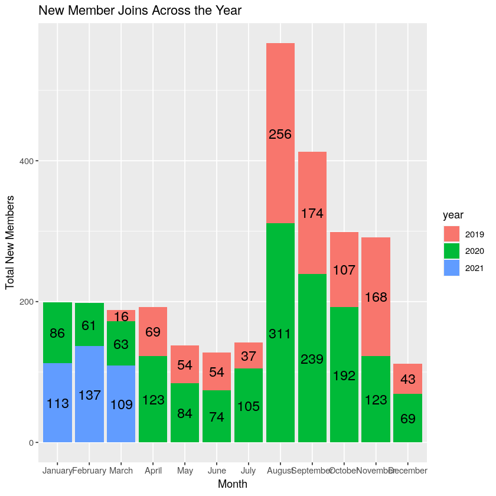

```r
all_joins = ggplot(data = agg_joins, mapping = aes(x = month, y = new_members, fill = year)) + xlab("Month") + ylab("Total New Members") + geom_col()+
            geom_text(aes(label=new_members), position = position_stack(vjust= 0.5),
            colour = "black", size = 5)
all_joins = all_joins + labs(title = "New Member Joins Across the Year")
all_joins
```

After searching the web, I found a great stack overflow answer [How to maintain size of ggplot with long labels](https://stackoverflow.com/a/41607201) that ultimately influenced the final graphs.

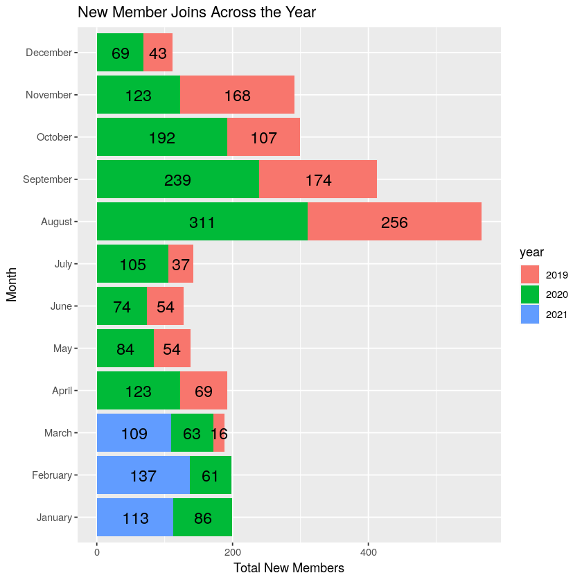

```r
all_joins = ggplot(data = agg_joins, mapping = aes(x = month, y = new_members, fill = year)) + xlab("Month") + ylab("Total New Members") + geom_col()+
            geom_text(aes(label=new_members), position = position_stack(vjust= 0.5),
            colour = "black", size = 5) + coord_flip()
all_joins = all_joins + labs(title = "New Member Joins Across the Year")
all_joins
```

Ultimately this is the final version of the graph. For the report, I scaled the horizontal dimension to be 1920 and had the aspect ratio fixed.

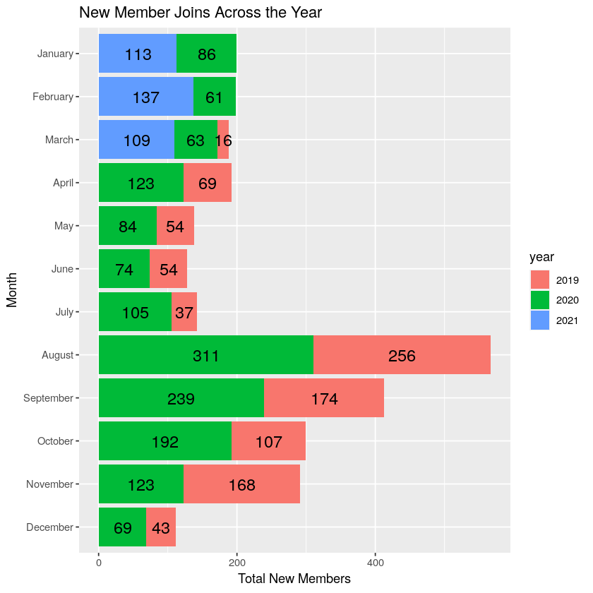

```r
all_joins = ggplot(data = agg_joins, mapping = aes(x = month, y = new_members, fill = year)) + xlab("Month") + ylab("Total New Members") + geom_col()+
            geom_text(aes(label=new_members), position = position_stack(vjust= 0.5),
            colour = "black", size = 5) + coord_flip() + scale_x_discrete(limits = rev(levels(agg_joins$month)))
all_joins = all_joins + labs(title = "New Member Joins Across the Year")
all_joins
```

## All leaves

I decided to also make a graph for leaves, but it was ultimately scrapped because our analysis was more focused in the new user changes. Perhaps we can return to analyze the leaves

```r
leaves
agg_leaves.2019
agg_leaves.2020
agg_leaves.2021
agg_leaves
```

A data.frame: 1104 × 7

| interval_start_timestamp <chr> | year <fct> | month <fct> | day <fct> | days_in_guild <fct> | leavers <int> | year_type <fct> |
| --- | --- | --- | --- | --- | --- | --- |
| 2019-03-29T00:00:00Z | 2019 | March | Friday | 'Members for 1 month+' | 1 | Normal |
| 2019-03-30T00:00:00Z | 2019 | March | Saturday | 'Members for 1 month+' | 1 | Normal |
| 2019-03-30T00:00:00Z | 2019 | March | Saturday | 'Members for < 1 month' | 1 | Normal |
| 2019-03-31T00:00:00Z | 2019 | March | Sunday | 'Members for 1 month+' | 2 | Normal |
| 2019-03-31T00:00:00Z | 2019 | March | <span style=white-space:pre-wrap>Sunday </span> | 'Members for < 1 month' | 1 | Normal |
| 2019-04-01T00:00:00Z | 2019 | April | Monday | 'Members for 1 month+' | 4 | Normal |
| 2019-04-02T00:00:00Z | 2019 | April | Tuesday | 'Members for 1 month+' | 1 | Normal |
| 2019-04-03T00:00:00Z | 2019 | April | Wednesday | 'Members for 1 month+' | 2 | Normal |
| 2019-04-03T00:00:00Z | 2019 | April | Wednesday | 'Members for < 1 month' | 2 | Normal |
| 2019-04-04T00:00:00Z | 2019 | April | Thursday | 'Members for 1 month+' | 2 | Normal |
| 2019-04-04T00:00:00Z | 2019 | April | Thursday | 'Members for < 1 month' | 2 | Normal |
| 2019-04-05T00:00:00Z | 2019 | April | Friday | 'Members for 1 month+' | 3 | Normal |
| 2019-04-06T00:00:00Z | 2019 | April | Saturday | 'Members for 1 month+' | 1 | Normal |
| 2019-04-06T00:00:00Z | 2019 | April | Saturday | 'Members for < 1 month' | 1 | Normal |
| 2019-04-07T00:00:00Z | 2019 | April | Sunday | 'Members for 1 month+' | 1 | Normal |
| 2019-04-07T00:00:00Z | 2019 | April | <span style=white-space:pre-wrap>Sunday </span> | 'Members for < 1 month' | 2 | Normal |
| 2019-04-08T00:00:00Z | 2019 | April | Monday | 'Members for 1 month+' | 1 | Normal |
| 2019-04-08T00:00:00Z | 2019 | April | <span style=white-space:pre-wrap>Monday </span> | 'Members for < 1 month' | 1 | Normal |
| 2019-04-09T00:00:00Z | 2019 | April | Tuesday | 'Members for 1 month+' | 1 | Normal |
| 2019-04-09T00:00:00Z | 2019 | April | <span style=white-space:pre-wrap>Tuesday </span> | 'Members for < 1 month' | 1 | Normal |
| 2019-04-10T00:00:00Z | 2019 | April | Wednesday | 'Members for 1 month+' | 2 | Normal |
| 2019-04-10T00:00:00Z | 2019 | April | Wednesday | 'Members for < 1 month' | 1 | Normal |
| 2019-04-11T00:00:00Z | 2019 | April | Thursday | 'Members for 1 month+' | 0 | Normal |
| 2019-04-12T00:00:00Z | 2019 | April | Friday | 'Members for 1 month+' | 1 | Normal |
| 2019-04-13T00:00:00Z | 2019 | April | Saturday | 'Members for < 1 month' | 1 | Normal |
| 2019-04-14T00:00:00Z | 2019 | April | Sunday | 'Members for 1 month+' | 2 | Normal |
| 2019-04-15T00:00:00Z | 2019 | April | Monday | 'Members for 1 month+' | 1 | Normal |
| 2019-04-15T00:00:00Z | 2019 | April | <span style=white-space:pre-wrap>Monday </span> | 'Members for < 1 month' | 1 | Normal |
| 2019-04-16T00:00:00Z | 2019 | April | Tuesday | 'Members for 1 month+' | 3 | Normal |
| 2019-04-16T00:00:00Z | 2019 | April | <span style=white-space:pre-wrap>Tuesday </span> | 'Members for < 1 month' | 1 | Normal |
| ⋮ | ⋮ | ⋮ | ⋮ | ⋮ | ⋮ | ⋮ |
| 2021-03-09T00:00:00Z | 2021 | March | Tuesday | 'Members for 1 month+' | 2 | Covid |
| 2021-03-09T00:00:00Z | 2021 | March | <span style=white-space:pre-wrap>Tuesday </span> | 'Members for < 1 month' | 1 | Covid |
| 2021-03-10T00:00:00Z | 2021 | March | Wednesday | 'Members for 1 month+' | 2 | Covid |
| 2021-03-10T00:00:00Z | 2021 | March | Wednesday | 'Members for < 1 month' | 3 | Covid |
| 2021-03-11T00:00:00Z | 2021 | March | Thursday | 'Members for 1 month+' | 2 | Covid |
| 2021-03-12T00:00:00Z | 2021 | March | Friday | 'Members for 1 month+' | 1 | Covid |
| 2021-03-12T00:00:00Z | 2021 | March | <span style=white-space:pre-wrap>Friday </span> | 'Members for < 1 month' | 5 | Covid |
| 2021-03-13T00:00:00Z | 2021 | March | Saturday | 'Members for < 1 month' | 1 | Covid |
| 2021-03-14T00:00:00Z | 2021 | March | Sunday | 'Members for 1 month+' | 1 | Covid |
| 2021-03-14T00:00:00Z | 2021 | March | <span style=white-space:pre-wrap>Sunday </span> | 'Members for < 1 month' | 1 | Covid |
| 2021-03-15T00:00:00Z | 2021 | March | Monday | 'Members for 1 month+' | 2 | Covid |
| 2021-03-16T00:00:00Z | 2021 | March | Tuesday | 'Members for 1 month+' | 1 | Covid |
| 2021-03-16T00:00:00Z | 2021 | March | <span style=white-space:pre-wrap>Tuesday </span> | 'Members for < 1 month' | 3 | Covid |
| 2021-03-17T00:00:00Z | 2021 | March | Wednesday | 'Members for 1 month+' | 4 | Covid |
| 2021-03-17T00:00:00Z | 2021 | March | Wednesday | 'Members for < 1 month' | 2 | Covid |
| 2021-03-18T00:00:00Z | 2021 | March | Thursday | 'Members for < 1 month' | 1 | Covid |
| 2021-03-19T00:00:00Z | 2021 | March | Friday | 'Members for 1 month+' | 2 | Covid |
| 2021-03-19T00:00:00Z | 2021 | March | <span style=white-space:pre-wrap>Friday </span> | 'Members for < 1 month' | 2 | Covid |
| 2021-03-20T00:00:00Z | 2021 | March | Saturday | 'Members for 1 month+' | 5 | Covid |
| 2021-03-20T00:00:00Z | 2021 | March | Saturday | 'Members for < 1 month' | 1 | Covid |
| 2021-03-21T00:00:00Z | 2021 | March | Sunday | 'Members for 1 month+' | 1 | Covid |
| 2021-03-21T00:00:00Z | 2021 | March | <span style=white-space:pre-wrap>Sunday </span> | 'Members for < 1 month' | 3 | Covid |
| 2021-03-22T00:00:00Z | 2021 | March | Monday | 'Members for 1 month+' | 1 | Covid |
| 2021-03-23T00:00:00Z | 2021 | March | Tuesday | 'Members for 1 month+' | 3 | Covid |
| 2021-03-23T00:00:00Z | 2021 | March | <span style=white-space:pre-wrap>Tuesday </span> | 'Members for < 1 month' | 1 | Covid |
| 2021-03-24T00:00:00Z | 2021 | March | Wednesday | 'Members for 1 month+' | 0 | Covid |
| 2021-03-25T00:00:00Z | 2021 | March | Thursday | 'Members for 1 month+' | 2 | Covid |
| 2021-03-25T00:00:00Z | 2021 | March | Thursday | 'Members for < 1 month' | 1 | Covid |
| 2021-03-26T00:00:00Z | 2021 | March | Friday | 'Members for 1 month+' | 3 | Covid |
| 2021-03-26T00:00:00Z | 2021 | March | <span style=white-space:pre-wrap>Friday </span> | 'Members for < 1 month' | 1 | Covid |

A data.frame: 10 × 2

| Months <fct> | Total Leavers <int> |
| --- | --- |
| March | 6 |
| April | 75 |
| May | 54 |
| June | 45 |
| July | 47 |
| August | 66 |
| September | 90 |
| October | 60 |
| November | 118 |
| December | 43 |

A data.frame: 12 × 2

| Months <fct> | Total Leavers <int> |
| --- | --- |
| January | 66 |
| February | 82 |
| March | 73 |
| April | 95 |
| May | 72 |
| June | 82 |
| July | 90 |
| August | 127 |
| September | 132 |
| October | 100 |
| November | 91 |
| December | 83 |

A data.frame: 3 × 2

| Months <fct> | Total Leavers <int> |
| --- | --- |
| January | 93 |
| February | 88 |
| March | 78 |

A data.frame: 25 × 3

| month <fct> | year <fct> | leavers <int> |
| --- | --- | --- |
| March | 2019 | 6 |
| April | 2019 | 75 |
| May | 2019 | 54 |
| June | 2019 | 45 |
| July | 2019 | 47 |
| August | 2019 | 66 |
| September | 2019 | 90 |
| October | 2019 | 60 |
| November | 2019 | 118 |
| December | 2019 | 43 |
| January | 2020 | 66 |
| February | 2020 | 82 |
| March | 2020 | 73 |
| April | 2020 | 95 |
| May | 2020 | 72 |
| June | 2020 | 82 |
| July | 2020 | 90 |
| August | 2020 | 127 |
| September | 2020 | 132 |
| October | 2020 | 100 |
| November | 2020 | 91 |
| December | 2020 | 83 |
| January | 2021 | 93 |
| February | 2021 | 88 |
| March | 2021 | 78 |

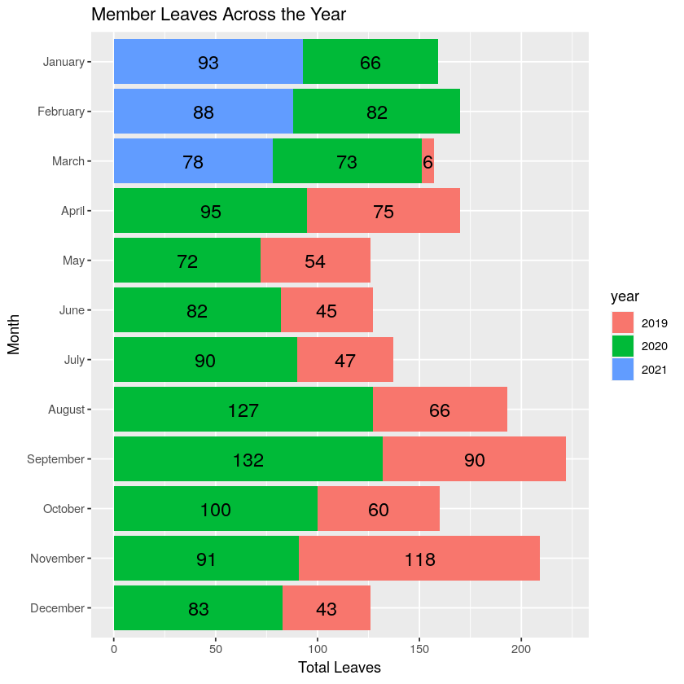

```r
all_leaves = ggplot(data = agg_leaves, mapping = aes(x = month, y = leavers, fill = year)) + xlab("Month") + ylab("Total Leaves") + geom_col()+
             geom_text(aes(label=leavers), position = position_stack(vjust= 0.5),
             colour = "black", size = 5) + coord_flip() + scale_x_discrete(limits = rev(levels(agg_leaves$month)))
all_leaves = all_leaves + labs(title = "Member Leaves Across the Year")

all_leaves
```

## All communicators

```r
communicators

agg_comm.2019
agg_comm.2020
agg_comm.2021
agg_comms
```

A data.frame: 729 × 8

| interval_start_timestamp <chr> | year <fct> | month <fct> | day <fct> | visitors <int> | pct_communicated <dbl> | total_communicated <dbl> | year_type <fct> |
| --- | --- | --- | --- | --- | --- | --- | --- |
| 2019-03-29T00:00:00Z | 2019 | March | Friday | 206 | 25.72816 | 53 | Normal |
| 2019-03-30T00:00:00Z | 2019 | March | Saturday | 184 | 20.65217 | 38 | Normal |
| 2019-03-31T00:00:00Z | 2019 | March | Sunday | 185 | 24.32432 | 45 | Normal |
| 2019-04-01T00:00:00Z | 2019 | April | Monday | 328 | 22.86585 | 75 | Normal |
| 2019-04-02T00:00:00Z | 2019 | April | Tuesday | 143 | 33.56643 | 48 | Normal |
| 2019-04-03T00:00:00Z | 2019 | April | Wednesday | 271 | 16.60517 | 45 | Normal |
| 2019-04-04T00:00:00Z | 2019 | April | Thursday | 381 | 13.38583 | 51 | Normal |
| 2019-04-05T00:00:00Z | 2019 | April | Friday | 190 | 24.73684 | 47 | Normal |
| 2019-04-06T00:00:00Z | 2019 | April | Saturday | 163 | 26.99387 | 44 | Normal |
| 2019-04-07T00:00:00Z | 2019 | April | Sunday | 159 | 31.44654 | 50 | Normal |
| 2019-04-08T00:00:00Z | 2019 | April | Monday | 163 | 25.76687 | 42 | Normal |
| 2019-04-09T00:00:00Z | 2019 | April | Tuesday | 148 | 31.08108 | 46 | Normal |
| 2019-04-10T00:00:00Z | 2019 | April | Wednesday | 163 | 30.67485 | 50 | Normal |
| 2019-04-11T00:00:00Z | 2019 | April | Thursday | 139 | 38.12950 | 53 | Normal |
| 2019-04-12T00:00:00Z | 2019 | April | Friday | 155 | 29.67742 | 46 | Normal |
| 2019-04-13T00:00:00Z | 2019 | April | Saturday | 143 | 30.06993 | 43 | Normal |
| 2019-04-14T00:00:00Z | 2019 | April | Sunday | 140 | 28.57143 | 40 | Normal |
| 2019-04-15T00:00:00Z | 2019 | April | Monday | 170 | 29.41176 | 50 | Normal |
| 2019-04-16T00:00:00Z | 2019 | April | Tuesday | 150 | 40.66667 | 61 | Normal |
| 2019-04-17T00:00:00Z | 2019 | April | Wednesday | 153 | 34.64052 | 53 | Normal |
| 2019-04-18T00:00:00Z | 2019 | April | Thursday | 167 | 43.71257 | 73 | Normal |
| 2019-04-19T00:00:00Z | 2019 | April | Friday | 162 | 33.95062 | 55 | Normal |
| 2019-04-20T00:00:00Z | 2019 | April | Saturday | 337 | 15.13353 | 51 | Normal |
| 2019-04-21T00:00:00Z | 2019 | April | Sunday | 172 | 25.00000 | 43 | Normal |
| 2019-04-22T00:00:00Z | 2019 | April | Monday | 162 | 24.07407 | 39 | Normal |
| 2019-04-23T00:00:00Z | 2019 | April | Tuesday | 163 | 35.58282 | 58 | Normal |
| 2019-04-24T00:00:00Z | 2019 | April | Wednesday | 340 | 15.29412 | 52 | Normal |
| 2019-04-25T00:00:00Z | 2019 | April | Thursday | 196 | 26.53061 | 52 | Normal |
| 2019-04-26T00:00:00Z | 2019 | April | Friday | 371 | 16.98113 | 63 | Normal |
| 2019-04-27T00:00:00Z | 2019 | April | Saturday | 201 | 27.86070 | 56 | Normal |
| ⋮ | ⋮ | ⋮ | ⋮ | ⋮ | ⋮ | ⋮ | ⋮ |
| 2021-02-25T00:00:00Z | 2021 | February | Thursday | 172 | 23.255814 | 40 | Covid |
| 2021-02-26T00:00:00Z | 2021 | February | Friday | 167 | 19.161677 | 32 | Covid |
| 2021-02-27T00:00:00Z | 2021 | February | Saturday | 208 | 20.673077 | 43 | Covid |
| 2021-02-28T00:00:00Z | 2021 | February | Sunday | 167 | 17.964072 | 30 | Covid |
| 2021-03-01T00:00:00Z | 2021 | March | Monday | 164 | 18.292683 | 30 | Covid |
| 2021-03-02T00:00:00Z | 2021 | March | Tuesday | 199 | 15.075377 | 30 | Covid |
| 2021-03-03T00:00:00Z | 2021 | March | Wednesday | 163 | 18.404908 | 30 | Covid |
| 2021-03-04T00:00:00Z | 2021 | March | Thursday | 163 | 20.858896 | 34 | Covid |
| 2021-03-05T00:00:00Z | 2021 | March | Friday | 179 | 17.318436 | 31 | Covid |
| 2021-03-06T00:00:00Z | 2021 | March | Saturday | 304 | 9.539474 | 29 | Covid |
| 2021-03-07T00:00:00Z | 2021 | March | Sunday | 162 | 15.432099 | 25 | Covid |
| 2021-03-08T00:00:00Z | 2021 | March | Monday | 234 | 13.675214 | 32 | Covid |
| 2021-03-09T00:00:00Z | 2021 | March | Tuesday | 160 | 23.125000 | 37 | Covid |
| 2021-03-10T00:00:00Z | 2021 | March | Wednesday | 156 | 20.512821 | 32 | Covid |
| 2021-03-11T00:00:00Z | 2021 | March | Thursday | 553 | 7.233273 | 40 | Covid |
| 2021-03-12T00:00:00Z | 2021 | March | Friday | 253 | 14.624506 | 37 | Covid |
| 2021-03-13T00:00:00Z | 2021 | March | Saturday | 237 | 14.345992 | 34 | Covid |
| 2021-03-14T00:00:00Z | 2021 | March | Sunday | 147 | 20.408163 | 30 | Covid |
| 2021-03-15T00:00:00Z | 2021 | March | Monday | 154 | 18.831169 | 29 | Covid |
| 2021-03-16T00:00:00Z | 2021 | March | Tuesday | 154 | 21.428571 | 33 | Covid |
| 2021-03-17T00:00:00Z | 2021 | March | Wednesday | 141 | 21.985816 | 31 | Covid |
| 2021-03-18T00:00:00Z | 2021 | March | Thursday | 153 | 20.261438 | 31 | Covid |
| 2021-03-19T00:00:00Z | 2021 | March | Friday | 268 | 19.402985 | 52 | Covid |
| 2021-03-20T00:00:00Z | 2021 | March | Saturday | 658 | 6.382979 | 42 | Covid |
| 2021-03-21T00:00:00Z | 2021 | March | Sunday | 170 | 23.529412 | 40 | Covid |
| 2021-03-22T00:00:00Z | 2021 | March | Monday | 174 | 22.413793 | 39 | Covid |
| 2021-03-23T00:00:00Z | 2021 | March | Tuesday | 143 | 16.783217 | 24 | Covid |
| 2021-03-24T00:00:00Z | 2021 | March | Wednesday | 157 | 17.197452 | 27 | Covid |
| 2021-03-25T00:00:00Z | 2021 | March | Thursday | 165 | 25.454545 | 42 | Covid |
| 2021-03-26T00:00:00Z | 2021 | March | Friday | 573 | 6.108202 | 35 | Covid |

A data.frame: 10 × 2

| Months <fct> | Total Communicated <dbl> |
| --- | --- |
| March | 136 |
| April | 1531 |
| May | 1238 |
| June | 1094 |
| July | 1150 |
| August | 1760 |
| September | 2588 |
| October | 2168 |
| November | 1861 |
| December | 1184 |

A data.frame: 12 × 2

| Months <fct> | Total Communicated <dbl> |
| --- | --- |
| January | 1094 |
| February | 1232 |
| March | 1174 |
| April | 1186 |
| May | 1077 |
| June | 1139 |
| July | 1071 |
| August | 1859 |
| September | 2175 |
| October | 1602 |
| November | 1165 |
| December | 864 |

A data.frame: 3 × 2

| Months <fct> | Total Communicated <dbl> |
| --- | --- |
| January | 968 |
| February | 948 |
| March | 876 |

A data.frame: 25 × 3

| month <fct> | year <fct> | total_communicated <dbl> |
| --- | --- | --- |
| March | 2019 | 136 |
| April | 2019 | 1531 |
| May | 2019 | 1238 |
| June | 2019 | 1094 |
| July | 2019 | 1150 |
| August | 2019 | 1760 |
| September | 2019 | 2588 |
| October | 2019 | 2168 |
| November | 2019 | 1861 |
| December | 2019 | 1184 |
| January | 2020 | 1094 |
| February | 2020 | 1232 |
| March | 2020 | 1174 |
| April | 2020 | 1186 |
| May | 2020 | 1077 |
| June | 2020 | 1139 |
| July | 2020 | 1071 |
| August | 2020 | 1859 |
| September | 2020 | 2175 |
| October | 2020 | 1602 |
| November | 2020 | 1165 |
| December | 2020 | 864 |
| January | 2021 | 968 |
| February | 2021 | 948 |
| March | 2021 | 876 |

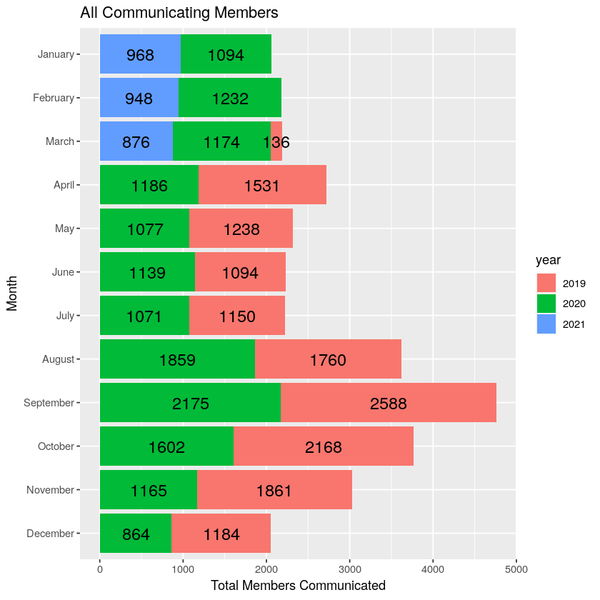

```r
all_comms = ggplot(data = agg_comms, mapping = aes(x = month, y = total_communicated, fill = year)) + xlab("Month") + ylab("Total Members Communicated") +
            geom_col()+ geom_text(aes(label=total_communicated), position = position_stack(vjust= 0.5),
            colour = "black", size = 5) + coord_flip() + scale_x_discrete(limits = rev(levels(agg_comms$month)))
all_comms = all_comms + labs(title = "All Communicating Members")
all_comms
```

# Multiple Models Excluding Effect of Year

This section contains the code for generating linear models for the other variables we were interested in. I followed my professor's notes for setting up the parameters. For fun I decided to experiment with the messages dataset, as it included an additional variable of `messages_per_communicator` which gives a bit more granularity in comparing between individuals and aggregates for messages.

## New members linear model

```r
joins
```

A data.frame: 729 × 8

| interval_start_timestamp <chr> | year <fct> | month <fct> | day <fct> | new_members <int> | pct_communicated <dbl> | pct_opened_channels <dbl> | year_type <fct> |
| --- | --- | --- | --- | --- | --- | --- | --- |
| 2019-03-29T00:00:00Z | 2019 | March | Friday | 2 | 50.00000 | 50.00000 | Normal |
| 2019-03-30T00:00:00Z | 2019 | March | Saturday | 6 | 16.66667 | 33.33333 | Normal |
| 2019-03-31T00:00:00Z | 2019 | March | Sunday | 8 | 25.00000 | 37.50000 | Normal |
| 2019-04-01T00:00:00Z | 2019 | April | Monday | 9 | 44.44444 | 33.33333 | Normal |
| 2019-04-02T00:00:00Z | 2019 | April | Tuesday | 2 | 50.00000 | 100.00000 | Normal |
| 2019-04-03T00:00:00Z | 2019 | April | Wednesday | 0 | NA | NA | Normal |
| 2019-04-04T00:00:00Z | 2019 | April | Thursday | 2 | 100.00000 | 100.00000 | Normal |
| 2019-04-05T00:00:00Z | 2019 | April | Friday | 3 | 33.33333 | 0.00000 | Normal |
| 2019-04-06T00:00:00Z | 2019 | April | Saturday | 2 | 0.00000 | 0.00000 | Normal |
| 2019-04-07T00:00:00Z | 2019 | April | Sunday | 2 | 0.00000 | 0.00000 | Normal |
| 2019-04-08T00:00:00Z | 2019 | April | Monday | 9 | 33.33333 | 33.33333 | Normal |
| 2019-04-09T00:00:00Z | 2019 | April | Tuesday | 3 | 33.33333 | 33.33333 | Normal |
| 2019-04-10T00:00:00Z | 2019 | April | Wednesday | 1 | 100.00000 | 100.00000 | Normal |
| 2019-04-11T00:00:00Z | 2019 | April | Thursday | 1 | 0.00000 | 100.00000 | Normal |
| 2019-04-12T00:00:00Z | 2019 | April | Friday | 1 | 0.00000 | 100.00000 | Normal |
| 2019-04-13T00:00:00Z | 2019 | April | Saturday | 1 | 0.00000 | 100.00000 | Normal |
| 2019-04-14T00:00:00Z | 2019 | April | Sunday | 0 | NA | NA | Normal |
| 2019-04-15T00:00:00Z | 2019 | April | Monday | 0 | NA | NA | Normal |
| 2019-04-16T00:00:00Z | 2019 | April | Tuesday | 3 | 66.66667 | 0.00000 | Normal |
| 2019-04-17T00:00:00Z | 2019 | April | Wednesday | 5 | 0.00000 | 20.00000 | Normal |
| 2019-04-18T00:00:00Z | 2019 | April | Thursday | 3 | 100.00000 | 33.33333 | Normal |
| 2019-04-19T00:00:00Z | 2019 | April | Friday | 3 | 0.00000 | 33.33333 | Normal |
| 2019-04-20T00:00:00Z | 2019 | April | Saturday | 0 | NA | NA | Normal |
| 2019-04-21T00:00:00Z | 2019 | April | Sunday | 1 | 100.00000 | 100.00000 | Normal |
| 2019-04-22T00:00:00Z | 2019 | April | Monday | 0 | NA | NA | Normal |
| 2019-04-23T00:00:00Z | 2019 | April | Tuesday | 1 | 0.00000 | 0.00000 | Normal |
| 2019-04-24T00:00:00Z | 2019 | April | Wednesday | 3 | 33.33333 | 0.00000 | Normal |
| 2019-04-25T00:00:00Z | 2019 | April | Thursday | 3 | 66.66667 | 66.66667 | Normal |
| 2019-04-26T00:00:00Z | 2019 | April | Friday | 3 | 33.33333 | 33.33333 | Normal |
| 2019-04-27T00:00:00Z | 2019 | April | Saturday | 1 | 100.00000 | 0.00000 | Normal |
| ⋮ | ⋮ | ⋮ | ⋮ | ⋮ | ⋮ | ⋮ | ⋮ |
| 2021-02-25T00:00:00Z | 2021 | February | Thursday | 1 | 0.00000 | 100.00000 | Covid |
| 2021-02-26T00:00:00Z | 2021 | February | Friday | 5 | 40.00000 | 100.00000 | Covid |
| 2021-02-27T00:00:00Z | 2021 | February | Saturday | 8 | 12.50000 | 100.00000 | Covid |
| 2021-02-28T00:00:00Z | 2021 | February | Sunday | 5 | 20.00000 | 100.00000 | Covid |
| 2021-03-01T00:00:00Z | 2021 | March | Monday | 2 | 0.00000 | 50.00000 | Covid |
| 2021-03-02T00:00:00Z | 2021 | March | Tuesday | 6 | 16.66667 | 16.66667 | Covid |
| 2021-03-03T00:00:00Z | 2021 | March | Wednesday | 5 | 0.00000 | 40.00000 | Covid |
| 2021-03-04T00:00:00Z | 2021 | March | Thursday | 8 | 0.00000 | 62.50000 | Covid |
| 2021-03-05T00:00:00Z | 2021 | March | Friday | 3 | 33.33333 | 33.33333 | Covid |
| 2021-03-06T00:00:00Z | 2021 | March | Saturday | 3 | 0.00000 | 66.66667 | Covid |
| 2021-03-07T00:00:00Z | 2021 | March | Sunday | 3 | 0.00000 | 33.33333 | Covid |
| 2021-03-08T00:00:00Z | 2021 | March | Monday | 7 | 14.28571 | 42.85714 | Covid |
| 2021-03-09T00:00:00Z | 2021 | March | Tuesday | 7 | 0.00000 | 57.14286 | Covid |
| 2021-03-10T00:00:00Z | 2021 | March | Wednesday | 5 | 0.00000 | 40.00000 | Covid |
| 2021-03-11T00:00:00Z | 2021 | March | Thursday | 1 | 0.00000 | 100.00000 | Covid |
| 2021-03-12T00:00:00Z | 2021 | March | Friday | 11 | 18.18182 | 45.45455 | Covid |
| 2021-03-13T00:00:00Z | 2021 | March | Saturday | 4 | 0.00000 | 50.00000 | Covid |
| 2021-03-14T00:00:00Z | 2021 | March | Sunday | 1 | 0.00000 | 0.00000 | Covid |
| 2021-03-15T00:00:00Z | 2021 | March | Monday | 1 | 0.00000 | 0.00000 | Covid |
| 2021-03-16T00:00:00Z | 2021 | March | Tuesday | 6 | 0.00000 | 83.33333 | Covid |
| 2021-03-17T00:00:00Z | 2021 | March | Wednesday | 7 | 0.00000 | 71.42857 | Covid |
| 2021-03-18T00:00:00Z | 2021 | March | Thursday | 1 | 0.00000 | 0.00000 | Covid |
| 2021-03-19T00:00:00Z | 2021 | March | Friday | 5 | 0.00000 | 80.00000 | Covid |
| 2021-03-20T00:00:00Z | 2021 | March | Saturday | 2 | 0.00000 | 0.00000 | Covid |
| 2021-03-21T00:00:00Z | 2021 | March | Sunday | 6 | 33.33333 | 33.33333 | Covid |
| 2021-03-22T00:00:00Z | 2021 | March | Monday | 5 | 20.00000 | 60.00000 | Covid |
| 2021-03-23T00:00:00Z | 2021 | March | Tuesday | 1 | 0.00000 | 0.00000 | Covid |
| 2021-03-24T00:00:00Z | 2021 | March | Wednesday | 4 | 0.00000 | 50.00000 | Covid |
| 2021-03-25T00:00:00Z | 2021 | March | Thursday | 1 | 0.00000 | 0.00000 | Covid |
| 2021-03-26T00:00:00Z | 2021 | March | Friday | 4 | NA | NA | Covid |

```r
joins_lm = lm(new_members ~ month + year_type, data = joins)
print(summary(joins_lm))
```

```
Call:
lm(formula = new_members ~ month + year_type, data = joins)

Residuals:
   Min     1Q Median     3Q    Max
-8.759 -2.195 -0.612  0.808 85.469

Coefficients:
               Estimate Std. Error t value Pr(>|t|)
(Intercept)     1.98132    0.80555   2.460  0.01414 *
monthFebruary   0.26401    0.96935   0.272  0.78543
monthMarch     -0.01493    0.95690  -0.016  0.98756
monthApril      0.60450    0.98228   0.615  0.53848
monthMay       -0.36969    0.97461  -0.379  0.70456
monthJune      -0.46217    0.98228  -0.471  0.63814
monthJuly      -0.30518    0.97461  -0.313  0.75428
monthAugust     6.54966    0.97461   6.720 3.70e-11 ***
monthSeptember  4.28783    0.98228   4.365 1.46e-05 ***
monthOctober    2.22708    0.97461   2.285  0.02260 *
monthNovember   2.25450    0.98228   2.295  0.02201 *
monthDecember  -0.78905    0.97461  -0.810  0.41844
year_typeCovid  1.22836    0.44590   2.755  0.00602 **
---
Signif. codes:  0 ‘***’ 0.001 ‘**’ 0.01 ‘*’ 0.05 ‘.’ 0.1 ‘ ’ 1

Residual standard error: 5.283 on 716 degrees of freedom
Multiple R-squared:  0.1475,	Adjusted R-squared:  0.1332
F-statistic: 10.32 on 12 and 716 DF,  p-value: < 2.2e-16
```

## Total messages linear model

```r
messages
```

A data.frame: 729 × 7

| interval_start_timestamp <chr> | year <fct> | month <fct> | day <fct> | messages <int> | messages_per_communicator <dbl> | year_type <fct> |
| --- | --- | --- | --- | --- | --- | --- |
| 2019-03-29T00:00:00Z | 2019 | March | Friday | 334 | 6.301887 | Normal |
| 2019-03-30T00:00:00Z | 2019 | March | Saturday | 236 | 6.210526 | Normal |
| 2019-03-31T00:00:00Z | 2019 | March | Sunday | 364 | 8.088889 | Normal |
| 2019-04-01T00:00:00Z | 2019 | April | Monday | 404 | 5.386667 | Normal |
| 2019-04-02T00:00:00Z | 2019 | April | Tuesday | 543 | 11.312500 | Normal |
| 2019-04-03T00:00:00Z | 2019 | April | Wednesday | 324 | 7.200000 | Normal |
| 2019-04-04T00:00:00Z | 2019 | April | Thursday | 556 | 10.901961 | Normal |
| 2019-04-05T00:00:00Z | 2019 | April | Friday | 273 | 5.808511 | Normal |
| 2019-04-06T00:00:00Z | 2019 | April | Saturday | 335 | 7.613636 | Normal |
| 2019-04-07T00:00:00Z | 2019 | April | Sunday | 1102 | 22.040000 | Normal |
| 2019-04-08T00:00:00Z | 2019 | April | Monday | 188 | 4.476190 | Normal |
| 2019-04-09T00:00:00Z | 2019 | April | Tuesday | 399 | 8.673913 | Normal |
| 2019-04-10T00:00:00Z | 2019 | April | Wednesday | 531 | 10.620000 | Normal |
| 2019-04-11T00:00:00Z | 2019 | April | Thursday | 689 | 13.000000 | Normal |
| 2019-04-12T00:00:00Z | 2019 | April | Friday | 418 | 9.086957 | Normal |
| 2019-04-13T00:00:00Z | 2019 | April | Saturday | 566 | 13.162791 | Normal |
| 2019-04-14T00:00:00Z | 2019 | April | Sunday | 481 | 12.025000 | Normal |
| 2019-04-15T00:00:00Z | 2019 | April | Monday | 659 | 13.180000 | Normal |
| 2019-04-16T00:00:00Z | 2019 | April | Tuesday | 779 | 12.770492 | Normal |
| 2019-04-17T00:00:00Z | 2019 | April | Wednesday | 596 | 11.245283 | Normal |
| 2019-04-18T00:00:00Z | 2019 | April | Thursday | 1143 | 15.657534 | Normal |
| 2019-04-19T00:00:00Z | 2019 | April | Friday | 898 | 16.327273 | Normal |
| 2019-04-20T00:00:00Z | 2019 | April | Saturday | 331 | 6.490196 | Normal |
| 2019-04-21T00:00:00Z | 2019 | April | Sunday | 473 | 11.000000 | Normal |
| 2019-04-22T00:00:00Z | 2019 | April | Monday | 283 | 7.256410 | Normal |
| 2019-04-23T00:00:00Z | 2019 | April | Tuesday | 1270 | 21.896552 | Normal |
| 2019-04-24T00:00:00Z | 2019 | April | Wednesday | 746 | 14.346154 | Normal |
| 2019-04-25T00:00:00Z | 2019 | April | Thursday | 287 | 5.519231 | Normal |
| 2019-04-26T00:00:00Z | 2019 | April | Friday | 728 | 11.555556 | Normal |
| 2019-04-27T00:00:00Z | 2019 | April | Saturday | 691 | 12.339286 | Normal |
| ⋮ | ⋮ | ⋮ | ⋮ | ⋮ | ⋮ | ⋮ |
| 2021-02-25T00:00:00Z | 2021 | February | Thursday | 138 | 3.450000 | Covid |
| 2021-02-26T00:00:00Z | 2021 | February | Friday | 78 | 2.437500 | Covid |
| 2021-02-27T00:00:00Z | 2021 | February | Saturday | 93 | 2.162791 | Covid |
| 2021-02-28T00:00:00Z | 2021 | February | Sunday | 46 | 1.533333 | Covid |
| 2021-03-01T00:00:00Z | 2021 | March | Monday | 53 | 1.766667 | Covid |
| 2021-03-02T00:00:00Z | 2021 | March | Tuesday | 72 | 2.400000 | Covid |
| 2021-03-03T00:00:00Z | 2021 | March | Wednesday | 122 | 4.066667 | Covid |
| 2021-03-04T00:00:00Z | 2021 | March | Thursday | 168 | 4.941176 | Covid |
| 2021-03-05T00:00:00Z | 2021 | March | Friday | 74 | 2.387097 | Covid |
| 2021-03-06T00:00:00Z | 2021 | March | Saturday | 43 | 1.482759 | Covid |
| 2021-03-07T00:00:00Z | 2021 | March | Sunday | 43 | 1.720000 | Covid |
| 2021-03-08T00:00:00Z | 2021 | March | Monday | 106 | 3.312500 | Covid |
| 2021-03-09T00:00:00Z | 2021 | March | Tuesday | 114 | 3.081081 | Covid |
| 2021-03-10T00:00:00Z | 2021 | March | Wednesday | 83 | 2.593750 | Covid |
| 2021-03-11T00:00:00Z | 2021 | March | Thursday | 109 | 2.725000 | Covid |
| 2021-03-12T00:00:00Z | 2021 | March | Friday | 75 | 2.027027 | Covid |
| 2021-03-13T00:00:00Z | 2021 | March | Saturday | 158 | 4.647059 | Covid |
| 2021-03-14T00:00:00Z | 2021 | March | Sunday | 73 | 2.433333 | Covid |
| 2021-03-15T00:00:00Z | 2021 | March | Monday | 73 | 2.517241 | Covid |
| 2021-03-16T00:00:00Z | 2021 | March | Tuesday | 52 | 1.575758 | Covid |
| 2021-03-17T00:00:00Z | 2021 | March | Wednesday | 64 | 2.064516 | Covid |
| 2021-03-18T00:00:00Z | 2021 | March | Thursday | 65 | 2.096774 | Covid |
| 2021-03-19T00:00:00Z | 2021 | March | Friday | 182 | 3.500000 | Covid |
| 2021-03-20T00:00:00Z | 2021 | March | Saturday | 121 | 2.880952 | Covid |
| 2021-03-21T00:00:00Z | 2021 | March | Sunday | 157 | 3.925000 | Covid |
| 2021-03-22T00:00:00Z | 2021 | March | Monday | 94 | 2.410256 | Covid |
| 2021-03-23T00:00:00Z | 2021 | March | Tuesday | 34 | 1.416667 | Covid |
| 2021-03-24T00:00:00Z | 2021 | March | Wednesday | 51 | 1.888889 | Covid |
| 2021-03-25T00:00:00Z | 2021 | March | Thursday | 120 | 2.857143 | Covid |
| 2021-03-26T00:00:00Z | 2021 | March | Friday | 122 | 3.485714 | Covid |

```r
messages_lm = lm(messages ~ month + year_type, data = messages)
print(summary(messages_lm))
```

```
Call:
lm(formula = messages ~ month + year_type, data = messages)

Residuals:
    Min      1Q  Median      3Q     Max
-533.72 -131.98  -34.98   68.19 2435.80

Coefficients:
                Estimate Std. Error t value Pr(>|t|)
(Intercept)     370.7838    37.3808   9.919  < 2e-16 ***
monthFebruary     0.7405    44.9820   0.016  0.98687
monthMarch       19.0476    44.4043   0.429  0.66808
monthApril      153.6371    45.5819   3.371  0.00079 ***
monthMay         24.6162    45.2261   0.544  0.58641
monthJune       -73.9795    45.5819  -1.623  0.10503
monthJuly       -42.4322    45.2261  -0.938  0.34845
monthAugust     210.2452    45.2261   4.649 3.98e-06 ***
monthSeptember  433.9371    45.5819   9.520  < 2e-16 ***
monthOctober    261.9549    45.2261   5.792 1.04e-08 ***
monthNovember   109.9371    45.5819   2.412  0.01612 *
monthDecember   -79.8354    45.2261  -1.765  0.07795 .
year_typeCovid -193.5419    20.6915  -9.354  < 2e-16 ***
---
Signif. codes:  0 ‘***’ 0.001 ‘**’ 0.01 ‘*’ 0.05 ‘.’ 0.1 ‘ ’ 1

Residual standard error: 245.1 on 716 degrees of freedom
Multiple R-squared:  0.369,	Adjusted R-squared:  0.3584
F-statistic: 34.89 on 12 and 716 DF,  p-value: < 2.2e-16
```

## Messages experiments

### Including messages_per_communicator in full model

```r
messages
```

A data.frame: 729 × 7

| interval_start_timestamp <chr> | year <fct> | month <fct> | day <fct> | messages <int> | messages_per_communicator <dbl> | year_type <fct> |
| --- | --- | --- | --- | --- | --- | --- |
| 2019-03-29T00:00:00Z | 2019 | March | Friday | 334 | 6.301887 | Normal |
| 2019-03-30T00:00:00Z | 2019 | March | Saturday | 236 | 6.210526 | Normal |
| 2019-03-31T00:00:00Z | 2019 | March | Sunday | 364 | 8.088889 | Normal |
| 2019-04-01T00:00:00Z | 2019 | April | Monday | 404 | 5.386667 | Normal |
| 2019-04-02T00:00:00Z | 2019 | April | Tuesday | 543 | 11.312500 | Normal |
| 2019-04-03T00:00:00Z | 2019 | April | Wednesday | 324 | 7.200000 | Normal |
| 2019-04-04T00:00:00Z | 2019 | April | Thursday | 556 | 10.901961 | Normal |
| 2019-04-05T00:00:00Z | 2019 | April | Friday | 273 | 5.808511 | Normal |
| 2019-04-06T00:00:00Z | 2019 | April | Saturday | 335 | 7.613636 | Normal |
| 2019-04-07T00:00:00Z | 2019 | April | Sunday | 1102 | 22.040000 | Normal |
| 2019-04-08T00:00:00Z | 2019 | April | Monday | 188 | 4.476190 | Normal |
| 2019-04-09T00:00:00Z | 2019 | April | Tuesday | 399 | 8.673913 | Normal |
| 2019-04-10T00:00:00Z | 2019 | April | Wednesday | 531 | 10.620000 | Normal |
| 2019-04-11T00:00:00Z | 2019 | April | Thursday | 689 | 13.000000 | Normal |
| 2019-04-12T00:00:00Z | 2019 | April | Friday | 418 | 9.086957 | Normal |
| 2019-04-13T00:00:00Z | 2019 | April | Saturday | 566 | 13.162791 | Normal |
| 2019-04-14T00:00:00Z | 2019 | April | Sunday | 481 | 12.025000 | Normal |
| 2019-04-15T00:00:00Z | 2019 | April | Monday | 659 | 13.180000 | Normal |
| 2019-04-16T00:00:00Z | 2019 | April | Tuesday | 779 | 12.770492 | Normal |
| 2019-04-17T00:00:00Z | 2019 | April | Wednesday | 596 | 11.245283 | Normal |
| 2019-04-18T00:00:00Z | 2019 | April | Thursday | 1143 | 15.657534 | Normal |
| 2019-04-19T00:00:00Z | 2019 | April | Friday | 898 | 16.327273 | Normal |
| 2019-04-20T00:00:00Z | 2019 | April | Saturday | 331 | 6.490196 | Normal |
| 2019-04-21T00:00:00Z | 2019 | April | Sunday | 473 | 11.000000 | Normal |
| 2019-04-22T00:00:00Z | 2019 | April | Monday | 283 | 7.256410 | Normal |
| 2019-04-23T00:00:00Z | 2019 | April | Tuesday | 1270 | 21.896552 | Normal |
| 2019-04-24T00:00:00Z | 2019 | April | Wednesday | 746 | 14.346154 | Normal |
| 2019-04-25T00:00:00Z | 2019 | April | Thursday | 287 | 5.519231 | Normal |
| 2019-04-26T00:00:00Z | 2019 | April | Friday | 728 | 11.555556 | Normal |
| 2019-04-27T00:00:00Z | 2019 | April | Saturday | 691 | 12.339286 | Normal |
| ⋮ | ⋮ | ⋮ | ⋮ | ⋮ | ⋮ | ⋮ |
| 2021-02-25T00:00:00Z | 2021 | February | Thursday | 138 | 3.450000 | Covid |
| 2021-02-26T00:00:00Z | 2021 | February | Friday | 78 | 2.437500 | Covid |
| 2021-02-27T00:00:00Z | 2021 | February | Saturday | 93 | 2.162791 | Covid |
| 2021-02-28T00:00:00Z | 2021 | February | Sunday | 46 | 1.533333 | Covid |
| 2021-03-01T00:00:00Z | 2021 | March | Monday | 53 | 1.766667 | Covid |
| 2021-03-02T00:00:00Z | 2021 | March | Tuesday | 72 | 2.400000 | Covid |
| 2021-03-03T00:00:00Z | 2021 | March | Wednesday | 122 | 4.066667 | Covid |
| 2021-03-04T00:00:00Z | 2021 | March | Thursday | 168 | 4.941176 | Covid |
| 2021-03-05T00:00:00Z | 2021 | March | Friday | 74 | 2.387097 | Covid |
| 2021-03-06T00:00:00Z | 2021 | March | Saturday | 43 | 1.482759 | Covid |
| 2021-03-07T00:00:00Z | 2021 | March | Sunday | 43 | 1.720000 | Covid |
| 2021-03-08T00:00:00Z | 2021 | March | Monday | 106 | 3.312500 | Covid |
| 2021-03-09T00:00:00Z | 2021 | March | Tuesday | 114 | 3.081081 | Covid |
| 2021-03-10T00:00:00Z | 2021 | March | Wednesday | 83 | 2.593750 | Covid |
| 2021-03-11T00:00:00Z | 2021 | March | Thursday | 109 | 2.725000 | Covid |
| 2021-03-12T00:00:00Z | 2021 | March | Friday | 75 | 2.027027 | Covid |
| 2021-03-13T00:00:00Z | 2021 | March | Saturday | 158 | 4.647059 | Covid |
| 2021-03-14T00:00:00Z | 2021 | March | Sunday | 73 | 2.433333 | Covid |
| 2021-03-15T00:00:00Z | 2021 | March | Monday | 73 | 2.517241 | Covid |
| 2021-03-16T00:00:00Z | 2021 | March | Tuesday | 52 | 1.575758 | Covid |
| 2021-03-17T00:00:00Z | 2021 | March | Wednesday | 64 | 2.064516 | Covid |
| 2021-03-18T00:00:00Z | 2021 | March | Thursday | 65 | 2.096774 | Covid |
| 2021-03-19T00:00:00Z | 2021 | March | Friday | 182 | 3.500000 | Covid |
| 2021-03-20T00:00:00Z | 2021 | March | Saturday | 121 | 2.880952 | Covid |
| 2021-03-21T00:00:00Z | 2021 | March | Sunday | 157 | 3.925000 | Covid |
| 2021-03-22T00:00:00Z | 2021 | March | Monday | 94 | 2.410256 | Covid |
| 2021-03-23T00:00:00Z | 2021 | March | Tuesday | 34 | 1.416667 | Covid |
| 2021-03-24T00:00:00Z | 2021 | March | Wednesday | 51 | 1.888889 | Covid |
| 2021-03-25T00:00:00Z | 2021 | March | Thursday | 120 | 2.857143 | Covid |
| 2021-03-26T00:00:00Z | 2021 | March | Friday | 122 | 3.485714 | Covid |

```r
messages_lm1 = lm(messages ~ month + year_type + messages_per_communicator, data = messages)
print(summary(messages_lm1))
```

```
Call:
lm(formula = messages ~ month + year_type + messages_per_communicator,
    data = messages)

Residuals:
    Min      1Q  Median      3Q     Max
-794.57  -58.66    1.20   50.09 1112.68

Coefficients:
                          Estimate Std. Error t value Pr(>|t|)
(Intercept)                -80.219     22.265  -3.603 0.000337 ***
monthFebruary               44.936     23.694   1.896 0.058298 .
monthMarch                  13.590     23.369   0.582 0.561041
monthApril                  12.429     24.209   0.513 0.607821
monthMay                   -37.842     23.845  -1.587 0.112952
monthJune                   -2.577     24.045  -0.107 0.914678
monthJuly                  -33.459     23.802  -1.406 0.160241
monthAugust                128.790     23.875   5.394 9.36e-08 ***
monthSeptember             311.849     24.154  12.911  < 2e-16 ***
monthOctober               187.593     23.863   7.861 1.40e-14 ***
monthNovember              101.338     23.989   4.224 2.71e-05 ***
monthDecember              -12.940     23.851  -0.543 0.587613
year_typeCovid             -36.598     11.478  -3.189 0.001492 **
messages_per_communicator   55.895      1.292  43.247  < 2e-16 ***
---
Signif. codes:  0 ‘***’ 0.001 ‘**’ 0.01 ‘*’ 0.05 ‘.’ 0.1 ‘ ’ 1

Residual standard error: 129 on 715 degrees of freedom
Multiple R-squared:  0.8255,	Adjusted R-squared:  0.8223
F-statistic: 260.2 on 13 and 715 DF,  p-value: < 2.2e-16
```

```r
messages
```

A data.frame: 729 × 7

| interval_start_timestamp <chr> | year <fct> | month <fct> | day <fct> | messages <int> | messages_per_communicator <dbl> | year_type <fct> |
| --- | --- | --- | --- | --- | --- | --- |
| 2019-03-29T00:00:00Z | 2019 | March | Friday | 334 | 6.301887 | Normal |
| 2019-03-30T00:00:00Z | 2019 | March | Saturday | 236 | 6.210526 | Normal |
| 2019-03-31T00:00:00Z | 2019 | March | Sunday | 364 | 8.088889 | Normal |
| 2019-04-01T00:00:00Z | 2019 | April | Monday | 404 | 5.386667 | Normal |
| 2019-04-02T00:00:00Z | 2019 | April | Tuesday | 543 | 11.312500 | Normal |
| 2019-04-03T00:00:00Z | 2019 | April | Wednesday | 324 | 7.200000 | Normal |
| 2019-04-04T00:00:00Z | 2019 | April | Thursday | 556 | 10.901961 | Normal |
| 2019-04-05T00:00:00Z | 2019 | April | Friday | 273 | 5.808511 | Normal |
| 2019-04-06T00:00:00Z | 2019 | April | Saturday | 335 | 7.613636 | Normal |
| 2019-04-07T00:00:00Z | 2019 | April | Sunday | 1102 | 22.040000 | Normal |
| 2019-04-08T00:00:00Z | 2019 | April | Monday | 188 | 4.476190 | Normal |
| 2019-04-09T00:00:00Z | 2019 | April | Tuesday | 399 | 8.673913 | Normal |
| 2019-04-10T00:00:00Z | 2019 | April | Wednesday | 531 | 10.620000 | Normal |
| 2019-04-11T00:00:00Z | 2019 | April | Thursday | 689 | 13.000000 | Normal |
| 2019-04-12T00:00:00Z | 2019 | April | Friday | 418 | 9.086957 | Normal |
| 2019-04-13T00:00:00Z | 2019 | April | Saturday | 566 | 13.162791 | Normal |
| 2019-04-14T00:00:00Z | 2019 | April | Sunday | 481 | 12.025000 | Normal |
| 2019-04-15T00:00:00Z | 2019 | April | Monday | 659 | 13.180000 | Normal |
| 2019-04-16T00:00:00Z | 2019 | April | Tuesday | 779 | 12.770492 | Normal |
| 2019-04-17T00:00:00Z | 2019 | April | Wednesday | 596 | 11.245283 | Normal |
| 2019-04-18T00:00:00Z | 2019 | April | Thursday | 1143 | 15.657534 | Normal |
| 2019-04-19T00:00:00Z | 2019 | April | Friday | 898 | 16.327273 | Normal |
| 2019-04-20T00:00:00Z | 2019 | April | Saturday | 331 | 6.490196 | Normal |
| 2019-04-21T00:00:00Z | 2019 | April | Sunday | 473 | 11.000000 | Normal |
| 2019-04-22T00:00:00Z | 2019 | April | Monday | 283 | 7.256410 | Normal |
| 2019-04-23T00:00:00Z | 2019 | April | Tuesday | 1270 | 21.896552 | Normal |
| 2019-04-24T00:00:00Z | 2019 | April | Wednesday | 746 | 14.346154 | Normal |
| 2019-04-25T00:00:00Z | 2019 | April | Thursday | 287 | 5.519231 | Normal |
| 2019-04-26T00:00:00Z | 2019 | April | Friday | 728 | 11.555556 | Normal |
| 2019-04-27T00:00:00Z | 2019 | April | Saturday | 691 | 12.339286 | Normal |
| ⋮ | ⋮ | ⋮ | ⋮ | ⋮ | ⋮ | ⋮ |
| 2021-02-25T00:00:00Z | 2021 | February | Thursday | 138 | 3.450000 | Covid |
| 2021-02-26T00:00:00Z | 2021 | February | Friday | 78 | 2.437500 | Covid |
| 2021-02-27T00:00:00Z | 2021 | February | Saturday | 93 | 2.162791 | Covid |
| 2021-02-28T00:00:00Z | 2021 | February | Sunday | 46 | 1.533333 | Covid |
| 2021-03-01T00:00:00Z | 2021 | March | Monday | 53 | 1.766667 | Covid |
| 2021-03-02T00:00:00Z | 2021 | March | Tuesday | 72 | 2.400000 | Covid |
| 2021-03-03T00:00:00Z | 2021 | March | Wednesday | 122 | 4.066667 | Covid |
| 2021-03-04T00:00:00Z | 2021 | March | Thursday | 168 | 4.941176 | Covid |
| 2021-03-05T00:00:00Z | 2021 | March | Friday | 74 | 2.387097 | Covid |
| 2021-03-06T00:00:00Z | 2021 | March | Saturday | 43 | 1.482759 | Covid |
| 2021-03-07T00:00:00Z | 2021 | March | Sunday | 43 | 1.720000 | Covid |
| 2021-03-08T00:00:00Z | 2021 | March | Monday | 106 | 3.312500 | Covid |
| 2021-03-09T00:00:00Z | 2021 | March | Tuesday | 114 | 3.081081 | Covid |
| 2021-03-10T00:00:00Z | 2021 | March | Wednesday | 83 | 2.593750 | Covid |
| 2021-03-11T00:00:00Z | 2021 | March | Thursday | 109 | 2.725000 | Covid |
| 2021-03-12T00:00:00Z | 2021 | March | Friday | 75 | 2.027027 | Covid |
| 2021-03-13T00:00:00Z | 2021 | March | Saturday | 158 | 4.647059 | Covid |
| 2021-03-14T00:00:00Z | 2021 | March | Sunday | 73 | 2.433333 | Covid |
| 2021-03-15T00:00:00Z | 2021 | March | Monday | 73 | 2.517241 | Covid |
| 2021-03-16T00:00:00Z | 2021 | March | Tuesday | 52 | 1.575758 | Covid |
| 2021-03-17T00:00:00Z | 2021 | March | Wednesday | 64 | 2.064516 | Covid |
| 2021-03-18T00:00:00Z | 2021 | March | Thursday | 65 | 2.096774 | Covid |
| 2021-03-19T00:00:00Z | 2021 | March | Friday | 182 | 3.500000 | Covid |
| 2021-03-20T00:00:00Z | 2021 | March | Saturday | 121 | 2.880952 | Covid |
| 2021-03-21T00:00:00Z | 2021 | March | Sunday | 157 | 3.925000 | Covid |
| 2021-03-22T00:00:00Z | 2021 | March | Monday | 94 | 2.410256 | Covid |
| 2021-03-23T00:00:00Z | 2021 | March | Tuesday | 34 | 1.416667 | Covid |
| 2021-03-24T00:00:00Z | 2021 | March | Wednesday | 51 | 1.888889 | Covid |
| 2021-03-25T00:00:00Z | 2021 | March | Thursday | 120 | 2.857143 | Covid |
| 2021-03-26T00:00:00Z | 2021 | March | Friday | 122 | 3.485714 | Covid |

```r
messages_lm2 = lm(messages_per_communicator ~ month + year_type, data = messages)
print(summary(messages_lm2))
```

```
Call:
lm(formula = messages_per_communicator ~ month + year_type, data = messages)

Residuals:
    Min      1Q  Median      3Q     Max
-7.5431 -2.2972 -0.7784  1.2309 28.5756

Coefficients:
               Estimate Std. Error t value Pr(>|t|)
(Intercept)     8.06881    0.56882  14.185  < 2e-16 ***
monthFebruary  -0.79070    0.68449  -1.155  0.24841
monthMarch      0.09763    0.67570   0.144  0.88515
monthApril      2.52633    0.69362   3.642  0.00029 ***
monthMay        1.11743    0.68821   1.624  0.10489
monthJune      -1.27745    0.69362  -1.842  0.06593 .
monthJuly      -0.16054    0.68821  -0.233  0.81561
monthAugust     1.45731    0.68821   2.118  0.03456 *
monthSeptember  2.18426    0.69362   3.149  0.00171 **
monthOctober    1.33040    0.68821   1.933  0.05361 .
monthNovember   0.15385    0.69362   0.222  0.82452
monthDecember  -1.19681    0.68821  -1.739  0.08246 .
year_typeCovid -2.80785    0.31486  -8.918  < 2e-16 ***
---
Signif. codes:  0 ‘***’ 0.001 ‘**’ 0.01 ‘*’ 0.05 ‘.’ 0.1 ‘ ’ 1

Residual standard error: 3.73 on 716 degrees of freedom
Multiple R-squared:  0.2164,	Adjusted R-squared:  0.2033
F-statistic: 16.48 on 12 and 716 DF,  p-value: < 2.2e-16
```

## Voices linear model

```r
voices
```

A data.frame: 729 × 6

| interval_start_timestamp <chr> | year <fct> | month <fct> | day <fct> | speaking_minutes <int> | year_type <fct> |
| --- | --- | --- | --- | --- | --- |
| 2019-03-29T00:00:00Z | 2019 | March | Friday | 0 | Normal |
| 2019-03-30T00:00:00Z | 2019 | March | Saturday | 0 | Normal |
| 2019-03-31T00:00:00Z | 2019 | March | Sunday | 0 | Normal |
| 2019-04-01T00:00:00Z | 2019 | April | Monday | 0 | Normal |
| 2019-04-02T00:00:00Z | 2019 | April | Tuesday | 0 | Normal |
| 2019-04-03T00:00:00Z | 2019 | April | Wednesday | 0 | Normal |
| 2019-04-04T00:00:00Z | 2019 | April | Thursday | 0 | Normal |
| 2019-04-05T00:00:00Z | 2019 | April | Friday | 0 | Normal |
| 2019-04-06T00:00:00Z | 2019 | April | Saturday | 0 | Normal |
| 2019-04-07T00:00:00Z | 2019 | April | Sunday | 0 | Normal |
| 2019-04-08T00:00:00Z | 2019 | April | Monday | 0 | Normal |
| 2019-04-09T00:00:00Z | 2019 | April | Tuesday | 0 | Normal |
| 2019-04-10T00:00:00Z | 2019 | April | Wednesday | 0 | Normal |
| 2019-04-11T00:00:00Z | 2019 | April | Thursday | 0 | Normal |
| 2019-04-12T00:00:00Z | 2019 | April | Friday | 0 | Normal |
| 2019-04-13T00:00:00Z | 2019 | April | Saturday | 0 | Normal |
| 2019-04-14T00:00:00Z | 2019 | April | Sunday | 0 | Normal |
| 2019-04-15T00:00:00Z | 2019 | April | Monday | 0 | Normal |
| 2019-04-16T00:00:00Z | 2019 | April | Tuesday | 0 | Normal |
| 2019-04-17T00:00:00Z | 2019 | April | Wednesday | 0 | Normal |
| 2019-04-18T00:00:00Z | 2019 | April | Thursday | 0 | Normal |
| 2019-04-19T00:00:00Z | 2019 | April | Friday | 0 | Normal |
| 2019-04-20T00:00:00Z | 2019 | April | Saturday | 0 | Normal |
| 2019-04-21T00:00:00Z | 2019 | April | Sunday | 0 | Normal |
| 2019-04-22T00:00:00Z | 2019 | April | Monday | 0 | Normal |
| 2019-04-23T00:00:00Z | 2019 | April | Tuesday | 0 | Normal |
| 2019-04-24T00:00:00Z | 2019 | April | Wednesday | 0 | Normal |
| 2019-04-25T00:00:00Z | 2019 | April | Thursday | 0 | Normal |
| 2019-04-26T00:00:00Z | 2019 | April | Friday | 0 | Normal |
| 2019-04-27T00:00:00Z | 2019 | April | Saturday | 0 | Normal |
| ⋮ | ⋮ | ⋮ | ⋮ | ⋮ | ⋮ |
| 2021-02-25T00:00:00Z | 2021 | February | Thursday | 1495 | Covid |
| 2021-02-26T00:00:00Z | 2021 | February | Friday | 913 | Covid |
| 2021-02-27T00:00:00Z | 2021 | February | Saturday | 1118 | Covid |
| 2021-02-28T00:00:00Z | 2021 | February | Sunday | 1354 | Covid |
| 2021-03-01T00:00:00Z | 2021 | March | Monday | 1269 | Covid |
| 2021-03-02T00:00:00Z | 2021 | March | Tuesday | 1200 | Covid |
| 2021-03-03T00:00:00Z | 2021 | March | Wednesday | 2031 | Covid |
| 2021-03-04T00:00:00Z | 2021 | March | Thursday | 2293 | Covid |
| 2021-03-05T00:00:00Z | 2021 | March | Friday | 1124 | Covid |
| 2021-03-06T00:00:00Z | 2021 | March | Saturday | 1398 | Covid |
| 2021-03-07T00:00:00Z | 2021 | March | Sunday | 1460 | Covid |
| 2021-03-08T00:00:00Z | 2021 | March | Monday | 1834 | Covid |
| 2021-03-09T00:00:00Z | 2021 | March | Tuesday | 1523 | Covid |
| 2021-03-10T00:00:00Z | 2021 | March | Wednesday | 1119 | Covid |
| 2021-03-11T00:00:00Z | 2021 | March | Thursday | 1878 | Covid |
| 2021-03-12T00:00:00Z | 2021 | March | Friday | 1429 | Covid |
| 2021-03-13T00:00:00Z | 2021 | March | Saturday | 730 | Covid |
| 2021-03-14T00:00:00Z | 2021 | March | Sunday | 567 | Covid |
| 2021-03-15T00:00:00Z | 2021 | March | Monday | 1282 | Covid |
| 2021-03-16T00:00:00Z | 2021 | March | Tuesday | 1234 | Covid |
| 2021-03-17T00:00:00Z | 2021 | March | Wednesday | 1146 | Covid |
| 2021-03-18T00:00:00Z | 2021 | March | Thursday | 2464 | Covid |
| 2021-03-19T00:00:00Z | 2021 | March | Friday | 840 | Covid |
| 2021-03-20T00:00:00Z | 2021 | March | Saturday | 428 | Covid |
| 2021-03-21T00:00:00Z | 2021 | March | Sunday | 880 | Covid |
| 2021-03-22T00:00:00Z | 2021 | March | Monday | 1598 | Covid |
| 2021-03-23T00:00:00Z | 2021 | March | Tuesday | 873 | Covid |
| 2021-03-24T00:00:00Z | 2021 | March | Wednesday | 771 | Covid |
| 2021-03-25T00:00:00Z | 2021 | March | Thursday | 1742 | Covid |
| 2021-03-26T00:00:00Z | 2021 | March | Friday | 1038 | Covid |

```r
voices_lm = lm(speaking_minutes ~ month + year_type, data = voices)
print(summary(voices_lm))
```

```
Call:
lm(formula = speaking_minutes ~ month + year_type, data = voices)

Residuals:
    Min      1Q  Median      3Q     Max
-928.94 -287.96  -21.33  150.04 2268.59

Coefficients:
               Estimate Std. Error t value Pr(>|t|)
(Intercept)      238.42      68.62   3.475 0.000542 ***
monthFebruary     53.85      82.57   0.652 0.514493
monthMarch       261.27      81.51   3.205 0.001409 **
monthApril      -217.09      83.67  -2.595 0.009665 **
monthMay        -269.06      83.02  -3.241 0.001246 **
monthJune       -225.25      83.67  -2.692 0.007265 **
monthJuly       -265.07      83.02  -3.193 0.001470 **
monthAugust      142.77      83.02   1.720 0.085914 .
monthSeptember   474.25      83.67   5.668 2.09e-08 ***
monthOctober     463.99      83.02   5.589 3.25e-08 ***
monthNovember    256.21      83.67   3.062 0.002280 **
monthDecember     -9.41      83.02  -0.113 0.909785
year_typeCovid   216.28      37.98   5.694 1.81e-08 ***
---
Signif. codes:  0 ‘***’ 0.001 ‘**’ 0.01 ‘*’ 0.05 ‘.’ 0.1 ‘ ’ 1

Residual standard error: 450 on 716 degrees of freedom
Multiple R-squared:  0.2877,	Adjusted R-squared:  0.2757
F-statistic:  24.1 on 12 and 716 DF,  p-value: < 2.2e-16
```

## Communicators linear model

```r
communicators
```

A data.frame: 729 × 8

| interval_start_timestamp <chr> | year <fct> | month <fct> | day <fct> | visitors <int> | pct_communicated <dbl> | total_communicated <dbl> | year_type <fct> |
| --- | --- | --- | --- | --- | --- | --- | --- |
| 2019-03-29T00:00:00Z | 2019 | March | Friday | 206 | 25.72816 | 53 | Normal |
| 2019-03-30T00:00:00Z | 2019 | March | Saturday | 184 | 20.65217 | 38 | Normal |
| 2019-03-31T00:00:00Z | 2019 | March | Sunday | 185 | 24.32432 | 45 | Normal |
| 2019-04-01T00:00:00Z | 2019 | April | Monday | 328 | 22.86585 | 75 | Normal |
| 2019-04-02T00:00:00Z | 2019 | April | Tuesday | 143 | 33.56643 | 48 | Normal |
| 2019-04-03T00:00:00Z | 2019 | April | Wednesday | 271 | 16.60517 | 45 | Normal |
| 2019-04-04T00:00:00Z | 2019 | April | Thursday | 381 | 13.38583 | 51 | Normal |
| 2019-04-05T00:00:00Z | 2019 | April | Friday | 190 | 24.73684 | 47 | Normal |
| 2019-04-06T00:00:00Z | 2019 | April | Saturday | 163 | 26.99387 | 44 | Normal |
| 2019-04-07T00:00:00Z | 2019 | April | Sunday | 159 | 31.44654 | 50 | Normal |
| 2019-04-08T00:00:00Z | 2019 | April | Monday | 163 | 25.76687 | 42 | Normal |
| 2019-04-09T00:00:00Z | 2019 | April | Tuesday | 148 | 31.08108 | 46 | Normal |
| 2019-04-10T00:00:00Z | 2019 | April | Wednesday | 163 | 30.67485 | 50 | Normal |
| 2019-04-11T00:00:00Z | 2019 | April | Thursday | 139 | 38.12950 | 53 | Normal |
| 2019-04-12T00:00:00Z | 2019 | April | Friday | 155 | 29.67742 | 46 | Normal |
| 2019-04-13T00:00:00Z | 2019 | April | Saturday | 143 | 30.06993 | 43 | Normal |
| 2019-04-14T00:00:00Z | 2019 | April | Sunday | 140 | 28.57143 | 40 | Normal |
| 2019-04-15T00:00:00Z | 2019 | April | Monday | 170 | 29.41176 | 50 | Normal |
| 2019-04-16T00:00:00Z | 2019 | April | Tuesday | 150 | 40.66667 | 61 | Normal |
| 2019-04-17T00:00:00Z | 2019 | April | Wednesday | 153 | 34.64052 | 53 | Normal |
| 2019-04-18T00:00:00Z | 2019 | April | Thursday | 167 | 43.71257 | 73 | Normal |
| 2019-04-19T00:00:00Z | 2019 | April | Friday | 162 | 33.95062 | 55 | Normal |
| 2019-04-20T00:00:00Z | 2019 | April | Saturday | 337 | 15.13353 | 51 | Normal |
| 2019-04-21T00:00:00Z | 2019 | April | Sunday | 172 | 25.00000 | 43 | Normal |
| 2019-04-22T00:00:00Z | 2019 | April | Monday | 162 | 24.07407 | 39 | Normal |
| 2019-04-23T00:00:00Z | 2019 | April | Tuesday | 163 | 35.58282 | 58 | Normal |
| 2019-04-24T00:00:00Z | 2019 | April | Wednesday | 340 | 15.29412 | 52 | Normal |
| 2019-04-25T00:00:00Z | 2019 | April | Thursday | 196 | 26.53061 | 52 | Normal |
| 2019-04-26T00:00:00Z | 2019 | April | Friday | 371 | 16.98113 | 63 | Normal |
| 2019-04-27T00:00:00Z | 2019 | April | Saturday | 201 | 27.86070 | 56 | Normal |
| ⋮ | ⋮ | ⋮ | ⋮ | ⋮ | ⋮ | ⋮ | ⋮ |
| 2021-02-25T00:00:00Z | 2021 | February | Thursday | 172 | 23.255814 | 40 | Covid |
| 2021-02-26T00:00:00Z | 2021 | February | Friday | 167 | 19.161677 | 32 | Covid |
| 2021-02-27T00:00:00Z | 2021 | February | Saturday | 208 | 20.673077 | 43 | Covid |
| 2021-02-28T00:00:00Z | 2021 | February | Sunday | 167 | 17.964072 | 30 | Covid |
| 2021-03-01T00:00:00Z | 2021 | March | Monday | 164 | 18.292683 | 30 | Covid |
| 2021-03-02T00:00:00Z | 2021 | March | Tuesday | 199 | 15.075377 | 30 | Covid |
| 2021-03-03T00:00:00Z | 2021 | March | Wednesday | 163 | 18.404908 | 30 | Covid |
| 2021-03-04T00:00:00Z | 2021 | March | Thursday | 163 | 20.858896 | 34 | Covid |
| 2021-03-05T00:00:00Z | 2021 | March | Friday | 179 | 17.318436 | 31 | Covid |
| 2021-03-06T00:00:00Z | 2021 | March | Saturday | 304 | 9.539474 | 29 | Covid |
| 2021-03-07T00:00:00Z | 2021 | March | Sunday | 162 | 15.432099 | 25 | Covid |
| 2021-03-08T00:00:00Z | 2021 | March | Monday | 234 | 13.675214 | 32 | Covid |
| 2021-03-09T00:00:00Z | 2021 | March | Tuesday | 160 | 23.125000 | 37 | Covid |
| 2021-03-10T00:00:00Z | 2021 | March | Wednesday | 156 | 20.512821 | 32 | Covid |
| 2021-03-11T00:00:00Z | 2021 | March | Thursday | 553 | 7.233273 | 40 | Covid |
| 2021-03-12T00:00:00Z | 2021 | March | Friday | 253 | 14.624506 | 37 | Covid |
| 2021-03-13T00:00:00Z | 2021 | March | Saturday | 237 | 14.345992 | 34 | Covid |
| 2021-03-14T00:00:00Z | 2021 | March | Sunday | 147 | 20.408163 | 30 | Covid |
| 2021-03-15T00:00:00Z | 2021 | March | Monday | 154 | 18.831169 | 29 | Covid |
| 2021-03-16T00:00:00Z | 2021 | March | Tuesday | 154 | 21.428571 | 33 | Covid |
| 2021-03-17T00:00:00Z | 2021 | March | Wednesday | 141 | 21.985816 | 31 | Covid |
| 2021-03-18T00:00:00Z | 2021 | March | Thursday | 153 | 20.261438 | 31 | Covid |
| 2021-03-19T00:00:00Z | 2021 | March | Friday | 268 | 19.402985 | 52 | Covid |
| 2021-03-20T00:00:00Z | 2021 | March | Saturday | 658 | 6.382979 | 42 | Covid |
| 2021-03-21T00:00:00Z | 2021 | March | Sunday | 170 | 23.529412 | 40 | Covid |
| 2021-03-22T00:00:00Z | 2021 | March | Monday | 174 | 22.413793 | 39 | Covid |
| 2021-03-23T00:00:00Z | 2021 | March | Tuesday | 143 | 16.783217 | 24 | Covid |
| 2021-03-24T00:00:00Z | 2021 | March | Wednesday | 157 | 17.197452 | 27 | Covid |
| 2021-03-25T00:00:00Z | 2021 | March | Thursday | 165 | 25.454545 | 42 | Covid |
| 2021-03-26T00:00:00Z | 2021 | March | Friday | 573 | 6.108202 | 35 | Covid |

```r
communicators_lm = lm(total_communicated ~ month + year_type, data = communicators)
print(summary(communicators_lm))
```

```
Call:
lm(formula = total_communicated ~ month + year_type, data = communicators)

Residuals:
    Min      1Q  Median      3Q     Max
-39.805  -7.258  -1.258   5.628  77.195

Coefficients:
               Estimate Std. Error t value Pr(>|t|)
(Intercept)     42.1266     1.9689  21.396  < 2e-16 ***
monthFebruary    4.9875     2.3693   2.105  0.03563 *
monthMarch       2.7318     2.3388   1.168  0.24318
monthApril       7.5910     2.4009   3.162  0.00163 **
monthMay        -0.3536     2.3821  -0.148  0.88203
monthJune       -0.4757     2.4009  -0.198  0.84300
monthJuly       -1.8698     2.3821  -0.785  0.43277
monthAugust     20.6786     2.3821   8.681  < 2e-16 ***
monthSeptember  41.6910     2.4009  17.365  < 2e-16 ***
monthOctober    23.1141     2.3821   9.703  < 2e-16 ***
monthNovember   12.7410     2.4009   5.307 1.49e-07 ***
monthDecember   -4.6601     2.3821  -1.956  0.05082 .
year_typeCovid  -8.8685     1.0899  -8.137 1.79e-15 ***
---
Signif. codes:  0 ‘***’ 0.001 ‘**’ 0.01 ‘*’ 0.05 ‘.’ 0.1 ‘ ’ 1

Residual standard error: 12.91 on 716 degrees of freedom
Multiple R-squared:  0.552,	Adjusted R-squared:  0.5445
F-statistic: 73.53 on 12 and 716 DF,  p-value: < 2.2e-16
```

# Testing Year Effect

After our group presented our project, our professor was concerned that there was confounding variables that the anova test had not factored in. Thus for our final report, we generated multiple regression models

## New members multiple regression model

```r
joins
```

A data.frame: 729 × 8

| interval_start_timestamp <chr> | year <fct> | month <fct> | day <fct> | new_members <int> | pct_communicated <dbl> | pct_opened_channels <dbl> | year_type <fct> |
| --- | --- | --- | --- | --- | --- | --- | --- |
| 2019-03-29T00:00:00Z | 2019 | March | Friday | 2 | 50.00000 | 50.00000 | Normal |
| 2019-03-30T00:00:00Z | 2019 | March | Saturday | 6 | 16.66667 | 33.33333 | Normal |
| 2019-03-31T00:00:00Z | 2019 | March | Sunday | 8 | 25.00000 | 37.50000 | Normal |
| 2019-04-01T00:00:00Z | 2019 | April | Monday | 9 | 44.44444 | 33.33333 | Normal |
| 2019-04-02T00:00:00Z | 2019 | April | Tuesday | 2 | 50.00000 | 100.00000 | Normal |
| 2019-04-03T00:00:00Z | 2019 | April | Wednesday | 0 | NA | NA | Normal |
| 2019-04-04T00:00:00Z | 2019 | April | Thursday | 2 | 100.00000 | 100.00000 | Normal |
| 2019-04-05T00:00:00Z | 2019 | April | Friday | 3 | 33.33333 | 0.00000 | Normal |
| 2019-04-06T00:00:00Z | 2019 | April | Saturday | 2 | 0.00000 | 0.00000 | Normal |
| 2019-04-07T00:00:00Z | 2019 | April | Sunday | 2 | 0.00000 | 0.00000 | Normal |
| 2019-04-08T00:00:00Z | 2019 | April | Monday | 9 | 33.33333 | 33.33333 | Normal |
| 2019-04-09T00:00:00Z | 2019 | April | Tuesday | 3 | 33.33333 | 33.33333 | Normal |
| 2019-04-10T00:00:00Z | 2019 | April | Wednesday | 1 | 100.00000 | 100.00000 | Normal |
| 2019-04-11T00:00:00Z | 2019 | April | Thursday | 1 | 0.00000 | 100.00000 | Normal |
| 2019-04-12T00:00:00Z | 2019 | April | Friday | 1 | 0.00000 | 100.00000 | Normal |
| 2019-04-13T00:00:00Z | 2019 | April | Saturday | 1 | 0.00000 | 100.00000 | Normal |
| 2019-04-14T00:00:00Z | 2019 | April | Sunday | 0 | NA | NA | Normal |
| 2019-04-15T00:00:00Z | 2019 | April | Monday | 0 | NA | NA | Normal |
| 2019-04-16T00:00:00Z | 2019 | April | Tuesday | 3 | 66.66667 | 0.00000 | Normal |
| 2019-04-17T00:00:00Z | 2019 | April | Wednesday | 5 | 0.00000 | 20.00000 | Normal |
| 2019-04-18T00:00:00Z | 2019 | April | Thursday | 3 | 100.00000 | 33.33333 | Normal |
| 2019-04-19T00:00:00Z | 2019 | April | Friday | 3 | 0.00000 | 33.33333 | Normal |
| 2019-04-20T00:00:00Z | 2019 | April | Saturday | 0 | NA | NA | Normal |
| 2019-04-21T00:00:00Z | 2019 | April | Sunday | 1 | 100.00000 | 100.00000 | Normal |
| 2019-04-22T00:00:00Z | 2019 | April | Monday | 0 | NA | NA | Normal |
| 2019-04-23T00:00:00Z | 2019 | April | Tuesday | 1 | 0.00000 | 0.00000 | Normal |
| 2019-04-24T00:00:00Z | 2019 | April | Wednesday | 3 | 33.33333 | 0.00000 | Normal |
| 2019-04-25T00:00:00Z | 2019 | April | Thursday | 3 | 66.66667 | 66.66667 | Normal |
| 2019-04-26T00:00:00Z | 2019 | April | Friday | 3 | 33.33333 | 33.33333 | Normal |
| 2019-04-27T00:00:00Z | 2019 | April | Saturday | 1 | 100.00000 | 0.00000 | Normal |
| ⋮ | ⋮ | ⋮ | ⋮ | ⋮ | ⋮ | ⋮ | ⋮ |
| 2021-02-25T00:00:00Z | 2021 | February | Thursday | 1 | 0.00000 | 100.00000 | Covid |
| 2021-02-26T00:00:00Z | 2021 | February | Friday | 5 | 40.00000 | 100.00000 | Covid |
| 2021-02-27T00:00:00Z | 2021 | February | Saturday | 8 | 12.50000 | 100.00000 | Covid |
| 2021-02-28T00:00:00Z | 2021 | February | Sunday | 5 | 20.00000 | 100.00000 | Covid |
| 2021-03-01T00:00:00Z | 2021 | March | Monday | 2 | 0.00000 | 50.00000 | Covid |
| 2021-03-02T00:00:00Z | 2021 | March | Tuesday | 6 | 16.66667 | 16.66667 | Covid |
| 2021-03-03T00:00:00Z | 2021 | March | Wednesday | 5 | 0.00000 | 40.00000 | Covid |
| 2021-03-04T00:00:00Z | 2021 | March | Thursday | 8 | 0.00000 | 62.50000 | Covid |
| 2021-03-05T00:00:00Z | 2021 | March | Friday | 3 | 33.33333 | 33.33333 | Covid |
| 2021-03-06T00:00:00Z | 2021 | March | Saturday | 3 | 0.00000 | 66.66667 | Covid |
| 2021-03-07T00:00:00Z | 2021 | March | Sunday | 3 | 0.00000 | 33.33333 | Covid |
| 2021-03-08T00:00:00Z | 2021 | March | Monday | 7 | 14.28571 | 42.85714 | Covid |
| 2021-03-09T00:00:00Z | 2021 | March | Tuesday | 7 | 0.00000 | 57.14286 | Covid |
| 2021-03-10T00:00:00Z | 2021 | March | Wednesday | 5 | 0.00000 | 40.00000 | Covid |
| 2021-03-11T00:00:00Z | 2021 | March | Thursday | 1 | 0.00000 | 100.00000 | Covid |
| 2021-03-12T00:00:00Z | 2021 | March | Friday | 11 | 18.18182 | 45.45455 | Covid |
| 2021-03-13T00:00:00Z | 2021 | March | Saturday | 4 | 0.00000 | 50.00000 | Covid |
| 2021-03-14T00:00:00Z | 2021 | March | Sunday | 1 | 0.00000 | 0.00000 | Covid |
| 2021-03-15T00:00:00Z | 2021 | March | Monday | 1 | 0.00000 | 0.00000 | Covid |
| 2021-03-16T00:00:00Z | 2021 | March | Tuesday | 6 | 0.00000 | 83.33333 | Covid |
| 2021-03-17T00:00:00Z | 2021 | March | Wednesday | 7 | 0.00000 | 71.42857 | Covid |
| 2021-03-18T00:00:00Z | 2021 | March | Thursday | 1 | 0.00000 | 0.00000 | Covid |
| 2021-03-19T00:00:00Z | 2021 | March | Friday | 5 | 0.00000 | 80.00000 | Covid |
| 2021-03-20T00:00:00Z | 2021 | March | Saturday | 2 | 0.00000 | 0.00000 | Covid |
| 2021-03-21T00:00:00Z | 2021 | March | Sunday | 6 | 33.33333 | 33.33333 | Covid |
| 2021-03-22T00:00:00Z | 2021 | March | Monday | 5 | 20.00000 | 60.00000 | Covid |
| 2021-03-23T00:00:00Z | 2021 | March | Tuesday | 1 | 0.00000 | 0.00000 | Covid |
| 2021-03-24T00:00:00Z | 2021 | March | Wednesday | 4 | 0.00000 | 50.00000 | Covid |
| 2021-03-25T00:00:00Z | 2021 | March | Thursday | 1 | 0.00000 | 0.00000 | Covid |
| 2021-03-26T00:00:00Z | 2021 | March | Friday | 4 | NA | NA | Covid |

```r
joins_lm = lm(new_members ~ month + year + year_type, data = joins)
print(summary(joins_lm))
```

```
Call:
lm(formula = new_members ~ month + year + year_type, data = joins)

Residuals:
   Min     1Q Median     3Q    Max
-8.751 -2.100 -0.594  0.789 85.461

Coefficients: (1 not defined because of singularities)
               Estimate Std. Error t value Pr(>|t|)
(Intercept)     1.10756    0.89191   1.242 0.214722
monthFebruary   0.27963    0.96663   0.289 0.772452
monthMarch      0.10295    0.95562   0.108 0.914240
monthApril      1.48651    1.05476   1.409 0.159174
monthMay        0.51231    1.04767   0.489 0.624990
monthJune       0.41984    1.05476   0.398 0.690719
monthJuly       0.57683    1.04767   0.551 0.582092
monthAugust     7.43167    1.04767   7.094 3.15e-12 ***
monthSeptember  5.16984    1.05476   4.901 1.18e-06 ***
monthOctober    3.10909    1.04767   2.968 0.003101 **
monthNovember   3.13651    1.05476   2.974 0.003042 **
monthDecember   0.09296    1.04767   0.089 0.929323
year2020        1.21187    0.44469   2.725 0.006584 **
year2021        2.99237    0.90010   3.324 0.000931 ***
year_typeCovid       NA         NA      NA       NA
---
Signif. codes:  0 ‘***’ 0.001 ‘**’ 0.01 ‘*’ 0.05 ‘.’ 0.1 ‘ ’ 1

Residual standard error: 5.268 on 715 degrees of freedom
Multiple R-squared:  0.1535,	Adjusted R-squared:  0.1381
F-statistic: 9.971 on 13 and 715 DF,  p-value: < 2.2e-16
```

## Total messages multiple regression model

```r
messages
```

A data.frame: 729 × 7

| interval_start_timestamp <chr> | year <fct> | month <fct> | day <fct> | messages <int> | messages_per_communicator <dbl> | year_type <fct> |
| --- | --- | --- | --- | --- | --- | --- |
| 2019-03-29T00:00:00Z | 2019 | March | Friday | 334 | 6.301887 | Normal |
| 2019-03-30T00:00:00Z | 2019 | March | Saturday | 236 | 6.210526 | Normal |
| 2019-03-31T00:00:00Z | 2019 | March | Sunday | 364 | 8.088889 | Normal |
| 2019-04-01T00:00:00Z | 2019 | April | Monday | 404 | 5.386667 | Normal |
| 2019-04-02T00:00:00Z | 2019 | April | Tuesday | 543 | 11.312500 | Normal |
| 2019-04-03T00:00:00Z | 2019 | April | Wednesday | 324 | 7.200000 | Normal |
| 2019-04-04T00:00:00Z | 2019 | April | Thursday | 556 | 10.901961 | Normal |
| 2019-04-05T00:00:00Z | 2019 | April | Friday | 273 | 5.808511 | Normal |
| 2019-04-06T00:00:00Z | 2019 | April | Saturday | 335 | 7.613636 | Normal |
| 2019-04-07T00:00:00Z | 2019 | April | Sunday | 1102 | 22.040000 | Normal |
| 2019-04-08T00:00:00Z | 2019 | April | Monday | 188 | 4.476190 | Normal |
| 2019-04-09T00:00:00Z | 2019 | April | Tuesday | 399 | 8.673913 | Normal |
| 2019-04-10T00:00:00Z | 2019 | April | Wednesday | 531 | 10.620000 | Normal |
| 2019-04-11T00:00:00Z | 2019 | April | Thursday | 689 | 13.000000 | Normal |
| 2019-04-12T00:00:00Z | 2019 | April | Friday | 418 | 9.086957 | Normal |
| 2019-04-13T00:00:00Z | 2019 | April | Saturday | 566 | 13.162791 | Normal |
| 2019-04-14T00:00:00Z | 2019 | April | Sunday | 481 | 12.025000 | Normal |
| 2019-04-15T00:00:00Z | 2019 | April | Monday | 659 | 13.180000 | Normal |
| 2019-04-16T00:00:00Z | 2019 | April | Tuesday | 779 | 12.770492 | Normal |
| 2019-04-17T00:00:00Z | 2019 | April | Wednesday | 596 | 11.245283 | Normal |
| 2019-04-18T00:00:00Z | 2019 | April | Thursday | 1143 | 15.657534 | Normal |
| 2019-04-19T00:00:00Z | 2019 | April | Friday | 898 | 16.327273 | Normal |
| 2019-04-20T00:00:00Z | 2019 | April | Saturday | 331 | 6.490196 | Normal |
| 2019-04-21T00:00:00Z | 2019 | April | Sunday | 473 | 11.000000 | Normal |
| 2019-04-22T00:00:00Z | 2019 | April | Monday | 283 | 7.256410 | Normal |
| 2019-04-23T00:00:00Z | 2019 | April | Tuesday | 1270 | 21.896552 | Normal |
| 2019-04-24T00:00:00Z | 2019 | April | Wednesday | 746 | 14.346154 | Normal |
| 2019-04-25T00:00:00Z | 2019 | April | Thursday | 287 | 5.519231 | Normal |
| 2019-04-26T00:00:00Z | 2019 | April | Friday | 728 | 11.555556 | Normal |
| 2019-04-27T00:00:00Z | 2019 | April | Saturday | 691 | 12.339286 | Normal |
| ⋮ | ⋮ | ⋮ | ⋮ | ⋮ | ⋮ | ⋮ |
| 2021-02-25T00:00:00Z | 2021 | February | Thursday | 138 | 3.450000 | Covid |
| 2021-02-26T00:00:00Z | 2021 | February | Friday | 78 | 2.437500 | Covid |
| 2021-02-27T00:00:00Z | 2021 | February | Saturday | 93 | 2.162791 | Covid |
| 2021-02-28T00:00:00Z | 2021 | February | Sunday | 46 | 1.533333 | Covid |
| 2021-03-01T00:00:00Z | 2021 | March | Monday | 53 | 1.766667 | Covid |
| 2021-03-02T00:00:00Z | 2021 | March | Tuesday | 72 | 2.400000 | Covid |
| 2021-03-03T00:00:00Z | 2021 | March | Wednesday | 122 | 4.066667 | Covid |
| 2021-03-04T00:00:00Z | 2021 | March | Thursday | 168 | 4.941176 | Covid |
| 2021-03-05T00:00:00Z | 2021 | March | Friday | 74 | 2.387097 | Covid |
| 2021-03-06T00:00:00Z | 2021 | March | Saturday | 43 | 1.482759 | Covid |
| 2021-03-07T00:00:00Z | 2021 | March | Sunday | 43 | 1.720000 | Covid |
| 2021-03-08T00:00:00Z | 2021 | March | Monday | 106 | 3.312500 | Covid |
| 2021-03-09T00:00:00Z | 2021 | March | Tuesday | 114 | 3.081081 | Covid |
| 2021-03-10T00:00:00Z | 2021 | March | Wednesday | 83 | 2.593750 | Covid |
| 2021-03-11T00:00:00Z | 2021 | March | Thursday | 109 | 2.725000 | Covid |
| 2021-03-12T00:00:00Z | 2021 | March | Friday | 75 | 2.027027 | Covid |
| 2021-03-13T00:00:00Z | 2021 | March | Saturday | 158 | 4.647059 | Covid |
| 2021-03-14T00:00:00Z | 2021 | March | Sunday | 73 | 2.433333 | Covid |
| 2021-03-15T00:00:00Z | 2021 | March | Monday | 73 | 2.517241 | Covid |
| 2021-03-16T00:00:00Z | 2021 | March | Tuesday | 52 | 1.575758 | Covid |
| 2021-03-17T00:00:00Z | 2021 | March | Wednesday | 64 | 2.064516 | Covid |
| 2021-03-18T00:00:00Z | 2021 | March | Thursday | 65 | 2.096774 | Covid |
| 2021-03-19T00:00:00Z | 2021 | March | Friday | 182 | 3.500000 | Covid |
| 2021-03-20T00:00:00Z | 2021 | March | Saturday | 121 | 2.880952 | Covid |
| 2021-03-21T00:00:00Z | 2021 | March | Sunday | 157 | 3.925000 | Covid |
| 2021-03-22T00:00:00Z | 2021 | March | Monday | 94 | 2.410256 | Covid |
| 2021-03-23T00:00:00Z | 2021 | March | Tuesday | 34 | 1.416667 | Covid |
| 2021-03-24T00:00:00Z | 2021 | March | Wednesday | 51 | 1.888889 | Covid |
| 2021-03-25T00:00:00Z | 2021 | March | Thursday | 120 | 2.857143 | Covid |
| 2021-03-26T00:00:00Z | 2021 | March | Friday | 122 | 3.485714 | Covid |

```r
messages_lm = lm(messages ~ month + year +  year_type, data = messages)
print(summary(messages_lm))
```

```
Call:
lm(formula = messages ~ month + year + year_type, data = messages)

Residuals:
    Min      1Q  Median      3Q     Max
-533.05 -127.07  -32.48   66.92 2435.13

Coefficients: (1 not defined because of singularities)
                Estimate Std. Error t value Pr(>|t|)
(Intercept)     441.7623    41.0836  10.753  < 2e-16 ***
monthFebruary    -0.5282    44.5253  -0.012  0.99054
monthMarch        9.4722    44.0183   0.215  0.82968
monthApril       81.9887    48.5851   1.688  0.09194 .
monthMay        -47.0322    48.2583  -0.975  0.33009
monthJune      -145.6279    48.5851  -2.997  0.00282 **
monthJuly      -114.0806    48.2583  -2.364  0.01835 *
monthAugust     138.5968    48.2583   2.872  0.00420 **
monthSeptember  362.2887    48.5851   7.457 2.57e-13 ***
monthOctober    190.3065    48.2583   3.943 8.82e-05 ***
monthNovember    38.2887    48.5851   0.788  0.43091
monthDecember  -151.4838    48.2583  -3.139  0.00176 **
year2020       -192.2022    20.4837  -9.383  < 2e-16 ***
year2021       -336.8387    41.4610  -8.124 1.98e-15 ***
year_typeCovid        NA         NA      NA       NA
---
Signif. codes:  0 ‘***’ 0.001 ‘**’ 0.01 ‘*’ 0.05 ‘.’ 0.1 ‘ ’ 1

Residual standard error: 242.6 on 715 degrees of freedom
Multiple R-squared:  0.3827,	Adjusted R-squared:  0.3714
F-statistic: 34.09 on 13 and 715 DF,  p-value: < 2.2e-16
```

## Voices multiple regression model

```r
voices
```

A data.frame: 729 × 6

| interval_start_timestamp <chr> | year <fct> | month <fct> | day <fct> | speaking_minutes <int> | year_type <fct> |
| --- | --- | --- | --- | --- | --- |
| 2019-03-29T00:00:00Z | 2019 | March | Friday | 0 | Normal |
| 2019-03-30T00:00:00Z | 2019 | March | Saturday | 0 | Normal |
| 2019-03-31T00:00:00Z | 2019 | March | Sunday | 0 | Normal |
| 2019-04-01T00:00:00Z | 2019 | April | Monday | 0 | Normal |
| 2019-04-02T00:00:00Z | 2019 | April | Tuesday | 0 | Normal |
| 2019-04-03T00:00:00Z | 2019 | April | Wednesday | 0 | Normal |
| 2019-04-04T00:00:00Z | 2019 | April | Thursday | 0 | Normal |
| 2019-04-05T00:00:00Z | 2019 | April | Friday | 0 | Normal |
| 2019-04-06T00:00:00Z | 2019 | April | Saturday | 0 | Normal |
| 2019-04-07T00:00:00Z | 2019 | April | Sunday | 0 | Normal |
| 2019-04-08T00:00:00Z | 2019 | April | Monday | 0 | Normal |
| 2019-04-09T00:00:00Z | 2019 | April | Tuesday | 0 | Normal |
| 2019-04-10T00:00:00Z | 2019 | April | Wednesday | 0 | Normal |
| 2019-04-11T00:00:00Z | 2019 | April | Thursday | 0 | Normal |
| 2019-04-12T00:00:00Z | 2019 | April | Friday | 0 | Normal |
| 2019-04-13T00:00:00Z | 2019 | April | Saturday | 0 | Normal |
| 2019-04-14T00:00:00Z | 2019 | April | Sunday | 0 | Normal |
| 2019-04-15T00:00:00Z | 2019 | April | Monday | 0 | Normal |
| 2019-04-16T00:00:00Z | 2019 | April | Tuesday | 0 | Normal |
| 2019-04-17T00:00:00Z | 2019 | April | Wednesday | 0 | Normal |
| 2019-04-18T00:00:00Z | 2019 | April | Thursday | 0 | Normal |
| 2019-04-19T00:00:00Z | 2019 | April | Friday | 0 | Normal |
| 2019-04-20T00:00:00Z | 2019 | April | Saturday | 0 | Normal |
| 2019-04-21T00:00:00Z | 2019 | April | Sunday | 0 | Normal |
| 2019-04-22T00:00:00Z | 2019 | April | Monday | 0 | Normal |
| 2019-04-23T00:00:00Z | 2019 | April | Tuesday | 0 | Normal |
| 2019-04-24T00:00:00Z | 2019 | April | Wednesday | 0 | Normal |
| 2019-04-25T00:00:00Z | 2019 | April | Thursday | 0 | Normal |
| 2019-04-26T00:00:00Z | 2019 | April | Friday | 0 | Normal |
| 2019-04-27T00:00:00Z | 2019 | April | Saturday | 0 | Normal |
| ⋮ | ⋮ | ⋮ | ⋮ | ⋮ | ⋮ |
| 2021-02-25T00:00:00Z | 2021 | February | Thursday | 1495 | Covid |
| 2021-02-26T00:00:00Z | 2021 | February | Friday | 913 | Covid |
| 2021-02-27T00:00:00Z | 2021 | February | Saturday | 1118 | Covid |
| 2021-02-28T00:00:00Z | 2021 | February | Sunday | 1354 | Covid |
| 2021-03-01T00:00:00Z | 2021 | March | Monday | 1269 | Covid |
| 2021-03-02T00:00:00Z | 2021 | March | Tuesday | 1200 | Covid |
| 2021-03-03T00:00:00Z | 2021 | March | Wednesday | 2031 | Covid |
| 2021-03-04T00:00:00Z | 2021 | March | Thursday | 2293 | Covid |
| 2021-03-05T00:00:00Z | 2021 | March | Friday | 1124 | Covid |
| 2021-03-06T00:00:00Z | 2021 | March | Saturday | 1398 | Covid |
| 2021-03-07T00:00:00Z | 2021 | March | Sunday | 1460 | Covid |
| 2021-03-08T00:00:00Z | 2021 | March | Monday | 1834 | Covid |
| 2021-03-09T00:00:00Z | 2021 | March | Tuesday | 1523 | Covid |
| 2021-03-10T00:00:00Z | 2021 | March | Wednesday | 1119 | Covid |
| 2021-03-11T00:00:00Z | 2021 | March | Thursday | 1878 | Covid |
| 2021-03-12T00:00:00Z | 2021 | March | Friday | 1429 | Covid |
| 2021-03-13T00:00:00Z | 2021 | March | Saturday | 730 | Covid |
| 2021-03-14T00:00:00Z | 2021 | March | Sunday | 567 | Covid |
| 2021-03-15T00:00:00Z | 2021 | March | Monday | 1282 | Covid |
| 2021-03-16T00:00:00Z | 2021 | March | Tuesday | 1234 | Covid |
| 2021-03-17T00:00:00Z | 2021 | March | Wednesday | 1146 | Covid |
| 2021-03-18T00:00:00Z | 2021 | March | Thursday | 2464 | Covid |
| 2021-03-19T00:00:00Z | 2021 | March | Friday | 840 | Covid |
| 2021-03-20T00:00:00Z | 2021 | March | Saturday | 428 | Covid |
| 2021-03-21T00:00:00Z | 2021 | March | Sunday | 880 | Covid |
| 2021-03-22T00:00:00Z | 2021 | March | Monday | 1598 | Covid |
| 2021-03-23T00:00:00Z | 2021 | March | Tuesday | 873 | Covid |
| 2021-03-24T00:00:00Z | 2021 | March | Wednesday | 771 | Covid |
| 2021-03-25T00:00:00Z | 2021 | March | Thursday | 1742 | Covid |
| 2021-03-26T00:00:00Z | 2021 | March | Friday | 1038 | Covid |

```r
voices_lm = lm(speaking_minutes ~ month + year + year_type, data = voices)
summary(voices_lm)
```

```
Call:
lm(formula = speaking_minutes ~ month + year + year_type, data = voices)

Residuals:
    Min      1Q  Median      3Q     Max
-925.30 -193.30  -24.96  135.36 2264.95

Coefficients: (1 not defined because of singularities)
               Estimate Std. Error t value Pr(>|t|)
(Intercept)     -146.89      68.66  -2.139   0.0327 *
monthFebruary     60.74      74.41   0.816   0.4146
monthMarch       313.25      73.56   4.258 2.33e-05 ***
monthApril       171.85      81.19   2.117   0.0346 *
monthMay         119.88      80.65   1.487   0.1376
monthJune        163.68      81.19   2.016   0.0442 *
monthJuly        123.87      80.65   1.536   0.1250
monthAugust      531.71      80.65   6.593 8.37e-11 ***
monthSeptember   863.18      81.19  10.631  < 2e-16 ***
monthOctober     852.93      80.65  10.576  < 2e-16 ***
monthNovember    645.15      81.19   7.946 7.50e-15 ***
monthDecember    379.53      80.65   4.706 3.03e-06 ***
year2020         209.00      34.23   6.106 1.68e-09 ***
year2021         994.15      69.29  14.348  < 2e-16 ***
year_typeCovid       NA         NA      NA       NA
---
Signif. codes:  0 ‘***’ 0.001 ‘**’ 0.01 ‘*’ 0.05 ‘.’ 0.1 ‘ ’ 1

Residual standard error: 405.5 on 715 degrees of freedom
Multiple R-squared:  0.4224,	Adjusted R-squared:  0.4119
F-statistic: 40.22 on 13 and 715 DF,  p-value: < 2.2e-16
```

## Communicators multiple regression model

```r
communicators
```

A data.frame: 729 × 8

| interval_start_timestamp <chr> | year <fct> | month <fct> | day <fct> | visitors <int> | pct_communicated <dbl> | total_communicated <dbl> | year_type <fct> |
| --- | --- | --- | --- | --- | --- | --- | --- |
| 2019-03-29T00:00:00Z | 2019 | March | Friday | 206 | 25.72816 | 53 | Normal |
| 2019-03-30T00:00:00Z | 2019 | March | Saturday | 184 | 20.65217 | 38 | Normal |
| 2019-03-31T00:00:00Z | 2019 | March | Sunday | 185 | 24.32432 | 45 | Normal |
| 2019-04-01T00:00:00Z | 2019 | April | Monday | 328 | 22.86585 | 75 | Normal |
| 2019-04-02T00:00:00Z | 2019 | April | Tuesday | 143 | 33.56643 | 48 | Normal |
| 2019-04-03T00:00:00Z | 2019 | April | Wednesday | 271 | 16.60517 | 45 | Normal |
| 2019-04-04T00:00:00Z | 2019 | April | Thursday | 381 | 13.38583 | 51 | Normal |
| 2019-04-05T00:00:00Z | 2019 | April | Friday | 190 | 24.73684 | 47 | Normal |
| 2019-04-06T00:00:00Z | 2019 | April | Saturday | 163 | 26.99387 | 44 | Normal |
| 2019-04-07T00:00:00Z | 2019 | April | Sunday | 159 | 31.44654 | 50 | Normal |
| 2019-04-08T00:00:00Z | 2019 | April | Monday | 163 | 25.76687 | 42 | Normal |
| 2019-04-09T00:00:00Z | 2019 | April | Tuesday | 148 | 31.08108 | 46 | Normal |
| 2019-04-10T00:00:00Z | 2019 | April | Wednesday | 163 | 30.67485 | 50 | Normal |
| 2019-04-11T00:00:00Z | 2019 | April | Thursday | 139 | 38.12950 | 53 | Normal |
| 2019-04-12T00:00:00Z | 2019 | April | Friday | 155 | 29.67742 | 46 | Normal |
| 2019-04-13T00:00:00Z | 2019 | April | Saturday | 143 | 30.06993 | 43 | Normal |
| 2019-04-14T00:00:00Z | 2019 | April | Sunday | 140 | 28.57143 | 40 | Normal |
| 2019-04-15T00:00:00Z | 2019 | April | Monday | 170 | 29.41176 | 50 | Normal |
| 2019-04-16T00:00:00Z | 2019 | April | Tuesday | 150 | 40.66667 | 61 | Normal |
| 2019-04-17T00:00:00Z | 2019 | April | Wednesday | 153 | 34.64052 | 53 | Normal |
| 2019-04-18T00:00:00Z | 2019 | April | Thursday | 167 | 43.71257 | 73 | Normal |
| 2019-04-19T00:00:00Z | 2019 | April | Friday | 162 | 33.95062 | 55 | Normal |
| 2019-04-20T00:00:00Z | 2019 | April | Saturday | 337 | 15.13353 | 51 | Normal |
| 2019-04-21T00:00:00Z | 2019 | April | Sunday | 172 | 25.00000 | 43 | Normal |
| 2019-04-22T00:00:00Z | 2019 | April | Monday | 162 | 24.07407 | 39 | Normal |
| 2019-04-23T00:00:00Z | 2019 | April | Tuesday | 163 | 35.58282 | 58 | Normal |
| 2019-04-24T00:00:00Z | 2019 | April | Wednesday | 340 | 15.29412 | 52 | Normal |
| 2019-04-25T00:00:00Z | 2019 | April | Thursday | 196 | 26.53061 | 52 | Normal |
| 2019-04-26T00:00:00Z | 2019 | April | Friday | 371 | 16.98113 | 63 | Normal |
| 2019-04-27T00:00:00Z | 2019 | April | Saturday | 201 | 27.86070 | 56 | Normal |
| ⋮ | ⋮ | ⋮ | ⋮ | ⋮ | ⋮ | ⋮ | ⋮ |
| 2021-02-25T00:00:00Z | 2021 | February | Thursday | 172 | 23.255814 | 40 | Covid |
| 2021-02-26T00:00:00Z | 2021 | February | Friday | 167 | 19.161677 | 32 | Covid |
| 2021-02-27T00:00:00Z | 2021 | February | Saturday | 208 | 20.673077 | 43 | Covid |
| 2021-02-28T00:00:00Z | 2021 | February | Sunday | 167 | 17.964072 | 30 | Covid |
| 2021-03-01T00:00:00Z | 2021 | March | Monday | 164 | 18.292683 | 30 | Covid |
| 2021-03-02T00:00:00Z | 2021 | March | Tuesday | 199 | 15.075377 | 30 | Covid |
| 2021-03-03T00:00:00Z | 2021 | March | Wednesday | 163 | 18.404908 | 30 | Covid |
| 2021-03-04T00:00:00Z | 2021 | March | Thursday | 163 | 20.858896 | 34 | Covid |
| 2021-03-05T00:00:00Z | 2021 | March | Friday | 179 | 17.318436 | 31 | Covid |
| 2021-03-06T00:00:00Z | 2021 | March | Saturday | 304 | 9.539474 | 29 | Covid |
| 2021-03-07T00:00:00Z | 2021 | March | Sunday | 162 | 15.432099 | 25 | Covid |
| 2021-03-08T00:00:00Z | 2021 | March | Monday | 234 | 13.675214 | 32 | Covid |
| 2021-03-09T00:00:00Z | 2021 | March | Tuesday | 160 | 23.125000 | 37 | Covid |
| 2021-03-10T00:00:00Z | 2021 | March | Wednesday | 156 | 20.512821 | 32 | Covid |
| 2021-03-11T00:00:00Z | 2021 | March | Thursday | 553 | 7.233273 | 40 | Covid |
| 2021-03-12T00:00:00Z | 2021 | March | Friday | 253 | 14.624506 | 37 | Covid |
| 2021-03-13T00:00:00Z | 2021 | March | Saturday | 237 | 14.345992 | 34 | Covid |
| 2021-03-14T00:00:00Z | 2021 | March | Sunday | 147 | 20.408163 | 30 | Covid |
| 2021-03-15T00:00:00Z | 2021 | March | Monday | 154 | 18.831169 | 29 | Covid |
| 2021-03-16T00:00:00Z | 2021 | March | Tuesday | 154 | 21.428571 | 33 | Covid |
| 2021-03-17T00:00:00Z | 2021 | March | Wednesday | 141 | 21.985816 | 31 | Covid |
| 2021-03-18T00:00:00Z | 2021 | March | Thursday | 153 | 20.261438 | 31 | Covid |
| 2021-03-19T00:00:00Z | 2021 | March | Friday | 268 | 19.402985 | 52 | Covid |
| 2021-03-20T00:00:00Z | 2021 | March | Saturday | 658 | 6.382979 | 42 | Covid |
| 2021-03-21T00:00:00Z | 2021 | March | Sunday | 170 | 23.529412 | 40 | Covid |
| 2021-03-22T00:00:00Z | 2021 | March | Monday | 174 | 22.413793 | 39 | Covid |
| 2021-03-23T00:00:00Z | 2021 | March | Tuesday | 143 | 16.783217 | 24 | Covid |
| 2021-03-24T00:00:00Z | 2021 | March | Wednesday | 157 | 17.197452 | 27 | Covid |
| 2021-03-25T00:00:00Z | 2021 | March | Thursday | 165 | 25.454545 | 42 | Covid |
| 2021-03-26T00:00:00Z | 2021 | March | Friday | 573 | 6.108202 | 35 | Covid |

```r
communicators_lm = lm(total_communicated ~ month + year + year_type, data = communicators)
summary(communicators_lm)
```

```
Call:
lm(formula = total_communicated ~ month + year + year_type, data = communicators)

Residuals:
    Min      1Q  Median      3Q     Max
-39.780  -7.398  -1.624   6.070  77.220

Coefficients: (1 not defined because of singularities)
               Estimate Std. Error t value Pr(>|t|)
(Intercept)      44.837      2.175  20.612  < 2e-16 ***
monthFebruary     4.939      2.357   2.095  0.03652 *
monthMarch        2.366      2.331   1.015  0.31033
monthApril        4.855      2.572   1.887  0.05953 .
monthMay         -3.090      2.555  -1.209  0.22696
monthJune        -3.212      2.572  -1.249  0.21223
monthJuly        -4.606      2.555  -1.803  0.07187 .
monthAugust      17.942      2.555   7.022 5.09e-12 ***
monthSeptember   38.955      2.572  15.143  < 2e-16 ***
monthOctober     20.378      2.555   7.975 6.03e-15 ***
monthNovember    10.005      2.572   3.889  0.00011 ***
monthDecember    -7.396      2.555  -2.895  0.00391 **
year2020         -8.817      1.085  -8.130 1.89e-15 ***
year2021        -14.341      2.195  -6.533 1.23e-10 ***
year_typeCovid       NA         NA      NA       NA
---
Signif. codes:  0 ‘***’ 0.001 ‘**’ 0.01 ‘*’ 0.05 ‘.’ 0.1 ‘ ’ 1

Residual standard error: 12.85 on 715 degrees of freedom
Multiple R-squared:  0.5571,	Adjusted R-squared:  0.5491
F-statistic: 69.19 on 13 and 715 DF,  p-value: < 2.2e-16
```